[figure not shown]

# CONTENTS

序 戴耀晶

第二版前言

出版商的致谢

印刷体例

绪论

第一章 原型和范畴

1.1 颜色、正方形、鸟和杯子：对词汇范畴的早期经验主义研究

1.2 范畴的内部结构：原型、属性、家族相似性和完形

1.3 语境依赖与文化模型

第二章 范畴化层次

2.1 生物体和具体物体的基本层次范畴

2.2 上位范畴和下位范畴

2.3 概念层级

2.4 范畴化和复合词形式

2.5 基本层次范畴和基本经验：行为、事件、特性、状态和处所

第三章 概念的隐喻与转喻

3.1 隐喻和转喻：从言语修辞格到概念系统

3.2 隐喻，转喻和情感范畴结构

3.3 作为思维方式的隐喻：来自科学和政治的例证

3.4 用转喻思维：潜力与限制

第四章 主体与背景

4.1 主体与背景，射体与界标：早期对于介词的研究

4.2 主体，背景及两个隐喻：简单小句句型的认知解释

4.3 其他类型的凸显及认知处理

第五章 框架及构式

5.1 框架与脚本

5.2 事件框架和开启注意力视窗

5.3 特定语言框架及其在叙述文本中的使用

5.4 构式语法

第六章 整合和关联

6.1 隐喻，转喻和概念整合

6.2 语言分析与描写中的概念整合

6.3 广告文本、谜语和笑话中的概念整合

6.4 关联：一种认知-语用现象

第七章 认知语言学的其他问题

7.1 象似性

7.2 词汇演变和原型性

7.3 语法化的认知方面

7.4 对外语教学的影响

结语

参考文献

人名索引

主题词索引

译后记

# 序 PREFACE

戴耀晶

大概从2002年开始，我们用温格瑞尔和施密特的《认知语言学导论》（第一版，1996）给博士生做“语言学名著选读”这门课程的阅读材料。在准备课堂讨论的过程中，2002级听课的几位博士研究生非常认真，有些同学几乎把整章逐字逐句对译过来进行介绍，因此也就提议把全书翻译过来。后来恰好复旦大学出版社有一个出版“西方语言学经典教材系列”丛书的计划，我把本书的译稿推荐给丛书编辑委员会，纳入了出版计划。几位主要译者把第一版译稿交给出版社后，出版社因该书的第二版即将面世，要求译者根据第二版重译。历时数载，几易其稿，好事多磨，便有了现在读者见到的这个《认知语言学导论》（第二版，2006）中文译本。

《认知语言学导论》是认知语言学教科书中较早出现、流行较广的一种，该书的第一版2001年在中国大陆就有了由陈治安先生和文旭先生导读、由外语教学与研究出版社引进的原版；与第一版时隔整整10年的第二版，用作者自己的话来说，“不只是内容和参考文献的一般意义上的更新”，而是反映了认知语言学的最新发展。在第一版的基础上，第二版作了较大的修改和补充，篇幅从原来的6章扩大到7章。明显的改变有：增加了现在的第六章“整合和关联”，主要讨论以整合为主要机制的语言在线处理和关联理论；第五章增加了第四节“构式语法”，介绍了构式语法研究的新进展，题目也由原来的“框架和注意理论”变成了现在的“框架及构式”；第二章的内容也作了较多的调整，对概念层级中的整体-部分关系作了更深入的探讨。第七章（第一版的第六章）的篇幅几乎增加了一倍，特别是讨论象似性和认知语言学在外语教学中的运用部分，增加了很多新材料和新见解。与第一版相比，现在译出的第二版比较全面地介绍了认知语言学的各个方面，是现在能见到的比较全面的认知语言学教科书。两位作者本身就多年从事认知语言学研究，本书不但全面地反映了认知语言学研究的最新概貌，而且不乏自己的研究成果与创见。

第一章讨论了认知范畴的特点。作者认为，早期对认知范畴的心理学研究产生了范畴化的原型模式，所有范畴都定位于在概念上凸出的原型，原型在范畴形成中起着关键作用。认知范畴边界模糊，而在原型和边界之间，认知范畴内部成员之间存在典型性等级差异。与范畴内部结构有关的是属性、家族相似性和完形这几个概念：认知范畴的原型成员拥有最多范畴中其他成员的共有属性，而拥有最少与相邻范畴的成员同现的属性；认知范畴的原型成员与差样本之间靠家族相似性相联系；而完形感知在范畴化和合格性等级划分中也起着重要作用。原型与认知范畴不是静态的，它们会因语境的不同而产生变化，而且受制于我们储存于头脑中的文化模式之类的认知模式。

第二章讨论了范畴化中的物体、行为、事件和关系范畴的基本层次、上位、下位范畴及概念层级。作者认为，民间分类法、心理学背景、实验证据、与原型范畴的共生关系诸方面都能证明基本层次范畴的重要地位，基本层次范畴是分类层级的基点。上位范畴的功能在于汇集，下位范畴的功能在于突出。基本层次、下位范畴和上位范畴组成了类属层级这种概念层级，这种概念层级是科学分类的基础，但认知语言学更关注的类属层级则源自日常生活中的范畴化的经验，这种允许缺层和可选的层级路径存在的层级既不完整也不缺乏一致性。部分-整体层级（或分体层级）以我们的基本体验为基础，从这种意义上说，部分-整体关系就显得更为重要。但是，类属关系和部分-整体关系这两种层级在语言的复合词构词中都有反映。

在物体范畴之外，本书还讨论了行为、事件、特征和关系范畴。作者认为，行为范畴可处理为原型范畴，它也存在基本层次和层级，但其上位范畴和下位范畴没有基本层次范畴发展得那么完全，而其下位范畴也常表现为行为的不同组成部分，而不是行为的次类。事件范畴虽然是从属的，但许多事件还是表现出基本层次范畴的特征，而在事件范畴的范畴化中，部分（或阶段）与整体关系则显得更为重要；至于特征、位置关系和静态关系，虽然有按原型范畴分析的可能，但以意象图式概念来解释似更为合理。

第三章讨论了隐喻与转喻这两个重要概念。在认知语言学家那里，隐喻和转喻不只是修辞手段，而是重要的概念工具和认知过程。隐喻是概念映射范围之内的从源概念到目标概念的映射，转喻则是单个认知模型内的映射；它们对抽象范畴特别是情感范畴的认知内容和结构有着非常重要的影响。作为思维方式，隐喻和转喻除了构造某些抽象词语的概念外，在处理更复杂的、更普遍的问题上也发挥作用。隐喻的范畴结构能力不限于词汇范畴，它还同样影响我们对复杂的科学、政治和社会问题的理解；转喻也是这样，人们已经逐渐认识到它对于人类思维的重要性。

第四章集中讨论了心理学上的主体与背景原则在介词、小句及言语事件分析中的作用。作者认为，按照主体与背景分离原则，可以用“射体”、“界标”、“路径”、“中心图式”和“扩展”这些术语来对介词进行描写；在一个动词性关系中，动作链和心理互动中包括的施事、受事、工具、感事与被感这些原型角色，也都可以并且通常被选作主体或背景；Langacker用认知域、侧面与基底、侧显、舞台隐喻、总括扫描与次第扫描、互动网络、视角配置等概念对词类的选择和联系、小句及言语事件中分析，其基础也是对图像与背景对比的多重运用。

第五章讨论的是框架和构式。根据Fillmore、Talmy和Slobin等人的研究成果，作者认为框架是一种认知模型，是我们所具有的关于某一情境（如买、卖）的知识的集合。加入顺序视角，就从简单框架得到所谓的脚本，也就是为经常发生的事件序列所特别设计的知识结构。作者认为，我们说话或听话时，无意识地填入了取自框架和脚本的大量信息。不提供这些信息，我们肯定连最简单的话语片断也无法理解。脚本（还有框架）确保我们做出正确推理，这在面对面的交谈中显得非常重要。因为说话双方在描述一个事件而省略一些细节或整个过程时，说话人常常在很大程度上依靠听话人的脚本知识。

对位移事件和致使（或因果）事件框架的分析表明，根据我们的注意指向，我们可以选择并突出框架不同的方面，并因而形成不同的语言表达方式。尽管框架的基本类型可能是全人类所共有的，但对英语、德语、法语和西班牙语的例子分析表明，框架的成分在不同语言中会用不同手段表达。

与事件框架有密切联系的是构式这个概念，关于这个概念，作者主要介绍了Fillmore和Goldberg的观点，以动词、名词构式及句法习语为例进行了说明。他们认为，构式基于经验，有自身的意义，是形式和意义的配对，构式像框架、甚至像单个概念一样，储存于长期记忆中，或者也可以说，构式是框架的具体化的变体、或者甚至是框架的组成部分。

第六章讨论整合与关联。作者先以Fauconnier和Turner的概念整合理论为代表，讨论了在线认知处理的分析。在语言动态的在线（或“即时”）处理中，隐喻及转喻存在不足之处，而概念整合则可弥补这些方面的不足。整合与在即时处理时建立的心理空间一起运作，典型的概念整合涉及从两个输入空间向第三个空间（即整合空间）的投射。这个运作包括了组合、完善和细化这三个认知过程。它的核心是压缩。压缩的过程一般会涉及几种重要关系，包括意象图式（部分-整体），基本的相互关系（原因-结果），时空以及其他一些关系。这个过程也被一组原则所控制，包括拓扑学原则、融合原则、开包原则、关联原则和人文尺度原则。概念整合理论的多功能性，不仅表现为可用它来分析大量的词汇、语法和语用现象，还可以用来分析广告、谜语和笑话。

作者花了一节的篇幅有选择地或者说简化地介绍了Sperber和Wilson的关联理论中“看似与认知语言学思想类似的及作者认为认知语言学可能从中获益的一些方面”。他们把整合理论和其他一些认知原理与Sperber和Wilson的关联理论的一些信条联系起来进行了对比分析，例如就概念整合与关联而言，作者认为关联理论偏向于逻辑推断，是典型的哲学取向的语用学成果，而概念整合理论则拥有更丰富、更多元的认知观，但也更朦胧、更直观；概念整合赞成认知的整体观，而关联理论则提出了一个独立的推论模块。作者最后提出了认知语言学与关联理论“是否能从一种彼此更密切合作中得益”的问题，留给读者思考，但作者在结语部分相信“有认知头脑的语用学和认知思维之间观念上的交流将会产生丰富的成果”。

第七章首先讨论了象似性、词汇演变和语法化，然后讨论了认知语言学在外语教学中的作用。作者指出，认知语言学把象似性理解为语言（还有视觉的、听觉的）层面和概念化层面之间的关系，许多形态现象、句法结构甚至文本，都可利用象似顺序、象似邻近、象似量原则进行解释。在讨论词汇演变时，作者认为，认知理论对词汇演变提出了新的解释。作者在讨论语法化时认为，认知理论不仅有助于解释个别语法形式的发展，而且似乎也能为全部的语法化过程提供一个统一的框架。例如，利用隐喻和转喻可解释英语实义动词go如何演变成表达将来时的助动词，又如，利用命题图式也可给时、体成分的语法化提供一个解释框架。

一种语言学理论是否“有用”，语言教学的检验常常是一个方面。大概也因为这个，本章最后一节也讨论认知理论对外语教学的影响。作者认为，注重认知语言学成果的现代外语教学理论可以从三个方面来建立富有成效的学习范式，即以交际的，最终是跨文化的能力为学习目标，以行为取向和以学习者为中心的学习方法及策略，经由原型、基本层次、主体和背景、完形等习得外语的认知体验途径。例如，原型、基本层次、概念层级、隐喻等证明了外语学习中词汇场的使用的正确性；完形法对一些语法领域的教学很有用，如名词小类划分、不定式补足语和动名词补足语的意义描写，等等。

作者在结语部分作了一些“展望”式的讨论，概述了把语言学理论建设置于更稳固的心理学及神经学的基础之上的一些新的尝试。

从以上的内容概述可以看出，本书的确比较全面地反映了认知语言学研究的方法和内容，它有认知语言学理论的一般介绍，也有对一些重要专题的深入探讨，更重要的是还有不少作者自己的研究心得与创见，是一本内容广泛而又不乏深度的认知语言学著作。每一节后都配有练习、每一章后都有针对讨论中涉及的问题的延伸阅读的建议，使得这部著作更具有教材的实用性。

如果以1989年的第一次国际认知语言学会议作为认知语言学成熟的标志，到现在还不到20年。而从最早的认知语言学经典著作出版到现在，也还不到30年的时间。说到认知语言学出现的意义，本书作者在第一版的结语里说，“认知语言学家提出的大多数问题并非都是新的，因为新的理论发展起来时，语言研究的对象，也就是语言本身，并没有产生变化。然而，认知语言学的出现，可能为语言学家一直在追问的许多基本问题提供了一个前途无量的新视角”；在第二版的结语里，本书作者更进一步说，“语言的认知理论正得到广泛运用、并将一直影响语言学家的语言理论建设”。这些年认知语言学理论在中国大陆的传播，似乎成了本书作者这些话最好的脚注。

几位译者对认知语言学也有浓厚的兴趣，在学习和钻研的过程中把这本《认知语言学导论》的第一版翻译出来，现在又应出版社要求改译出了第二版。译稿经过多次修改，又有熊学亮教授等英语专家把关审校，相信译文质量当属上乘。虽然语言学工作者近年来外语水平有普遍的提高，但我认为把好的语言学原著翻译过来，对于语言学的借鉴和提高仍是一件非常有意义的事。这方面的工作，与我们的邻居日本或韩国相比，我们做得不够。据我所知，日本、韩国早已经有了本书的日文和韩文译本，其他一些重要的语言学文献也有类似的情况。这大概因为从某方面来说，译著是一件“吃力不讨好”的工作，从这一点来说，几个译者也为中国语言学界做了一件好事。

原书好，译稿亦为上品，读者当有同感。是为序。

2008年8月于复旦大学

# 第二版前言 FOREWORD

本书新版不只是一般的内容和参考文献的更新。为了反映认知语言学的最新发展，我们作了一些大的修改，引进了一些新的话题，章数也从原来的6章扩大到7章。

对概念的范畴化的说明作了更多变动。就个别范畴而言，语境依赖这一概念得到了加强。对认知模型和认知层级的阐述，强调了与类属关系相对的部分-整体联系。

现在的第三章对以“映射范围”这个概念为基础的隐喻和转喻所起的作用进行新的描写。总的来说，更突出了转喻，以适应最新的研究；作为补充，在论“作为思维方式的隐喻”之外增加了一节“用转喻思维”。

第五章包括了论“构式语法”的一节，插入新的第六章，详细介绍了作为一种在线处理策略的整合理论。这一章包括了许多对词汇、语法现象及广告、谜语及笑话的详细分析。这一章最后一节考察了一下“关联理论”，探讨了它促进认知语言学理论的潜力。

本书最后一章的篇幅几乎增加了一倍，四节中，论象似性和论外语教学中的认知语言学这两节扩充了很多，现在包含大量新材料和创见。

第一版的结语修改成了“展望”，概述了把语言学理论建设置于更稳固的心理学及神经学基础之上的一些新的尝试。

我们十分感激Maura Bresnan-Enders、Kirsten Buchholz、Eva Drewelow、Sandra Handl、Susanne Handl、Nick Jacob-Flynn和Anne-Kristin Siebenborn在检查及校对底稿和编制索引等方面提供的无价的帮助。因为第一版的文本仍是本书重要的组成部分，所以我们还要再次感谢Ingrid Fandrych、Wolfgang Falkner、Nick Jacob-Flynn、Geoffrey Leech、Len Lipka、Andreas Mahler、Arthur Mettinger和Kieran O'Rourke对第一版顺利出版所作出的贡献。

F．Ungerer和H.-J．Schmid

2006年夏于罗斯托克和慕尼黑

# 出版商的致谢

出版商感谢下列机构和人士对复制版权材料的许可：

Elsevier Science Publishers B．V.：“Smith Brothers”的图例，源自Sharon L．Armstrong、Lila R．Gleitman和Henry Gleitman（1983）的269页“What some concepts might not be”，Cognition 13卷。

乔治顿大学出版社：本书的图1.4（重复为图1.9），1.5、1.6，源自William Labov“The Boundaries of Words and Their Meanings”的图5和图7，Charles-James N．Bailey和Roger W．Shuy编，New Ways of Analyzing Variation in English （1973）的354和356页。

美国语言学会和作者Ronald W．Langacker：本书的图4.20，改编自发表于Language 63卷（1987）69页上的“Nouns and Verbs”中的图表。

Pearson教育出版公司：“平房”和“典型的英国农舍”这两幅图例（本书的图1.12），源自《朗文当代英语词典》（LDOCE）第二版。

Max Niemeyer Verlag GmbH & Co.KG：本书图1.10，源自H.-J．Schmid的Cottage and Co .，start vs．Begin．Die Kategorisierung als Grundprinzip einer differenzierten Bedeutungbeschreibung （1993）中的图4.10、4.11和4.9（151和152页）；本书的图1.17，源自Leonard Lipka的“Prototype semantics or feature semantics：an alternative？”292页的（12），W．Lorscher和R．Schulze主编，Perspectives on language in performance．Study in liguistics，literary criticism，and language teaching and learning．To honour Werner Hullen on the occasion of his sixtieth birthday （1987）。

斯坦福大学出版社：本书图4.21改编自Ronald W．Langacker的Foundations of Cognitive Gramma，Volume I：Theoretical Prerequisites （1987）的图3.11（144页）和图7.1及7.2（245页）的组合。

# 印刷体例

| 认知范畴，概念 | 楷体 |
| --- | --- |
| 认知及文化模型 | 如：鸟 （BIRD），车 （VEHICLE），爱 （LOVE），在沙滩上 （ON THE BEACH） |
| 属性 | 双引号 |
|  | 如：“有汁的”（juicy），“有腿”（has legs） |
| 范畴成员 | ＞＜号 |
|  | 如：＞知更鸟＜（＞ROBIN＜），＞鹦鹉＜（＞PARROT＜） |
| 意象图式 | 双引号 |
|  | 如：“内-外”（in-out），“部分-整体”（part-whole） |
| 隐喻/转喻 | ＋号 |
|  | 如：＋怒气是热＋（＋ANGER IS HEAT＋），＋生产者代表产品＋（＋PRODUCER FOR PRODUCT＋） |
| 基本相互关系 | 双引号及＜＞号 |
|  | 如：“原因＜＞结果”（cause＜＞effect），“行为＜＞位移”（action-motion） |
| 框架 | ［ ］号 |
|  | 如：［商务事件］（［COMMERCIAL EVENT］） |
| 认知单位 | 楷体 |
|  | 如：组 （group） |
| 原文斜体 | 楷体 |

# 绪论

如果有人对你说“Our car has broken down”（“我们的汽车坏了”），你的反应可能只是觉得可惜。然而，对语言学家来说，就是对这么一句简单的话，也要求作出详细的解释。就这个句子的意义与语法而言，传统的描写可能试图解释所用词语的意义，可能分析小句类型（在这儿是主语与动词或谓语的简单组合），并且，接下来还可能讨论现在完成时的用法。

另一种方法是要求语言使用者描写在他们造词、造句和理解词、句的时候他们的头脑中发生了什么。实验显示，人们不仅会说，车有箱子似的形状，有轮子、门、窗，由引擎驱动，装有方向盘、加速器和刹车，有驾驶员和乘客的座位。还很有可能提到汽车舒适、快捷，给人以灵活性、独立性，也许还有社会地位。有的人可能把car （小汽车） 这一概念与初恋相联系，或者，如果他们曾遇上车祸，则与受伤联系起来。

加上这些属性时，人们也就把自己的联想与印象也包括了进来，而这些都是他们经验的组成部分。如果把最后两项（“初恋”和“受伤”）看作是纯粹个人、主观的经验，那么，像“舒适”、“快速”、“灵活性”和“独立性”这些属性似乎可以看作是我们对汽车的共同经验的组成部分。这些从普通百姓那儿收集来的属性，似乎共同反映了我们感知周围世界并与之互动的方式。我们关于车的广泛而多样的经验，用来识别和命名我们第一次遇到的像车的物体时也是很有用的。例如，我们会毫不犹豫地用car （小汽车） 这个词来指只有三个轮子的交通工具或样子古怪的越野吉普，因为我们可以把它们与我们已储存于头脑中的典型汽车的观念进行对照。换言之，有一种重视我们对这个世界的体验的描写方法——或者更专业地说，有一种对词和其他语言结构的经验观（experiential view） ——似乎给词义提供了丰富而相当自然的描写，而这正是本书介绍的认知语言学理论的目标之一。

意义的经验面不仅仅出现在实验和对个人的访谈之中。我们对世界共有的经验也储存于我们日常使用的语言中，所以这种经验也可以从我们表达观念的方式中收集。然而，为了打开这个矿藏，我们必须超出小句句型的“逻辑”并考察比喻性的语言，特别是隐喻。请再看一下我们开头的例子Our car has broken down （我们的汽车坏了） ，汽车坏了，显然不会真的像一把椅子散架那样分崩离析、支离破碎。尽管如此，这一表达的概念背景还是足够清楚的。因为，关于汽车及汽车是如何运转的，大多数人并不懂得太多，所以，我们就用有关椅子或其他同样熟悉的物体的散架的知识，来理解汽车的引擎突然停止运转时所发生的事情。

这种对熟悉的物体和事件的经验的转移，在涉及像感情这样的抽象范畴时甚至更为重要。想像一下，有人描写车主对他的汽车抛锚的反应时，用了这些词：Dad exploded （爸爸气炸了） 。为了完全理解这句话和anger （愤怒） 所表达的概念，我们会唤起关于煤气炉、鞭炮甚至炸弹实际爆炸的知识。这意味着我们将利用关于自己周围的具体世界的经验。只要想一想隐喻背后的大量的观感、印象和联想，也就难怪它们是除实验和访谈之外语言经验观的第二个主要基础了。

语言话语的另一重要方面涉及所表达信息的选择与配置。例如，考虑一下The car crashed into the tree （汽车撞到树上） 这个句子，它可能描写了导致汽车抛锚的环境。当你想像这个例子刻画的事故情境时，你可能会同意，这个句子听起来是以一种比较自然的方式来描写那个情境的。比较而言，像The tree was hit by the car （树被汽车撞了） 这种描写事故的方式看起来就有些奇怪而不自然。原因在于移动的汽车是整个情境中最引人注目和凸显的因素，所以我们会用the car （小汽车） 这个名词短语来作句子的开头。这个解释认为，小句主语的选择是由情境中涉及的成分所负载的凸显性的不同程度决定的。这种凸显性不仅体现在对与宾语和状语相对的小句主语的选择上，而且这种可以称之为语言结构的凸显观（prominence view） 的思想还应用到其他许多方面。

凸显观为如何选择和配置小句中的信息提供了一种解释。还有一种理论，它以下面这种假设为基础：我们实际上所表达的，反映了一个事件中哪些部分引起了我们的注意。所以这种理论可以叫做注意观（attentional view） 。再一次回过头来看一下那个交通事故，对于这个事件，我们头脑中回忆起来的事件可能是：汽车如何开始突然转向，如何滑向路的另一边并轰然窜到路边上；而The car crashed into the tree （汽车撞到树上） 这个句子只选择了这个事件的一小部分。尽管汽车撞上树之前，上面提到的所有事情都发生过，却没有提及。因为我们的注意力集中于汽车路径最后结束的关键点上，即汽车撞到树上，它导致汽车严重受损，还很可能使乘客受伤。按照注意力分配原理来分析这个句子，注意观解释了为什么在句子中表达了事件的一个阶段，而其他阶段却没有表达。

经验观、凸显观和注意观是根据语言与我们周围世界的关系来处理语言的三种互锁的途径，它们共同描述了认知语言学的核心领域。还有一个方面越来越引起认知语言学家注意，它与认知输入的心智处理（mental processing of cognitive input） ，特别与我们的概念化的在线处理有关。再从交通工具领域加上一个例子，看一句某知名汽车品牌的广告宣传标语：Unleash a Jaguar （放开美洲虎） 。这个广告利用该品牌名称的来源，把来源于汽车与野生动物这两个概念领域的印象结合到了一起，把它们合并成了一条强有力的信息，暗示着这样一种车的形象：它迫不及待地等待着顾客，等待着获得自由，等待着让它表现自己的力量、速度与野性。尽管野生动物领域与汽车领域之间的关系并非真的很清楚，更不用说永久固定，但这种情况还是出现了。从专业的角度来说，Unleash a Jaguar （放开美洲虎） 这一表达引领读者同时建立两个“心理空间”：一个是“汽车”空间，它包含了强有力的引擎、最高的速度、迷人的设计之类的联想；一个是“野生动物”空间，包括了一般因美洲虎而产生的狂野、奔跑的速度和柔韧优雅之类的联想。要想理解这句口号传递的信息，读者不得不经历把这两个心理空间进行概念整合（conceptually blending） 的过程，这个过程产生了“像野生动物的汽车”这一整合的概念。关于它的意义，这个概念整合有点儿模糊，而且是开放性的，而这种模糊性与开放性正是广告和许多其他文本类型加以利用的。

如果这些例子及其分析为你提供了对认知语言学的初步印象，现在你也许应该深入本书的各章找到更多对于所提问题的解释。这个绪言的剩下部分主要针对那些对认知语言学已经比较熟悉而且想了解本书讨论的论题及其研究背景的简明概况的读者。

本书分七章。第一章将通过考察早期对认知范畴的心理学研究（大部分是Eleanor Rosch从事的）来探讨经验观。早期对认知范畴的心理学研究产生了范畴化的原型模型。我们将讨论属性、家族相似性和完形。与人们假设的相反，原型与认知范畴不是静态的，它们会随某个词使用的语境的不同而产生变化，而且依赖于我们储存于头脑中的认知及文化模型。

第二章集中讨论处于支配地位的范畴化的“中间”层次，即所谓的基本层次。据称，像DOG（狗） 、RABBIT（兔子） 、KNIFE（刀） 这类物体与生物体的基本层次范畴，比ANIMAL（动物） 或CUTLERY（餐具） 之类的上位范畴和GREYHOUND（灰狗） 或PENKNIFE（小刀） 之类的下位范畴都更重要；但也会表明，像TABLE-KITCHEN-HOUSE-TOWN（餐桌-厨房-房子-城镇） 这样的部分-整体关系，对我们的心理词汇的组织来说，与传统上关注的类属层级（GREYHOUND-DOG-ANIMAL（灰狗-狗-动物） ）同样重要。基本层次范畴这一概念可以从生物和物体转到动作领域。至于对特性的描写，它与另一认知概念，即植根于我们的身体经验的意象图式有竞争关系。

第三章还是在经验观的框架之内，一开始，讨论隐喻的概念潜能（这首先由Lakoff和Johnson提出来的，并已经用汽车抛锚为例作过说明）。隐喻是一种认知过程，它被认为是概念映射范围控制之下的从源概念到目标概念的一种映射。概念隐喻与转喻一起对抽象范畴特别是情感范畴的认知内容和结构有着非常重要的影响。

这种观点意味着隐喻和转喻不再被看作是言语的装饰性影像（如在传统的文体学中那样），而应该理解为一种重要的概念工具。隐喻的范畴构建能力不限于词汇范畴，它还同样影响我们对复杂的科学、政治和社会问题的理解；转喻也是这样，它对于人类思维根本的重要性已经被逐渐认识到。

第四章专门讨论凸显观。处于这种理论的中心是主体/背景分离原则，这一原则来源于完形心理学家对视觉感知的研究成果。这一原则首先用来分析表现于out （在……外） 或over （在……上） 之类介词中的位置关系。后来，它被推广用来描写其他句法关系，特别是相对于宾语的主语凸显性。本章结尾粗略地刻画了Langacker的认知处理观，我们会发现，这种观点的基础是对主体/背景对比的多样运用。

第五章将论证注意观的潜力。这一章的讨论（很多是来自Fillmore、Talmy和Slobin的想法）从“框架”概念开始。从根本上说，框架是我们所具有的关于某一情境（如买、卖）的知识的集合。根据我们的注意指向，我们可以选择并突出框架不同的方面，并因而形成不同的语言表达。尽管框架的基本类型，如“位移事件—框架”，可能是全人类所共有的，但是，它们在不同的语言中却以不同的方式表达；这一点将用英语、德语、法语和西班牙语的例子来证明。作为有意义的语言成分，与事件框架有密切联系的是构式这个概念，这个概念主要根据Fillmore和Goldberg的说法，以动词、名词构式及句法习语为例进行说明。

第六章以Fauconnier和Turner的概念整合理论为代表，讨论了在线认知处理的分析。为了检验这种理论的多功能性，它被广泛地运用于词汇、语法和语用现象，还运用于广告、谜语和笑话。比如说，它解释了我们如何通过连接和整合广告标题和图画激活的心理空间，把一个广告标题表达的信息与图画的信息结合到一起。最后，把整合理论和其他认知原则与Sperber和Wilson的关联理论的一些信条联系在一起，而后者则被描写为一种能激发认知语言学思想的认知语用理论。

第七章把本不发端于认知语言学研究的一些问题归到一起。尽管其中的三个问题，即象似性、词汇演化和语法化在语言学中可追溯到悠久的传统，但被置于认知基础之上对它们的研究则大有裨益。最后一节讨论认知理论对外语学习的潜在促进作用，集中讨论基本层次范畴、隐喻和转喻、主体和背景以及完形在促进语言学习过程中的认知习得的潜力。

回到如何理解“认知语言学”这个宏观问题，本书将把注意力集中在语言中的经验层面、凸显原则和注意力分配上。我们之所以把认知在线处理包括进来，目的是要强调认知语言学同心理语言学理论和语用学理论之间的联系。

# 第一章 原型和范畴

## 1.1 颜色、正方形、鸟和杯子：对词汇范畴的早期经验主义研究

世界由无限多样的物体组成，这些物体有着不同的质地、形状和颜色。我们是如何把这种多样性变成易于组织的词义的？为什么我们甚至可以在它们之间（如在“红”与“橙”或“绿”与“蓝”这些颜色之间）似乎没有清晰的分界线的情况下，也能做到这一点？实验心理学表明，我们是用焦点或原型色作为定位点的，实验心理学对表示形状、动物、植物和人造物的范畴也作了类似的观察。

我们在这个世界上活动，发现自己被各种各样现象包围着。最引人注目的是那些生物体和物体：人、动物、植物、日常生活中所有种类的人造物品，如书、椅子、汽车和房子。在正常的情况下，我们不难识别它们，也不难对它们进行分类并给予它们合适的类别名称。然而，对于其他种类的实体，比如生物体的一些组成部分，要识别它们、对它们进行分类并进而给它们命名，就不是那么容易。人类与动物的膝盖、脚踝、脚，树的树干、大枝、小枝就属于此类实体。膝盖骨属于膝盖，而树干则包括从地面长出的部分，这可能是显而易见的。可是膝盖到哪一点结束，而大腿又从哪儿开始？树干从何处过渡为树梢，大枝从何处过渡为小枝？类似的问题同样出现在地形地貌的名字和表示天气现象的词上。谁能说得清楚，山谷在哪一特定的点上不再成为山谷，而成为山坡或者成为山？谁又能令人信服地确定毛毛细雨变成雨、雨变成雪的那个点及薄雾和雾的开始点与结束点？

当我们就提到的两类实体进行对比的时候，我们发现其区别在于它们的边界。书、桌子、小汽车、房子是界线分明的物体。相反，膝盖、树干、山谷和薄雾这些实体的边界则远非那么清晰，这些实体的边界是含糊的。这种含糊性困扰着那些关注词义与语言之外的现实之间关系的哲学家和语言学家，并已经产生了各种各样的关于含糊性的理论 <sup>(1)</sup> 。 <sup>[1]</sup> 然而，尽管它们存在含糊性，我们还是有这样的印象，即这些实体的边界在现实中是存在的。膝盖骨不可能包含在大腿里边，而山顶也永远不会是山谷的一部分。所以，看来是现实提供的边界支配着我们的分类。

然而，世界上存在着与此不同的现象。一些物理特性如长度、宽度、高度、温度、颜色，所有这些物理特性都是在两端之间不间断地扩展延伸的等级。我们是如何知道何处是冷水、温水和热水之间的分界线的？我们又是怎么能把英语中可找到的主要颜色词分派给我们显然可以识别的7 500 000种颜色（见Brown和Lenneberg 1954：457）的？温度等级和颜色的连续统一体并没有提供可以跟书、小汽车甚至膝盖或山谷的边界相提并论的自然分界。

所以，对温度和颜色的分类只能看作是一种心理过程，而物理特性，特别是颜色已经成为处在认知语言学核心的词义的心理和概念观的出发点，也就没什么大惊小怪的了。这种分类的心理过程（随着讨论的深入，其复杂性会变得更明显）现在一般被称为范畴化（categorization） ，范畴化的结果则是认知范畴（cognitive categories） ，如颜色范畴RED（红色） ，YELLOW（黄色） ，GREEN（绿色） 和BLUE（蓝色） ，等等（另一个广泛使用的术语则是“概念”）。

是什么原则在支配范畴化的心理过程，更确切地说，是什么原则在支配颜色范畴化的心理过程？有一种解释是，颜色范畴完全是任意的。长期以来，这一领域的大部分学者都相信这一点。在20世纪五六十年代，人类学家调查了颜色命名的跨语言差异，并发现颜色词在不同的语言中存在着巨大的差异（Brown和Lenneberg 1954；Lenneberg 1967）。这被认为是颜色范畴任意性的证据。更宽泛地说，它被认为支持了语言的相对主义，其中最强势的观点是由Whorf提出来的，它认为，不同的语言以完全不同的方式划分现实 <sup>(2)</sup> 。

第二种解释可能是，颜色连续统是由以参照点为导向的系统来构建的。而且，人类学家Brent Berlin和Paul Kay（1969）的确找到了证据，证明在颜色的范畴化中我们依靠的是所谓的焦点色（focal colours） 。Berlin和Kay的主要目标是，通过建立一个可以看作是具有普遍性的焦点色层级来反驳相对主义的假设。为了支持普遍主义的观点，他们调查了98种语言，其中对20种进行口语测试，对其他语言的调查则以语法和其他书面材料为基础。回过头来看，他们的实际上并非总是无懈可击的在类型学上的发现，已经失去了一些魅力。然而，焦点色这个从实验中来的概念，现在看来是通向范畴化原型模型之路的最重要的一步。所以我们将只把对Berlin和Kay所做工作的说明限于与原型模型有关的一些方面，而舍弃类型学上的详细论述 <sup>(3)</sup> 。

### 焦点色

像他们之前的研究者一样，Berlin和Kay是用Munsell公司提供的所谓的Munsell色卡进行研究的。这些色卡从与我们对不同颜色感知有关的三个维度进行标准化，这三个维度是色度、亮度和饱和度，其中主要对前二者进行测试。不使用染色布片，而使用这种标准化的颜色样本，其好处在于，人类学和心理学的试验变得更加客观，因为别的学者也可以重复他们的试验，而且可以比较不同试验的结果。Berlin和Kay所使用的色卡组由329片色卡组成，其中320片代表40种不同的颜色，或更确切地说，是40种色度，每一种色度分为8个层次的亮度。剩下的9片色卡是白色、黑色和7个层次的灰色。这些色卡以图1.1所示的方式排列在一张卡片上。图中纵轴排列了同一色度的不同亮度。横轴上的色卡则以这样的方式有序排列：色度从红开始，通过黄-红向黄、绿-黄到绿和别的色度移动。

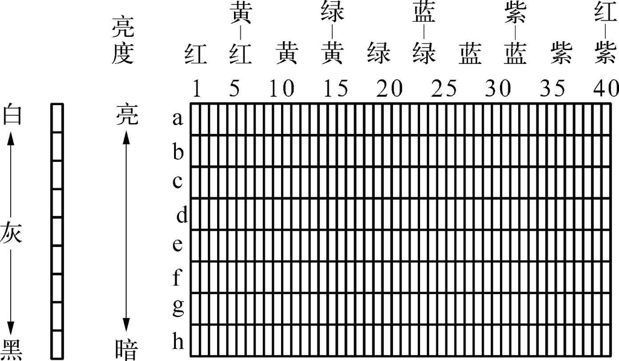

图1.1 Berlin和Kay所使用的Munsell色卡的排列（数字与文字是加上去的）

依靠色卡的帮助，Berlin和Kay着手试验所选20种语言的说话人是如何对颜色进行范畴化的。在试验中，他们对总的颜色词汇不是太感兴趣，他们感兴趣的是符合如下标准的一组特别的颜色词语：这些词语应该只包含源自母语的一个词（与绿蓝 （greenish-blue ）和青绿 （turquoise ）这种词相反）；这些词语不应该只用于非常有限的一类事物（如与英语、德语中的金黄 （blond ）相反）；这些词应该很容易地出现在脑子里并为所有或至少是某种语言的大多数使用者所熟悉（比如，与朱红 （vermilion ）、洋红 （magenta ）或靛蓝 （indigo ）相反）。满足了这些标准的颜色词语被称为基本颜色词语（basic colour terms） 。在实验的第一步中，Berlin和Kay收集了这20种语言的基本颜色词语。这是通过一种叫“口头诱导试验”的方法而取得的，也就是要求各种语言的说话人对颜色进行命名，“口头诱导试验”只是一种更复杂的说法而已。实验的第二步是，向这些说话人出示色卡，并要他们指出：

1．所有在任何条件下［他们］都称之为x的色卡。

2．x最好的，最典型的样本。

（Berlin和Kay 1969：7）

他们所提的问题表明，与他们之前的Lenneberg和其他人类学家不同，Berlin和Kay不仅对颜色范畴的外延感兴趣，而且对它们的最好样本也感兴趣。人们也许甚至可以说，后来所称为“原型”的东西在他们第二个问题的措辞中已露端倪。

Berlin和Kay发现的结果是什么？在对颜色进行范畴化时，人们依靠颜色空间中的某些点来定位。例如，当操英语的人被问到“红”色的最好样本时，他们一致指向标为“红”色的较低，也就是较暗区域中的色卡（图1.1中的f3和g3，当然，在试验中，色卡上是不给出颜色词语的）。至于黄色，被试一致选择了在“黄色”标签之下的第二等亮度的色卡（图1.1中的b9）。这些被全部或大多数操英语的人认为是一些最好的样本的色卡（或者颜色空间中的区域），被Berlin和Kay称为“焦点”（foci）。

他们也为其他19种语言找到了焦点（foci）或焦点颜色。当对这些不同语言中的焦点颜色进行对比的时候，结果令人大吃一惊。不但说同一种语言的人拥有同样的焦点色，而且说不同语言的人拥有的焦点色也非常一致。只要是一种具有与英语的颜色词语大致相应的颜色词语的语言，它们的焦点都处于同样的区域。而且，甚至那些基本颜色词的数量比英语少的语言，这些数量上较少的范畴的最好样本也与像英语这样“更丰富”的语言中的各个焦点颜色相吻合。

总之，有非常确凿的证据表明，颜色范畴不是任意的，而是固定在焦点颜色上的。颜色范畴的边界在不同的语言之间，甚至在一种语言的不同的说话人之间发生变化，而焦点颜色则为不同的说话人，甚至是不同的语言社团所共有。

大凡重要的科学发现总是这样，焦点色的发现不仅帮助解决了一个问题，而且提出许多新的问题。焦点色将被看作是语言现象还是心理现象？如果假定它是后者，那么它们的心理学地位又是怎样的？最后，“焦点”（foci，聚焦之点）是只限于颜色还是在其他领域中也能找到？这些问题都将在以下各小节中进行讨论。

### 焦点颜色的心理学背景

从心理学的立场上看，对自然现象的范畴化是相当复杂的操作，它包括如下过程 <sup>(4)</sup> ：

（1）刺激的选择 在大量的为我们的感官系统（视、听、触、嗅）所感知的刺激中，只有很少的刺激为我们的认知处理所选择，也就是说，这些刺激吸引了我们的注意力。

（2）鉴别和分类 这是通过对比所选择的刺激和储存于我们的记忆中的相关知识来达到的。

（3）命名 大部分认知范畴都被给予名称，尽管还有一些范畴没有贴上标签，如“节食中吃的东西”，“装入手提箱中的东西”。

（Barslou 1987：102）

Eleanor Rosch调查了这些方面的大部分，她在20世纪70年代早期开始探讨焦点颜色的心理学背景 <sup>(5)</sup> 。作为一个心理学家，她首要的目标是去发现焦点色是植根于语言还是植根于前语言认知。她的想法是，如果可以证明焦点色在范畴化的认知过程中是凸显的，那么也就能确定焦点色的认知地位。

从三个最基本的认知过程出发，Rosch首先检验了焦点色在感知上是不是显著的。为了消除纯粹基于语言的范畴化的影响，她要求被试尽可能少拥有已经储存的颜色名称和有关的颜色范畴的知识。所以她决定以学前儿童和其文化未西化的巴布亚新几内亚的Dani人作为实验对象。先前的研究已经表明，相对于说英语的人可以有的11个基本颜色词语，Dugum Dani这种Dani人说的语言只有两个基本颜色词语（Heider 1971）。像儿童一样，Dani人也就特别适合于作为颜色范畴化的实验中未被污染的被试。操英语的成人，被认为已经具有可以自由支配的整个基本颜色词语系统，这些人只在一些试验中用作对照组。

Rosch的第一个实验（Heider 1971），是用来试验注意力的激起（或刺激选择）的，被伪装成一个叫做“给我看颜色”的游戏。她给3岁的孩子一排色卡，这排色卡包括一种（像Berlin和Kay发现的）焦点色和同一色度但不同亮度层次的7个其他色卡。孩子们被告知，他们应该给实验者出示他们喜欢的任何颜色。这个实验背后的道理是，焦点色比其他颜色更易于吸引孩子的注意。事实上，其结果是孩子们选取焦点色卡的频率的确比选取非焦点色卡的频率高得多。焦点色卡中黄、橙、绿占有特别强的优势；在24个孩子中，分别有22、21、11个从颜色排列中选取那种焦点色卡。对另外5个色度，数目虽然小些，但统计学上仍然是显著的。

Rosch以儿童做的第二个实验是颜色匹配实验。这次的被试是4岁的孩子，每次以随机的顺序给一块焦点和非焦点色卡，要求指出在一排色卡中的同一颜色，这种色卡的排列与那些以前实验中使用的是相同的。正像实验的假设所预期的那样，焦点颜色的匹配比非焦点颜色的匹配要准确得多，这又一次证明了焦点色感知上的显著性。就认知过程而言，这第二个试验包含了鉴别与分类；试验的色卡和一个或几个可能的目标色卡必须得到鉴别和分类，这样才能对它们进行对比。对比的前提是，收集起来的关于色卡的资料被临时储存于某处，而这就是记忆起作用的所在。

匹配操作的情境中，试验项目和目标项目都同时被展现出来，这在某种程度上应该算是例外。一般来说，我们面对一个项目（也就是必须得到鉴别和分类的颜色）却必须完全依靠储存于记忆中的资料来进行对比。这就产生了这样一个问题：焦点颜色是否在记忆中也是显著的，它们是否比别的颜色更准确地得到识别、更易于学得、更易于回想起来。Rosch用特别的记忆试验来调查这几个方面：识别任务用于试验短时记忆，学习任务的目的则在于试验长期记忆（Heider 1972）。

识别任务与上文讨论过的匹配任务相似，但要求被试更集中注意力。因为这个任务对于儿童来说太难了，所以Rosch使用了Dani人被试，就像已经提及的那样，他们只有两个基本颜色词语。同样的试验还用于一个由美国人组成的对照组。随机给Dani人和操英语的被试看8张焦点颜色卡片和8张非焦点颜色卡片，每张看5秒钟。每一次单独的展示后，接着是30秒钟的间隔时间，然后要求被试指出在Berlin和Kay那种色卡上与之吻合的色卡。两组被试对焦点色的匹配准确率都大大高于非焦点色的匹配准确率。可以得出这样的结论：在短时记忆中，焦点色比非焦点色可以得到更准确的记忆。另一个实验结果是，操英语的那组被试在焦点色和非焦点色的匹配准确率上都比Dani人要高，其原因可能是，操英语的人拥有更大的基本颜色词语的集合，这有助于颜色认知。

第二个实验包括一个学习任务，以试验在长期记忆中对先前不知道的颜色名称的记忆情况。这个实验利用了这样一个事实，因为Dani人只有有限的两个基本颜色词语，所以可以在控制的条件下教给Dani人更多的颜色词。试验开始前，Dani人被告知，实验员将教给他们一种新的语言。学习完成后，他们的帮助会得到报酬。实验开始时，以任意的顺序排出16张色卡（也是8张焦点颜色和8张非焦点颜色），然后告诉Dani人每张色卡的名称（所用的名称是Dani氏族的名称）。第一次摆出这些卡片后，这些卡片被收进一个包里，打乱，然后一张一张地展示给Dani人，要求他们给每一种颜色取一个名字。他们每一次回答正确都会得到表扬，答错的时候，则会告以正确的名字。这种程序一天重复5次，直到Dani人能得出所有16个正确答案，学习过程才被认为是完成了。这个平均持续3天半的整个学习过程被保留了详细的记录。因为所有正确与不正确的答案都被计算在内，所以，这种记录提供了对焦点色与非焦点色记忆的容易度的衡量手段。在他们第一轮完全正确回答以前，Dani人对非焦点色的每种颜色给出了9.9个不正确的答案，而对焦点颜色，同样的错误平均数只有7.3。即使先前没有颜色名称的知识，Dani人把焦点色与其名称联系起来也比把非焦点色与其名称联系起来要快。

让我们回顾一下Rosch的发现：

· 焦点色在感知上比非焦点色显著。焦点色比非焦点色更经常吸引3岁孩子的注意，在匹配其他给出的颜色时，4岁的孩子用焦点色比用非焦点色匹配得更精确。

· 焦点色在短时记忆中得到更准确的记忆，并且在长期记忆中更容易保留。

· 在颜色命名任务中，焦点色的名称能被更快地给出并为孩子更早习得。

总之，焦点色看起来具有特殊的感知-认知的显著性，这种显著性可能独立于语言之外，并反映了人类感知机制的生理学上的某些方面（Kay和McDaniel 1978）。这些研究结果鼓励Rosch把焦点——或者，像她现在所说的，原型（prototypes） ——发展到颜色范围之外，比如进入形状、生命体、物体的领域。

### 原型形状

我们以一个小小的实验来开始我们的讨论，这个实验的基础是图1.2中的最上一排（第一组）中的图画。想像一下，有人要求你向某个不准看这一排图画的人描述你在图画中之所见。可能你多半会这样进行：“有一排小图画，画的是正方形及其一些变形。第一个图是正确的正方形。第二个正方形在右手边有一个缺口。在第三个正方形的右边有一处凹陷。第四个正方形……”

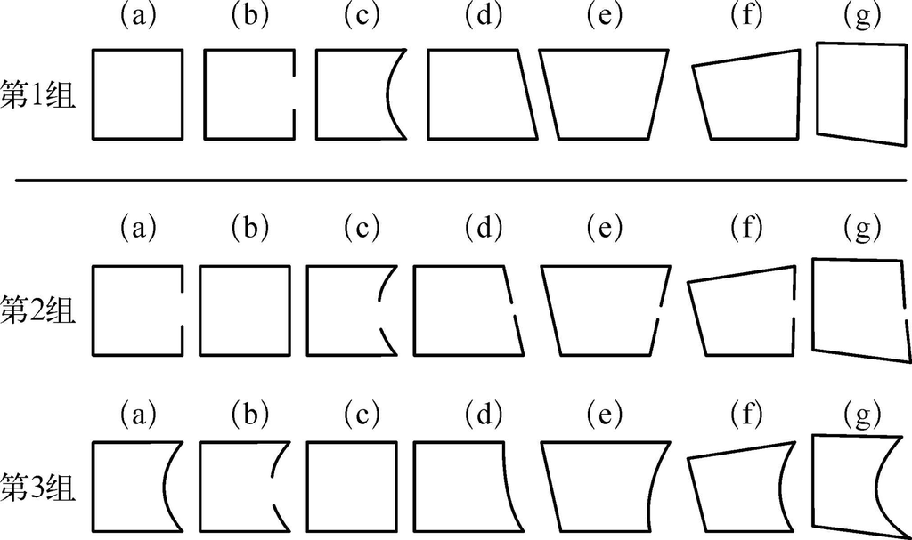

图1.2 Rosch用于原型实验中的形状（Rosch 1973）（第2组和第3组根据Rosch的描写作了重构，字母是现在加上去的）

这种描述完全符合完形心理学（一个心理学学派，在1.2节中我们将详细讨论）中提出来的“好形状”这一概念。在几何形状中，这些好形状，也就是正方形、圆形、等边三角形，被认为在感知上是显著的。

这样，在一个像上文描述的情境中，人们将选出正方形作为说明其他图画特点的参照点，那是再自然也不过了。所以，与颜色领域中的焦点色相似，在几何形状这一领域，正方形和其他好形状也就成了“自然”原型的首选对象。

Rosch（1973）试图以图1.2展示的这种线条画来证实形状领域中的原型概念。在实际的实验之前，就像颜色实验一样，她必须确保Dani人没有可以随意使用的范畴名称或者甚至没有约定俗成的解释把他们导向可能的原型。这一点在一个领航员研究中得到证实，这种研究使用上文所展示的描写方法：一个被试向另一个坐在屏幕后边的并且不能看见那些线条图画的被试解释这些线条图画。不像受过教育的西方的语言使用者，Dani人不谈论正方形及其变体，而使用诸如“那是一头猪”或者“这是一个破篱笆”之类的表达方式来描述这些图画。

在实际的实验中，Rosch对比了第1组（有原型的一组）和从第1组的变体中衍化而来的其他各组。图1.2中的第2组和第3组展示了6组可能的变化组中的两组。第2组基于缺口原则（在右手边的缺口）。鉴于这个缺口原则，第2组中以（b）形式出现的原型的确是一个非常极端的特例，因为它表现的是缺口的不存在。第3组是基于凹陷原则的，正方形又一次仅仅成了这个组的边缘成员。

就像在以前的颜色学习实验中那样，Dani人必须学习也是借自Dani氏族的名称。这意味着他们必须把各组图画与名称联系起来。实验的结果完全证实了Rosch的假设：不管原型出现在自然范畴中（第1组）还是在其他某一组（对于这一组的规则来说，是一种边缘体现）中，它总是能和一个名称对上号并被判定为最好样本。

结合此前的颜色实验的发现，这些结果表明，原型在范畴的形成与学习的各个阶段都起着关键作用。

### 原型生物体与物体

原型最终要依靠到现在为止得到验证的范畴（颜色、形状）的感知特性，所以原型如果不是例外的现象也是非常有限的。在这一点上还存在争议。问题在于原型这一概念是否可以扩展到那些感知上不那么明显的实体上。诚然，红色与正方形都存在好样本与差样本。那么，狗、小汽车、房子是否也存在好样本与差样本呢？对Rosch和她的被试来说，是的。在一系列的实验中（Rosch 1973，1975改进版）她给被试（这一次是一些美国大学生）发出如下实验指令：

这一研究与我们用词指称范畴时脑子里出现的东西有关系。我们以“红”这个词为例。闭上眼睛，想像一下真正的红。现在想像一种橘红……想像一种紫红。尽管你可能还是用“红”这个词来命名橘红和紫红，它们却不是像那明显的“真”红那样的红（像“红”指称的实例那样明显）的好样本。简而言之，有的红比别的红更红。对于其他种类的范畴情况也是这样。就说狗吧。你们大家都有一些什么是“真正的”狗，什么是“更像狗的狗”的概念。对我来说，猎狗或德国牧羊犬是很像狗的狗，而北京哈巴狗则是不太像狗的狗。注意，这种判断与你喜欢该物的程度没有关系。［……］

（Rosch 1975：198）

剩下的指令要求学生们判断范畴成员的合格性（goodness） （或者典型性（typicality） ），也就是说，决定BIRD（鸟） 这个范畴中，麻雀、鹦鹉、企鹅和另外大约50个候选对象作为一个成员在多大程度上是合格的。合格性等级划分为7点刻度（1点表示很好的样本，7点表示极差的样本）。一共试验了10个范畴，除了BIRD（鸟） 之外，还有FRIUT（水果） 、VEHICLE（交通工具） ，SPORT（运动） ，TOOL（工具） ，TOY（玩具） ，FURNITURE（家具） ，WEAPON（武器） 和CLOTHING（衣服） 。

不可否认，Rosch的实验指令显示了对原型性概念的导向（“……有的红比别的红更红。对于其他种类的范畴情况也是这样”）。但这应该不会太多地影响实验结果。正像Rosch所强调的那样，这种等级划分实验容易为学生被试所接受，并且他们在什么是范畴的好样本和差样本上存在着高度的一致。为了对实验的结果有一个印象，图1.3列举了这10个范畴中五个范畴的最好的、近于中等的和最差的样本。

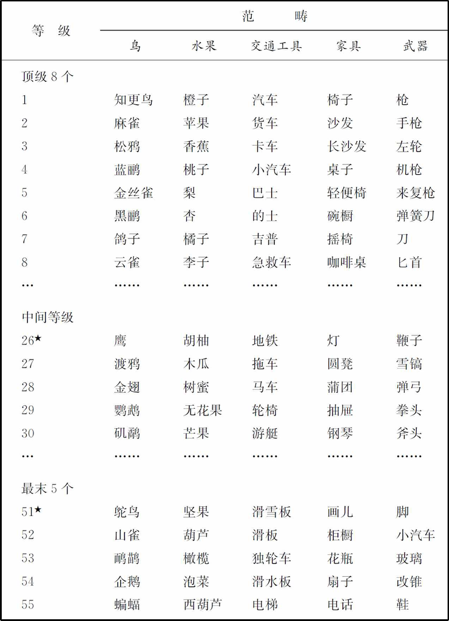

★因为列举的项目总数在50和60之间变化，中间和最低等级的编号与原来所有的范畴等级并不一致。

图1.3 从Rosch的样本合格性等级实验中选出的一些样本（Rosch 1975）

这种合格性等级在使用了“预供信息”技术的匹配实验中（Rosch 1975）也得到了证实。在其中的一个实验中，被试从一个屏幕上看到名称或图画的配对。当项目的同一名称或图画配对出现在屏幕上时，被试必须摁一下“同一”键（比如，一个类似鹰—鹰 这种词的序列或者两张同一只鹰的图画）；以此来测定内容的出现与被试作出反应之间的时间（范围介于500毫秒到1000毫秒之间）。屏幕上内容出现前两秒钟，把范畴的名称（在这个实例中是鸟 ）作为预备信息提供给被试，这样，被试“预供”了范畴名称（还有一个对照组进行非预供信息的实验）。这个实验的假设是：范畴名称的预备知识会影响执行匹配任务的速度，并且会以不同的方式影响好样本与差样本的匹配。信息预供的确有双重效果，很好地证明了合格性等级。预供信息的被试对于已经列入好样本（词和图画）项目的同一配对作出的反应更快。相反，当涉及差样本时，信息预供却降低了反应的速度。信息预供对合格性等级居中的样本配对的反应没有明显的影响。如果我们此刻还没有在对范畴认知表征的思考中迷失，那么，我们仍然可以支持Rosch的观点：由预供的范畴名称唤起的预备信息最容易应用到好样本；麻雀、橙子、小汽车（美国英语中的automobile）与BIRD（鸟） 、FRUIT（水果） 和VEHICLE（交通工具） 这些范畴名称所唤起的预期完全吻合。然而，这种预备信息对差样本同一配对却是没有帮助的。事实上，当被试面对企鹅、橄榄、独轮车这些至多只能放在BIRD（鸟） 、FRUIT（水果） 和VEHICLE（交通工具） 这些范畴边缘的配对时，带有范畴名称的信息预供反而会迷惑实验中的被试。

### 好样本、差样本和范畴边界

正如颜色、形状、鸟和交通工具的范畴化所表明的那样，范畴成员身份区分，并非如长期以来哲学家与语言学家所假定的那样，非此即彼。相反，正如为实验中的样本合格性等级划分、识别、匹配和学习任务所证实的那样，范畴成员身份包含了不同程度的典型性。

Rosch主要想证明范畴是围绕原型形成的，原型起着参照点的作用。至于范畴的边界，Rosch留给我们的印象是，在范畴边缘之外的某一个不确定的点上或区域上，范畴以某种方式淡出，以至于无。这并非以某种幼稚的方式谈论范畴时的想法。在一般的情况下，我们倾向于把范畴想像成一些箱子、抽屉或某类有围墙的院子——当然是一些有边界的事物。就范畴BIRD（鸟） 而言，即使可能需要一点儿动物学知识，确定边界的位置似乎还是非常容易的。

然而，当我们跟着哲学家Max Black来思考他发明的想像中的“椅子博物馆”时，我们的这种信心就会随之渐渐减弱。按照Black的说法，这个博物馆包括：

一系列质地差别极不明显“椅子”。在包括也许是上千个展品长列的一端，可能是一把Chippendale牌椅子，而另一端，是一小块没有明显特征的木头。任何“正常”的参观者在观察这个系列时都会发现要在椅子与非椅子之间“划一条界线”是极端困难的。

（Black 1949：32）

Black对他的椅子博物馆的解释表明，聚集在一起的椅子可以并且应该看作是一个在椅子与非椅子之间存在一种过渡地带而不存在明确边界的连续统一体。这种观点与我们本章开头时的观察好像是相冲突的。本章的开头认为，像房子、书、椅子这些具体事物的边界是得到明确的界定的，而且很容易识别，而模糊边界与过渡地带只限于像膝盖、雾和山谷这类项目以及像长度、温度和颜色这类阶（scale）。

在这儿，我们必须谨慎，不要混淆了两种不同类型的边界和过渡地带。一种过渡地带来自这种观察：有的具体实体在现实中没有明确的边界——膝盖及身体的其他部分，这也适用于雾、雪和类似的天气现象及像山谷或山这种地貌。然而，在Black的椅子博物馆中，参观者面对的却是一种不同的过渡带，因为博物馆中的每件展品都是有绝对明确界限的实体。在椅子博物馆中，相互融合的不是实体而是实体的范畴，而这些范畴则是认知分类的结果。因此，模糊的不是实体的边界而是这些认知范畴（在这儿是椅子与非椅子）的边界。为了区别这两类不同的模糊，我们将把术语“含糊实体”（vague entity）和“含糊性”（vagueness）限用于第一类（膝盖、雾、山谷）而把术语“模糊范畴边界”（fuzzy category boundaries）和“模糊”（fuzziness） 限用于第二类，也就是CHAIR（椅子） 等等的范畴边界。

然而，因为事实上存在着含糊性（vagueness）和模糊性（fuzziness）的重合，这个问题甚至更复杂。这对于第二类实体就是这样，正如哲学家Willard Quine所观察的那样，他发现MOUNTAIN（山脉） 这个范畴：

在包括了多少地带以后才能算是毋庸置疑的山脉这一点上是含糊的，而在高到多大程度的高地可算作是山的范围这一点上也是模糊的。

（Quine 1960：126）

换言之，山这类实体之所以是含糊的，是因为作为单个的实体，它们的边界是没有明确界限的；而认知范畴MOUNTAIN（山） （或者KNEE（膝盖） 、FOG（雾） ）之所以是模糊的，原因在于它也没有明确的边界。

总之，我们可以说，我们对范畴化的认知背景更深入的理解大大改变了我们原来把实体三分的看法，那种基于一种“朴素的现实主义” <sup>(6)</sup> 的看法把实体分为三类：（一）边界明确的生物体和物体、（二）有含糊边界的实体和（三）按阶（scale）区分的实体。从认知的角度看，这些区分和由此而引发的对含糊性的讨论是次要的。重要的是所有种类的实体和像颜色这种自然现象是根据原型范畴在概念上进行组织的，而原型范畴的边界不像是明确的，而是模糊的。

范畴边界的模糊性质，这种在直觉上似乎令人信服的概念，怎么才能进行实证研究？这就是William Labov用杯子和类似杯子的容器所做的一系列实验中的任务（Labov 1973，1978） <sup>(7)</sup> 。从Black关于椅子博物馆的解释出发，Labov得出了如下结论：

含糊性（vagueness）［也就是我们术语中的模糊（fuzziness）］的主观方面可以认为是这个词语在是否指称上缺乏确定性；这也可能转变为一个特定的说话人实例实际上使用这个词的一致性。

（Labov 1973：353）

如果在一个实验中所有的被试都把一个对象叫做椅子 ，那么一致性是100％。如果一半的被试对某一对象是否仍然是椅子有所怀疑并因此不把它叫做椅子 ，那么，一致性的值就下降到50％。如果几乎没有被试认为一个对象是椅子并拒绝把它叫做椅子，那么一致性值则将接近于零。Labov实验的实际试验过程非常简单：给被试出示如收集在图1.4中的杯子与其他容器的线条画。这些画一个一个地展示并要求被试对它们进行命名（在分析中忽略了被试提供的额外的描写性细节）。

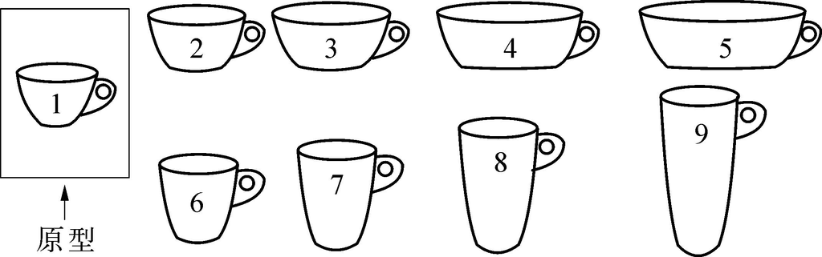

图1.4 Labov（1973：354）使用的一些类似杯子的物体的图形（第5号是重画的；在那个实验中也用了无柄或带两柄的变化图形）

命名任务的结果按一致性进行分析并表现为“一致性曲线”。图1.5表现的是对出现在图1.4上排的容器的一致性图表。正如用杯子 命名的曲线图所表示的那样，对于1号容器的一致性是100％，但向5号容器递减。图1.5还包含了一条用碗 命名的互补曲线。这条曲线说明，Black的椅子博物馆是相当非现实的，因为他只对比了椅子和非椅子。相反，Labov的实验表明，在实验室和日常的范畴化情境中，我们一般不只是在两个范畴“X”和“非X”之间作出区分，而是可以随意使用两个或几个名称使我们能够在相邻的范畴之间作出选择，在这个实例中就是CUP（杯子） 、BOWL（碗） 、MUG（茶缸） 和VASE（花瓶） 等。所以，把模糊的范畴边界看作是相邻范畴间的边缘地带，比把它看作是向概念真空的过渡，更为现实。图1.5显示，随着对4号和5号容器的杯子 一致性值的急剧下降，用碗 命名的一致性慢慢开始上升。“模糊边界”这一术语正是用在这种两个范畴之间的边缘地带上显得特别贴切。Labov的实验因此可以看作是对范畴边界的模糊性的第一个证明。

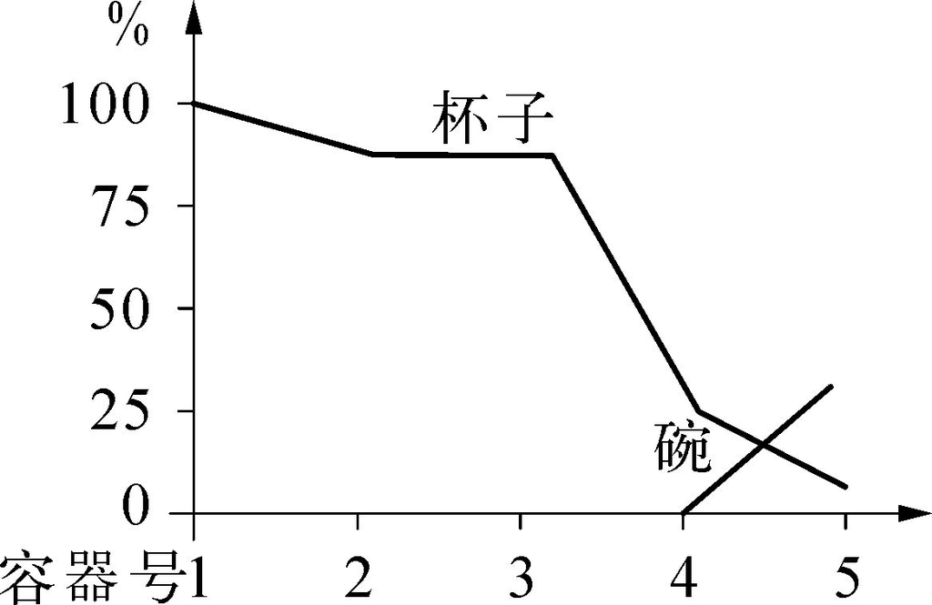

图1.5 中性语境下的一致性曲线（引自Labov 1973）

然而，当我们全面考虑Labov所做的所有实验时，这种模糊性表现出一个新的方面。在（到现在我们一直在集中讨论的）第一个实验中，被试面对的只是图画而没有给予任何背景知识（Labov把这叫做“中性语境”）。在接下来的三个实验中，要求被试想像如下三个场景中的一个场景：（a）喝咖啡情境，（b）对象盛有土豆泥的餐桌情境（“食物语境”），（c）对象竖立在架子上，里边插着折下的花的场景。在后来的实验中，也引入了像瓷器和玻璃这种不同的原料。

把这些变项包括进来的结果是范畴边界的巨大变化。只举一个例子，在食物语境中，3号容器对大多数被试来说就不再是杯子 了。就如图1.6所示，尽管它的形状保持不变，但有一半的被试把它叫做碗 ，对于4号容器，这种向碗 的转变甚至更为引人注目。Labov的实验以这种方式表明，范畴边界的模糊性是多方面的，其中语境依赖是最重要的方面之一（这一问题在1.3节中将继续讨论；Labov实验的另一个方面，即他对像宽度、深度和形状度量属性的谨慎地控制的使用，将在下一节中讨论）。

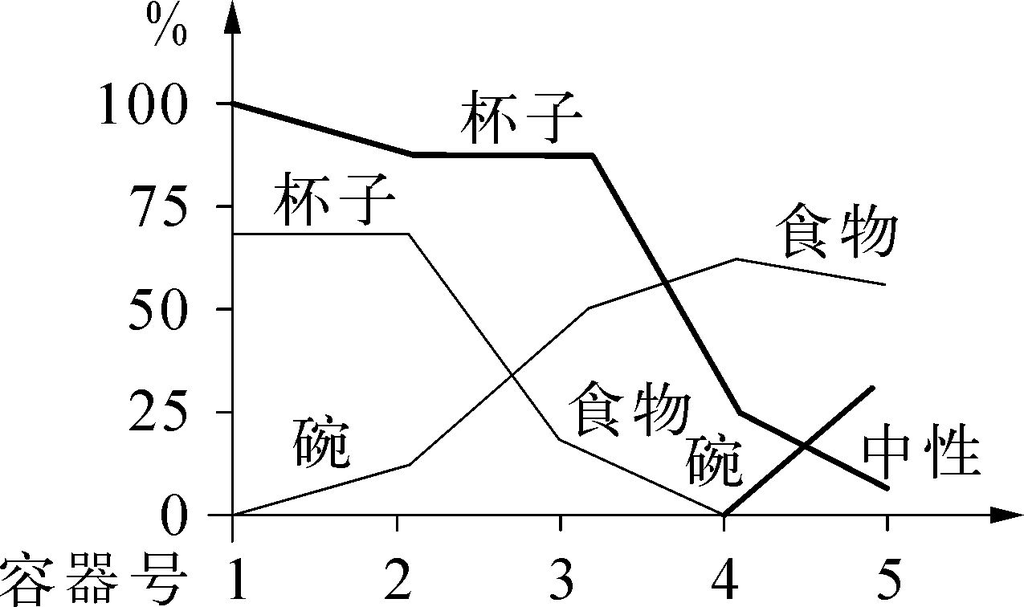

图1.6 中性和食物语境的一致性曲线（Labov 1973）

现在我们把Labov的发现结果与在前几小节中已经出现的关于认知范畴性质的一些观点联系起来：

· 范畴表现的并不是对世界上的现象任意的区分，而应被看作是基于人类思维的认知能力的。

· 不但颜色、形状，而且生物体和实体范畴，都定位于在概念上显著的原型，原型在范畴形成中起着关键作用。

· 认知范畴的边界是模糊的，也就是说，相邻范畴不是由明确的边界分开的，而是相互渗透的。

· 在原型和边界之间，认知范畴包含的成员，在典型性上可以从好样本到差样本的范围内划分等级。

如果我们承认认知范畴包含原型、好样本和差样本，并且有模糊边界，这表明范畴的内部结构的确是相当复杂的，而且值得我们更详细地考察。

我们以谨慎的措辞来为本节作一小结。认知范畴，正如我们在这节已经讨论的那样，是作为心理概念储存在我们的大脑中的，并以语言中的词来表示，所以人们会认为它们等同于这些词的词义。然而，如果我们考虑一下，颜色词语不仅指称颜色，而且也可以表示政党；鸟 不光指有翅膀的生物，而且至少偶尔也指美女；椅子 可以指称会议的主席；杯子 和碗 也可以是体育比赛的奖品，那么，范畴（或曰概念）与词之间不存在一一对应的关系也就很清楚了。事实上，一个词指几个范畴是很正常的，或者以通常的语言学术语来说，词是多义的 <sup>(8)</sup> 。正像以后的章节（特别是第3、4章）将会表明的那样，认知语言学不但关注各个单个范畴的探索，而且它也讨论以一个同样的词表示的范畴之间的关系。

### 练习

1．列举英语（或你的母语）中的基本颜色词语，检查哪些颜色词语只包含一个单词并可自由地应用于不同种类的物体与生物体。用基本颜色词语作为参照点，描写毛衣、T恤衫等的颜色。

2．选出范畴T-Shirt（T恤衫） 、LONG-SLEEVE（T-SHIRT）（长袖（T恤衫）） 、SWEATER（毛衣） 和JUMPER（套头衫） 的典型成员。你能想出表现这些相邻范畴之间边界模糊性的衣物吗？

3．画出原型样本和BOTTLE（瓶子） 、GLASS（玻璃瓶） 、VASE（花瓶） 和BOWL（碗） 这些范畴之间的边界线上物体的图画，用它们作为刺激物跟你的朋友或家里人做命名实验。

4．正如我们已经发现的那样，物体的含糊与范畴的模糊必须分开。看一看下面的样本并讨论它们中那些包含模糊（fuzziness）或者含糊（vagueness）或者两个方面都包含了：

mountain （山）、hill （小山）、summit （山顶）、plateau （高原）、valley （山谷）

tree （树）、shrub （灌木）、flower （花）

hedge （树篱笆）、bush （灌木丛）、forest （林子）、park （公园）

street （街）、road （路）、avenue （大道）、drive （私人车道）、highway （高速公路）

river （河）、stream （小河）、brook （小溪）、torrent （急流）、firth （入海口）、estuary （河口）、spring （泉）

5．范畴原型的名称会在那些边缘样本之前出现在脑子里。以两个非正式实验来检验这一假设：请一组朋友尽可能快地说出5种狗、鸟、树和小汽车；将被试提到的项目列出来，添加一些其他合适的项目，并将这张扩展的列表给第二组看，要求列出样本合格性等级。比较结果，讨论两个测试差异的原因。

## 1.2 范畴的内部结构：原型、属性、家族相似性和完形

如果认知范畴是由原型和边缘成员、由好样本与差样本组成的，那么，它们是如何区别，又是如何互相联系的呢？属性的列举与分析似乎提供了分析范畴内部结构的这些方面的好方法，而家族相似性这个概念作为一种理论上的解释也很有用。范畴化中生物体与实物的“完形”这一富有吸引力却研究得相对没那么完备的因素也将提出来进行讨论。

正如我们所看到的那样，认知范畴被贴上词的标签，而词则排列在词典中。所以，从词典的词条中寻找关于范畴内容的信息也就再自然也不过了。下面是词典中对几种鸟的定义的几个例子：

知更鸟 一种小而棕色的欧洲鸟，胸部红色。（《牛津现代高级英语词典》（OALD））

鹦鹉 一种热带鸟，喙弯曲，羽毛色彩鲜艳，可以教会模仿人类说话。（《朗文当代英语词典》第四版（LDOCE4））

鸵鸟 鸵鸟是一种很大的非洲鸟，不会飞。腿长，颈长，头小，羽毛大而软。（柯林斯伯明翰大学国际语料库（COBUILD））

从范畴化的角度看，这些词典里的定义提供了两类信息。首先，它们提供了包含知更鸟、鹦鹉和鸵鸟的范畴的名称（在这个实例中是鸟 ）。这个范畴的名称又反过来表明了大部分鸟共有的属性：有羽毛、两腿、两翅膀、一喙，下蛋。词典的词条主体列举了讨论中的特定项目的特性。这样，知更鸟的特征就描写为：小个儿、棕色、胸部羽毛红色。这些特性明确地把知更鸟与BIRD（鸟） 这个范畴中如鹦鹉和鸵鸟这些其他成员区别开来。所以，知更鸟、鹦鹉和鸵鸟既有用以把它们联系成一个同一范畴的特性，也有把它们相互区别开来特性。把共有的与区别的特性集合起来，似乎提供了一种描写范畴内部结构的可行途径。

然而，还存在一些问题。词典中的定义是为实用目的而写的，而并没有考虑系统的语言与认知的分析。词典学家无妨忽略一些不言自明的当然特性，或者，他们可以用限定表达或“迂回”（“hedges”，译注：指限定或者补救的手段），比如通常 （鹦鹉“通常”有色彩鲜艳的羽毛）来修改他们的定义。一种更系统的语言学方法不仅必须填补这种定义上的空缺，如给知更鸟的定义加上：它唧唧而鸣；给鸵鸟的定义加上：它跑得很快。而且，语言学的分析还必须明确特性（property）或（用更技术化的术语）属性（attribute） 这个概念。

关于在词典词条中使用的属性，从“特点”或“典型的方面”这种相当含糊的意义上来理解它们也许是相当充分了。但站在一个理论性更高的立场上来看，必须再问一个问题：把属性看作是必要的还是非必要的？这一区别首先是由亚里士多德提出来的，他对比了事物的“本质属性”和“偶然属性”。本质属性的概念产生了所谓的“范畴观”或者“正统观”，这是一种为结构主义和转换生成语言学家所坚决捍卫的立场 <sup>(9)</sup> 。根据这一观点，范畴是由必要和充分条件的有限集合来定义的。这些条件被认为是边界明确、具有“离散”的特征（或者本质特征（essential features） ，我们也会这样称呼它们），这些特征可以出现或不出现。就BIRD（鸟） 这个范畴而言，这就意味着一种生物只有有两只翅膀和两条腿、一个喙、有羽毛并下蛋（这些是必要条件），它才能是鸟。另一方面，如果一种生物具有所有这些本质特征，这也足以把它归为鸟类。

这种对属性与范畴化的僵化观点，应用于我们在1.1节中介绍的包含好样本、差样本并带有模糊边界的认知范畴时，必然会陷入困境。要处理这些经验原型范畴，我们需要一种与正统观提供的大不相同的属性概念。下面对鸟属性的讨论将举例说明这个问题。

### 属性、好鸟与差鸟：一个实例

我们的起点是收集到的＞ROBIN＜（＞知更鸟＜）属性清单，在Rosch（1975；见图1.3）的实验中，知更鸟列为BIRD（鸟） 范畴最好的样本。这样做的想法是，这个清单是可以得到的最接近BIRD（鸟） 的“原型的”属性清单，从而它很适合于用来与那些合格性更低的范畴成员进行对比：

| 1．“下蛋” | 2．“有两翼与两腿” |
| --- | --- |
| 3．“有喙” | 4．“有羽毛” |
| 5．“会飞” | 6．“有瘦而短的腿” |
| 7．“小而重量轻” | 8．“有短尾” |
| 9．“啾唧/唱歌” | 10．“有红色的胸” |

这个清单基于词典对知更鸟 与鸟 的定义，但也为从实验中被试收集的属性所证实（Hampton 1979）。更确切地说，这儿列举的是词典编纂者和普通人（被试）认为在谈及知更鸟时值得提及的属性。这种清单将永远不会穷尽（例如，我们的描写就没有提及知更鸟吃何种食物），而且清单中的项目往往是交叉的（在我们的实例中，2号和6号，二者都指鸟的腿，而4号和10号，二者又都指鸟的羽毛）。然而，尽管这些缺点对出身正统的语言学家来说可能是难以理解的，这些属性似乎还是暂时给我们提供了最好的经验主义方法，以此来描写对知更鸟范畴化时使用的特性。

现在举一个没有那么合格的鸟的例子，比如＞PARROT＜（＞鹦鹉＜）。如果我们再检查一下我们的清单，鹦鹉在如下几点上与知更鸟相像：下蛋，有喙，两只翅膀，两条腿，有羽毛，能飞。然而，与知更鸟相比，鹦鹉有相当粗壮的腿，大多数鹦鹉比知更鸟大得多且有相当长的尾巴。并且鹦鹉当然不啾唧或唱歌。

最后，当我们考虑＞OSTRICH＜（＞鸵鸟＜）（当然，它被列为BIRD（鸟） 范畴的差样本）的属性时，我们发现，在我们短短的清单中，它所共有的属性只有下蛋，有两腿和羽毛，它还有某种喙。

总之，似乎存在一组表征“鸟性”重要方面的属性。这些属性在本质上往往相互联系，也就是说它们同现。一种有翅膀和羽毛的生物比一种有皮毛与四腿的生物更有可能会飞。满足了这些属性的鸟类在范畴中有特别凸显的位置。鸟 范畴的中间样本和差样本与那些原型样本之间的不同在于如下这两个方面：或者在一个或多个属性上稍稍偏离了一般标准（如鹦鹉的腿和尾）；或者有些属性完全缺失（比如，鸵鸟不会飞）。

属性的分布表示为矩阵图1.7，加号表示属性显现，减号表示属性缺失，加号/减号表示与属性预期形式或大或小的偏离。因而，这个矩阵反映了这样一个事实：属性的“是/否”表现形式（与正统观相对应）不能充分地表示鸟的属性而且必须修正以包括对属性的中间判断。

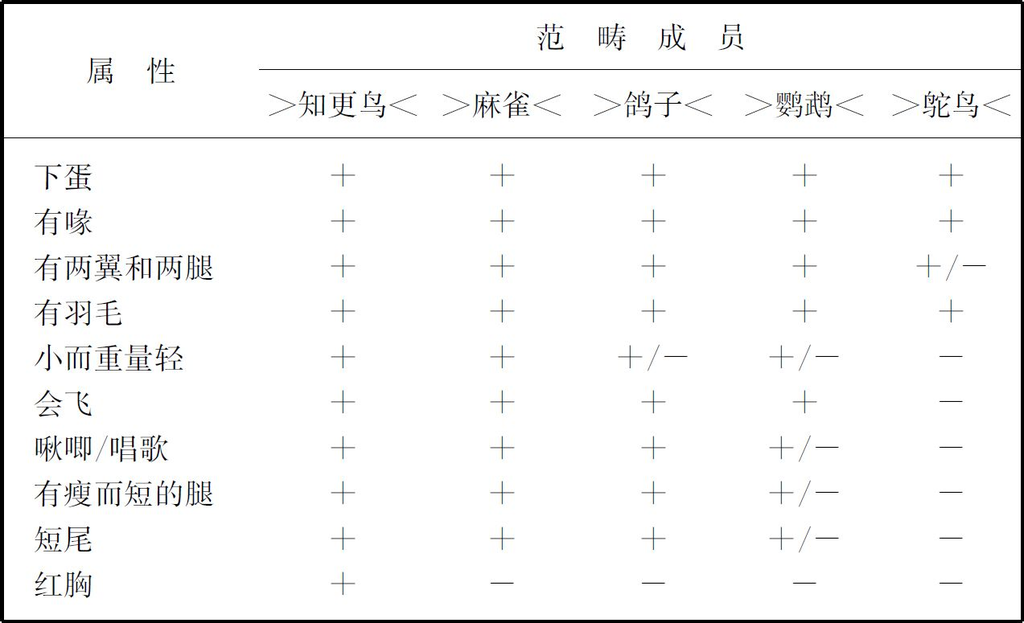

图1.7 样本合格性和BIRD（鸟） 范畴中的属性分布

尽管乍看之下可能不明显，但“偏离”与“缺失”的属性还是可以看作是不同的问题并在认知研究中以不同方式有所提及。因为属性的缺失（像在＞鸵鸟＜这个实例中）看起来是更为严重的问题，它将首先得到处理，而偏离的属性（正如我们对＞鹦鹉＜的观察）将在以后讨论。

### 家族相似性原则

鸵鸟这一例子的矛盾之处在于，尽管它与像知更鸟这种原型鸟只共有很少的几个属性，我们还是乐于把它叫做鸟。但正如上文中词典定义所表明的，用来描写＞鸵鸟＜的属性并不缺乏，这些属性中，有的（“很高”，“跑得很快”）似乎与我们关于鸟的观念不相容，而有的不相容性则少些。拿“长脖子”来说，你会发现此属性除适用于鸵鸟之外，还适用于红鹳和白鹳（尽管不适用于知更鸟）。或者就“大而软的羽毛”这一属性而言，它也许让你想到天鹅，而另一些词典提供的别的关于这一属性的说法，也就是“装饰性的羽毛”，则意味着与孔雀，也许甚至与鹦鹉（虽然不是与麻雀）之间的联系。

然而，正像哲学家路德维希·维特根斯坦在他被广泛引用的关于范畴GAME（游戏/比赛） 章节所表明的那样，在别的范畴中，项目之间甚至更不相似：

例如考虑一下我们称之为“games”的事件。我的意思是棋盘游戏（board-games）、纸牌游戏（card-games）、球赛（ball-games）、奥林匹克比赛（Olympic games）等等。它们全部有什么相同之处吗？——别说：“一定有某些共同之处，不然我们就不把它们都叫做‘games’”——只看一看并寻找对它们全部来说是否有任何共同的东西。——因为，如果你看它们，你不会看见它们全部都共同的东西，而只会看到相似性，看到相互关系和它们的整个系列。重复一下：别想，只看！——例如，在棋盘游戏中，用它们各种各样的相互关系。现在转到纸牌游戏，在这儿，你发现许多与第一组的对应，但很多共同的特性消失，一些别的特性出现了。当我们再转到球赛，保留许多共同的特性，但很多特性又丢了。——它们全都“有趣”吗？那么比较一下国际象棋和圈叉棋。是否总是有输赢，或者总是对抗比赛？那么考虑一下单人玩的牌戏（patience）。球赛是有输赢的，但当一个儿童把球扔到墙上再把它接住，输赢这个特征就消失了。看一看靠技巧与运气来玩儿的部分；再看一看下棋的技巧与网球技巧之间的区别。现在思考一下骑骏马（ring-a-ring-a-roses）这类游戏，出现在这儿的是娱乐成分，但有多少别的特征消失了啊！我们也能以同样的方式检查许多许多别组游戏；我们看到相似性是如何出现与消失的。

（维特根斯坦 1958：66以次）

维特根斯坦的结论是：各种游戏是由交叉的相似性网络联结起来的，他把这叫做家族相似性（family resemblances） 。在某种更抽象的层次上，家族相似性原则已经被定义为一个按下面这种分布方式排列的项目集合：

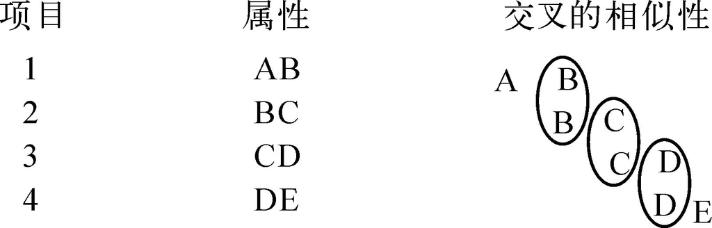

用Rosch和Mervis（1975：575）的话来说，“每个项目与一个或多个其他项目，有至少一个，也可能是几个共有的成分，但是没有，或者很少几个成分是为全部项目所共有的。”

维特根斯坦的解释和Rosch及Mervis提出的定义，二者追求的是同一个目标：那就是为了表明家族相似性原则开辟了一条不同于正统观的道路，因为正统观认为属性必须为全部范畴成员所共有，属性必须是“全范畴的”。这在对像GAME（游戏/比赛） （维特根斯坦的例子）和FURNITURE（家具） 、VEHICLE（交通工具） 、FRUIT（水果） 等Rosch和Mervis（1975）研究过的“上位范畴”的分析中可以得到最深刻的说明。就如我们将在后面的2.2节中看到的那样，上位范畴在很大程度上依赖家族相似性是不足为奇的。

当我们考虑像BIRD（鸟） 或者别的更具体的范畴如CAR（汽车） 、TRUCK（卡车） 、AIRPLANE（飞机） 、CHAIR（椅子） 、TABLE（桌子） 和LAMP（灯） 的时候，情况就发生了变化。正像我们在BIRD（鸟） 这一实例中所观察到的那样，甚至像＞鸵鸟＜这种非常差的范畴样本（我们还可以加上＞企鹅＜）也有一些与所有其他范畴成员共同的重要属性。当然，＞知更鸟＜和＞麻雀＜这种好样本完全拥有整个属性集束，所以它们的属性中只有一些是依赖家族相似性原则的。这种情况在图1.8中得到说明，在这儿，属性是用线条表示的。

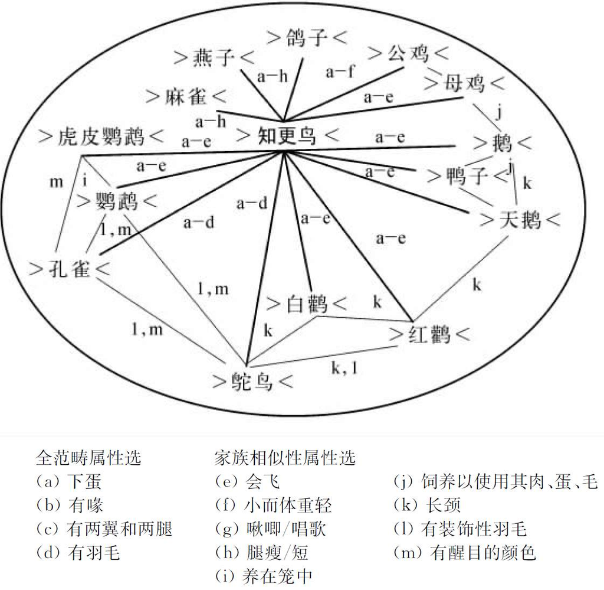

图1.8 鸟 范畴的共同属性选与家族相似性选

正像鸟的情况那样，CAR（小汽车） 和CHAIR（椅子） 这种范畴的成员（也就是各种汽车和椅子）比上位范畴VEHICLE（交通工具） 和FURNITURER（家具） 的成员（也就是各种交通工具和各种家具）共同拥有多得多的属性。本书的2.1节将为此提供解释。

然而，不管家族相似性的重要性在不同个体范畴上产生多大变化，都不影响其中原则的解释力。关键在于家族相似性可以解释：为什么即使属性不是为全部范畴成员所共有，也就是说即使根据正统观它们不是本质属性，这些属性也参与到范畴的内部结构。鸵鸟之所以是鸟，不只因为它有羽毛、下蛋，像知更鸟（在图1.8中以粗线条表示）；范畴成员身份也为这种事实所支持，即鸵鸟有像红鹳的长颈，像孔雀的装饰性羽毛（见图1.8中的细线）。这样，在确定范畴成员在范畴中的位置时，我们有充分的理由考虑为该项目提出的任何可感觉到的属性。这是Rosch及其同事所作的属性列举实验和基于这些实验的典型性等级的理论背景。

### 属性列举及属性基础上的典型性等级

假如我们似乎轻而易举就能想起熟悉的物体和生物体的属性，那么我们就可以通过一个相当简单的实验过程收集那些属性，而此实验过程可以很容易地应用于大量的被试。在Rosch和Mervis（1975）所作的属性列举实验中，他们给每个被试（400个美国心理学学生）6张在顶端写有实验项目的纸。被试用1分半钟时间写下所有他们能想到的属性。为了去掉某一项目的那些明显假的或者错误的属性或意义上太空泛的答案，两名检查员对这些属性清单进行了检查。

使用的试验项目选自图1.3描写的在样本合格性等级中得到的清单，包括由20个不同等级范畴成员组成的集合，FRUNITURE（家具） 、VEHICLE（交通工具） 、FRUIT（水果） 、WEAPON（武器） 、VEGETABLE（蔬菜） 和CLOTHING（衣服） 这些范畴每个范畴为一个集合。从＞椅子＜到＞电话＜（家具 ），从＞小汽车＜到＞电梯＜（交通工具） ，从＞橙子＜到＞橄榄＜（水果） ，一共试验了120个项目。

这个实验有两个目的：证明家族相似性（见上文）这一概念；对Rosch和Mervis来说更重要的是，提供基于属性的典型性等级（比起Rosch和Mervis自己的术语“家族相似性尺度”来，这个中性术语更合适）。然后，这些典型性等级可以用来证实早先的样本合格性等级。

属性基础上的等级是如何计算的？撇开数学上的细节，可以区分为两个步骤。第一步，对属性进行“称量”，也就是说，确定20个被测试的范畴成员中有多少成员列举了每一个属性。如果一个属性为全部范畴成员所共有，那么给它20分的最高分（如在交通工具实例中的“运输手段”这一属性）。一个属性只为一个范畴成员列出（试想一下“安装在建筑物内”这一属性只适合于＞LIFT＜（＞电梯＜）或＞ELEVATOR＜（＞电梯）＜）时只得1分。适用于几个但不是全部范畴成员的属性被给予中等得分。得到的结果就是称量过的属性清单。

在第二步中，把为每一个范畴成员列举出的所有属性的分量累加起来并排成等级排序（实际的过程要更复杂一些） <sup>(10)</sup> 。有许多具有共有所以也是分量重的属性的范畴成员，像FRUIT这个范畴中的＞橙子＜或者＞苹果＜，在总体上获得很高的等级；而像＞橄榄＜这种与别的范畴成员只共有很少几个（如果有的话）属性的范畴成员则得分很低。对比一下属性基础上的等级排序与样本合格性等级，这两类等级显示出高度的相关性。

这种相关性可以从两个方面用来证实原型范畴的概念。一方面，范畴由好成员与差成员组成这一假设再也不只是依靠对样本合格性等级的直觉判断，现在，这一假设还能与大量的属性联系起来。另一方面，好样本与差样本这一概念可以用来解释为什么属性在范畴成员中分布得那么不均匀。好样本与同一范畴中的其他成员有许多共同的属性，而差样本或边缘样本与同一范畴的其他成员只共有很少的属性。

但是，正如我们从这一节开头讨论的那些词典词条定义中所知道的那样，属性的范畴内联系只表现了问题的一个方面。同样重要的是区别性属性的问题，即一个范畴的成员，不管是好样本还是差样本，是否与其他相邻范畴的成员拥有共同的属性。这一点在进一步的属性列举实验中得到检验。在这个实验中，CAR（小汽车） 这一范畴中的好样本与差样本和TRUCK（卡车） 、BUS（巴士） 和MOTORCYCLE（摩托车） 这些范畴中的成员进行对比。结果显示，不同范畴的好样本之间的属性交叉区最小，而不同范畴的差样本或边缘样本之间的属性交叉区却大得多。换言之，原型小汽车，比如一辆轿车跟原型卡车共有的属性，比一辆客货两用轿车跟原型卡车共有的属性要少；一辆轿车跟原型摩托车共有的属性，比一辆三轮车跟原型摩托车共有的属性少。

考虑问题的两面，我们可以把原型范畴的属性结构小结如下：

· 认知范畴的原型成员拥有最多的与这一范畴的其他成员共同的属性，而拥有最少的与相邻范畴的成员同现的属性。这意味着就属性而言，原型成员与其他范畴中的原型成员的区别最大。

· 差样本（或曰边缘范畴成员）跟范畴中的其他成员只共有很少量的属性，却又拥有同时也属于别的范畴的属性，当然，这只是“范畴边界是模糊的”的另一种说法。

### 属性和维度

回顾图1.7那个鸟属性矩阵，Rosch和Mervis显然确已解决了当研究＞鸵鸟＜及鸟 范畴的其他差样本时出现的属性“缺失”问题。但这还留给我们“偏离”的实例，也就是其属性不符合预期标准的那些范畴成员。这种“偏离实例”大部分包含与维度（dimensions） 有关的属性，如“大小”、“重量”、“（尾巴的）长度”和“（腿的）粗细”。这把我们带回到Labov的杯子和碗的讨论中，这些杯子与碗我们在1.1节讨论模糊范畴边界时已经讨论过。在为他的实验选取那些杯子及像杯子的容器时，Labov可以依靠“宽度”、“高度/深度”和“形状”，也就是依靠那些被广泛接受的维度类型的“逻辑”特性，而不必陷自己于变化无常的经验主义属性列举。在这个方面，他比Rosch和Mervis更认同那些传统的语言学家。维度有一个优点，那就是在控制的条件下可以改变它们，而这种变化也可以容易而明确地以线条画表现出来。这可以在图1.4中得到说明，为方便起见，在这儿重复为图1.9。

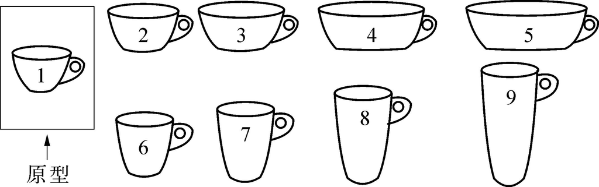

图1.9 Labov（1973：354）使用的像杯子的物体的图画选（5号图是重画的）

图中维度的变化基于1号这个“原型的”杯子。在上一排，容器的高度（或曰深度）保持不变而宽度却从一个容器到另一个容器系统性地逐渐扩大。相反地，在第二排中，容器的宽度是相同的，却从左到右变得越来越深。Labov使用的度量变化还涉及容器的形状，包括圆柱体和截去顶端的圆锥体等（在图1.9里未加以表现）。另外，他还使用“语境”或“功能”（“中性/咖啡/食物/鲜花语境”）、“质料”（玻璃、瓷器）和“柄的有/无”这些属性，初看起来，它们都是“非度量”属性。

为使这些各种各样的属性跟维度统一起来，Labov把他实验容器的特定宽度/高度比例定义为宽和高维度上离散的值。以同样的方法，与语境、质料和手柄有关的属性也被解释为维度上的值：把中性、咖啡、食物和鲜花语境定义为“语境”这一维度上的值；把玻璃、瓷器定义为“质料”这一维度上的值；把手柄的有无定义为“手柄”这一维度上的两个值。

在实际的实验结果中，也就是在对特定容器使用杯子 或者碗 或茶缸 时，这些属性值是如何显示出来的呢？按照Labov的说法，这些词的使用反映了实验被试对“已称量过的”接受度判断。这些判断在这种意义下得到称量：即有关属性的不同值引导被试为实验中的容器选择不同的名称。如果“原型的”杯子（1号容器）被全部被试叫做杯子 ，这一判断可以与这一事实相联系：即1号容器表现了中性语境中理想的宽度/高度比例。2号容器依然压倒多数地被称为杯子 ，因为它表现了非常相似的宽度/高度比例。与此相反，4号容器被评定为杯子 的边缘实例，因为它的宽度/高度比例明显不同于理想的值。如果杯子 这个词的使用在咖啡语境中为被试所扩大而在食物语境中被缩小，那是因为宽度/高度比例与“语境”维度上各自值的相互作用的结果。

这种三向相关性还可以表示为一致性曲线（如图1.5和1.6所示），而更复杂的互动只能由数学公式和概率计算来把握，这已超出了本导论的范围（见阅读注解7 ）。

尽管如此，Labov的目的和所使用的方法本应该变得非常清楚。从那些至少理论上可以看作是维度值的属性出发，他克服了逻辑观离散属性的内在限制，而这也似乎是他比Rosch和Mervis更进一步的地方。在称量过程中，度量值因而互相联系起来，而在这儿他的方法也与Rosch和Mervis的操作程序最为接近。

### 范畴内部结构和完形

在对比属性基础上的典型性等级和样本合格性等级（即直接典型性等级）的时候，我们认为后者的基础是直觉。但是，问题在于这种直觉可能是从什么衍生出来的。它是否可能依靠某种内部的属性基础上的等级呢？从“朴素”的观点上来看，这似乎是不可能的。当我们面对一只动物时，我们几乎不会通过估量特定的属性来开始对它进行范畴化，除非它有像斑马的条纹或大象的牙这种显著得让我们感到惊讶的属性。对于大多数生物体和实物来说，特别是那些我们熟悉的，我们好像是以不同的方式来对它们进行范畴化的。我们只是从整体上来把握它，进而对它的典型性进行初步评价，因而，后来才可能考虑特定的属性。

问题在于，这个看似有理的想法，似乎没有可能在控制的实验情境中进行研究，或者说得更直截了当些，好像不可能以实验来排除人们是在一个属性接着一个属性的基础之上来对项目进行范畴化并评价其合格性的。再一次回到Labov的命名实验，这种假设的确是言之成理的：那就是被试的判断根据的是杯子或碗的总体印象而不是对宽度/高度比例、质料和语境的内部计算，但也不能排除这种情况。到现在为止，我们不得不满足于不太正式的实验采访的结果。

此种采访中的一些是在房子的范畴化这一语境中进行的（Schmid 1993：121以次）。这些采访的起点是Labov的诱导物体图画范畴名称的方法，把这一方法用于图1.10中的建筑物。这个实验的采访部分的目的是收集范畴化过程是怎样进行以及被试是如何体验这一过程的信息。

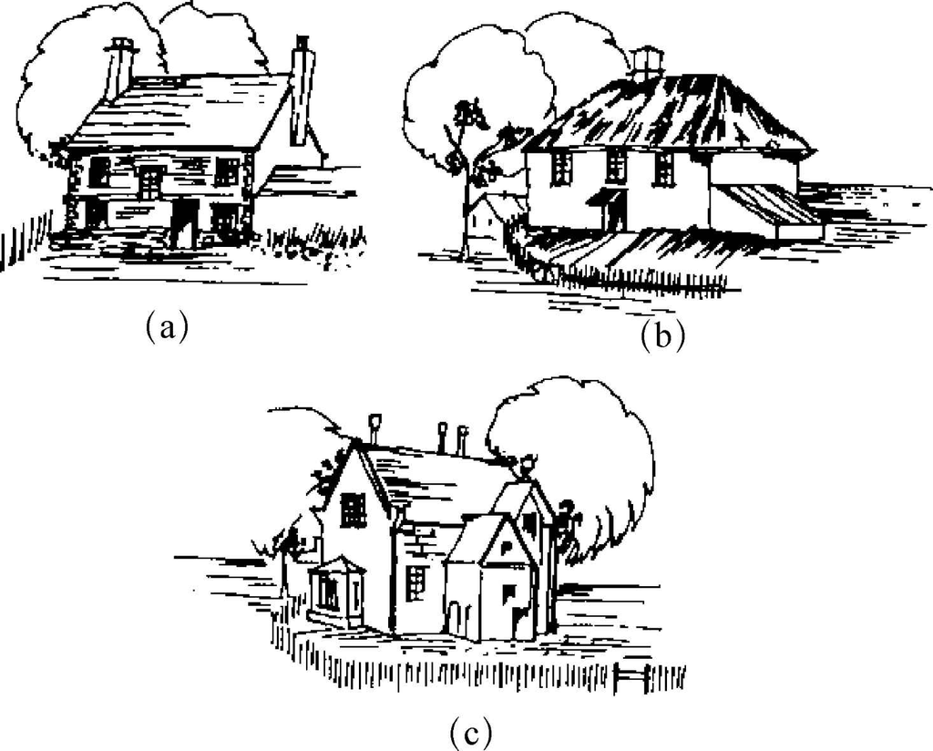

图1.10 用于范畴化任务的房子样本（Schmid 1993：151以次）

被试看一眼这些图画（混入别的图画，一张一张地展示）之后，说出这些建筑的名称。在这一阶段，图（a）和图（b）相当易于范畴化为农舍，而图（c）被指定为邻近范畴，称为乡村住房 或别墅 。正像对Labov的杯子与碗一样，被试中也不存在完全一致的意见。12个被试中有10个不把图（c）叫做农舍，而只有2个把它叫做农舍。当要求说明作出他们范畴化决定的原因时，被试们解释说，他们是根据对图画的总体印象来判断的。这可能表明，有一种内部的样本合格性等级已经在总体的第一印象的基础上建立起来了。只有在进一步的思考之后，被试才能明确指出某种独特属性可能引导他们选择所选的名称。选择农舍 ，对于图（a）而言，似乎是受了质料（“石头造的”）和其简单却又坚固的结构的影响，而对于图（b）来说，则是受了其茅草屋顶的影响。对于（c）这一建筑物，它异常的宽度/高度比例（“太大”）和众多的延伸部分，可能帮助大多数被试排除了将农舍 作为它合适的名称。

就这些采访现有结果来看，它们证实了最初的假设：范畴化和合格性等级划分可能确实包括了两个阶段：第一步，将物体作为整体的感知（所谓的整体感知（cholistic perception） ）；（可选的）第二步，对感知到的整体进行某种分解，把它分解成独特的特性或属性 <sup>(11)</sup> 。

“感知到的整体”的观念接近完形心理学家提出来的完形（gestalt） 概念 <sup>(12)</sup> ，所以参考一些这些心理学家的发现成果也许是有益的。他们的主要观点是：完形感知可以回溯到“感知组织的完形律”或“完形原则”，这通常是用线条图和点图案来说明的。这些原则中最重要的是：

·“邻近原则”：个体成分之间的距离小将被感知为它们互相有某种联系。

·“相似原则”：相似的个体成分往往感知为同一个片断。

·“封闭原则”：感知组织往往定位于封闭的图像。

·“连续原则”：若成分之间几乎没有断点，它们将被感知为整体。

个体成分的构造越符合这些规则，越有可能成为外形清晰而没有争议的组织（完形心理学家把它叫做“完整性”（Prägnanz）），也就越适合于完形感知。表现出高度的完整性的样本叫做“好完形”或“好形式”。其中有圆形、方形和等边三角形，它们在1.1节我们对形状的讨论中已经出现过，在那儿，它们是以形状范畴的原型出现的。

然而，尽管形状很重要而使得人们有时候不很精确地把它和完形等同起来，它也只是生物体和物体完形的一个方面。问题在于，完形规则是否不仅对点图和几何形状有效，而且也能应用到复杂得多的生物体与物体外形。

物体的组成部分好像在给物体提供完形时起了中心作用 <sup>(13)</sup> 。再审视一下图1.10中的（a）和（b）两座农舍，它们由墙、窗、门、屋顶和烟囱组成，这是一目了然的。然而，当我们第一眼看这些图画时，这些农舍在视觉上没有被“拆分”为这些部分，而是作为一个综合整体来感知的。因为这些组成部分是按照完形的邻近原则（所有部分连接在一起）、相似原则（同样的窗子）、封闭原则（所有部分都包含在一个整体轮廓之内）和连续性原则（所有的线条都没有断开）组织的，所以，这种整体视觉感知是可能的。

同样，如果你观察一下此刻目光所及的一些日常用品，可能是椅子、桌子、书架，你会认识到，那些显著的部分对整体作了重要的贡献，而不是首先被看作是一个个单独的部分。其他感知方面如物体的总体比例、质料和颜色跟总体形状及各部分相互作用，以形成完形的整体印象。

在证明了物体是作为完整整体感知之后，我们可以进一步问自己：是什么使得一个完形比另一个完形对范畴来说更具有原型性。在这儿人们进入了一个新领域，因为除了几何形状中的那些好形状之外，这个问题并不是完形心理学家所真正关心的。我们认为，物体的各部分又一次在确立原型的完形中起了重要作用。部分不但促成了物体总体形状的形成，而且与物体的功能相联系，而这种功能对大多数人造物品来说都是该物体存在的理由。同样，一个物体大多数组成部分存在的理由在于该物体所能满足的特殊用途。

以椅子为例，一把椅子的功能相关部分是腿儿、座位和靠背。现在，我们的假设是：椅子的原型完形主要依靠这三个功能部分以最佳功能比例的存在。请看图1.11所示的椅子图，图（a）最好地表现原型椅子的完形。

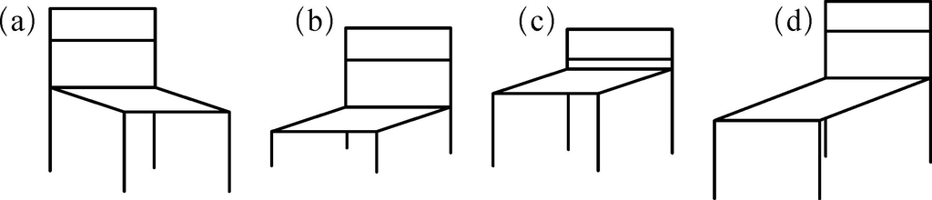

图1.11 原型的椅子完形和其他椅子

如果我们把鸟的“功能”理解为某种形式的有机生命演示，那么，类似的解释也可以用来说明像鸟这种生物体的完形。这种生命的原型模式会具有这样的特征：在树上和灌木丛上生活的能力，飞的能力，找食坚果、种子和虫子等的能力。设想一下组成部分的功能设计，我们可以从原型完形中预期喙、腿，尤其是翅膀这些组成部分有适当的形式：腿应该有爪子以让鸟抓住树枝，喙应该突出而尖锐以帮助鸟啄食食物，而翅膀的形状也应该符合空气动力学。甚而更重要的是，这些组成部分必须有适当的比例（相对于翅膀以外身体部分的大翅膀，等等）。这可以看作是本节开始（见图1.7）的矩阵中所列属性的翻版。关键的区别是这些功能上平衡的组成部分都整合成一个完形，并作为一个整体来感知。

所有这一切都可能表明，对实物和生物体而言，原型完形尽管是作为一个整体来感知的，但是我们应该把它看作是一种向相关的并且主要是视觉上的关键部分的简化。这一观点可以从如下经验中得到证实：简化的图解非常容易把握和范畴化，这种图解近几年越来越多地用于词典中 <sup>(14)</sup> （用于交通信号的图标则更为复杂，因为在这儿这些图画是作为交通工具用来起指示作用的，所以不作讨论）。

我们将坚持这样的立场：即使对实物和生物体而言，简图的有效性也不是一种普遍现象，而应视被图解的词汇范畴的种类而定。请看图1.12中选自同一部词典（《朗文当代英语词典》（LDOCE2）第二版，1987）的平房图和农舍图。平房简化为功能组成部分（有墙、屋顶、窗户、门的一层建筑），并仍能容易地识别。相反，农舍的图示则包含了丰富的细节，而这对于易于识别来说好像是必需的，所以事实上它也比图1.10中那些更简单朴素的农舍图更容易范畴化。

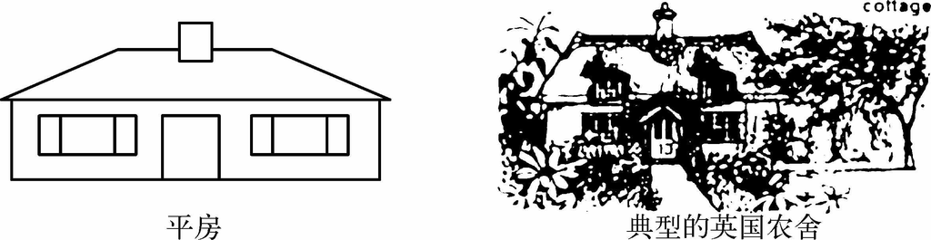

图1.12 平房和农舍：简化的样本与“丰富”的词典图例（自《朗文当代英语词典》第二版（LDOCE2），1987）

从这一点可以推断：尽管一所房子完整的比例协调的组成部分可能是很重要的，但是，农舍的原型完形包含的不止是这些。农舍的功能包括这些概念：带来温暖与舒适、处于自然的乡野环境中。换言之，各种与感情和态度有关的特性都包括在内。同样，一幅英国小酒馆的线条画（而且，顺便提一下，没有一部大词典提供了这种线条画）是很难想像出来的；小酒馆的完形特性简直是太丰富了。

或者举另一个简单的例子：玩具熊。要接近玩具熊的原型完形，只给出与其自然模型（棕熊）一致的轮廓图当然是不够的。还有必要指出其柔软性（某种让我们超出视觉完形特征而到达触觉完形特征的东西），而且，也许最重要的是，还有必要指出玩具熊应该是由孩子抱着的，这样才能使对于玩具熊的功能的一般印象完整起来。

这表明，甚至在实物领域，我们面对的也不只是一种完形原型（“简化类型”），还得考虑到某些词汇范畴需要更丰富的视觉表现，而且这又反过来暗示更丰富的潜在的完形原型。当我们考虑到，对于许多词汇范畴（那些笼统地称为“抽象”范畴的词汇范畴）来说，完形感知很大程度上被排斥，情况就变得更加复杂。

在此小结一下，我们的完形讨论主要表明如下两点：

· 完形感知似乎的确在范畴化和合格性等级划分中起着重要作用。就论及的范畴而言，完形感知跟研究属性和家族相似性、跟计算属性基础上的典型性等级同样重要。

· 完形在对物体与生物体的范畴化中的作用不必完全归于直觉，它可以通过选用完形心理学规则并通过考虑像组成部分和功能这种附加方面来研究。

任何对完形特性的研究，哪怕是这儿尝试的初步刻画，也是与心理表现与处理的问题有着紧密联系的，正如好样本和差样本、属性和原型性概念总体来说不能孤立于它们的认知背景一样。这样，一些关于范畴和范畴化中的概念的认知地位的更宽泛评论似乎比较适合作为本节的总结。

### 范畴、原型、属性和完形的认知地位

对语言学家来说，范畴化是一个重要的问题，因为它一般潜存于词的使用和语言使用之中。因为语言的产生和理解无疑包括认知过程，因而范畴化一定是发生在我们心智中的某种东西，而由此而来的范畴则可以理解为储存于我们心智之中的心理概念。它们在一起组成所谓的“心理词库” <sup>(15)</sup> 。不幸的是，我们无法直接进入认知现象，所以，关于心理词库各种范畴的种种说法都只能有这种地位：一种或多或少有事实根据的假设。哲学的观点、对人类感觉器官的生理学研究和以语言和其他人类行为为基础的实验证据都可以证明这种假设。

为了避免误解，有两点应该注意。第一，关于认知范畴化假设的数量在理论上是无限的，一定不要把这些假设限定在本节将要讨论的两种范式之内。第二，这些假定的范畴范式不必不加区分地应用到人类范畴化的整个领域，而是可以专用于某些范围和方面。

先说范畴化的“正统模式”，这个有着悠久历史的假说。这个假说认为，范畴是有清晰边界的均质单位，所有成员都可以用数量有限的本质特征来描述其特性（正如前文所讨论的，是一个必要条件与充分条件的集合）。这一美妙的简单模型常常伴随着这样的哲学假想：这种范畴反映了“真实”世界中的生物体与物体的构造，甚至是由其预先确定了的。问题是这种假说不符合生理学家与心理学家收集的证据。

与正统模式相反，范畴化的经验原型假说认为，范畴不是均质的，而有一个原型、好样本、差样本和模糊边界。范畴成员并非共有同样的离散属性，但可以通过家族相似性联系起来。就颜色和形状而言，生理学和心理学的证据都证实了原型理论。正像在1.1节中所表明的那样，颜色范畴和焦点色似乎基于人类感知器官的本性。它们的原型结构也为心理学实验所证实。就生物体与实物而言，只能得到这第二种证据。这个对正统范式和原型范式的简要概述已经表明，采取一种严格的认知观的确是有益的，这种认知观认为范畴化是语言理解与生成的心理过程的基础。这种观点给我们提供了一个有利起点，我们现在因而可以更深入地研究并检查原型假说的主要元素：原型、范畴成员身份和典型性、属性、家族相似性和完形概念。

### 原型

理解原型这一概念，基本上有两种途径。原型可以从范畴化实验中推演出来。例如，范畴的一些成员在联想实验中首先出现在大脑中并在确认任务实验中更快地识别为范畴成员。如果人们把这些成员当作各个范畴的原型，也就引出了像这样的定义：“范畴的最好样本”、“显著样本”、“范畴成员身份最清晰实例”、“一个类别中最具有代表性的事物”或者“中心和典型成员”（见Rosch 1978；Lakoff 1986；Brown 1990；Tversky 1990）。

但是，这并不是我们赞同的原型概念。相反，我们认为，如果人们持严格的范畴认知观，就应该把原型定义为一种心理表征，定义为某种认知参照点。从这种真正的认知方式来考虑原型，还不能穷尽心理表征的种类，这样，根据它们适用的范畴，定义的范围可以从“意象”或者“图式”这种更具体的概念到“范畴表征”或“理想”这种更抽象的概念（来自Rosch和Mervis 1975；Coleman和Kay 1981；Lakoff 1986的定义）。

### 范畴成员身份和典型性

不同于正统假说中假定的均质范畴，认知原型范畴通常由好成员与差成员组成，并且还包括其范畴成员身份不确定的边缘样本 <sup>(16)</sup> 。这不但适用于已经得到证明的原型范畴实例，如那些颜色范畴或者CUP（杯子） 、BOWL（碗） 、MUG（茶缸） 和CHAIR（椅子） ，而且还适用于BIRD（鸟） 这类范畴，而这类范畴的范畴成员身份的基础确实是像“下蛋”这种离散属性。但是，普通的语言使用者是否拥有用来判定企鹅是否下蛋的百科知识？如果他们没有这类知识，企鹅是否为鸟这一问题只得存疑。而＞企鹅＜将成为BIRD（鸟） 这一原型范畴的可疑成员。

即使对明显地离散的均质范畴的最主要实例，如ODD NUMBER（奇数） 、SQUAREC（正方形） 和亲属关系范畴（MOTHER（母亲） 、UNCLE（叔叔） 等）来说，也不能把原型结构完全排除在外。实验表明，（Armstrong等1983；Fehr和Russel 1984）被试事实上的确区分奇数和正方形的好样本与差样本，对MOTHER（母亲） （Lakoff 1987）和其他亲属关系词语也显出类似的反应。

然而，这只适用于“日常”范畴化。在数学和科学的语境中，正统观获得了应有的承认。在这种语境中，可以通过定义把ODD NUMBER（奇数） 、SQUARE（正方形） 、亲属关系范畴，以及甚至是BIRD（鸟） 范畴确立为边界清晰而均质的范畴。换言之，只要还存在需要精确而严格定义的需求，如在科学分类和法律领域，范畴化的正统范式还有广阔的应用空间。而且，这种科学中的离散范畴与日常原型范畴没有理由不应该共存于心理词库中并甚至于互相影响。

### 属性和家族相似性

Rosch和其他学者从被试那儿收集的属性是一些提供范畴成员信息的陈述。在这种意义上，属性是范畴结构的经验主义研究的主要部分。

当我们对个体范畴成员的属性清单进行对比时，这种对比被认为是反映了范畴成员之间的相似关系。这种相似关系可以包括全部范畴成员（“全范畴属性”）或者可以只在一些成员之间建立联系。就后一种情况而言，范畴一致性来自家族相似性。

因为范畴的好样本与差样本之间的相似关系是原型结构假说的组成部分，这就意味着它们也是范畴的心理表征的组成部分。但是，以经验主义方法收集的属性却不一定了。因为这些属性是从实验被试那儿诱导出来的，并且这些属性可能是残缺不全而相互交叉的。因此最好把属性看作是一种描写工具而不是范畴心理表征的组成部分。当属性被视为维度之值时，这种谨慎的立场就显得更加明智。因为“大小”、“宽度”、“形状”这些维度可能是具有逻辑头脑的学者强加给属性之上的，所以不一定反映了我们思考周围世界物体的自然方式。

### 完形

完形这一概念原来是由完形心理学家设想出来的，它被认为是一种对整体感知的解释。我们已经指出了完形与原型范畴概念之间的联系。如果完形是根据完形规则构成的，并且包括一个项目功能上比例均衡的功能部分，那么这个完形就可以认为是“原型完形”。这跟把原型定义为“意象”是一致的，这在上文已经提及。事实上，就那些视觉感知显得很重要的生物体与实物而言，原型完形大大地提高了原型发挥模型或认知参照点作用的能力。

正是在这里，我们认为，应该把范畴化的心理学问题放下，进入下一节去考察一些影响原型和原型范畴形成的社会学上的，或更宽泛的、文化上的因素。

### 练习

1．收集下列范畴的属性并区别客观属性和主观联想：

MAN（男人） 、WOMAN（女人） 、BOY（男孩） 、GIRL（女孩）

MANSIDN（大厦） 、PALACE（宫殿） 、COTTAGE（农舍） 、CASTLE（城堡）

BICYCLE（自行车） 、MOTORBIKE（摩托车） 、CAR（汽车） 、VAN（篷车） 、LORRY（货车）

JEANS（牛仔裤） 、LEGGINGS（绑腿） 、TUXEDO（男士无尾半正式晚礼服） 、TAILCOAT（燕尾服） 、MINISKIRT（超短裙）

2．看Armstrong 等（1983：269）设计的“史密斯兄弟”图。

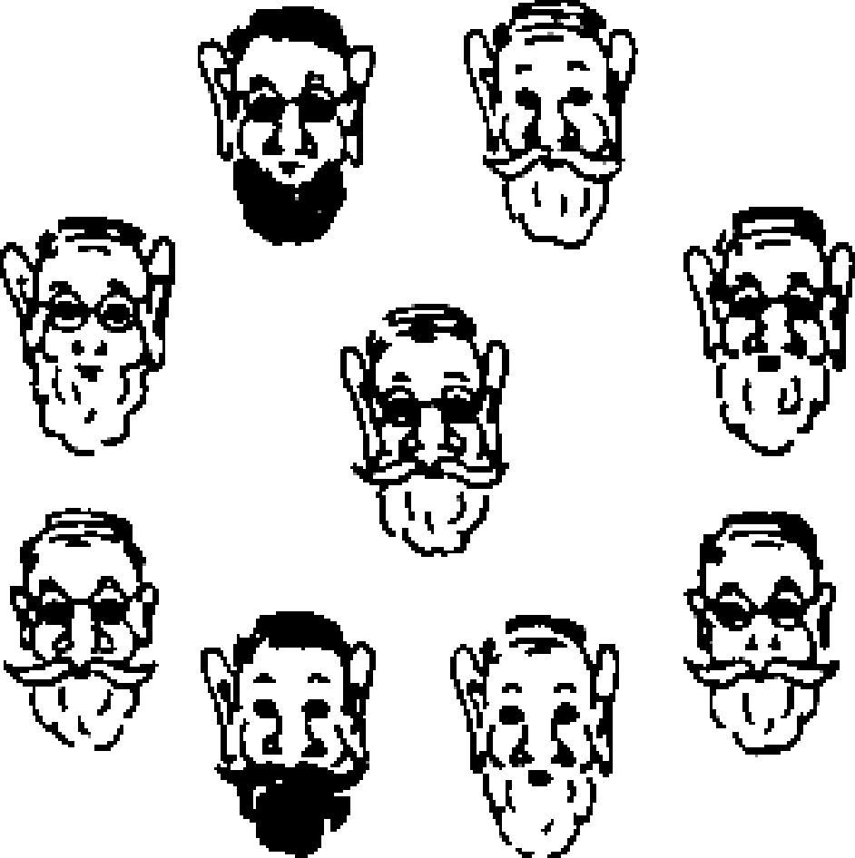

此图是以何种方式来说明家族相似性原则的？哪些属性是全部兄弟所共有的？

3．看一看Wierzbicka（1985：19-36）是如何解释CUP（杯子） 和MUG（茶缸） 的区别的，并说一说你认为她的说法是否说得通。Wierzbicka认为意义的不同可以归结为对各个物体有目的的使用的不同；用这一观点来说明这些范畴：VASE（花瓶） 、BOWL（碗） 和PLATE（盘子） 。

4．讨论作为GAME（游戏/比赛） 的全范畴属性地位的候选对象的“娱乐”、“除了游戏/比赛（game）之外没有别的目的”、“不确定的结果”和“由规则支配”之类的属性。想一想是否还有其他可能性并讨论可能的反例。

5．图标并不只是线条画。观察交通标志和一些在火车站、公共汽车站或机场里的标志，并解释一下它们是否利用了完形感知。它们传递了什么附加信息？

6．请一位或两位朋友画出小汽车、公共汽车、电话、书、瓶子、树、房子和教堂的简图。说一说完形心理规则在多大程度上适用于这些图画。观察这些对象的视角和有利的位置是否起作用呢？

7．就MURDER（谋杀 ）、MANSLAUGHTER（杀害 ）；VANDALISH（蓄意破坏 ）、LOOTING（抢劫 ）；ASSAULT（攻击 ）、ASSAULT AND BATTERY（人身攻击 ）；NEGLIGENCE（玩忽 ）、GROSS NEGLIGENCE（重大过失 ）这种法律范畴而言，说一说范畴化的正统观与原型模型对待这些范畴时的区别，当法官必须处理不明确的案例时，他面临什么问题？

8．在词义习得的语境中，Aitchison（2003：193）像俄罗斯心理学家Vygotsky所讨论过的那样，也描述了孩子对 qua（“quack”）这个词的使用情况：

孩子一开始把qua 当作池塘里的一只鸭子。然后液体这一因素引起了孩子的注意，推而广之用这个词来指一杯牛奶。但是鸭子并未被遗忘，并表现在用qua 这个词来指一枚印有鹰的硬币。但是后来孩子似乎又不管意义中与鸟有关的部分而只注意硬币的圆的形状，所以又把qua 这个词用来指玩具熊的眼睛。

讨论一下用家族相似性原则可以如何解释这个孩子收集到QUA这个范畴中的奇特组合。

## 1.3 语境依赖与文化模型

认知范畴的原型不是固定的，引入特定的语境，它们就可能发生变化；范畴边界也是这样。推而广之，范畴的整个内部结构似乎都依赖语境，在更广泛的意义上，依赖我们的社会与文化知识，人们认为，我们的社会与文化知识被组织进了认知和文化模型。

请读一下这个句子：He opened the door to face a pretty young woman with a dog in her arms （他打开门跟一位手里抱着一只狗的美丽少妇打了个照面），首先跳入你脑海的是哪种狗？会是德国狼狗还是牧羊犬（这两种狗可能是样本合格性等级中的原型狗）？或者你更倾向于认为是哈巴狗或其他种类的小个儿宠物狗？这些都是可能的选择。这个例子看起来也许是无关宏旨的，但对原型理论来说却有深远的意义。这说明原型远不像我们以为的那样是认知范畴固定的参照点，而是有随着语境的改变而发生变化的倾向。

### 原型和整个范畴内部结构的语境依赖

先从宠物狗这个例句说开去，我们通过一个小小的实验，把这个例句和与狗有关的其他例句作一番比较。请一个一个地念如下四个句子，在每个例句之后稍停片刻，看一看这个句子给你提示的是哪种狗：

1．The hunter took his gun，left the lodge and called his dog．（猎人拿起枪，离开小屋并叫上他的狗。）

2．Right from the start of the race the dogs began chasing the rabbit．（比赛一开始狗就开始追兔子。）

3．She took her dog to the salon to have its curls reset．（她把狗带到美容院给它打理卷毛。）

4．The policemen lined up with the dogs to face the rioters．（警察们带着狗排成一列面对暴徒。）

我们可以谨慎地假设，对4个句子中的每一句，你都将形成句中所表示的狗的不同意象。在例（1）的打猎语境中，最有可能的狗也许是某种猎狗；在例（2）的赛狗语境中，首先进入我们脑子里的当然是一只灰狗；就例（3）和例（4）而言，你可能会分别想像到卷毛小狗和德国狼狗。这些例子说明，什么最有可能成为某个范畴的成员，要依语境而定。因为我们可能预期原型是我们的第一选择，我们这个小实验说明，依靠语境，原型会变化。这样产生的“语境依赖”的范畴可能完全不同于在样本合格性等级实验中得出的非语境化的原型。

然而，就这些例子而言，不仅仅是原型变化这么简单。我们假定，在样本合格性试验中，＞ALSATIAN＜（＞德国狼狗＜）在等级上列为原型狗，＞GREYHOUND＜（＞灰狗＜）、＞SETTER＜（＞塞特猎狗＜）、＞POODLE＜（＞小卷毛狗＜）只是稍微没那么称得上原型。因为＞PEKINESE＜（＞哈巴狗＜）个儿小，脸儿平板、有某种“非狗的”举止，所以它可能是较边缘的狗。以这个范畴结构作为出发点，似乎很清楚的是上述句子不仅仅变换了原型。在一些实例中，语境依赖范畴的范畴结构比非语境化范畴的范畴结构要贫乏得多。例如，例句（2）与例句（3）的语境依赖的原型分别是＞GREYHOUND＜（＞灰狗＜）和＞POODLE＜（＞小卷毛狗＜）；就各种实际用途而言，几乎不可能是其他种类的狗，所以其他种类的狗只能是这一语境依赖范畴的极为边缘的成员。

与此相反，在例句（1）中，DOG（狗） 的内部范畴结构依然保持了更广的范围。人们当然可以想像出用作猎狗的德国狼狗或塞特猎狗。尽管如此，它们显然还是（HUNTING）DOG（（猎）狗） 这个语境依赖范畴中不如猎狗（retrievers）那么典型的成员。所以，样本合格性的不同等级原则在这一实例中依然有效，例（3）和例（4）的情形也一样。然而，问题的关键在于，语境依赖的范畴结构与在非语境化的样本合格性等级划分中得出的结构是不同的。总而言之，语境不但决定了范畴原型的选择，而且引起了其他范畴成员位置的调整。怎样才能使这一现象得到解释 <sup>(17)</sup> ？

有一个办法是用属性作为解释工具。正如1.2节所示，重要属性可用来解释范畴的典型性结构。从属性的角度来看，语境好像有两方面的作用：第一，语境改变与某种范畴有关的属性的重要性。那些在样本合格性等级划分和属性基础上的典型性等级划分中显得很关键的狗 范畴属性（如，“吠”、“有四条腿”、“高兴时摇尾巴”、“喜欢追猫”，等等），在特定的语境中明显地失去其重要性；第二，语境可以强调本不凸显的属性，甚至引入在非语境化的属性列举实验中根本不会提及的新属性。在猎狗这一语境中，像“拾回猎物”或者“指出被猎野兽的位置”这种属性的重要性增加了。在赛狗这一语境中，“有长而细的腿”、“跑得快”、“有耐力”和其他一些属性则变得至关重要。新属性的引入和对现存属性重要性的重新评估，完全改变了范畴成员的属性清单。其结果就是，那些原先的边缘样本被赋予更重要的属性而成为好样本甚至成为原型，而原已确定的好样本则降格为边缘成员。

### 语境、情境与认知模型

在认识到语境可以完全改组范畴结构中成员的位置关系之后，我们必然会提出语境是什么这一问题。这是一个相当难以理解的概念，却又是在语言学中用得最为广泛的术语之一，我们怎样才能把握它？

具有不同背景与怀着各种目的学者以很多方式给“语境”下过定义。从纯语言学的观点上看，语境被看作是一个词或句子之前和之后的语言材料。语言哲学家和语用学家，如最值得注意的Searle（1979：125），则把语境定义为理解一句话所必需的背景假设的集合。在话语取向的语言研究方法中，则把语境与一句话置于其中的情境联系起来。发端于人类学家Malinowski的研究，“语境”这一术语更是扩展到包括所谓的“文化语境”。Malinowski早在1923年就论证过，“情境语境”与“文化语境”对一句话或语篇的正确理解都是必要的（Halliday和Hasan 1989：5以次）。

对认知语言学家来说，重要的是应该把“语境”这一概念看作是心理现象。Langacker就强调这一要求，例如，他把认知域这一他的中心概念定义为“语义单位特征描述的语境”（1987a：147） <sup>(18)</sup> 。我们将在第4章讨论这种对“语境”非常全面的解释及Langacker理论中的其他基本原则。在这一节中，我们将试图提出一种更好把握但依然是认知的关于“语境”这个概念的看法。

要做到这一点，把“语境”（context）与“情境”（situation）及其他一些有关的概念区分开来是有益的。图1.13以例句“这个男孩正在用他的桶和铲子建一座沙城堡。” （The boy was building a sandcastle with his bucket and his spade. ）解释了我们对“语境”与“情境”这两个概念进行有意义的术语区分的建议。这个图表明，我们将把“语境”归入心理现象领域，而“情境”则用来指“真实世界”中事件的某种状态（考虑到哲学家对究竟是否存在“真实世界”这种事物这一点的长期争论，加在真实世界 上的引号是必要的。见阅读注释(6) ）。

如图1.13所示，我们把情境（situation） 这一术语定义为真实世界中物体的互动。在上文那个句子描写的示范性情境中，情境由四种物体组成，也就是一个男孩、一个沙城堡、一只水桶、一把铲子，它们通过男孩的活动而互动。听者或读者处理这个句子时，这些词会唤起相应的认知范畴，或更简单点儿说，是我们所具有的关于这个真实世界的物体的心理概念。另外，也形成了概念间互动的认知表征，正是因为这种认知表征，我们还会使用语境（context） 这一术语。在图1.13中，我们把例句的语境特点粗略地刻画为“正在建一座沙城堡”。应该强调的是，跟大多数语用的和/或社会语言学的语境 研究相反，我们的概念关注的焦点不是在其中造出话语（utterance）的言语事件，而是该话语描述的情境的认知表征 <sup>(19)</sup> 。

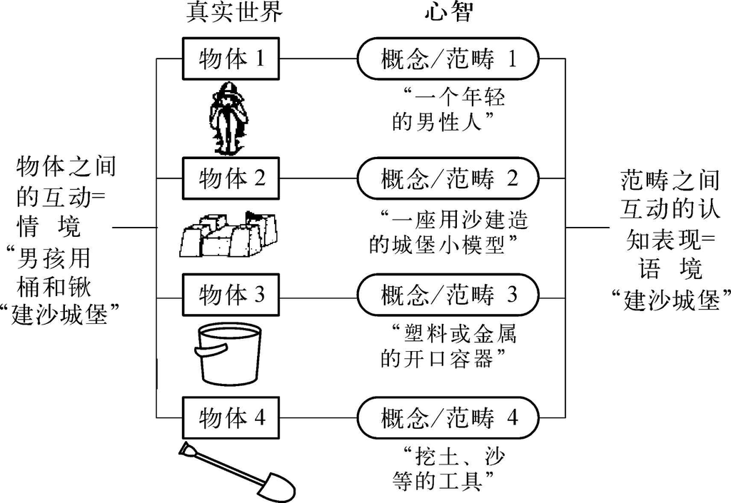

图1.13 “男孩正用水桶和铲子建一座沙城堡。”  
这个句子的“情境”与“语境”图示

当然，这种认知表征，或者说语境，并不会一直是孤立的心理体验，而是至少会以两种方式与储存于长期记忆中的有关知识直接地联系起来。一方面，再次提取关于有关范畴的特定语境知识 <sup>(20)</sup> 。这导致了这样的结果：把＞PLASTIC BUCKET＜（＞塑料桶＜）选为BUCKET（水桶） 这一依赖语境的范畴的最典型成员，而把＞CHILDREN'S SPADE＜（＞孩子的铲子＜）选为SPADE（铲子） 这一语境依赖范畴的最典型成员。

另一方面，当前处于活动状态的语境从长期记忆中唤起与之有着某种关系的其他语境。就我们的例子而言，除了上文的句子所表达的以外，还可能唤起关于沙与沙城堡其他方面的经验。与此有关的范畴，如WATER（水） 、HANDS（手） 、SHELL（贝壳） 、TURRET（塔楼） 或者MOAT（护城河） ，以及像“挖沙”或者“塑造塔楼”这种所有那些范畴间的频繁互动，都是这类关联语境很好的候选对象。

对于我们日常生活中所遇到的种种现象，我们已经体验并储存了大量的相互联系的语境，这是经得起推敲的。认知范畴不仅依靠它置身于其中的直接语境，而且依赖与直接语境相联系的整个语境集束。所以，拥有一个涵盖属于某一领域的所有储存起来的认知表征的术语，是相当有用的。我们将用认知模型（cognitive model） 这个术语来指称这些知识基础；其他有关的术语，如“框架”或者“脚本”，将在第5章中再次论及 <sup>(21)</sup> 。

图1.14表示的是“建筑沙城堡”这一语境有可能置于其中的两个认知模型（ON THE BEACH（在沙滩上 ）和ON THE SANDPIT（在沙坑里 ））中的一个。考察一下这个例子，认知模型的两个重要的特性就立即会变得很清楚。第一，正像图1.14中“其他语境”所表示的那样，认知模型基本上是无限的。这一特征的实际后果就是，一个认知域的认知模型非常难以描写，而且对认知模型的描写永远是不彻底的，却总是有很高的选择性。

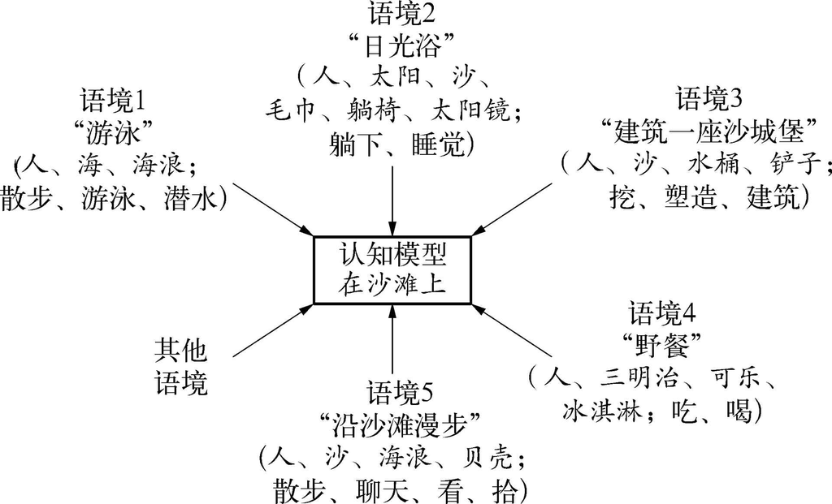

图1.14 认知模型ON THE BEACH的图示（括号中表示主要范畴和它们相互作用的方式）

第二，正像为认知模型建立基础的语境那样，认知模型本身也不是孤立的认知实体，而是相互联系的。就我们的例子而言，可以这样认为，人 （PEOPLE）、海 （SEA）、沙 （SAND）这些范畴及其他不断出现在不同的语境中的范畴组成了ON THE BEACH（在沙滩上）这一认知模型。因此，人、海和沙的认知模型与在沙滩上的模型存在着紧密的联系。与强调所谓“连接主义者”结构的心智理论相一致，人们可以认为，认知模型联合起来建立了网络 <sup>(22)</sup> 。这种趋势用图示可以得到最好解释。图1.15提出了一个网络的想法，这个网络包含通过多向联结相互联系的各种认知模型。

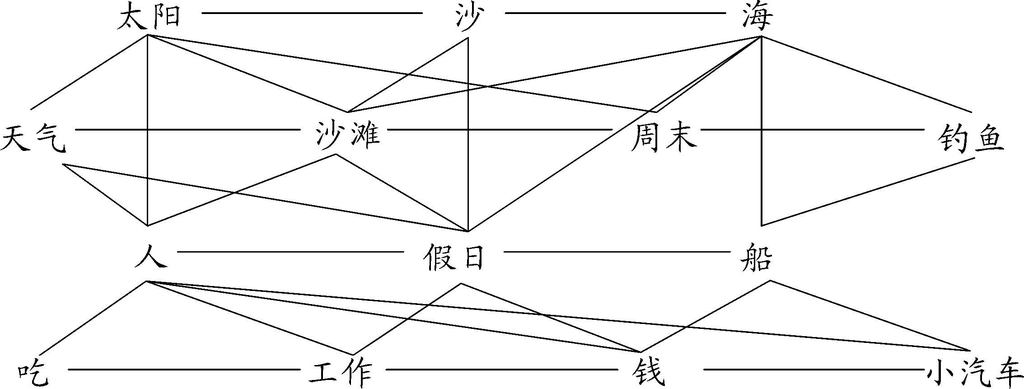

图1.15 认知模型网络例示

至此，认知模型的两个方面，即它们的不可穷尽性和建立网络的倾向性，已经从我们提供的具有代表性的图示中显现出来了。认知模型还有第三个特点，尽管不是那么明显，却也不应该忽视，也就是认知模型是无处不在这一事实。在每一次范畴化活动中，我们都或多或少有意识地提及一个或几个我们已经储存的认知模型。只有当我们遇到一个完全陌生的物体与情境时，在这种极个别的情况下，才会得不到适当的认知模型，但即使这个时候，我们也可能会试图回想起类似的经验并立即形成一个认知模型。设想一下一个到英国的外国游客平生头一回去看一场板球比赛。在这种情境中他没有可用的认知模型，所以他不会懂得球场上正在发生什么。尽管如此，这个游客也会试着把他所看见的跟类似的可能是关于一般比赛或关于他的垒球知识的认知模型联系起来。

那么，很显然，我们既不能避开认知模型的影响，也不能在没有它们的情况下进行我们的活动。即使在样本合格性等级划分这种相当人为的情境之中，要求被试划分等级的这种场合的认知模型也在起作用。所以，说这种实验是发生在一个未语境化的真空里，那将会出现误导。这些实验性情境产生的是非常中性的语境或者零语境，可以比作这类句子：When she looked out of the window she saw a …（朝窗外看时，她看见一个……） 或者She thought of the ..．（她想这个 ……）“没有认知模型的语言”这种意义上的未语境化语言显然是不可思议的。

### 文化模型

认知模型，正像该术语所表明的那样，表现了一种对关于某一领域储存知识的认知的、基本上是心理学上的看法。因为心理状态总是私人和个体的体验，所以对这种认知模型的描写必须包含非常高度的理想化。换言之，对认知模型的描写是基于这样的假设的：很多人对沙城堡与沙滩这种事物有着大致相似的基本知识。

然而，正如板球这个例子所表明的那样，这仅仅是问题的一个部分。认知模型当然不是普遍性的，而是由人们生于斯长于斯的文化决定的。文化给我们必须体验以便能形成认知模型的所有情境提供了背景。一个俄国人或德国人可能没有形成关于板球的认知模型，仅仅是因为进行那种比赛不是他们自己国家文化的组成部分。所以，特定领域的认知模型归根到底由所谓的文化模型（cultural models） 决定。反之，文化模型可看作是属于一个社团或亚社团的所有人共有的认知模型。

认知模型和文化模型本质上是一枚硬币的两面。“认知模型”这一术语强调这些认知实体的心理性质并考虑到了个体间的差异，而“文化模型”这一术语则强调了其为许多人集体共有的统一性的一面。尽管“认知模型”与认知语言学和心理语言学相联系而“文化模型”则属于社会语言学和人类学视角的语言学，但是，所有这些领域的学者，都应该而且通常会注意到他们研究对象的这两个方面。

我们以前提及的Malinowski的“文化语境”已经表明，把文化方面加入语言研究其实并不是最近的发明。然而，尽管文化背景长期以来就是社会语言学家和人类语言学家研究的重要部分，却只有少数语义学家不厌其烦地处理过这种问题 <sup>(23)</sup> 。下面我们讨论三个范畴样本，就这三个范畴样本而言，文化模型与对认知范畴及其结构的正确理解是密不可分的。

第一个例子是FIRST MEAL OF THE DAY（一天中的第一餐） 这个范畴的英国原型和法国原型。图1.16列举了这两个国家这一餐的原型属性。图1.16中的两个清单显示出这个范畴的法国原型和英国原型有多大的不同。法国的＞PETIT DEJEUNER＜（＞早餐＜）相当简单，只有一大碗咖啡和羊角面包，而英国的＞ENGLISH BREAKFAST＜（＞英国早餐＜）则包含各种各样的食品与饮料。因为法国的早餐用不着那么多杯盘、餐具和用餐的气氛，所以法国的宾馆并不提供早餐厅，而是用托盘把早餐端到卧室，或者请你到附近的咖啡馆或酒吧去用咖啡和羊角面包。相反，英国的早餐从不端到卧室，而是有早餐厅。此处的关键之处在于，两种早餐这么不同的原因反映了关于一天中各顿饭的作用和相互关系的不同文化模型。按照法国的MEALS OF THE DAY（一日各餐） 模型，早餐是次要的，因为他们认为中饭更实在而且接着有另一顿丰盛的晚餐。相反，英国关于这一点的文化模型的基础是丰盛的第一餐和最后一餐，而中饭或午餐则是相当微不足道的。

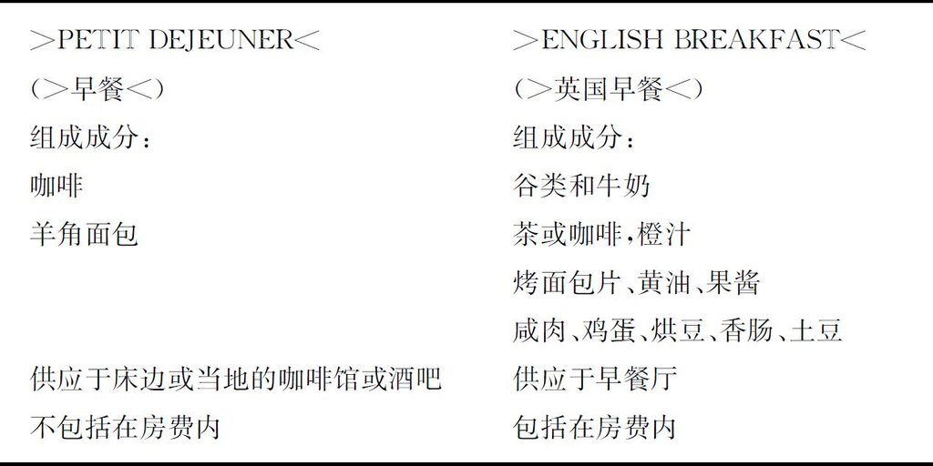

图1.16 范畴FIRST MEAL OF THE DAY（一天中的第一餐）在英语和法国的原型属性

这个例子还说明，文化模型不是静止而是变化着的。事实上，我们已经描写过的英国原型（早餐）在宾馆或B＆B（提供床位和早餐的旅馆）中可能还这样做，但再也不能认为这还是标准的日常家庭生活中的早餐。相反，许多以前提供以法国原型为模型的“欧陆早餐”（虽然通常把羊角面包换成别的东西）的大陆宾馆，现在也提供有着许多英国早餐特点的“自助早餐”。

当我们拿欧洲国家和日本或者中国的文化进行对比时，文化模型的差异以及这种差异对范畴结构的影响就变得更加明显。看看图1.17所画的物体。（a）和（b）代表的是欧洲传统的桌子，人们使用时，或者站着或者坐在椅子上。相反，以前在中国和日本写字是席地盘腿而坐或跪坐的。在这种传统的书写文化模型中，图1.17中物体（c）是桌子范畴的原型，而物体（a）和（b）将是相当边缘的范畴成员。然而，在现代交流的影响下，这种文化模型也正在发生变化。电脑和电信设备正消除传统的日本和中国文化中的书写模型，以使类似桌子 这类范畴适应“国际”的商业标准。

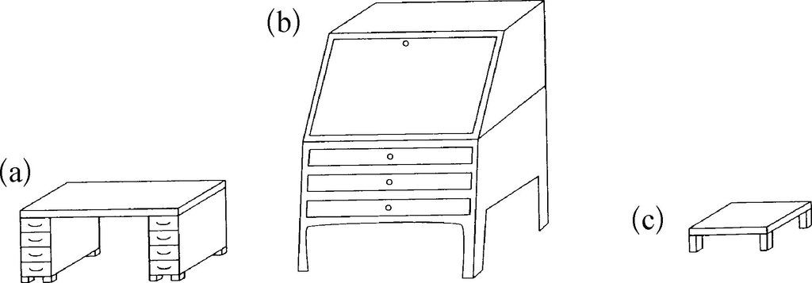

图1.17 桌子范畴的欧洲原型和传统日本原型图示（想法基于Lipka 1987：292，但有扩展）

下面这最后一个例子也许更有意思，因为它证明，即使在使用同一种语言和同样一些词的时候，也必须考虑到不同的文化模型。这种情况在像英语这种在世界上的许多地方使用的语言中相当常见。运用Rosch的样本合格性等级划分方法（参见1.1节和1.2节），Schmid和Kopatsch（待刊）表明，存在于尼日利亚北部的学生所说的英语日常用词中的概念结构与从美国两所大学得出的概念结构有天壤之别。英语是尼日利亚的官方语言，接受过高等教育的所有人都把它用作第二或第三语言。FOOD（食物） 是调查过的范畴之一。在这个实验中访问了尼日利亚北部的Maiduguri大学的75个尼日利亚学生和California的Santa Barbara、Massachusetts的Lexington的两所美国大学的74名学生。在实验中，要求被试根据一个由48个项目的食物组成的清单划出典型性等级。这个清单中的食物项目，不仅包括meat （肉） 、bread （面包） 、beans （豆） 或者pizza （比萨饼） 、chips （薯片） ，还包括millet （小米） 、yam （山药：一种类似于土豆的块茎）、cassava （木薯粉：用一种热带植物制的粉）和colanut （可乐豆：可乐树的种子，含咖啡因，在庆祝活动中具有重要的文化作用）。选出的部分结果见图1.18。

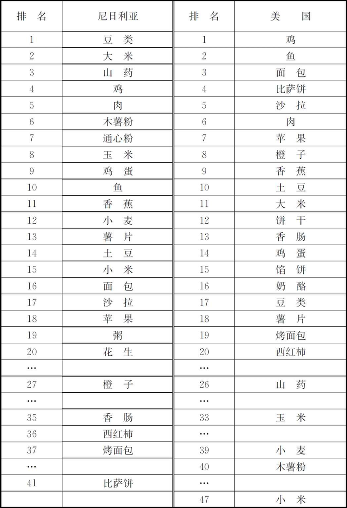

图1.18 尼日利亚和美国学生列出的FOOD（食物 ）范畴样本合格性等级的部分结果（自Schmid和Kopatsch，待刊）

尽管可以找到一些对应——比如鸡 和肉 有差不多的等级——但是，两份清单还是代表了遍存于两种文化中的截然不同的FOOD（食物） 认知模型的特点。那些在清单中领先的原型项目，读起来像每周餐饮计划，最突出地代表了美国餐桌特点的，有鸡 、鱼 、面包 、比萨饼 、沙拉 和肉 ，而代表尼日利亚人餐桌特点的，却是豆类 、大米 、山药 、鸡 、肉 和木薯粉 。苹果 、橙子 和香肠 这类普通的西方项目，美国学生把它们排在靠前的位置，在尼日利亚清单中却更低，而尼日利亚人的主要食物，特别是小米 、玉米 ，——在美国英语中无疑不是非常普通的词项——和小麦 这类基本的粮食在美国人的列表中则远远靠后，说明了美国与尼日利亚不同生活环境的巨大差异。

总之，这些例子说明，一种文化的成员所共有的认知模型相似，而不同于储存于来自其他文化的人们头脑中的认知模型。这些例子还表明，文化模型对范畴的概念结构有着巨大的影响。这不但在对（传统的）日本或中国文化与欧洲文化这种遥远的文化进行对比时是这样，而且也适用于英语的母语变种（如美国英语）和新英语（如尼日利亚英语）之间的关系。事实上，甚至英语的不同母语变种也受文化模型的影响：一项基于因特网的属性列举实验完全证明了这种假设：在美国，BUS（公共汽车） 得出了“黄色”、“学校”和“小孩/孩子”这类属性，而在英国，“红色”、“公共交通”和“工作”这些属性则更凸显，从而产生了BUS（公共汽车） 的不同的概念化 <sup>[2]</sup> 。

### 朴素模型和专家模型

因为是以我们对周围现象的日常经验为基础的，文化模型可能包含从严格科学意义上来说是有疑问甚至是不准确的假设。例如，狗摇尾巴表示“我很快乐”，而咆哮则意味着“我很生气”，这是我们关于“狗”的文化模型的组成部分。而当猫呼噜作响时被认为是在自得其乐。对动物学家或生物学家来说，所有这些信条都是非常可疑的，因为谁也不知道动物是否真的有人类意义上的感情。在他们的以严格的科学事实和逻辑规则为基础的专家模型中，这类假设是站不住脚的。而在另一方面，朴素的文化模型是以不正规的观察、传统的信条、甚至是以迷信为基础的，并因此也被称为“民间模型”。

因为显而易见的原因，科学地建立的专家模型和外行的朴素模型之间在科学和技术领域的分歧就显得特别引人注目。以移动这一物理现象的朴素模型为例来考察。McCloskey（1983）进行了一些实验和访谈，以诱导出流行于美国的关于移动的文化模型。他请被试想像有一架在恒定高度匀速飞行的飞机。另外，被试应该假设在飞行过程中的某一点有一个大金属球从飞机上掉下来，而飞机则按同样的速度、高度、方向继续飞行。被试的任务是画出金属球从掉落到触及地面的轨迹，风和空气的阻力忽略不计。金属球最后与飞机的位置关系也应该表示出来。在你继续读下去之前，你也许应该自己试着完成这个任务，也就是你自己画出飞机和金属球的轨迹。

现在，把你画出的轨迹与对这个问题的科学上的正确答案对比一下。物理学家告诉我们，金属球将以抛物线降落并正好在飞机同一时间到达的下面的那个点上触及地面。金属球之所以划出这种轨迹，是因为它在获得均匀的垂直加速度的同时，将继续以跟飞机一样的速度水平移动。

如果你画的轨迹与科学解释不吻合，你和在被试中占60％的多数是一样的，因为，在McCloskey的实验中，只有不到40％的被试作出了在科学上正确的回答。大多数被试认为金属球会走不同的路线（比如，它会直线掉下或以斜线降落），这揭示了一种不同于通行于物理学的专家模型的关于移动的朴素文化模型。

这个实验所表明的是，大多数人所持有的文化模型，不一定，并且也常常不与专家拥有的客观上可以证明的科学知识相一致。如果我们认为文化模型的基础是一个社会或社团的集体经验，那么这一点也就不足为奇了。过日常生活，外行不需要科学上正确的模型，而只需要功能上有效的模型。这就意味着只要一个模型符合我们的感知并能作出功能上正确的预测，那么，即使它可能在技术上是不准确的，也可能广泛流行。

另一个很有启发性的例子是Kempton（1987）提供的。她在通过访谈和行为记录研究关于家庭取暖调节或者自动调温器的美国文化模型时，发现两个相互冲突的理论。

一是反馈理论，认为自动调温器感应温度并打开、关上取暖炉以保持稳定的温度。另一种，我把它叫做阀门理论，认为自动调温器控制热量。也就是说，就像煤气炉或水阀，调得越高的也就产生越大的流量。

（Kempton 1987：224）

反馈理论在技术上是正确的，而阀门理论却错了。关于这两理论特别有意思的是，即使阀门理论错了，它还是能让我们对一座房子里的温度控制作出正确的预测，所以外行也就没有任何理由不赞同这一理论。

这样一来，情况似乎是这样的：许多朴素的文化模型，特别是在科学与技术领域，从科学观点上看是不准确的，而就其功能预测而言却又通常是正确的。在日常生活的其他领域，模型的准确性问题并不是那么重要。例如，尽管我们可以为所有的领域找到具有特别精确的认知模型的专家，而对于沙城堡、沙滩、桌子 和早餐 这些我们在这一节中为举例说明的目的而选出的文化模型，去谈论正确或不准确的模型将是不合适的。重要的是，“普通”的日常经验并不遵循为科学研究设置的教条和形式逻辑的规则，在其背后却有别的，更纯粹认知的规则，其中的有些规则我们将在下面的第3章和第4章讨论。

我们对在这儿已经提出的几个主要问题作一小结来结束本节的讨论：

· 认知范畴相互作用、相互影响，这会引起范畴原型、边界和整个范畴结构发生变化。

· 除了范畴在其中使用的实际语境之外，范畴的内部结构还由处理语言时总是出现的认知与文化模型决定。

· 对于一个与众不同的语境依赖范畴观来说，区分一些术语似乎是必要的。因此，我们已经把下列术语定义为

— 情境 ：真实世界中物体的相互作用；

— 语境 ：认知范畴（或者概念）之间相互作用的认知表征；

— 认知模型 ：个体对特定领域经验过并且储存起来的语境的总和；

— 文化模型 ：一种对认知模型的看法，强调这些认知模型主观间地（intersubjectively）为一个社会或一个社团的成员所共有。

·“朴素”的文化模型，特别是对于那些技术领域来说，不必合乎专家的科学上精确的知识，却可以建立在公共经验的基础上，严格地说，甚至可以建立在“错误”的假设的基础之上。尽管如此，只要这些朴素文化模型作出的功能预测是正确的，它们就能为一个社会的大多数外行所共有。

### 练习

1．在语用学和社会语言学中，言语事件的参与者常常被看作是更广的“情境语境”的组成部分。联系本章提出的语境概念，讨论一下这种“语境”概念。

2．像CAR（小汽车） 这种物体范畴的特点可以刻画为跟它们的形状、大小、质料、组成部分、功能相关的属性，还有它们引起的联想与感情。讨论一下当语境（比如从一般交通语境到赛车语境）改变时，这些属性中哪一种更容易改变其“分量”。

3．重复1.1节练习5中的两步试验。在联想和样本合格性等级划分任务之前，给出这样的特殊语境：The estate agent climbed out of his ..．（Jaguar，Rolls Royce，BMW，Mercedes，etc.） （房地产经纪人从他的……（美洲虎、劳斯莱斯、宝马、马自达，等）钻了出来。） 或者The children loved to climb the ..．（apple tree，pear tree，cherry tree，ect.）in the orchard （这些孩子喜欢在果园里爬……（苹果树、梨树、樱桃树，等等））

4．爱斯基摩人有很多词用来表示不同种类的雪，阿波利津人（澳大利亚土著）有很多词用来表示不同种类的沙，在阿拉伯语中你则必须对包含在西方的CAMEL（骆驼） 这一范畴中的一系列词作出选择（参照Lyons 1981：67）。你能否依靠“文化模型”这一概念的帮助来解释这一现象？

5．比较BACHELOR（单身汉） 这一文化模型和它显而易见的对应者SPINSTER（老处女） 。讨论类似的例子：GENTLEMAN-LADY（绅士—太太） 、MASTER-MISTRESS（主人—女主人） 和BOY-GIRL（男孩—女孩） 。

6．当要求尼日利亚和美国学生列举TOMATO（西红柿） 的属性时，产生了下面的调查结果（Schmid ＆ Kopatsch，待刊）：

尼日利亚被试：“用来炖肉、做汤”61％；“（成熟时）红色”54％；“在农场/花园里种植/生长”50％；“圆形”29％；“叶子”29％；“水果”25％；“根”18％；“一种蔬菜”18％。

美国被试：“（成熟时）红色”88％；“水果”72％；“蔬菜”60％；“沙拉”55％；“（未成熟时）绿色”49％；“种子”49％；“酱”45％；“多汁”45％；“圆形”45％；“意大利通心粉/意大利面条”28％；“比萨饼”19％；“汤”17％；“植物”17％；“三明治”15％；“切片”15％。

根据先前提到的文化模型你从这些结果中可以得到什么结论？

7．问一下你的朋友和家里人，他们是怎样设想个人电脑的部件执行的各种程序的，并从他们的回答中得出朴素文化模型。如果你正好是这方面的专家，比较一下朴素模型与专家模型。

8．可以认为，只要朴素文化模型作出正确的预测，就被认为是有效的。找出语言中反映这种错误或过时的朴素模型的例子，如the sun rises in the east （太阳从东方升起） （当然是地球转动）或者the apple fell to the ground （苹果掉到地上） （它是被地心引力所吸引）。讨论所谓的俗语源学的例子，如把asparagus （芦笋） 说成sparrow-grass ，把chausée （公路） 说成causeway ，把ucumber （黄瓜） 说成cowcumber ，还有这些复合词：crayfish （小龙虾） 、starfish （海星） 、jellyfish （水母） 。

### 建议进一步阅读

1.1节

对早期范畴化研究的全面评述，见Lakoff（1987：第2章）和Taylor（2003：第3章第2节）。Kleiber（1998）讨论了原型理论的发展，但是在相当抽象的层次上讨论的。Rosch（1978）中有关于Rosch对这个领域重要贡献的最简要的说明。Rosch（1988）是从她自己的观点出发对早期原型理论的非正式回顾，无疑值得一读。Cruse（2000：130-140）、Croft和Cruse（2004：74-91）提供了对范畴化的最新的简要说明及对原型理论的批评。Geeraerts（1997）考察了原型理论在解释意义的历时演变时的作用。

(1) Ullmann（1962：116-128）以许多不同语言的例子讨论了含糊（vagueness）的来源。Quine（1960：125f）从哲学角度就含糊（vagueness）提出了一些有趣的思想。从认知角度讨论这一问题的更近发表的著作有Geeraerts（1993）和Tuggy（1993）。对模糊这一概念的批评，见Croft和Cruse（2004：93-95）。

(2) Lakoff（1987：第18章）较详细地讨论了Whorf和相对主义。相对主义者理论的更广的哲学含义见Putnam（1981：103-126，特别是119-124）。认知语言学家对Whorf理论的进一步的兴趣，见Niemeier编的论文集和Dirven（2000）、Pütz（2000）。

(3) Berlin和Kay（1969：1-5，14以次；数次重印）的引言部分当然值得一读。对Berlin和Kay（1969）各种反应的简明概述见Taylor（2003：9以次）。Kay和McDaniel（1978）提出了支持Berlin和Kay的部分观点的神经心理学数据。关于基本颜色语汇的演变，亦见Kay（1999）。

(4) Smith和Medin（1981）提供了对各种范畴化理论的研究。Clark和Clark（1977）虽然不是最新的心理语言学课本，但对范畴化的基础心理学和心理语言学方面仍然是有用的。Medin、Ross和Markmen（2001，第10章）对原型理论持批评的态度，在我们这一章作了介绍。Aitchison（2003）则专注于范畴在“心理词库”的储存。

(5) 直到1972年，E．Rosch用她以前的名字Heider发表著作。所以Heider（1971，1972）与Heider和Oliver（1972）和参考书目中Rosch名下的论著出自同一作者之手。

(6) 想知道现实主义、唯名论和概念论的最初观点，也就是关于世界状况的理论，Lyons（1977：109以次）是很有帮助的。现实主义者-概念主义者模型的讨论，Johnson（1987：第8章）、Lakoff（1987：第16章）和Lakoff及Johnson（1999，第6章、第7章）提供了在认知语言学范式之下进一步思考的基础，这几章有些部分都以Putnam（1981：特别是第3章）为基础，相当精彩却也相当不易读。

(7) 作为后来的文章，Labov（1978）更为全面；但是，这些进展主要关注模糊性形式化中的数学技术。

(8) 在结构主义传统中讨论多义词及其与同音词的区别问题，见Lyons（1977：550以次）、Leech（1981：227以次）、Lipka（2002：152-157）。从原型角度对多义词作词典编辑上的处理，见Geeraerts（1990）。

1.2节

(9) 对范畴的正统观的心理学角度的说明，见Smith and Medin（1981：第3章）；语言学和哲学的角度的描写，见Lakoff（1987：第11章）。Lakoff（1987）也有一章（第9章）讨论“正统观的捍卫者”，事实上则起到了捍卫他自己的范畴原型观的作用。关于“本质特征”这一概念，Katzt和Postal（1964：第2章）则是这方面的杰作。Wierzbicka（1985）大大地扩展了本质特征这一概念，并对生命体和日常物品作出了有趣但非常详细的特征定义。Lipka（2002：114-134）作了简明的介绍，也综合了非必要特征。Croft和Cruse（2004：76-82）也有一个简短的概述。

(10) 对使用的统计学方法的详细说明见Rosch和Mervis（1975）和Rosch等（1976）。这些文章也很有意思，因为“信号有效性”这一统计学概念被引入用来衡量我们所说的属性基础上的等级划分。Smith ＆ Medin（1981：78以次）和Geeraerts（1988a）中有一些解释性说明。

(11) 用UNCLE（叔叔） 这一范畴来说明相似的范畴化观点，见Langacker（1987a：19以次）。

(12) 关于完形心理学的主要内容的大部分著作，仍可以找到Wertheimer、Köhler和Koffkar的重印本。“完形”（gestalt）、“完整性”（Prägnanz）和“完形规则”的最早来源，见Koffka（1935；2002年重版）；Köhler重版于1990年代（Köhler 1992），而Wertheimer则是最近出版的一本书（King和Wertheimer 2005）的主题。完形心理学的更具理论色彩方面的最新研究，见Gordon（2004，第2章）。

(13) 部分-整体关系的其他意义将在2.3和3.1中讨论。参考文献见第2章的阅读注释11和第3章的阅读注释9。

(14) Stein（1991）和Lipka（1995）讨论过词典中的图示说明，但他们是从词典编辑学的角度而不是从认知语言学的角度上来讨论的。对用“模板”来进行形状感知的心理学研究的说明，见Smith和Medin（1981：第6章）、Medin和Ross及Markman（2001：104-108）。

(15) Atchison（2003）对心理词库实证性和理论性的研究方法的概观令人大开眼界，它主要的基础是语言学和心理语言学的著作。从心理学观点来进行的批评性讨论，见Smith（1978）。

(16) 关于如何解释典型性效果的意见随着原型模型的发展而改变。Rosch后来的观点，见Rosch（1978）和（1988）。对这个问题更广泛的讨论，见Lakoff（1987：40以次和第9章）和Kleiber（1998）。这些文本和Croft ＆ Cruse（2004：79以次），包括了对样本合格性和范畴成员身份等级之间区别的讨论，这与本书的框架无关，因为我们主要依靠以日常民间模型为基础的认知范畴，而不是科学的分类。Geeraerts认为，原型性本身应该看作是原型概念（1988a）并讨论了原型性的潜在来源（1988b）。

1.3节

正如在文中提到的那样，语境概念在不同的学科都有悠久的研究传统。Schmid（2003）有一个非常简要的概述。Bouquet等（1999）和Akman等（2001）是两本新的讨论语境的跨学科的论文集。

(17) 原型和范畴结构的语境依赖的实证检验，见Roth和Shoben（1983），他们研究了像The bird walked across the barnyard （鸟走过谷仓前的院子） 这类句子对BIRD（鸟） 这一范畴的内部结构的影响。

(18) 把语境看作“当前语篇空间”的一部分的不同观点，见Langacker（2001：144）。

(19) 就我们所知，与我们对术语“语境”和“情境”的观念最近似的是van Dijk（1981：222、269及其他各处），他强调认知语境的选择性和具有抽象能力的性质。他的更新的关于语境的认知主义者和主观主义者的观点，见van Dijk（1999：142）。

(20) Barsalou（1982）试图为范畴中语境依赖和语境独立信息之间的区别提供实验支持。

(21) Dirven、Frank和Pütz（2003）是最新的讨论语言和思维中的认知模型及其与意识形态之间关系的论文集。大致符合我们的“认知模型”概念的观点，见：Johnson（1987：特别是28等、101以次）论“意象图式”；Lakoff（1987：68以次、118以次）论“理想的认知模型”；Gentner和Steven（1983）与Johnson-Laird（1983）论“心理模型”；Holland及Quinn（1987）论“文化”和“民间模型”。Langacker的“认知域”概念将在第4章4.3节中讨论，“框架”这一概念将在第5章5.1节中讨论。

(22) Bechtel和Abrahamsen（2002）提供了很好的心理的连接主义理论的介绍。

(23) 对通行于英国和欧洲大陆的文化模型之间的差别感兴趣的说德语的读者，Leisi（1985：87以次）是非常有趣而易读的资料。他讨论了ACADEMIC FIELD （学术界） 、HOUSEHOLD ITEMS （家庭用品） 、FOOD（食物） 、SPORTS（体育运动） 这些领域的英国模型。

[1] 在每一章的后面给出了进一步阅读的建议。

[2] 我们的这些成果受惠于Elisabeth Friedrich，Bayreuth。

# 第二章 范畴化层次

## 2.1 生物体和具体物体的基本层次范畴

科学分类因其复杂性和严格性也许是富有魅力，但它们是否真的适合于人类范畴化呢？所谓的民间分类法认为，我们以中心部分为起点得到不同的分类层级，我们把注意力集中在狗和汽车这样的基本层次范畴上，而分类的层级也以这种基本层次范畴作为基点。

让我们重新看一下第一章开头所刻画的对这个世界的朴素的看法。这种看法认为，总体上说，我们周围都是些容易识别的生物体和物体，如狗、树、房屋、汽车，等等。但是对这些实体进行范畴化的时候，一般来讲，我们会在具有在普遍性上程度不同的范畴之间作出选择。因此我们会把舒展身子躺在壁炉前小地毯上的生物看作“狗”、“小猎犬”、“苏格兰小猎犬”，或者，从更具理论色彩的角度上，把它看作“哺乳动物”或“动物”。显然，所有这些认知范畴都是以一种上下位层级关系联系起来的。狗被看作是小猎犬的上位概念，小猎犬又是苏格兰小猎犬和斗牛犬的上位概念；在另一个方向上，狗被认为是哺乳动物的下位概念，哺乳动物又是动物的下位概念。

存在于这种等级结构中的原则，是种类包含（class inclusion） 概念，它认为，上位类包括下位层次的所有项目。“动物”这个类不仅包括哺乳动物，还包括鸟类和爬行类动物。在下一个层次里，“哺乳动物”类不仅包括狗，还包括猫、牛、狮、象、鼠。在更下一层，“狗”类包括小猎犬、斗牛犬、阿尔萨斯狗、狮子狗等其他多种狗。如果从下往上看，种类包含看起来像是一种类属关系（type-of relationship） ：小猎犬是一种狗，狗是一种哺乳动物，哺乳动物是一种动物。类似的层级也同样适用于交通工具这种人造物体，它包括汽车、货车、自行车、雪橇及其各自的下位分类。总之，世界上的所有具体实体似乎都可以按照种类包含原则进行层级排列。从层级观念出发，许多科学领域中发展出来的详细的分类（或分类法taxonomies ）都是基本的人类范畴化能力的扩展。

### 科学分类

范围更广，并且与我们语言学所关注的问题关系更近的，是Mark Roget在他初版于1852年，现在还在广泛使用的《英语词和短语辞典》里提出的分类法。这位具有广泛的科学兴趣的物理学家兼作家，以一种科学的严谨性来实现把人类的知识组织起来的古老的梦想。世界的知识被分为六个“类”，这些类又严格地依次分成门、目和更下位的类。这种体系的局部，图示于图2.1，他的想法具有里程碑意义 <sup>(2)</sup> 。

这些分类法具有这样的共同点，那就是，除了它们的种类包含的观点外，它们至少在两个方面似乎不符合人类的心理。首先，科学分类法包含的层次简直太多了。一般来讲，建立这种科学分类法的唯一目的，在于将现有的“物体”，即世界上发现的两百多万种动物和植物，或一种语言的数十万个词语进行分类。如果在分类过程中需要扩大分类框架，就会引进新的层次和下位层次，而不管这个分类法会变得多么庞杂。

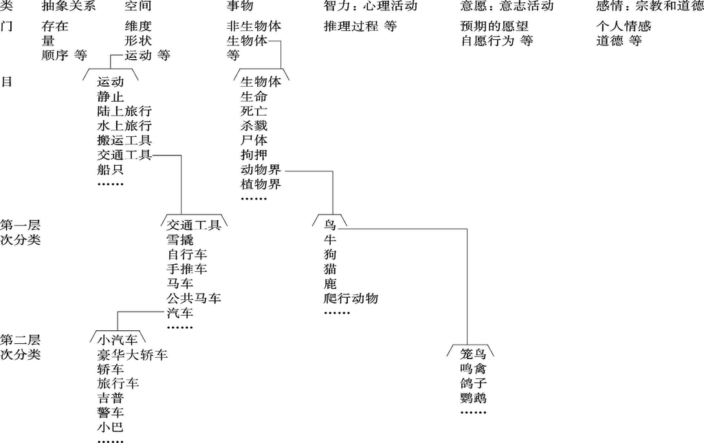

图2.1 Roget的分类系统节选（根据Betty Kirkpatrick 1987改编）

科学分类除了太复杂以外，还没有考虑到我们总是与世界上我们周围的生物体和物体接触和融合这种事实。这种互动的结果是，生物体和物体在我们的眼里得到评价并赋以不同程度的重要性。与这种主观判断相反，科学分类追求尽可能的客观；它们并不对被分类的一个项目或某一分类层次有所偏好。再看一下图2.1，会发现汽车是如何跟手推车和雪橇一起多多少少是藏在了第四层次中的某一处的。至于动物，所有重要种类都是“动物”下位类，而动物又与“尸体”、“内脏”排列在一起。如果要说的确有某一层次比其他层次引起更多的注意的话，那可能是最高层次和最低层次，因为这两个层次位于层级边界最显著的位置上。

但是，对认知范畴及其名称的用法和习得的观察似乎表明，中间层次同样重要（如果不是更重要的话）。说到底，就壁炉前小地毯上的生物来说，最自然选择的认知范畴可能是DOG（狗） ，而不是SCOTCH TERRIER（苏格兰小猎犬） 或者ANIMAL（动物） ，更不用说MAMMAL（哺乳动物） 了。人们描写交通事故时，可能这样开场：“两辆车（cars）相撞。”而不会说“两个交通工具”，或“一辆旅行车和一辆吉普车”。这表明，在中性语境，或者在谈话中引入新项目时，说话人总是优先选择狗和车这样的范畴名称。此外，孩子最先学的，也是狗、猪、汽车、卡车等中间层次的范畴名称，在层级中，这些名称通常也是最短的，使用也最频繁（Brown 1958，1965）。这些词汇上的证据似乎让分类应该客观这种观点失效了。

总之，科学分类似乎既不以心理为依据，也不以心理为导向。问题是，与主观有关的把我们的世界知识组织起来的其他方法会是什么样的。这种方法必须说明普通的人类心理能力及其极限，必须符合人类的经验、基本需求和兴趣。但是因为逻辑分类法对现代西方思想一直产生着巨大的影响，所以，受西方传统教育的任何一个人都难以想像到这样一种方法。因此，为了对“自然”层级结构有一个公正的认知评价，我们必须（正如在第一章中的焦点色和原型的例子那样）离开西方文化的范围来研究“前科学”社会中的分类法。

### Tzeltal人的植物分类：民间分类实例研究

现有的最详细的非科学分类报告是关于Tzeltal人的植物分类的描写。Tzeltal人是南墨西哥说玛雅语的一个族群。这种分类法是Brent Berlin与植物学者Dennis Breedlove和Peter Raven提供的 <sup>(3)</sup> 。他们的研究课题（Berlin等 1974）的主要目的是分析Tzeltal人为了对他们生活环境中的植物的分类和命名而使用的“民间分类法”，讨论这种分类法与西方科学分类有着怎么样的关系。 图2.2表现了他们分类的一些结果。除了明显地降低了分类上的复杂性以外（在科学分类的13个主要层次当中，在Tzetal植物分类中只保留了5个），图2.2中最引人注目的是所谓的属层次（generic level） 的多数地位，这个层次总共至少包含了471个范畴。相反，上位范畴，即所谓“生命形式”（第二层次）项目的数量却少得可怜，仅包含了4种植物的名称。在更下位的层次里，尽管“种”层次（第四层次）的成员身份比在属层次上受到更多的限制，却也相对而言较好地得到了体现，而变种层次（第五层次）上的次类则又是微不足道的。

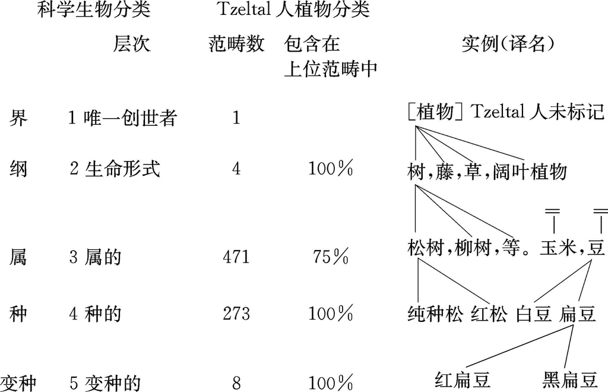

图2.2 Tzeltal人植物分类（局部）

属层次范畴在数量上的多数地位得到了它们在语言和文化上的重要性的支持。属层次上的认知范畴不但数量最多，而且即使有更高或更低层次的范畴可供选择，它们也是Tzeltal人最常选择的范畴，这意味着它们的名称首先出现在脑子里。因此，某种松树更可能被称为“松树”而不被称为“树”或“红松”（就松树而言，Tzeltal语的确如此，而英语则不一定，正如我们会看到的那样。）还有，属层次范畴的Tzeltal语名称往往是很短而不可再分析的词位（lexeme），而更低的层次的名称一般由形容词+属名称组成，我们的英语翻译也是这样。比较一下“松树”和“红松”，或更复杂的例子，如，“豆”（属）、“扁豆”（种）和“黑扁豆”（变种）。所有这些发现都在很大程度上证明我们以前关于在西方文化里中间层次在等级上具有突出地位的说法。因此，来自英语和Tzeltal语的证据证明了在分类法中属层次或中间层次的特殊地位。

调查一下在Tzeltal人的植物分类中属层次在文化上的重要性，来检验一下这种分类法是如何把握种类包含原则（或类属关系），是很有启发意义的。这种种类包含原则似乎体现了科学的层级概念之本质。如图2.2所示，在各自的上位范畴里，范畴包含的程度为100％，但属层次则是个显著的例外，其范畴包含程度只有75％。这意味着Tzeltal语四分之三的属层次项目与生命形式明显有关。对Berlin等人而言，这证明种类包含原则也适用于民间分类法，而且这种判断此后被许多研究者心照不宣地接受下来。但是，剩下25％的“不听话的实例”并不只是由两种可能的生命形式之间的边界上的实例组成的。属层次的97个范畴，或者说20％被发现是“非隶属类的”，这说明在Tzeltal人的眼里它们与任何上位层次的生命形式都没有关系。这些“例外”因为具有“经济重要性”和“文化重要性”，在事实上成了这种分类法中最有趣的部分（Berlin等1974：24，96）。比如说，这些实例中就有玉米和豆，当然，它们也正是Tzeltal人食谱中两个基本的成分。

从这些观察结果中可以得出的结论，在我们的属层次特征集上增加了非常重要的一点。就如CORN（玉米） 和BEAN（豆） 这种范畴所表明的那样，属层次之所以突显，最重要的似乎是因为它具有文化上的重要性；这种突显有时候甚至是植根于生物学上的需要。换句话说，属层次的范畴表征了偏好的认知视角。它们似乎满足了“基本”的认知需求，因为它们指明了人类兴趣焦点之所在。根据属层次范畴在等级里的位置，可以说属层次范畴具有“分类的中心地位”特征（请不要把这种中心特征与原型的范畴内中心混淆起来）。

概括地说，对一种民间分类法的人类学研究产生了许多有趣的文化和语言上的发现，这些发现意味着属层次具有经验上的首要和中心地位：

· 民间分类法将焦点置于属层次上，这是因为属层次在文化上常常是突出的，并且有时候直接植根于基本的生物学上的需要。

· 属范畴的名称在人类互动中易得：这些名称在命名情境时最先出现在脑子里，它的形态结构也是简单的。

· 非属层次似乎具有从属的地位，这是因为它们没有得到完全的发展，在这一层次上没有必要进一步分类。

### 基本层次范畴：心理因素

如何才能证明我们关于属层次的中心地位符合“我们的基本认知需要”的观点？Berlin等学者的人类学证据虽然可能是完备而详尽的，但它毕竟只源于单个民间分类法的个案研究。因此我们有必要回顾属层次（或者心理学上所谓的基本层次（basic level） ）的心理学背景，并考察一下相关的实验结果。

如果总结一下Roger Brown和Paul Kay的早期解释，追根溯源，基本层次的重要性和中心地位可能主要涉及三个因素（Brown 1958，1965；Kay 1971）。

第一，属层次或基本层次是我们感知世界上的生物体和物体之间最明显差异之所在。我们先看看范畴的较低层次和较高层次，这一点就会更清楚。ALSATIAN（阿尔萨斯狗） 、COLLIE（牧羊狗） 、GREYHOUND（灰狗） 这些下位层次范畴，每个都包括与相邻范畴中的项目非常相像的范畴项目。例如，阿尔萨斯狗、牧羊狗、灰狗中所有的狗在高兴的时候都要摆尾巴，都吠叫，也都喜欢追赶猫和邮递员。因此区分这种范畴，可能看起来近乎迂腐。而另一方面，上位范畴ANIMAL（动物） 包括迥然不同的许多项目（大象、老鼠、鲸鱼），它们之间的相似性的确很少。在这种背景下，则DOG（狗） 这种基本层次范畴似乎找到了一种折中方案。每一种狗显示出与其他种类的狗大量的相似性，但是所有的狗都因那些看似“狗性”的特征（吠叫、摇尾之类）而与猫、狮子等区别开来。换句话说，认知范畴DOG（狗） 和基本层次在总体上通常“符合自然中最显著的离散性”（Kay 1971：878）。

从属性上考虑，有可能作出更专业的解释；这些属性，正如1.2节所表明的那样，可以理解为表现了相似性关系。考虑到这一点，基本层次范畴在内部相似性和外部区别性之间达到理想的平衡这种主张，现在就可以换一种说法，而用属性来说明：基本层次是这样一种层次，在这个层次上，可得到最多的分类所需的自然地相互联系的属性集束（例如，所有表示“狗性”和“椅子特性”的属性）。这些属性集可以说被指派给某一认知范畴（如，DOG（狗） 和CHAIR（椅子） ）中的成员，并根据这些成员的样本合格性地位，与现实世界中像狗的生物和像椅子的物体对号入座；同时，这些属性集束把这些范畴与其他范畴区别开来。对照一下图2.3，图中基本层次范畴CHAIR（椅子） 和TABLE（桌子） 所具有的属性，都用线条图式化地表现出来了。

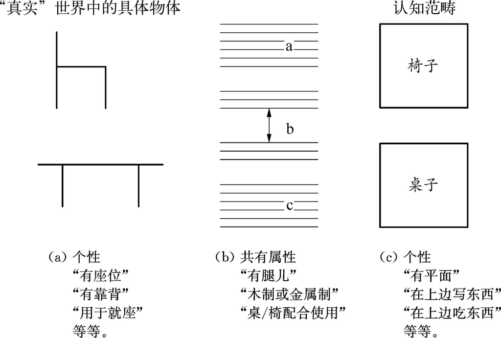

图2.3 基本层次范畴CHAIR（椅子）和TABLE（桌子）的属性图示

如图2.3所示，两个认知范畴都各自拥有一个很大的属性集束，这些属性集束各自适用于大多数椅子和桌子。因此，所有种类的椅子（厨房椅子、客厅椅子、花园椅子）都会符合“有座位、有靠背、用于就座”这些属性。只有某些属性会为两个范畴所共有，例如“有腿”、“木制”（在图中这种属性以箭头连接），而大部分属性不是这样，这也反映了我们区分椅子和桌子时容易的程度。

然而，因为属性传达信息，另一种看法似乎也是可能的。如相关性概念所暗示的那样，在基本层次上可得到的属性集束已被预先分类，并且已经被很方便地连接起来，因而更易于理解。因此，可以这样说，基本层次是以最小的认知努力而能取得关于一个项目的最大量信息的地方。这种原则被称为认知经济性（cognitive economy） 原则，这一原则有可能完美地解释为什么基本层次特别适合于满足我们的认知需要 <sup>(4)</sup> 。

另两个被认为与基本层次的优先地位有关的因素，则可以更简要地作出说明。一是共同的整体形状，它被整体地感知，并被看作是完形感知的一种重要的指标（请看第一章1.2节）。如果在基本层次上对生物体和物体进行范畴化，所有范畴成员（例如范畴DOG（狗） 中的所有成员）显然都拥有一个特定的形状。这种形状不但把所有种类的狗统一起来，并且也把它同别的基本层次范畴的成员如ELEPHANT（大象） 、MOUSE（老鼠） 、WHALE（鲸鱼） 区别开来。如果我们开始考虑上位层次，即MAMMAL（哺乳动物） 、REPTILE（爬行动物） 、INSECT（昆虫） 层次上的生物体和物体，就不存在这个范畴的共同形状。以MAMMAL（哺乳动物） 为例，它没有适用于狗、大象、老鼠、鲸鱼的共同形状。由于哺乳动物这个范畴的成员不存在共同形状，当然就不能用以把哺乳动物与爬行动物和昆虫区别开来。相反，下位层次即ALSATIAN（阿尔萨斯狗） 、TERRIER （小猎犬） 这样的种层次上的范畴，正像基本层次范畴一样，的确拥有共同的区别性形状，并且这种形状为所有阿尔萨斯狗或所有小猎犬所共有。但是这种形状在区分阿尔萨斯狗和小猎犬时帮助较小，因为二者都是狗，其形状的差异不像狗与大象或鲸鱼之间的形状差异那么大。

第三个有关的因素与行为有关，更确切地说是与我们跟生物体和物体产生互动时所进行的动作有关。正如Brown提出的那样，生物体和物体只有在基本层次上才为真正带有区别特征的行为所标记。猫可以被抚摸，花可以闻到其气味，球可以滚动、弹跳；而我们很难想像各种不一样的猫以各不相同的方式被抚摸，或所有动物像猫一样被抚摸。

### 基本层次范畴的实验证据

对这些心理学假设的实验研究，又是由Rosch及其同事（Rosch等人1976）进行的，所有三个因素对基本层次范畴的重要性都得到了证实。

第一个方面，即相似性和区别性在基本层次范畴里达到了平衡。这在属性列举实验中得到了证实。这种实验与原型研究所进行的实验相似（请看第一章2.1节），只是角度不同。这个实验的目的在于测量相联系的属性集束（被认为反映了相似性和区别性；见上文）的大小，并显示这些属性集束的大小与范畴化的其他层次上的集束的大小是不同的。实验要求被试列举APPLE（苹果） 、PEACH（梨子） 、GRAPE（葡萄） 这种基本层次和上位范畴（此处是FRUIT（水果） ）及下位范畴（如，DELICIOUS APPLE（好吃的水果） 、MACINTOSH APPLE（麦金托什苹果） ）的属性。基本层次范畴（APPLE（苹果） 、PEACH（梨子） 等）平均共有8个属性，而上位范畴FRUIT（水果） 只有3个。CAR（汽车） 、BUS（公共汽车） 、TRUCK（卡车） （基本层次）的属性总数是12个，而VEHICLE（交通工具） （上位范畴）只有一个共同属性。其他实验过的人工制品（TOOL（工具） 、FURNITURE（家具） 、CLOTHING（衣着） 、MUSICAL INSTRUMENT（乐器） ）也获得类似的纪录。下位范畴（DELICIOUS APPLE（好吃的水果） 、JEEP（吉普车） 等）的属性总数略高于基本层次范畴，这一结果将在2.2节讨论。

然而，这些结果的确偏离了生物学范畴。在生物学范畴里，据Berlin等人的意见，TREE（树） 、FISH（鱼） 、BIRD（鸟） 被选为上位范畴。正如结果所示，这些范畴的属性总数与MAPLE（枫树） 、BIRCH（白桦树） 、BASS（鲈鱼） 、TROUT（鳟鱼） 、EAGLE（鹰） 、SPARROW（麻雀） 等设想的基本层次范畴的属性平均总数一样高，因此TREE（树） 、FISH（鱼） 、BIRD（鸟） 应该被看作是真正的基本层次范畴。在讨论过文化模型（第一章1.3节）之后，这就不足为奇了。这完全表明，文化模型不仅影响原型选择，而且对基本层次视角的选择也同样重要。城市化的美国心理学学生，不生活在森林里，也不用区分枫树、宽叶桦、栎树、松树等等；而Tzeltal人则过着农耕生活，与他们的自然环境有更密切的联系；城市化的美国心理学学生与Tzeltal人就会有不同的视角。

第二个因素，即共同完整形状，则以两种方式处理。有一个实验是以对比范畴成员的轮廓图为基础的。表示基本层次范畴CAR（小汽车） 的，是＞SPORTS CAR（跑车） ＜、＞SALOON（轿车） ＜、＞ESTATE CAR（旅行轿车） ＜等的轮廓图，而代表上位范畴VEHICLE（交通工具） 的，则是＞CAR（小汽车） ＜、＞ BUS（公共汽车） ＜、＞MOTORCYCLE（摩托车） ＜等的轮廓图。这些轮廓图来自随意选出的图画，这些图画的大小和正则定位（小汽车的侧面等）是经过标准化的。将这种标准化的轮廓图并列起来，我们会发现各种小汽车的形状之间的重合自然比小汽车、公共汽车、摩托车的轮廓图之间的重合大得多。这证明，为基本层次范畴制作一个共同的总体形状，并设想一个内在的共同完形是容易的。而这对上位范畴而言则大不一样。至于下位范畴，如SPORTS CAR（跑车） ，它的范畴成员，如＞JAGUAR（美洲虎） ＜、＞PORSCHE（保时捷） ＜ 的轮廓图之间的重合则大得多，这一点也与实验假设一致（亦可参看2.2节）。

在与此有关的实验，即一个识别实验中，向被试展示基本层次范畴的重合的轮廓图（例如，从跑车和旅行轿车的轮廓图中计算出来的CAR（小汽车） 的图形），和相似的上位范畴的组合轮廓图（例如，把小汽车和摩托车的轮廓组合成VEHICLE（交通工具） 的形状）。同样，基本层次范畴重合的图形很容易识别，而上位范畴的组合图形则不然。

研究第三个因素，即动作时，实验要求被试想像并描述在与某些生物体和物体发生互动时，他们很可能做出的肌肉活动。图2.4提供了两个例子，表明动作在基本层次即CHAIR（椅子） 和PANTS（裤子） 这种层次上最丰富。在这个层次上，坐下与穿上裤子这些动作可以非常详细地从被试那儿提取出来。相反，被认为是由所有种类的家具和衣着刺激而出现的人类仅有的反应，即对FURNITURE（家具） 的“眼睛扫视”和对CLOTHING（衣着） 的“眼睛扫视”及“手抓”，则是想像得到的最普遍的接触形式。在下位层次里，则没有对基本层次范畴之外的描写，尽管我们有趣地注意到，为LIVING ROOM CHAIR（起居室椅子） 或LEVIS（李维斯牛仔裤） 列举的动作恰恰是这些项目的广告中会强调的活动。

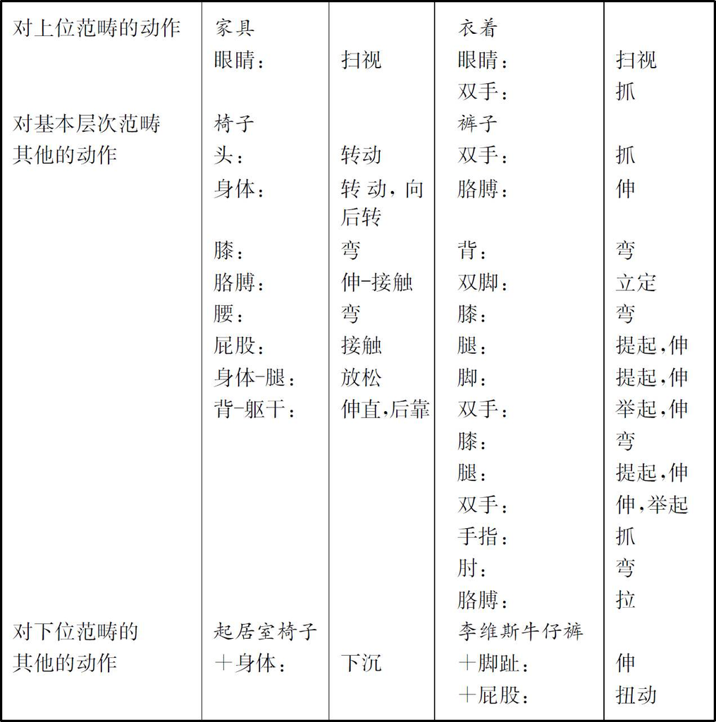

图2.4 对所选物体范畴的典型动作（Rosch等1976：附录Ⅱ）

### 基本层次和原型范畴的共生关系

正如我们已经看到的那样，用于研究基本层次的一些实验与原型研究的实验很相似。首先，两条研究路线并排进行，却常常有不同的目的，要理清并认识原型结构和基本层次概念之间的关系究竟是什么，并非易事，这种关系其实是以如下两个互相依存的原则为基础的共生关系 <sup>(5)</sup> ：

1．原型范畴在基本层次上发展得最完全。

2．基本层次范畴之所以具有它们所具备的功能，是因为它们是像原型范畴那样构造的。

解释第一个原则，回顾一下刚才讨论过的基本层次范畴的两个方面应该是有意义的：

· 基本层次给世界上的物体和生物体提供了数量最多的可理解的有关信息（例如，像鸟的动物的信息）。或者，说得更专业一点，基本层次提供了数量最多的相互联系的属性集束。这些属性在原型里以最完备的形式积累起来（如鸟 例中的＞知更鸟 ＜），并且以范畴名称表示出来（如鸟 ）。

· 基本层次由于形状有很大的重合，因此它允许有可靠的完形感知，而这种完形感知对原型样本（如＞知更鸟 ＜）而言尤其容易。

能最好地说明第二个原则的，是原型使基本层次范畴的功能最大化这一观点（Rosch 1977，1978）。细而言之，就是：

· 原型使基本层次范畴的区别性最大化，因为原型不仅抽取了数量最大的范畴内共享属性，而且还抽取了最多不与其他范畴共有的属性（例如，在所有的鸟当中，知更鸟与其他种类的动物的共有属性最少）。

· 原型使完形感知最大化，因为原型的完形整合了所有功能上的重要部分。

总之，带有原型的基本层次范畴似乎只是工具，一种完成对这个世界上我们周围的具体物体和生物体进行范畴化这种困难任务时必需的工具。从将在本书中阐明的范畴化这种更广的语境看，基本层次范畴是基本经验 中的关键部分，它们支配着我们与我们周围世界的互动。

### 练习

1．在Tzeltal人的植物和动物分类中，松树、柳树、玉米和豆，兔子、松鼠、臭鼬和囊地鼠代表了基本或属层次。这在你的英语方言或你的母语（如果不是英语）中也一样吗？

2．对比Longman Lexicon（LLCE，1981）的A部分（生命和生物）、M部分（动作、位置、旅行、交通）和Roget's Thesaurus中的相应部分，并按日常（或者通俗）分类法进行讨论。

3．就像Rosch就椅子和裤子（见图2.4）所示，当我们对这些物体在基本层次上进行范畴化时，我们可以说出最多的典型动作。看一看这对于自行车、赛车、机动脚踏两用车和交通工具，凿子、锤子、锯子、圆锯和工具，是不是也是一样。

4．Rosch在做基本层次实验时发现，对从前的飞机技工来说，基本层次范畴从范畴PLANE（飞机） 变成了更具体的范畴。讨论一下语言使用者个人，地理和社会背景对他在选择植物、动物及专业用具的基本层次范畴时的影响。请利用第一章1.3节中关于语境、认知和文化模型的有关内容。

5．讨论：你是否认为认知经济性只在对日常范畴化（或民间分类）重要而对科学分类和计算机信息处理却不重要。

## 2.2 上位范畴和下位范畴

如果基本层次范畴在许多方面是特殊的，那么其他类型的认知范畴跟它有何不同？其他范畴是仅仅被看作是稍逊一筹，还是它们具有需要独特配备才能产生的特殊功能，并且这种特殊功能决定了其范畴结构？

早期研究者为研究原型选择认知范畴的时候，他们把基本层次范畴同其他类型的范畴区分开来，并非是有意识的。他们很自然地选择了那些说明他们心中原型结构的个体效果时能预示最佳结果的范畴。正如第一章所示，范畴的完形特征和范畴界限的模糊性用杯子 和碗 这种基本层次范畴可以得到最好的说明。一般处于上位层次的水果 、家具 、交通工具 这些认知范畴则适于说明样本合格性等级和家族相似性的属性列举。但是，当基本层次范畴与上一节的上位（和下位）范畴作对比的时候，显然只有在基本层次上才能发现理想的原型结构。从这个角度上看，上位范畴有许多不足之处 <sup>(6)</sup> 。

### 上位范畴结构和寄生范畴概念

首先，上位范畴最明显的缺点是，它没有共同整体形状，因此也就没有适用于所有成员的共同的内在完形。但是，这并不意味着范畴化为水果、家具 或者交通工具 的物体就不能作为整体来处理。如果要求你拿出这种范畴的图画，你会做什么呢？为了说明水果 ，你可能会画出橙子、香蕉；而为了说明家具 ，则有可能画出椅子、桌子和床；为了说明交通工具 ，则可能画出公共汽车和摩托车。换句话说，你会从基本层次范畴包含的完形特征那儿“借”来上位范畴的完形特征——这是将被称作寄生范畴化（parasitic categorization） 的第一种情形 <sup>(7)</sup> 。

寄生范畴化原则同样反映在范畴化实验中使用属性的方式上。正如1.2节和2.1节所谈到的那样，被试一般只为上位范畴列举很少的几个全范畴属性。实际上，就家具 而言，Rosch的被试没有提出任何一个共有的属性。最可能的理由是，由于家具 可得到的共有属性太宽泛而不引人注目，因此被试觉得它们不值一提——想想看“能移动的大件物体”或“使家或公寓变得适于居住的物体”这种共有属性吧。除了全范畴属性以外，被试提供了上位范畴的成员，也就是基本层次范畴的名称以及这些基本层次范畴的属性。就家具 而言，这意味着被试会说出基本层次范畴椅子 、桌子 、床 等的名称，而且从这些认知范畴的属性清单中给家具 加上一些属性，如椅子 的“有腿”、“有靠背”、“用于就坐”等属性。这种情况图示为图2.5。

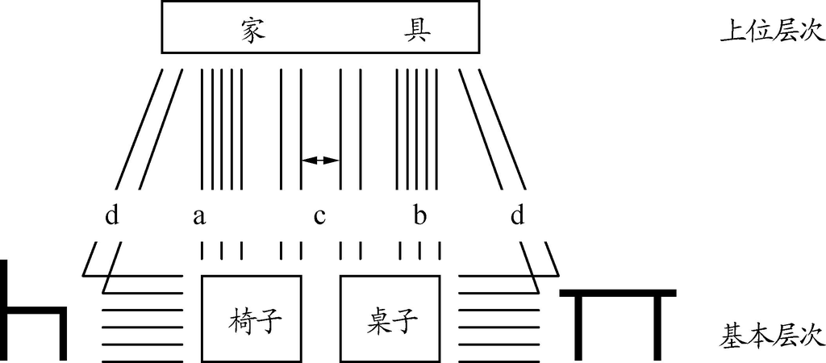

（a）椅子的属性，“有座位”“有靠背”“用于就坐”等。

（b）桌子的属性“有上平面”“用于在上边写”“用于在上边吃”等。

（c）椅子和桌子共有属性“有腿儿”“木制或金属制”，等。

（d）家具的属性“大的可移动物体”“使房子适于生活”，等。

图2.5 上位范畴家具属性图示

如果对上位范畴家具 和基本层次范畴椅子 、桌子 进行比较，它们在属性和范畴化上的差异确实很明显。椅子 、桌子 在范畴化属性上很大程度上是自足的（正如图2.3所示），相反，只有少数几个属性是直接来自上位范畴家具 的（例如，“可移动的大件物体”或“使房间适于居住”），正如图2.5的会合属性线所示，即使是这些属性也是与椅子 、桌子 所共有的。大量的属性借自基本层次范畴椅子 、桌子 丰富的属性清单——这是寄生范畴化的一个很显然的情形。

然而，我们为什么没认识到我们是从基本层次范畴，并且事实上是从相当多样的基本层次范畴，如椅子 、桌子 、沙发 、架子 、柜子 那儿为上位范畴家具 提取属性呢？这似乎应主要归因于可以在范畴成员之间观察得到的家族相似性。当我们在第一章1.2节里引入家族相似性概念时，这个概念是用来证明差样本的范畴成员身份的，例如用这个概念解释企鹅和鸵鸟为什么可称之为鸟 ，笔记本电脑和咖啡机为什么可看作是家具 （相当边缘）的项目。如果以家具 等的上位范畴为出发点，家族相似性会以不同面貌出现。

如果再一次看看从成员范畴那儿借来的家具 的属性，我们发现的确存在相当多的重合交叉之处。椅子 、桌子 似乎共有“有腿”，“木制、金属制或塑料制”等属性（在图2.5中表现为用双向箭头连接的中间两组垂直的属性集束）。家具 所具有的其他属性将为椅子 和沙发 、沙发 和床 、桌子 和架子 、架子 和柜子 所共享。这种重合交叉的结果是，在描写家具 的时候，我们从不觉得我们只是从各个基本层次范畴如椅子 、桌子 、床 那里借来孤立的属性。我们反而有这样的印象：借来的每一个属性都与很多家具有关，尽管这个属性实际上只适用于两个或三个成员范畴。

家族相似性原则的这种影响，对玩具 这种上位范畴甚至更为重要，对于玩具 ，我们只能找到唯一的一个全范畴属性（我们的认为是“用于玩耍”）。Wittgenstein的范畴GAME（游戏 ）这个极端的例子就更不用说了，在这个实例中，甚至难以找到一个全范畴的属性。（经常的联想是“以基本上快乐的方式消磨时间”、“休闲活动”、“有趣”，等等）。很明显，可用于描写上位范畴的属性主要基于各种玩具和游戏之间的家族相似性，这些玩具、游戏都是基本层次范畴，而这些基本层次范畴都是被寄生范畴化激活的。

为了有一个完整的印象，人们还可以指出上位范畴的非基本地位也反映在语言上。上位范畴的许多词汇不是简单的单音节词，例如FURNITURE（家具 ）、VEHICLE（交通工具 ）、MUSICAL INSTRUMENT（乐器 ）就不是简单的单音节词，而这类单音节词在基本层次范畴词汇中则占多数。此外，一般来讲，比之各自的基本层次词语，上位词不是最先出现在脑子里的，而儿童也在习得基本层次词语以后才学到它们。

### 下位范畴：范畴结构的特点

除了基本层次范畴以外，最常见的词汇范畴类型不是上位范畴，而是下位范畴。狗、花、汽车、小船、床、桌子都有很多种，它们都可以理解为认知范畴。有时，这些下位范畴的结构和基本层次范畴的结构很像。POODLE（卷毛狗） 、TERRIER（小猎犬） 、ROSE（玫瑰） 之类的范畴具有可识别的完形，它们围绕原型组成，存在好成员和差成员，能汇集丰富的属性清单，并用简单的词表示。但是当我们随着Brown（1990）并涉及下位范畴更极端的例子时，下位范畴与基本层次范畴之间的差异就变得更明显了。

还是讨论花，但把ROSE（玫瑰） 换成DANDELION（蒲公英） 或DAISY（雏菊） ，我们还是有一个相当清晰的完形感知，包括对完整形状、锯齿形的叶子、蒲公英黄色的花、或者雏菊典型的黄色的花盘和白色花边之间对比的整体印象。当我们开始寻找蒲公英和雏菊的原型的时候，这些范畴和玫瑰这类范畴的差异变得明显起来。一个普通的语言使用者，既非生物学家也非辞典编纂者，他是怎样选出完美的蒲公英和雏菊的呢？他又是如何描写这种完美的样本与差的样本之间的差异的呢？的确，一般的语言使用者几乎不会试图去区分原型的蒲公英和雏菊和它们较不原型的范畴成员，不管是根据个体样本还是根据变种。从自然物种转到人造物体，比如硬币，我们发现DIME（10美分） 和QUERTER（25美分） 这种下位范畴也不产生能易于跟那些更边缘的样本区别开来的原型。所有10美分硬币和25美分硬币非常相像，都同样可以看作是这个范畴的好样本。其原因不是蒲公英、雏菊、10美分、25美分的现实样本在事实上完全相同。通过仔细检查可能出现的在（蒲公英和雏菊的）外形和颜色以及（10美分和25美分的）新旧和光泽上的差异，跟日常的范畴化完全无关，并且也不影响我们的整体感知。

问题是，对下位范畴的细节的这种明显的漠视是如何与Rosch的发现保持一致的。Rosch发现，被试在为这些范畴编制冗长的属性清单时没有困难，而且这些清单甚至比提供给基本层次范畴的属性清单更加详细。

正像Rosch自己观察到的那样，这些属性中只有一些属性对讨论中的下位范畴来说是特有的，而大多数属性与各自的基本范畴的属性一样。就这些花的范畴而言，这意味着，蒲公英叶子的锯齿形状与雏菊黄色花盘和白色花边之间的对比就将列入少数几个特有属性当中。其他所有可以提及的关于花、茎、叶的内容，即DANDELION（蒲公英） 和DAISY（雏菊） 的所有其他属性都是从基本层次范畴FLOWER（花） 那里借来的；这又可以看作是寄生范畴化的一例。请对照一下图2.6。

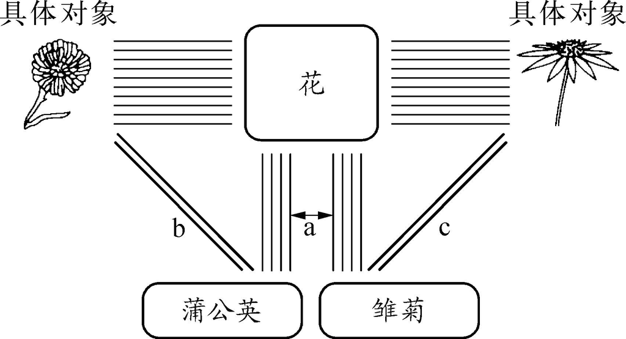

（a）共有属性，“有茎”“有花朵”“有叶子”等。

（b）特有属性，“有锯齿形叶子”“有黄色花朵”

（c）特有属性“有黄色花盘”“有白色花边”

图2.6 下位范畴蒲公英和雏菊的属性图示

此图应该与图2.5结合起来看，图2.5说明了上位范畴的范畴化。两种情况的大多数范畴化是通过基本层次范畴进行的，而直接范畴化（用粗线表示）只局限于几个属性。但是直接范畴化可用的属性质量则有关键的区别。就上位范畴而言，这是一组普遍（general） 属性，这组属性也为所有的各个基本层次范畴所共有（例如，“大而可移动的物体”和“使房子适合于居住”这些属性为椅子、桌子和许多其他家具项目所共有）。相反，为下位范畴的直接范畴化所具有的属性是特有的（specific） ，也就是说，这些属性限定了拟议中的范畴，它们一般不为其他范畴所共有：锯齿形叶子是蒲公英的特有的属性，而不是DAISY（雏菊） 、ROSE（玫瑰） 、TULIP（郁金香） 属性清单的组成部分。

### 非基本范畴的功能

下位范畴的特殊属性和上位范畴的一般属性分别是解释这两种非基本范畴的认知功能的很好的出发点。我们使用下位范畴的原因在于我们想强调或“凸显”（highlight） 它们具有的特殊属性。如果我们想用锯齿形叶子和黄色花朵来把一种花与其他种类的花区别开来，我们就会选择有关的下位范畴并用它的标签，也就是dandelion （蒲公英 ）这个词来传达。如果植物学家们想进一步指出这种花朵的特殊的颜色，他们可以用开白花的日本蒲公英 这种术语来表示一种更细微分级的下位范畴化。下位范畴的突出功能涉及的是颜色（就像我们举的例子那样）、形状、材料还是一个项目所起的作用（如，蒲公英用于沙拉和汤）是无关宏旨的。这表明，对于不同的项目来说，所有这些方面都符合用来突出的条件。

对上位范畴来说，并不因为一个属性（这个属性为一组基本层次项目如椅子、桌子、床，等等，或者小汽车、公共汽车、有篷货车、卡车等等所共有）的普遍性特征就认为该属性肯定能成功地突出。显然，只能有某些“普遍”的属性被判定为突出（salient） 到足以被凸显，而另一些属性则不是。要收集BUS（公共汽车 ）的属性，人们不会只提到用它来将人和东西运到各处；人们可能会加上公共汽车有像箱子的形状，有轮子、门、窗户、座位，装许多人。人们可能甚至想强调，只要大小适当，它被儿童用来玩。如果研究语言上的证据，我们会发现所有这些属性都很容易表达为句子或小句（事实上刚这样做过），但是只有其中几个属性事实上产生了可以自由使用的特定上位词项。与图2.7对照一下。在该图中，选出的属性以双引号表示，可能以此为基础的上位范畴以粗体表示，实际上的语言表达以楷体印刷。

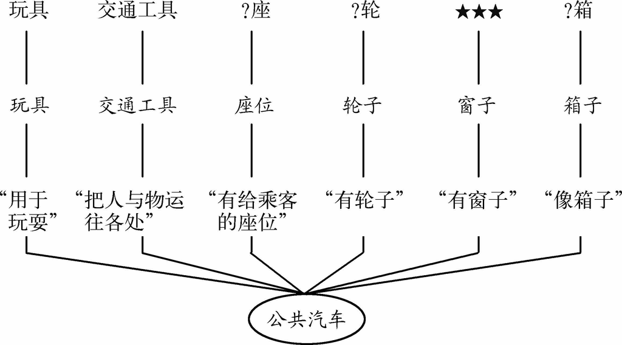

图2.7 基本层次范畴公共汽车的突出属性

正如图2.7所示，只有“把人和物运往各处”、“用于玩耍”这两个属性生成了可自由使用的词汇，即vehicle （交通工具） 和toy （玩具） 。seater （座） 和wheeler （轮） 只能用在某些搭配中，如a 30-seater （一辆三十座） 或a 6-wheeler （一辆六轮） （似乎多用于货车或卡车），而★windower （窗户的） 作为词汇项目是不被接受的，box （箱子） 也难以理解为bus （公共汽车） 的上位概念。只有vehicle （交通工具） 和toy （玩具） （及数量复合词中的seater（座 ））被立为词项，其原因似乎在于它们内在的认知范畴获得了属性的支持，而这些属性可能被认为是人造物品的最突显的品质：即它们的功能或使用目的。将公共汽车称为vehicle （交通工具 ），我们自然而然地强调它将人和物运到各处的功能。把它叫做50-seatert （五十座 ），我们强调的是公共汽车能运送很多人。用toy （玩具 ）指称公共汽车，此时我们强调的是一种特定但又非常不同的功能。功能以外的其他显著到足以支持上位认知范畴名称的属性，还包括（TEXTILES（纺织品） 、MINERALS（矿物 ）、EARTHENWARE（陶器 ）的）“原料”、（ANCESTORS（祖先） 的）“起源”、（RELATIVES（亲戚） 、IN-LAWS（姻亲） 的）“关系”。

但是强调属性不是上位范畴唯一的功能。与此密切联系的是一种第二功能。看看图2.8，这第二个功能就变得更为明显。该图显示了VEHICLE（交通工具 ）、TOY（玩具 ）这种上位范畴和有关的基本层次范畴之间的属性联系。VEHICLE（交通工具） 通过“把人与物运往各处”这个属性与CAR（小汽车） 、BUS（公共汽车） 、MOTORBIKE（摩托车） 联系起来（反过来，CAR（小汽车） 、BUS（公共汽车） 、MOTORBIKE（摩托车） 则可以看作是交通工具的种类），似乎是很自然的事情；但是，乍一看TOY（玩具） 生出的广泛联系，也许是令人吃惊的：有关的基本层次范畴不仅包括CAR（小汽车） 、BUS（公共汽车） ，还包括BALL（球） 、SWING（秋千） ，而这种列举可以几乎无限地扩大，尽管如此，CAR（小汽车） 、BUS（公共汽车） 、SWING（秋千） 和BALL（球） 也都可以看作与上位范畴TOY（玩具） 存在类属关系。正是在TOY（玩具） 这种范畴身上，上位范畴的这种我们称之为汇集功能（collecting function） 的巨大潜力变得真正明显起来：这种能力把大量范畴汇集在一个标签之下，并使得整个可及范畴的集合易于把握。这种潜在能力已经用于科学的目的，而把众多项目汇集到一个共同的名目也已经成为科学工作的一个关键部分，这就一点也不足为奇了。类属关系的跨更多层次的扩展导致了外延科学分类法的建立。详细的生物学分类或Roget的把词汇范畴组织成一个多层次的分类系统的尝试，就是这种例子。2.1节介绍这些科学分类法时，我们发现，这些分类法与Tzeltal人用于植物分类的民间分类法存在很大的差异。这些差异，现在可以根据上位范畴的突出和汇集功能来解释。

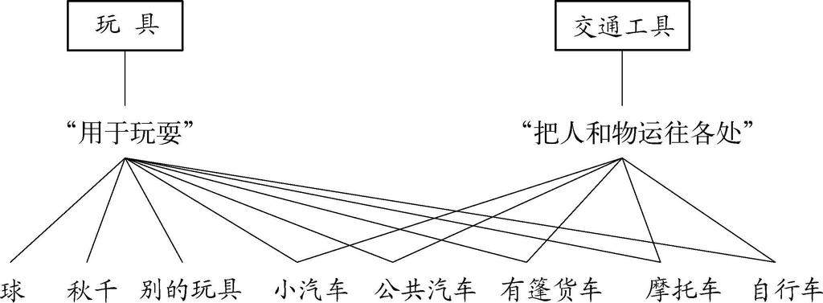

图2.8 上位范畴玩具和交通工具的汇集功能

### 练习

1．请你的同学为下列范畴列举属性：

桌子、床、灯；

刀子、叉子、勺子；

耳环、手镯、项链；

家具；餐具；珠宝；

厨房用椅、餐椅、扶手椅、柳条椅；

切面包刀、小折刀、折刀、拆信刀、切肉刀；

耳环、鼻环、婚戒、钻戒、图章戒指

并检验一下你的属性列举是否支持Rosch关于基本层次范畴、上位范畴和下位范畴属性清单的研究结果。

2．把BOOK（书） 、JOURNAL（杂志） 、NEWSPAPER（报纸） 、E-MAIL（电子邮件） 、WEBSITE（网址） 看作基本层次范畴，说出与这些范畴相关的下位范畴和上位范畴。哪些可能的上位范畴已经提升为英语的词项？哪些维度（形状、颜色、材料、来源、功能）被突显了？

3．对比一下一个科学文献的样本与童话或儿童故事样本中的基本层次词、上位层次词和下位层次词的比例。

4．“寄生范畴化概念”的基础是这种观点：上位范畴从基本层次范畴那儿“借来”属性。或者你也可以说，基本层次范畴提供了属性，然后“转”到各自的上位范畴那儿。你觉得哪种说法更有说服力？

5．寄生范畴化概念在水果、蔬菜、化妆品、文具、电器、行李、机动车和行人统计图表中是如何反映出来的？

## 2.3 概念层级

基本、下位和上位范畴是类属层级的建筑材料。然而，存在来自部分-整体关系的竞争。如果我们不把焦点集中在科学层级上，而是集中在日常语言使用中观察到的民间层级，那么，部分-整体就变得重要起来。

在2.1节中讨论Tzeltal植物分类时，我们发现，基本层次范畴PINE（松树） 和WILLOW（柳树） 以及其他类的树有一个上位范畴TREE（树） ，而CORN（玉米） 和BEAN（豆） 却没有这样的上位范畴。显然，突显他们知道的所有的树共有的一个或几个突出特性，例如“由树干、树枝、大叶或针叶组成”，“提供树荫”，“用作木柴”等，这对Tzeltal人来说是很方便的。与此相反，CORN（玉米） 和BEAN（豆） 在田里栽培，并用作食物这种事实，是不言而喻的，因此在未西化的农耕Tzeltal族群的文化模型中，这些事实并无必要强调。而且，因为只包含很少的几个项目，因此也没有理由把它们收集到一个特定的上位范畴里。

当我们回到我们自己的工业化社会和以它为基础的文化模型的时候，当我们调查可用的种类几乎无限的食物项目的时候，情况就变了。在这种环境里，诸如VEGETABLES（蔬菜） 、FRUIT（水果） 、CEREAL（谷物） 甚至FOOD（食物） 等多种上位范畴，看起来确实很有用。想像一下，如果食物项目不是按照这些上位范畴安排，我们的超市就会出现混乱。这对于诸如STATIONERY（文具） 、TOILETRIES（化妆品） 、CLOTHING（衣着） 、ELECTRICAL APPLIANCES（电器） 等非食物范畴，情况也是一样。如果没有这些带有语言标签的记号，人们怎么能在更大的百货公司找到他们要的东西呢？这一点说明了上位范畴的汇集功能，而它们的突显功能则在给每一件商品，尤其是给新产品贴标签时发挥了作用。无论是最近引进的外国水果品种，还是新品种的半加工菜，都常有必要分清其使用目的或功能，而在这些方面，上位范畴标签至少提供了第一线索。

但是，尽管在我们的文化模型里，为了应付不断扩大的商品和服务的范围，大量的上位范畴可能是必要的，不过这并不意味着普通的语言使用者在使用上位范畴的时候，在任何情况下都跟科学家那样保持一致。这在建立多层次等级的时候尤其是这样。科学分类的目标在于提供一个完整的分类层次体系，而经验的日常范畴化则很可能倾向于跳过一些层次，即使如此，从逻辑的观点看，这些层次仍有意义，并已经词汇化了。

上位范畴MAMMAL（哺乳动物） 就是一个很好的例子，毋庸置疑，它强调了“产自母体的子宫”、“喂以来自母亲身体的乳汁”这些重要属性。诚然，不仅科学话语中使用哺乳动物 ，当把注意力集中在这些属性上时，日常会话当中也使用哺乳动物 。但是，像一个规则，语言使用者会把ANIMAL（动物） 而不是MAMMAL（哺乳动物） 看作DOG（狗） 和CAT（猫） 的直接上位范畴。同样，通常也不把INSECT（昆虫） 看作是BEETLE（甲虫） 的自然上位范畴，尽管可能更容易把它接受为FLY（苍蝇） 、MOSQUITO（蚊子） 、WASP（黄蜂） 、BEE（蜜蜂） 的上位范畴。如果考虑到对很多语言使用者而言，BIRD（鸟） 和FISH（鱼） 不是ANIMAL（动物） 的下位范畴，问题就变得更复杂；所以，如果我们要寻找一个上位范畴，就不得不选择CREATURE（生物） ，而这又引起了另一个问题。因为CREATURE（生物） 对许多语言使用者会产生圣经的联想（“上帝的创造物”），或者说，它至少突出创造性的一面，却牺牲了“动物性”的其他方面。如果要找到更具有概括性的上位范畴，我们必须一直找到LIVING BEING（生命） ，但显然这是一个也包括植物的范畴。因此，我们可以下结论说，对MAMMAL（哺乳动物） 、BIRD（鸟） 、FISH（鱼） 、REPTILE（爬行动物） 、INSECT（昆虫） 来讲，没有令人满意的上位范畴。或者换句话说，在英语里，没有一个综合标记的范畴可用来表示相对于植物的“动物” <sup>(8)</sup> 。

但是，当我们使用合成词higher animal （高等动物 ）和lower animal （低等动物 ）并考虑各自的范畴时，animal （动物 ）这种更宽泛的意义就变得可用。HIGHER ANIMAL（高等动物） 大致上与前文的ANIMAL（动物） 这个狭义的概念相等，并主要指哺乳动物；而LOWER ANIMAL（低等动物） 则包括INSECT（昆虫） 和REPTILE（爬行动物） 。但还剩下BIRD（鸟） 和FISH（鱼） ，这两个还是无法确切地与HIGHER ANIMAL（高等动物） 或LOWER ANIMAL（低等动物） 联系起来。图2.9就是对这种相当混乱的情况进行刻画的一个尝试。在图中，中性的日常范畴化的上位范畴用粗体字印刷，并以粗线条连接到基本层次范畴。其他上位范畴放在括号里，以一般线条连接到各自的范畴上。

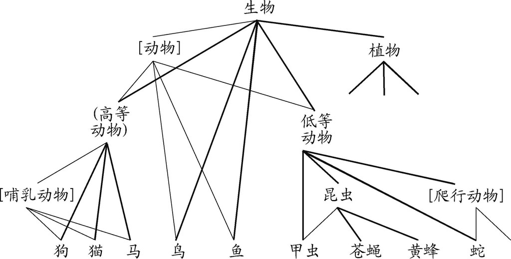

图2.9 英语中生命的上位范畴的认知观点

看看图表，人们可能很容易得出这样的印象：这种分类确实是最不令人满意的。如果我们从一种纯逻辑的观点来处理这个问题，情况可能是这样的。但是，如果考虑普通语言使用者的认知需要，人们将会懂得，用一个上位范畴ANIMAL（动物） （或HIGHER ANIMAL（高等动物） ）来指与人类关系似乎最密切的狗、猫、马这些有生物是有好处的，而如果能把昆虫和爬行动物以一种相当概括的方式放在LOWER ANIMAL（低等动物） 下面，也是很有益的。鸟和鱼可能的确占有较大的家畜和低等动物之间的中间位置，它们不像其他动物那样，需要一个直接的上位范畴。

概括一下普通的语言使用者所应用的词汇层级的认知观，人们可以说，这些“民间分类法”的特征是：有缺层、非一致性、有可选路径（即为DOG（狗） 和CAT（猫） 提供了MAMMEL（哺乳动物） 和ANIMAL（动物） 这两种上位范畴）。令人放心的是，在上位词项的定义和最近的辞书类词典的层级框架上，这种情况都得到了注重实用的词典编纂家的经验的全面支持 <sup>(9)</sup> 。在严格分类的传统下受过教育的词典编辑和语言学家通常可能更会持怀疑态度，但即使是他们也该释然于这样的事实：尽管词汇的民间分类法和逻辑层级之间有明显的差异，但是二者能在更宽的认知框架中得到调和。

### 类属层级VS部分-整体层级

当我们考虑一种在我们这个周围的世界无处不在、而在先前的认知研究中有点儿被忽视的关系，即部分-整体关系时，概念层级这一概念就甚至变得更加复杂 <sup>(10)</sup> 。没有人会否认，在手指与手、手与手臂、手臂与身体之间存在一种密切的联系，这种关系对其他身体部位也一样。同样，轮胎与轮子、轮子与小汽车（及汽车的其他部件）只是人工制品的众多的部分与整体关系中的一种。这表明，部分-整体关系是直接以事物间看得见的联系为基础的；它们可以描写为空间的邻近关系（即，靠近）和现实世界中单个物体间的邻近关系，这也就是它们看起来比类属关系更接近于具体的实体的原因（Cruse 1986：178）。认知语言学关于部分-整体关系的观点强调，这些关系是以我们对自己的身体及其部位的熟悉程度为基础的，而这显然是一种基本经验 <sup>(11)</sup> 。像其他基本经验一样，在这些经验中，基本层次范畴、部分-整体关系可能因此具有很高的认知可及度，这反映在短暂的处理时间和直观的完形感知中。而在完形感知中，整体及其部分的概念（躯体与四肢，或者，椅子和腿儿、座位、靠背，等）起了非常重要的作用（见1.1节）。

不同于类似于VEHICLE（交通工具） 和MUSICAL INSTRUMENT（乐器） 的许多分类学上的上位范畴，BODY（躯体） 、CAR（小汽车） 、HOUSE（房子） 这类部分-整体的“上位范畴”本身不是上位范畴，而是如果需要则可以激活为上位范畴的基本层次范畴。如果人们想到客厅、卧室 和厨房 ，自然会把这些部分范畴与它们共同的“整体”，即房子 这一范畴联系起来。至于上位范畴房子 的认知功能，它不突显它的“成员”的一个或几个属性，就如类的上位范畴（房间 之于客厅、卧室、厨房 ，等）的特点一样。它的长处在于其聚集功能，聚集功能这一概念是说：房子 这个范畴被认为是由客厅、卧室 等组成的，同样的聚集功能是通过厨房 聚集炊具、冰箱、饭桌 ，或者通过城镇 聚集房子、商店 和街道 来实现的。类的上位范畴以概念化了的相似关系为基础汇集 （collect ）事物，而部分-整体范畴则是以事物的概念化了的时间和空间上的同现关系为基础聚集 （assemble ）事物。我们就是在这种意义上讨论部分-整体层级或分体层级（partonomics） <sup>(12)</sup> 。 <sup>[1]</sup> 正像开头时的那个身体 的例子所示，我们不难将手指-手 这种部分-整体关系延长为更长的“链”（手指-手-手臂-躯体 ），这些组合已经被称作“链”（Croft和Cruse 2004：154），以此来强调这样的事实：链的连接物并非自动地属于范畴化中的不同的分类层级。

部分-整体与类属关系并不是相互排斥的在概念层级上对事件进行范畴化的方法。说话人可以根据他们在特定说话场合的需要来对这两种方法进行选择。图2.10说明了这种厨房、房子、城镇 和有关范畴之间概念上的互动关系。例如，随着说话场合的变化，厨房 这一范畴既可以概念化为一种房间 ，也可以概念化为房子 的一部分。就是以这几个选来图解的少量项目，该图也显示了相互联系的范畴形成的网络是多么复杂。在图2.10中，类属之间的连接是用虚线表示的，因为它们似乎不是部分-整体连接那样的基本联系。的确有许多例子，它们的类属关系是建立在可能更难深入理解的范畴间相似性的基础之上的：只要想一想隐藏起来的把大象、老鼠和鲸结合成哺乳动物 这个范畴的相似性，这一点就清楚了。因此，儿童难于理解类属关系，并长期拒绝接受马既是一匹马同时也是一个动物这种说法，也就一点也不足为奇了（Aitchison 2003：196以次）；相反，至少那些有农村背景的儿童，却能轻而易举地列举并因而在心里对在农场周围发现的动物进行归类。

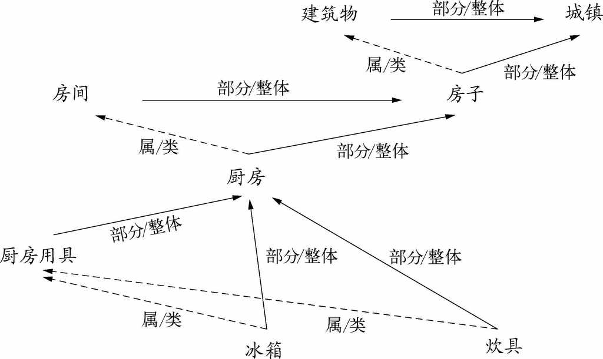

图2.10 厨房、房子和城镇等范畴的类属（属/类）和部分-整体（部分/整体）关系

考虑到分体关系在基本经验中的基础，部分-整体关系似乎也激发了我们对许多较不具体的关系的理解，也就不奇怪了。这些较不具体化的关系包括前文已经说明的准分体关系的处所联系（例如，城镇 —房子 /商店 /街道） 及更加随意的联想（正如图2.11所示），在这里，“是……的部分”或多或少带有比喻意义。与BODY（躯体） 、CAR（小汽车） 或者House（房子） 相比，只有SHOPPING（购物） 的分体层级提供了一组具体性较突出的范畴（商店、顾客、货物、计算器、现金、收款台 ，等等）。与此相反，归到TRAFFIC（交通） 和DEMOCRACY（民主） 之下的分体层级却相当抽象，而且只有少数几个项目可以进行直接完形感知。然而，TRAFFIC（交通） 、PUBLIC TRANSPORT（公共交通） 、DEMOCRACY（民主） 或ELECTION（选举） 这类范畴的结构可以认为是以部分-整体经验为基础的，这类范畴似乎在日常生活的概念化中，比MOTION（运动） 或者ACTIVITY（行为） 和HUMAN RIGHT（人权） 或者POLITICAL SYSTEM（政治体制） 这类有点专业性的范畴起了更重要的作用，而这两种专业性的范畴可以分别认为是TRAFFIC（交通） 和DEMOCRACY（民主） 这两个认知域的类属关系上的上位范畴。这种情况缘于分体层级的上位范畴的聚集潜力，这种潜力常外在地反映为这些上位范畴不可数的语法特点。尽管它们不允许对某个范畴的实例进行量化，但是，TRAFFIC（交通） 和DEMOCRACY（民主） （或者TELEVISION（电视） 、SPORTS（体育运动） 、RECREATION（娱乐） ，等等）这类不可数的项目也适于吸引与这些范畴相联系的任何事物。以这种方式，部分-整体联系在建立认知模型和把它们聚集起来的网络上起着重要的作用。

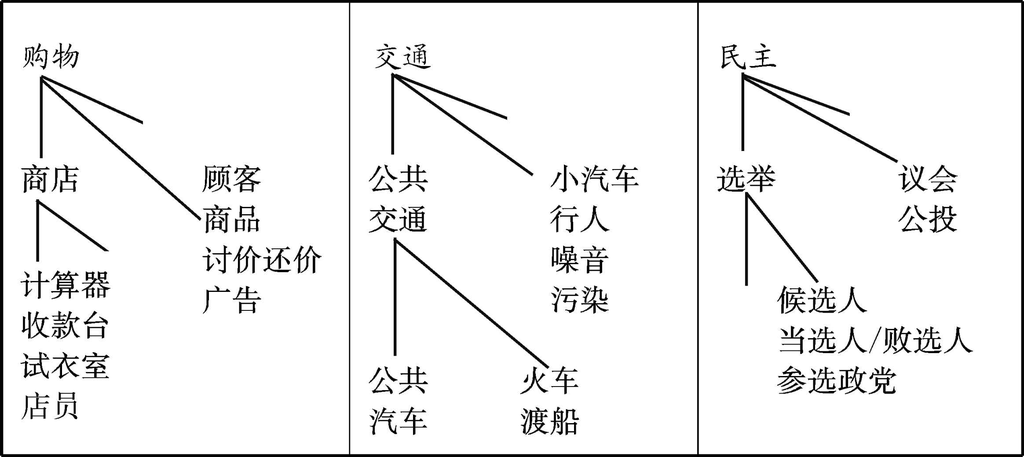

图2.11 从部分-整体联系到随意联想：范畴购物、交通、民主

最后，就像将在3.1节表明的那样，部分-整体联系是转喻必不可少的基础。一个像the university needs more clever heads（这个大学需要更多聪明的脑袋）这样的表达，显然是以脑袋是身体的一部分这种关系为基础的；在这里，部分用来“代”整体。

总之，我们已经区分了建立概念层级的两种途径：一种以种类包含中的类属关系为基础，另一种以部分-整体原则和相似关系为基础。它们的特点可以表述如下：

· 类属关系可以用来形成范围广大而严格的科学分类，这种分类严格地以一个或几个突出的属性为基础。

· 认知语言学更关注源自日常生活范畴化中的经验的类属层级（即民间分类法），这种层级也依赖于突出的属性，但既不完整也不完全保持一致，因此允许缺层和可选的层级路径存在。

· 部分-整体层级（或分体层级）是建立在现实世界中的实体间的邻近和连通关系的基础之上的，从理论上说，这种层级可以追溯到我们自己基本的身体经验。这种联系可以是部分与整体之间真实的连接，也可以是成分间的随意的联想。分体层级似乎提供了一个建立认知模型的主要结构原则（见1.3节）并在转喻的解释中起着关键的作用。

### 练习

1．查阅黄页指南，看一看所提供的商品和服务是如何根据上位范畴进行分类的。在你附近的大商店看看那儿的商品是不是按照严格的逻辑顺序摆放的。

2．为下列食物范畴画一个概念层级并考察层级中的缺层：SAUSAGE（香肠） 、HAM（火腿） 、BEEF（牛肉） 、PORK（猪肉） 、CHICKEN（鸡） 、TURKEY（火鸡） 、SALMON（鲑鱼） 、TROUT（鳟鱼） 、MEAT（肉） 、POULTRY（家禽肉） 、FISH（鱼） 、FOOD（食物） 和MILK（牛奶） 、YOGHURT（酸奶） 、ORANGE JUICE（橙汁） 、MINERAL WATER（矿泉水） 、SOFT DRINK（饮料） 、DRINK（饮品） 。

3．许多科学书籍和论文在他们的目录中使用由4或5位数组成的小数系统 <sup>[2]</sup> ，以达到严格的逻辑分类。找一本这类出版物，看看这种系统事实上对读者是否有帮助；根据我们的研究结果，这种内容如何才能变得更易于“消化”。

4．请确定下列各项中，哪些应该看作类属关系上位范畴，哪些又应该看作部分-整体的上位范畴：CLOTHES（衣服） 、HOLIDAY（假日） 、HOUSE（房子） 、MEALS（餐） 、PARTY（聚会） 、SPORTS（体育运动） 、TELEVISION（电视） 、TOOLS（工具） 。说出它们的下位范畴。请解释一下为什么ROOM（房间） 、MEAL（餐） 和SPORTS（体育运动） 既可以看作类属关系的上位范畴，也可以看作部分-整体关系的上位范畴。请找出表现出这种两可的其他上位范畴。

5．简要刻画1.3节里提到的一些认知模型（例如：WEATHER（天气） 、HOLIDAYS（假日） 、FOOD（食物） 、MEALS OF THE DAY（一日三餐） ），收集作为这些认知模型的基础的范畴（如，天气这一认知模型的太阳、风、雨、雪 ）。确定哪些范畴是靠部分-整体联接联系起来的，这些联接的哪些地方解释起来更困难。创立一个包含前文提到的认知模型（或其他合适的认知模型）的网络并说明它们之间的概念联接。

## 2.4 范畴化和复合词形式

如果类属关系和部分-整体关系在我们对这个世界的概念化中都是决定性的，那么，人们发现这两种关系在复合词形式中得到反映，即使对这些对象的形式化的分析也提出同一的修饰语-中心语结构，也就不足为奇了。

### 合成词中的类属与部分-整体关系

考察一下blackbird （黑鸟 ）、black bean （黑豆 ）、black hair （黑头发 ）这类复合词形式，假定这些项目存在概念上的类属关系，并认为这些项目处于下位范畴的地位，似乎是说得过去的。在每个例子里，“名词性”范畴（BIRD（鸟） 、BEAN（豆） 或HAIR（头发） ）可以看作是基本层次项目，支配着丰富的范畴结构，即原型、好样本与差样本及相当多的属性，而这些属性亦可用于下位范畴的概念化。相反，形容词性成分对复合词的作用似乎只限于“黑色”这个属性 <sup>(13)</sup> 。如果一定要为它的范畴地位辩解的话（见后面的2.5节），那么，这种范畴结构也无疑比BIRD（鸟） 、BEAN（豆） 、HAIR（头发） 的范畴结构贫乏得多。这些发现完全符合已被认可的构词法分析，这种分析把blackbird （黑鸟 ）这种复合词看作是第一个成分修饰第二个成分的修饰语-中心语结构 <sup>(14)</sup> 。

来看看apple juice （苹果汁 ）这种名-名复合词，其构词法分析是一样的，但认知结构有点儿不同。在此，我们有理由假定，在这个类属关系中，涉及了两个发展完全的基本层次范畴，即JUICE（果汁） 和APPLE（苹果） 。对照一下图2.12，该图说明了下位范畴APPLE JUICE（苹果汁） 的范畴化，是属性列举实验结果（Schmid ＆ Ungerer 1998）的简化形式 <sup>(15)</sup> 。

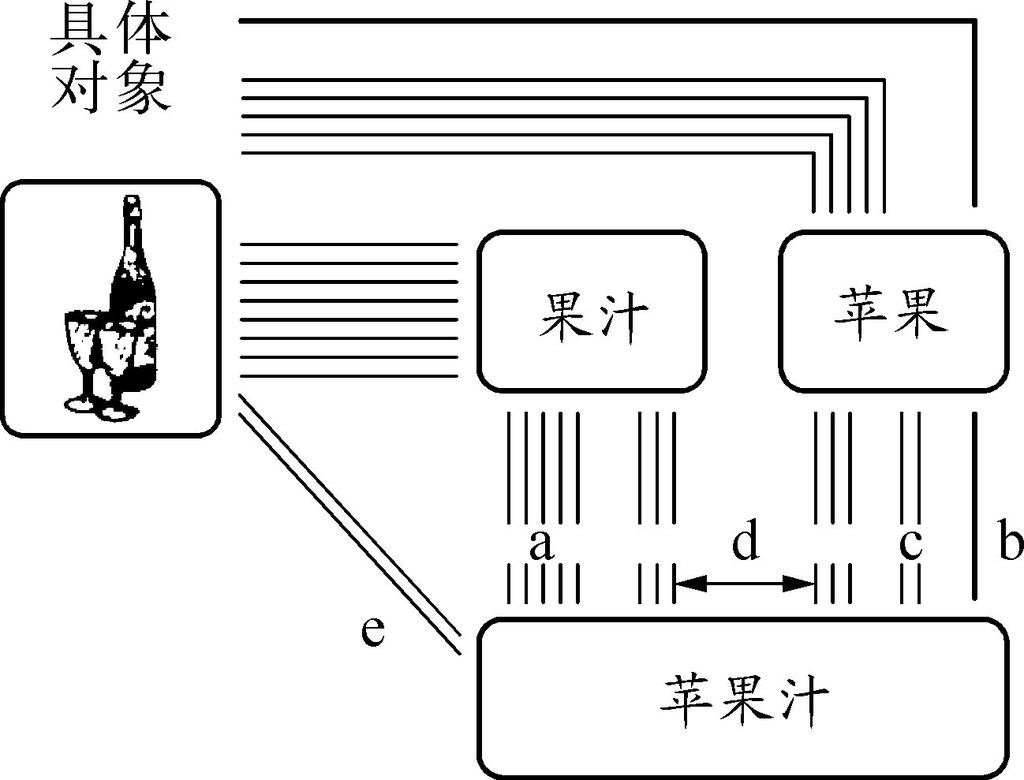

（a）借自果汁的属性：“液体”，“无酒精”，“解渴”“瓶装或纸盒装”“用玻璃杯供应”等

（b）突出的特有属性：“用苹果制作”

（c）借自苹果的属性：“黄色或类似的颜色”，“水果味的”等

（d）借自果汁和苹果的属性：“味甜或酸甜”，“有益于健康”，“味道好”

（e）非派生属性：“与苏打水混合”，“自然浑浊”

图2.12 下位范畴APPLE JUICE（苹果汁）的属性（图示）

如图所示，被试为APPLE JUICE（苹果汁） 列出的大多数属性，也用来指中心词范畴JUICE（果汁） ，其中就有“液体”，“无酒精”，“解渴”，“瓶装或纸盒装”，“用玻璃杯供应”（请看图2.12中的（a））。这印证了这样的印象：APPLE JUICE（苹果汁） 是从JUICE（果汁） 那儿借了这些属性，而它的范畴化也很大程度上依赖于JUICE（果汁） 。同样与我们的预期一致的是，与范畴APPLE（苹果） 的联系首先是通过“用苹果制作”这一特有属性建立起来的（用粗线表示，请看（b））。

当我们转而分析类似coat collar （外衣领子 ）和shoelace （鞋带 ）的复合词时，这种怀疑会更加强烈。传统上假定的类属关系与修饰语-中心语结构之间的对应关系在此处不再存在。COAT COLLAR（外衣领子） 的属性清单中，大部分的属性项目与COAT（外衣） （修饰语范畴）而不是与COLLAR（领子） （中心语范畴）建立了联系。除了突出的限定属性“外衣的组成部分”外（见图2.13里的（a）），大衣的领子用布料制作（这一属性也与COLLAR（领子） 共有），保暖、防风、防雨、防雪，穿着于冬天（见（b））——所有这些属性都被看作是外衣和外衣领子二者的本质特性。与这些属性相比，COAT COLLAR（大衣领子） 和COLLAR（领子） 之间的联系只是提到材料（c），这当然也是与大衣所共有的；最显著的属性是，领子容易弄脏或沾上油污这一事实。这些属性联系的分布图示于图2.13。

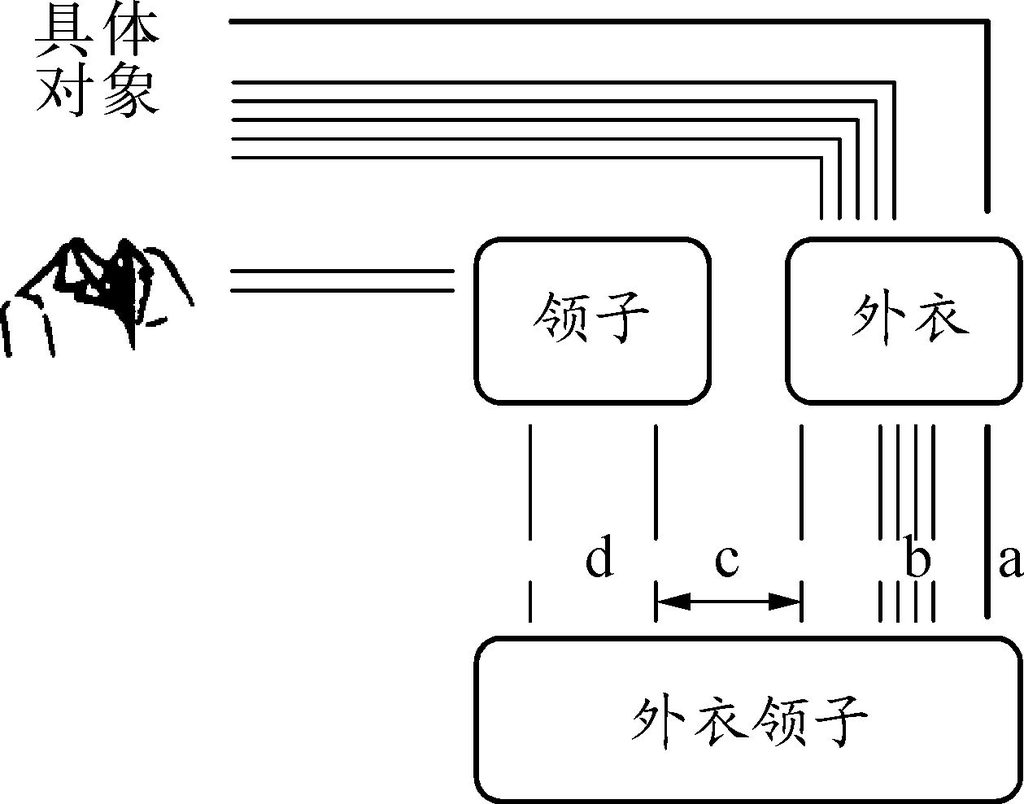

（a）突出的特有属性：“是大衣的部件”

（b）借自大衣的属性：“保暖”，“防风”，“防雨、雪”，“穿着于冬天”

（c）借自领子和外衣的属性；“用布制作”

（d）借自领子的属性：“容易弄脏或容易沾上油污”等

图2.13 下位范畴COAT COLLAR（外衣领子）的属性联系（图示）

我们将这一方法应用到SHOELACE（鞋带） 上，人们可以希望得到相似的结果。同样，从源范畴SHOE（鞋子） 派生出的属性比从源范畴LACE（带子） 派生出的属性会更多，并且还有许多别的具有相似的属性分布的下位范畴，如，SHIRTSLEEVE（衬衫袖子） 、CHIARLEG（椅子腿儿） 、LAMPSHADE（灯罩） 。因为已经讨论过部分-整体关系在概念化中的作用，现在来解释这种结果也不再困难。

coat collar （外衣领子 ）和shoelace （鞋带 ）和shirtsleeve （衬衫袖子 ）的属性清单所反映的只不过是这样的事实：这些范畴被看作是由复合词的第一个成分代表的整体的组成部分或附件，但复合词的第一个成分的概念重要性在语言使用者的头脑中压倒了类属关系（一种领子、一种带子、一种袖子）。从认知视角看，这种结果可以叫做部分-整体复合词（part-whole compounds）（ 相对于类属复合词（type-of compounds）） 。

事实上，第一个成分的这种概念压倒效应从这样一种复合词中也能观察得到，从逻辑的观点看，这种复合词并不是表现部分-整体关系，而是甚至被外行归入类属关系。如果这样，raincoat （雨衣 ）这个复合词就会被理解为受“防雨”这种属性来附加限定的外衣。然而，当要求被试说出RAIN（雨） 、COAT（外衣） 、RAINCOAT（雨衣） （各个范畴的名称给不同的被试组）的属性时，结果表明，RAINCOAT（雨衣） 和RAIN（雨） 有着多得多的共同点。正如属性清单所示，雨衣和雨一般来讲都与湿、水、暴雨和强风、冷而坏的天气有联系。从数量上来看，RAINCOAT（雨衣） 和“修饰语”范畴RAIN（雨） 之间的属性重合，比RAINCOAT（雨衣） 和“中心语”范畴COAT（外衣） 之间的重合大得多。为RAINCOAT（雨衣） 和RAIN（雨） 提出的一些属性，可能不属于对雨衣的本质特征的严肃的“客观”描写，如它的形状与面料（这些属性大部分借自中心语范畴COAT（外衣） ）。但是如果我们认可对范畴的描写也包括联想的、经验的属性这种认知观的话，那么就不能不承认这样的看法：对于普通的语言使用者来说，RAINCOAT（雨衣） 是RAIN（雨） 这一综合认知模型的组成部分，而不是（其他大衣之外的）大衣的一种。

### 来自复合词的新基本层次范畴的出现

除了已讨论的调查结果外，对APPLE JUICE（苹果汁） 这一范畴的分析还产生了另外一个有趣的结果：APPLE JUICE（苹果汁） 这个范畴被认为有两个既不在APPLE（苹果） 的属性清单也不在JUICE（果汁） 属性清单中的属性（“自然浑浊”和“与苏打水混合”，见图2.12中的（e）） <sup>(16)</sup> 。即使这些非派生属性对APPLE JUICE（苹果汁） 来说可能是相当不典型的，但是也有许多其他复合词的情形并非如此。例如，就WHEELCHAIR（轮椅） 之类的项目而言，被试给这个范畴不只是列出了一些而实际上是列出了大量的属性，而这些属性都不是借自源范畴WHEEL（轮子） 和CHAIR（椅子） 的。

这些属性是从哪儿来的？有一个广泛接受而又基本上是认知的回答是，我们依靠了我们的“世界的知识”。这种解释尽管无可置疑，但远非真正令人满意。因为世界知识这一概念的确是非常宽泛的。但是我们再审视一下我们的例子，就会发现大多数属性本质上是相当具体的。有些属性与残疾有关，另外一些属性与医院有关，还有一些属性则将轮椅与引擎及车闸联系起来。显然，刚提及的领域也可以理解为认知范畴（INVALID（残疾人） 、HOSPITAL（医院） 、ENGINE（引擎） 和BRAKE（车闸） 等）；因此，我们可以假设，在轮椅的范畴化中，在WHEEL（轮子） 和CHAIR（椅子） 以外，还涉及这些范畴（以及其他范畴）。换句话说，存在于WHEELCHAIR（轮椅） 这种复合词里的认知范畴，的确不仅依赖语言形式表示的两个范畴，还利用了大量的其他认知范畴。这一点表示为图2.14，图中那些来自这些额外源范畴的属性是用虚线表示的。

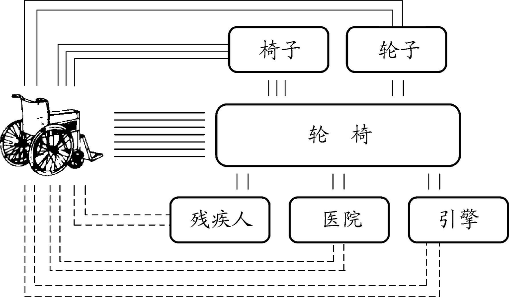

图2.14 下位范畴WHEELCHAIR（轮椅 ）的属性联系

正如更详细的观察所表明的那样，这些范畴的大多数不只是普通的人或物范畴。我们只要想一下HOSPITAL（医院） 和在它的范畴化中涉及的大量的人、物体和行为就可以了。正如在第一章1.3节所提出的那样，我们理应将HOSPITAL（医院） 看作是复杂的认知结构或认知模型，（从更轻的程度上说，INVALID（残疾人） 和ENGINE（引擎） 也是这样），这样就更易于把它们和世界知识的一般概念联系起来。

如果我们认可（作为一种暂时的结果）额外的源范畴（或认知模型）所起的特殊作用，就可以将我们的解释推进一步。复合 范畴的构建中涉及的源范畴越多，单个认知范畴所起的作用就越小，这好像是有道理的。在这个过程中，回到寄生范畴化中的所有这些多种多样的范畴，就变得越来越棘手。越来越多的属性令人觉得不再与源范畴有关，而只与复合范畴WHEELCHAIR（轮椅） 有关（这一点在图2.14中用连接WHEELCHAIR（轮椅） 和真实世界的物体的正常线条表示），而且，在这个过程的最后阶段，我们没有理由否认这种范畴的基本层次的地位。就WHEELCHAIR（轮椅） 而言，可能没有完全达到这个最后阶段。但是这种情况已经发生在其他复合范畴身上，如NEWSPAPER（报纸） 和AIRPLANE（飞机） ，二者现在一般都被公认为基本层次范畴，这一点表现为，被试显然不用考虑其他范畴，就能轻而易举地为它们提供大量的属性。从下位层次到基本层次地位的变化在语言上的反映，就是newspaper （报纸 ）和airplane （飞机 ）常常脱落第一个成分，同化成为paper （纸 ）、plane （飞机 ）这样的基本层次范畴的简单形式，这是（motor）car （（马达 ）汽车 ）早就已经达到的阶段。

这种过程的另一个众所周知的结果是，一个复合范畴的语言形式可以保留源范畴的指称，而这种范畴已经被与之相冲突的“非派生属性”所取代。holiday （假日 ）（源自holy ＋day ）就是一个这样的著名的例子，它当然也用来指非宗教的非工作日。同样，blackboard （黑板 ）所指称的物体，如今更多是绿色的，而不是修饰成分所表示的黑色的。顺便说一下，blackboard （黑板）也说明了新的基本层次复合词脱落第一个成分的倾向，如在Could you write these words on the board？ （你能把这些词写在黑板上吗？ ）这个句子中那样。

在这儿小结一下，我们可以说，与传统构词法分析和关于下位层次的严格的逻辑观相比，根据认知范畴和基于被试提出的对复合词属性的描写有几个优点。要点如下：

· 标准观假定一个基本中心语词项和严格限定的修饰语成分，这过于刻板。有许多复合词，甚至像apple juice （苹果汁 ）这种模型实例，修饰语范畴提供的不只是用于限定属性；这些额外属性可能并非都是“客观的”特性，而往往是联想的、“经验”的。

· 基本项目，即概念上占支配地位的源范畴，不一定由复合词的第二个成分表达。根据所涉及范畴的突显性的不同，对应于第一个成分的认知范畴可能同样重要（raincoat （雨衣） 说明了这一点），甚至是占支配地位的，特别是当合成词是基于部分-整体关系而不是基于类属关系的时候（就像在coat colloar （外衣领子 ）、shoelace （鞋带 ）里那样）。这意味着我们可以从认知视角上区分类属关系合成词和部分-整体关系合成词。

· 在某种程度上，几乎所有的复合词都吸取额外属性。其中的很多属性可以追溯到额外的源范畴（或认知模型）。源范畴的总体数量增加得越多，由复合词的语言形式表达的认知范畴的重要性就变得越小。如果源范畴的数量多到难以全部把握，就与寄生范畴化无关了，而源自源范畴的那些属性则被认为是属于复合范畴自己，而一种新的、自立的基本层次项目也就产生了。用Langecker的隐喻来说，成分范畴和额外范畴充当了一种脚手架，当不再需要时，它就被拆除了 <sup>(17)</sup> 。这种过程可在它的从apple juice （苹果汁 ）和wheelchair （轮椅 ）这种项目起，到（motor）car （（马达 ）汽车 ）和（air）plane （飞机 ）这种项目止的各个阶段上研究；这种过程对传统上所说的词汇化提供了清楚而具体的解释 <sup>(18)</sup> 。

也许我们应该加上一个总结性的评论，以揭示认知结构在语言中是如何表达的。从认知的角度看，复合过程在motel （汽车旅馆 ）或heliport （直升机机场 ）等混合词中能得到最好的反映，因为包含各种属性的两个认知范畴的交叉在这里可以象似地表达出来（Ungerer 1999：313以次）。但是复合词比混合词多见，因为，比之混合词，复合词是更可靠的源范畴指示器。这就是为什么要表达下位范畴的时候，复合词是首选的理由。作为可接受的第二个选择，我们希望这些认知范畴中至少有一个用语言表达出来，这种选项将在下一节进行探讨。

### “单纯”下位词之谜

在2.2节，我们描写过单纯的或看起来不能分析的下位词，如daisy （雏菊 ）、dandelion （蒲公英） 、poodle （卷毛狗 ）、terrier （小猎犬 ）、quarter （25美分硬币 ）、dime （10美分硬币 ），它们分别依赖基本层次范畴FLOWER（花） 、DOG（狗） 、COIN（硬币） ，只是又加上一个或几个特有的属性。如果考虑到复合词以及其他许多合成形式都以两个源范畴为基础（暂时忽略与额外源范畴的关系）这一事实，而daisy （雏菊 ）和其他例子却没有这种背景，这是很奇怪的。

在这儿简要地讨论一下这些词的词源应该是有益的。词源分析表明，daisy （雏菊 ）是从“day's eye”（白天的眼睛）衍生出来的，指的是像太阳的花盘，而dandelion （蒲公英）则来自法语的“狮子的牙”，显然是指它的叶子的锯齿形状。换句话说，尽管因历史发展而变得模糊，但是这两个词还是表示了各自下位范畴的特有属性。它们不是直接从修饰语范畴那儿汲取下位范畴的特有属性，而是提供一座隐喻桥梁，把下位范畴与几个源范畴连接起来（如，daisy （雏菊 ）中的DAY（白天） 和EYE（眼睛） ；dandelion （蒲公英 ）的LION（狮子） 和TOOTH（牙） ）。这是许多花的下位范畴典型特征。再举两个例子，buttercup （毛茛 ）这个词表达了它与cup （杯子） （指其形状）及butter （黄油） （指其黄色）隐喻联系，而tulip （郁金香） 则是源自波斯语的“turban”（“头巾 ”）一词（还是指其形状）。

再看看quarter （25美分硬币 ）和dime （10美分硬币 ），我们发现这二者指的都是一美元的分数（dime 源自拉丁语的decimus，意为“十分之一”），所以，通过建立一种转喻关系，与美元有关的价值就“代表”了那个硬币。就poodle （卷毛狗）、terrier （小猎犬） 而言，转喻则没有那么明显，但是词典告诉我们，poodle （卷毛狗 ）与水坑有关系，而terrier （小猎犬 ）则与拉丁语的terra（“土 ”）有关，因为在打猎的时候，小猎犬会把狐狸或獾赶进它们的地洞里。因此，大部分例子都利用了隐喻或转喻联系。这种隐喻或转喻联系在认知语言学中普遍的重要性将在第3章里讨论。

但这只是问题的一半。同样引人注意的是，FLOWER（花） 、DOG（狗） 、COIN（硬币） 这种基本源范畴在语言形式上没有表示出来。正如我们已经看到的那样，这些源范畴对DAISY（雏菊） 和DANDELION（蒲公英） 等的认知识别与范畴化是不可或缺的，这就更令人诧异了。一种可能的解释是，FLOWER（花） 、DOG（狗） 或者COIN（硬币） 这样的基本层次范畴在我们关于自然和钱的认知模型中是不言而喻的部分，所以不必显性地表示出来。我们转向更特殊的语境，即饭馆这个语境的时候，对认知模型的依赖，或更确切地说，对文化模型的依赖就变得更加明显起来。在饭馆语境中，像APPLE JUICE（苹果汁） 或LIGHT BEER（淡啤） 这种下位范畴被表示为two apples （两杯苹果）或two lights （两杯淡的）。这种情况也普遍存在于种种专家语境中，例如，艺术家、运动员、学生、教师，并由此组成了他们社团行话中的基本部分。

作为小结，我们可以得出这样的结论：大部分单纯或不可分析的下义词，就其内在的认知范畴来说，实际上并不单纯，而是基于一个表示出来的修饰语范畴和一个未表示出来的隐性的中心语范畴。但是，也有例外。以ROSE（玫瑰） 这个范畴为例：它早被认为是一个源自希腊语的单纯词，它有易于识别的完形和丰富的属性清单，因此，即使在逻辑上这个认知范畴是FLOWER（花） 的下位概念，我们也试图承认它的基本层次地位。

为解决这种不一致性问题，我们必须想到认知的研究方法有两个基本的原则。第一，认知单位不是离散的。正如范畴之间没有清晰的边界，概念化的层次之间的过渡，最好也看作是渐进的。这一点在部分-整体关系层级的实例中尤为明显，它不能毫无疑问地归到不同层次，但它仍然适用于类属关系的民间分类法。QUERTER（25美分） 或者DANDELION（蒲公英） （或BLACK BEAN（黑豆） 、BLACKBIRD（黑鸟） 这样的合成词）显然被看作是其基本层次范畴的下位范畴，而POODLE（卷毛狗） 、TERRIER（小猎犬） 、DAISY（雏菊） 可能就没那么明显，但是它们比ROSE（玫瑰） 这种接近或实际上就属于基本层次的范畴则还要更处于下位层次。

第二个原则把我们带回到2.3节中关于概念层级的讨论。我们发现，与科学等级不同，这种认知或民间分类法因为承认相互竞争的上位范畴，因而可能出现不一致，如DOG（狗） 的上位范畴可以是ANIMAL（动物） ，也可以是PET（宠物） 。这原则也可适用于基本层次。普通的语言使用者好像完全能并列地使用几个相互竞争的基本层次范畴。DANDELION（蒲公英） ，也许还有DAISY（雏菊） 依赖FLOWER（花） 作为源范畴，但玫瑰则可以独立地范畴化（也可以充当各种玫瑰和类似于玫瑰的其他花的源范畴）。基本层次范畴之间相似的共存现象在其他领域里也可以观察得到，例如BUILDING（建筑） 和HOUSE（房屋） 之间、JEANS（牛仔裤） 和TROUSERS（裤子） 、PLANE（飞机） 和JET（喷气式飞机） 之间的共存 <sup>(19)</sup> 。在某些例子中，较新的范畴（JEANS（牛仔裤） 、JET（喷气式飞机） ）可能最终取代作为基本层次范畴的其他范畴，这一点证明了替代引起词汇变化这一规律。但是，其他范畴，例如FLOWER（花） 、ROSE（玫瑰） ，正像它们一直被同时使用一样，将继续被同时使用，如果这样做有希望产生一种比严格逻辑下位分类更经济的范畴化形式的话。

### 练习

1．看看下面包含shoe 这一成分的复合词，确定每一个例子中的复合词是以类属关系为基础（第二个成分占支配地位），还是以部分-整体关系为基础（第一个成分占支配地位）的：

| ballet shoe | shoe hammer | shoe-shop |
| --- | --- | --- |
| canvas shoe | shoe heel | shoe-tip |
| patent-leather shoe | shoe leather | shoemaker |
| peep-toe shoe | shoe-boy |  |
| sling-back shoe |  |  |
| town shoe |  |  |
| walking shoe |  |  |

是否有类属关系复合词显示——就如RAINCOAT（雨衣） 一样）——第二个成分的支配地位在概念化过程中被超过。

2．传统的构词分析中区分修饰语-中心语复合词和actor-manager （演员经纪人 ）这种连结复合词（也叫做并列复合词）。根据本章提出的认知分析法对这种区分进行评论。

3．正像WHEELCHAIR（轮椅 ）一样，下列复合范畴不能只依靠标出的源范畴来说明其特征：ASHTRAY（烟灰缸） 、BEER MAT（啤酒杯垫） 、TEA POT（茶壶） 、NUMBER PLATE（车号牌） 、WALLPAPER（墙纸） 、HORSE SHOE（马蹄铁） 、SPARK PLUG（火花塞） 。你可以给它们提出哪些额外属性？它们还能跟其他什么范畴或认知模型有关系？讨论一下这些复合词是否已经正在向基本层次范畴的地位靠近。

4．我们在文中提到，许多花的名称与几个源范畴有关系，这种关系一般通过隐喻或转喻来建立（如daisy ＜day's eye ）。考察一下下列花的名称的词源并讨论其中涉及的认知过程：bugloss （牛舌草）、 coltsfoot （款冬））、 bluebell （风信子）、 harebell （蓝铃花）、 pink （石竹花） 和groundsel （千里光） 。

## 2.5 基本层次范畴和基本经验：行为、事件、特性、状态和处所

至此，我们关于范畴化的基本层次和其他层次的讨论还只限于物体和生物体。但是在第一章里介绍基本性这一概念时是与基本颜色词相联系的，而这种颜色词通常是以作形容词的形式出现的。这也是为什么问下面这种问题似乎是很自然的原因：高度、强度这类性质，特别是许多“动词”的行为对人类的范畴化而言是否也同样是基本的？

大多数人可能会直觉地认为，吃、喝、睡、走、谈等频繁发生的行为，跟苹果、狗、汽车这些我们所熟悉的物体同样是基本的，而且表现出同样多的变种。假如说，正如我们已经假定的那样，苹果、狗、汽车在心理上是由那些具有原型结构的基本层次范畴来表征的，那么，我们为什么不应该认为这些行为也是这样的认知范畴呢？

但是令人惊讶的是，认知语言学家迟迟没有去证明这种直觉。第一次为行为范畴的原型结构提供证据的尝试，涉及的不是吃和睡，而是撒谎这种心理活动。这一研究的主持人Coleman和Kay（1981）采用了Labov的方法，即用数量有限的给定维度来描写杯子和碗（见1.1和1.2节）的方法。他们给认知范畴LIE（撒谎） 选出的维度是：

（a）事实上的假（一句话语或命题是假的）

（b）信念的虚假（说话人相信这句话是假的）

（c）欺骗的意图（说出一句话的时候，说话人有意去欺骗听话人）

Coleman和Kay不是用Labov的杯子和碗线条图形，而是用虚构的故事来描写这三条标准的各种组合。有一个故事是关于一个无聊的宴会的。宴会结束时，有人只是为了礼貌才向女主人说“谢谢，宴会棒极了！”。这种陈述明显是假的（标准（a）），并且说话人也相信是假的（标准（b）），但可能没有传达欺骗的意图（标准（c））。在另一个故事里，有个护士搞混了正要准备推进手术室的两个病人的病，并因此向医生提供了错误的信息。即使她说的话事实上是假的（标准（a）），但不认为说出了不真实的情况（b），也没有欺骗医生的意图（c）。这些故事与符合所有三种标准的原型实例形成对比，这个原型实例是，有一个孩子明目张胆地否认自己吃了蛋糕（实际上是她吃了）。

让被试听这些故事，并要求他们按照7个等级回答这个故事是不是一个谎言，如，确定/不是那么确定/等等。总的来说，Coleman和Kay主张动词lie （撒谎 ）的意义可以理解为一个认知范畴，这个认知范畴有满足所有三个标准的原型实例，也有不满足所有的三个标准的较不原型的实例。

第二个研究是Verschueren（1985）对语言行为的调查，与我们直觉的看法更接近。但是作为一个基本行为的清单则不一定有说服力，因为它不仅包括speak （说 ）、write （写 ）这类合适的候选成员，还包括相当成问题的项目，如answer （回答 ）、apologize （道歉 ）、ask （问 ）、congratulate （祝贺 ）、name （命名 ）、tell （告诉 ）、thank （感谢 ）。其原因是Verschueren总体上调整了Berlin和Kay已经为基本颜色词建立的标准（简单的语言形式，不能用另一个基本项目来定义，广泛的运用，心理突显，为说这种语言的大多数人所知；见1.1节）。虽然他也提及Rosch对基本层次项目的研究，但是他并没有太多地利用她的研究成果。正如2.1节所示，她的研究成果给基本层次范畴的定义至少加上了三条重要标准：“丰富的相互联系的属性集束”、“构建为原型范畴”、“很强的完形感知潜力”。

即使这些标准不能确切地适用于Verschueren提及的大多数行为，但是把这些标准用到本节开头提及的吃、喝、睡、走等行为范畴，似乎是相当可行的。

### 行为范畴

首先看范畴EAT（吃） ，我们可能理所当然地认为它具有简单的语言形式，为说英语的人所熟知，孩子也在很早的阶段就学到它。另外，我们不难收集很多几乎为这一认知范畴所独有的属性，如“从盘子里拿起食物”、“张开嘴巴”，“把食物放进嘴里”、“咬”、“嚼”、“咽”等。注意，因为这种范畴指一种行为，所以它的这些属性也一般指行为，而不是物体和特性。但是下面这条原则对行为范畴依然有效，即部分-整体关系在概念化中起关键作用。例如“咬”，“嚼”，“咽”这些阶段可以看作是“吃”这种更复杂的行为的组成部分 <sup>(20)</sup> 。至于原型性，则有可能把＞EATING A SANDWICH（吃三明治） ＜或＞EATING AN APPLE（吃苹果） ＜这种较原型的实例、与＞BEING SPOONED BY ANOTHER PERSON（让他人用匙子喂） ＜这种较不原型的实例及＞SIPPING SOUP WITH A STRAW（用吸管吸汤） ＜（例如牙科手术之后）这种相当边缘的实例区分开来。最后，吃这一行为可以作为一个综合的整体，即作为一个完形来感知，并的确能作为一个完形来范畴化和概念化，这样说完全是有道理的。

举第二个例子，KILL（杀 ） <sup>(21)</sup> ，也似乎符合所有的三个标准：在依赖媒体的西方社会里，这个范畴的原型实例可能是＞SHOOTING DEAD（WITH A GUN）（（用枪）射死） ＜，它也可以充当这一行为的完形意象的基础。被试可能列举的KILL（杀） 的属性包括：举起枪或相似的武器、瞄准、开枪以及电影里熟悉的其他行为，如搏斗、打、倒下、翻倒、流血。

考虑到KILL（杀 ）这个例子令人不快的性质，读者也许会奇怪，为什么首先挑选了它。原因在于KILL（杀 ）在1960年代就已经在语言学文献里确立为经典例子，那时，它被分析为包括这些语义元素：CAUSE（致使） 、BECOME（变成） 、NOT ALIVE（不活） <sup>(22)</sup> 。因为这三个成分的发散性，这种分析从认知观点来看是非常有趣的。“not alive”（不活）这一属性当然会以某种形式，也许是以“dead”（死）的形式，出现在被试的属性清单里，而“cause”（致使）、“become”（变成）这种属性，我们会认为太抽象而难以命名。但是，这些属性使我们想起的是“用于玩耍”，“运输方式”这类非常宽泛的属性。这类属性可以从基本层次的物体范畴（例如DOLL（娃娃） 或BUS（公共汽车） ）中提取出来，并用以对上位范畴TOY（玩具） 和VEHICLE（交通工具） 进行概念化。换句话说，我们认为，可以把像cause （致使 ）或become （变成 ）这样的动词看作是表征了上位行为范畴，因为他们的主要功能是突显一种非常宽泛的属性，而这些属性则又是一系列基本层次行为范畴的组成部分。因此，我们假设，按照寄生范畴化原则，被试为了把更抽象的范畴CAUSE（致使） 概念化，就会回到KILL（杀） 、THROW（投） 、PUT（放） 这类基本层次的行为范畴上。Lakoff和Johnson（1980/2003：70）的研究证明了这种看法，他们认为，直接致使是由kill （杀） 、throw （投） 这类动词表示的，这一点也符合如下假设：孩子是通过故意地扔出瓶子和丢下玩具来学习致使意义的。其他一些具有突出的普遍属性的上位行为范畴的候选对象还有HAPPEN（发生） 、BECOME（变成） 、BEING（在、有、是） 、STOP（停） 。

在行为领域里可以找到基本层次范畴和上位范畴，似乎说得过去。较难断定的是，是否也存在表达类属关系（而且不是阶段-行为或部分-整体关系）的下位范畴。循着上一章确立的路线，承认类属关系的下位范畴将意味着我们要寻找在一个或几个特有属性（像DANDELION的（蒲公英） 的属性“锯齿叶子”）上与基本层次范畴有区别的行为范畴。我们也会不出所料地发现，区分原型样本和较不原型的样本是很难的（我们发现，所有蒲公英看起来都相当像）。最后，我们会假定，许多下位范畴在语言上是以复合词或合成词来表示的，其中一个成分表示其特性，另一个成分则表示各自的基本层次项目（例如，APPLE JUICE（苹果汁） 中的APPLE（苹果） 表示其特性，而JUICE（果汁） 指基本层次范畴。）

为了检验这个假设，图2.15从《朗文当代英语词典》中挑选了一些指各种行走的词（LLCE，1981） <sup>(23)</sup> 。（对特性的描写有些部分来自《简明牛津当代英语词典》，COD 1999）。首先看语言形式，在这个清单中没有一个复合形式，这反映了英语中极少动词复合词这一事实。因此，哪些范畴可以充当特性化的源范畴，我们找不到语言线索。的确，从那些解释部分能提取的属性，或者很复杂（STRUT（昂首阔步） 的walk“in a proud way”（傲慢地行走）），或者相当含糊（WANDER（漫步） 是walk“around without a fixed course”（到处走而没有固定的路线））。另一个问题是完形感知。比之不同类型的行走，可能更难以把跛行、迈步或者昂首阔步的好样本和差样本区别开来；与蒲公英的统一完形相比，跛行或昂首阔步这些行为的统一完形的确更加难以想像得出；而这种统一完形，我们发现是下位范畴的典型特点 <sup>(24)</sup> 。这样的结果是，比之物体和生物体下位范畴，这些行为范畴的下位地位就没有那么确定。LIMP（跛行） 、AMBLE（缓行） 、WANDER（漫步） 之类的许多行为范畴似乎都拥有相当于ROSE（玫瑰） 的那种地位，这使得他们接近基本层次，而不是我们所预期的那样，来自严格意义上的下位范畴。

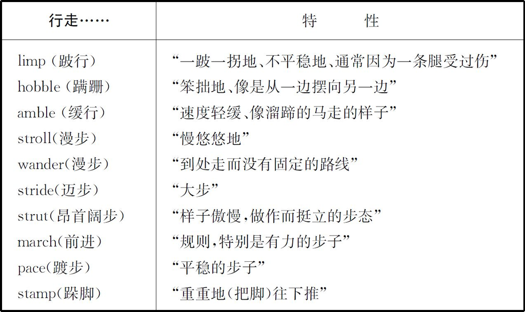

图2.15 行为范畴WALK（行走） 的一些可能的下位范畴

这对建立层级有什么影响？当然，有可能将 STRIDE （大步行走） 、WALK（走） 、MOVE（移动） 或MUNCH（咀嚼） 、EAT（吃） 、CONSUME（消耗） 分别安排在下位层次、基本层次、上位层次上，以此来建立一个行为层级，但是这些层级更可能是科学的建构，而且并不一定反映了普通的语言使用者的认知框架。此外，这种行为层级甚至比物体和生物体领域中的层级更不规则。

因此，关于行为范畴，我们只有这样的感觉：行为范畴包括一些可能以原型范畴来感知的基本行为，但是，当我们接触到上位范畴和下位范畴，并推而广之接触到行为范畴的词汇层级时，这种分析方法就变得没那么无可置疑。

### 行为、物体和生物体之间：事件范畴

当我们将EAT（吃） 和DRINK（喝） 之类的行为范畴与BREAD（面包） 、SOUP（汤） 、TEA（茶） 等相关物体范畴进行比较的时候，各自的属性清单之间的交叉重叠之多给人留下了深刻的印象。有些基本层次食物范畴的名称会在EAT（吃） 的属性清单里发现，反过来，EAT（吃） 等基本层次行为范畴的名称当然也处于基本层次食物范畴的较重要的属性之列。因此，在行为和物体的基本层次范畴之间似乎存在着很强的认知相互依赖性。

然而，行为和物体（或生物体）范畴不仅通过属性的互相予-取建立联系，而且也可能熔合成从属的却仍然是非常基本的自然范畴。这种事件范畴（event category） 的好样本是BREAKFAST（早餐） ，这一范畴在第一章1.3节MEALS（餐） 的文化模型语境中提到过。在这里，我们对这个范畴感兴趣的不是它的文化背景，而只是它的内部结构。从这个角度看，范畴BREAKFAST（早餐） 把基本层次物体范畴（如BREAD（面包） 、BUTTER（黄油） 、KNIFE（刀子） 、SPOON（匙子） 、CUP（杯子） 、TABLE（桌子） 、CHAIR（椅子） ）和基本层次行为范畴（如EAT（吃） 、DRINK（喝） 、CUT（切） 、SPREAD（涂） ）组合了起来，因此可以看作是复杂的基本层次范畴。这是Rifkin（1985）（顺便说一下，他从框架概念出发，框架概念将在第五章讨论） <sup>(25)</sup> 的主张。Rifkin用属性列举实验表明，被试可以给BREAKFAST（早餐） 、LUNCH（午餐） 、DINNER（晚餐） 、PARTY（宴会） 、SEEING A MOVIE（看电影） 、WATCHING A TV SHOW（看电视） 、TAKNG A BATH（洗澡） 、BRUSHING ONE'S TEETH（刷牙） 、TAKING A SHOWER（淋浴） 、THEFT（偷） 、RAPE（强奸） 、MURDER（谋杀） 这种基本层次事件范畴提出大量的属性。至于有关的（类属关系）上位范畴MEAL（餐） 、ENTERTAINMENT（娱乐） 、HYGIENIC ACTIVITY（卫生活动） 和CRIME（犯罪） ，它们的范畴结构则贫乏得多；而QUICK BREAKFAST（简易早餐） 、BIRTHDAY PARTY（生日聚会） 、SHAMPOOING（洗发） 、PICKPOCKETING（扒窃） 之类的下位范畴则与基本层次范畴得出差不多数量的属性。

然而，我们从部分-整体关系的角度来处理事件范畴时，这种分类结构就进入了我们的视野。如果把行为分成组成部分或不同阶段（就如我们对动词表示的行为所持的主张那样），并且认为行为范畴形成了事件范畴的组成成分，那么，MEAL（餐） 与STARTER（开味菜） 、MAIN COURSE（主菜） 及DESSERT（甜点） 之间、PARTY（聚会） 与WELCOMING（欢迎） 、SMALL TALK（聊天） 、BUFFET MEAL（冷餐） 、DRINKING（喝） 、DANCING（跳舞） 及FAREWELL（告别） 之间的整体与部分关系在范畴化中比任何类属关系都显得更重要。事实上，我们在2.3节已经说明的情形特别适合事件范畴：正是这些部分-整体联接好像为事件范畴（或它们中的认知模型）提供了基础。

### 特征：基本层次范畴或基本经验？

把物体的“名词”领域和行为的“动词”领域放下，转而看看“形容词”的特征，特别是色彩词的时候，我们面对的是一个两难的困境。一方面，固有的传统思想认为，形容词指的是物体和生物体的单一特性，而没有基本层次范畴的属性清单。另一方面，被试却能选择焦点颜色或原型颜色，并把它们与较边缘的颜色区别开来——而这也正是原型范畴这一认知概念的出发点（请看第一章的1.1节）。

对语言学家来说同样重要的是，颜色词渐变的典型性不能只靠直觉去体验，或者只用色调、亮度、饱和度等科学术语加以描写，它也以语言的形式反映在已有的多种颜色词语中。crimson （深红 ）、purple （紫 ）、scarlet （鲜红 ）、vermilion （朱红 ）之类的词都是指RED（红） 的可识别的色调；这样的例子还有cherry （樱桃红） 和复合词brick-red （砖红） 。正如最后两个例子所示，RED（红） 的种类往往是作为某种物体的特征来识别的，例如樱桃的特征和红砖的特征。这种办法广泛地用于色谱的表示——对比一下chestnut （栗色 ）、olive （橄榄色 ）、lilac （丁香紫 ），更不用说像amber （琥珀色 ）、aquamarinegy （玉绿 ）、turquoise （绿松色 ）之类的大量从宝石衍生而来的颜色词了。这说明，颜色不是孤立地被范畴化，而是作为表示物体和生物体的范畴的特征来体验的。

特征的范畴结构依赖这些物体和生物体的程度，在Dirven和Taylor（1988）研究过的TALL（高） 这个例子中变得更加明显。正如两位学者所看到的那样，TALL（高） 的结构，是它与某些名词的搭配问题。正是在搭配的基础上，Rosch的样本合格性等级排定程序才能应用到高度这种形容词性的特征上。通过让被试判断TALLNESS（高度） 多大程度上适用于某个名词，Dirven和Taylor得到了编制样本合格性等级清单所需的信息，图示为2.16 <sup>(26)</sup> 。

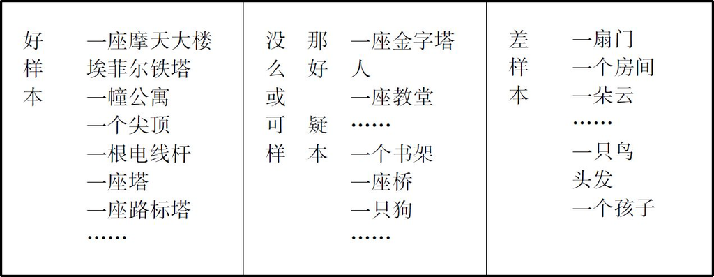

图2.16 物体和生物体就TALLNESS（高度）而言的样本合格性等级（引自Dirven和Taylor（1988：397，表3））。

毫无疑义，这些与tall （高） 搭配的合格性等级，对于理解形容词的搭配能力与限制是很有用的。较不确定的是，这种合格性等级是否能看作是对Dirven和Taylor的主张的有力证明。他们主张TALLNESS（高度） 是具有原型和丰富的认知结构的认知范畴。的确，人们可能认为，当要求被试给名词短语a skyscraper （一座摩天大楼） 或a baby （一个孩子） 与形容词高 的搭配合适性列出等级时，被试脑子里所有的不是TALL（高） 这个范畴的特定实例，而是SKYSCRAPER（摩天大楼） 和BABY（孩子） 这种范畴的实例。或者换一种说法：如果不再考虑与名词短语的搭配关系，那么还将剩下什么？不借助与之有关的物体，同样难以想像我们如何能想到颜色的许多属性，tall （高 ）、long （长 ）、small （小 ）等维度特征或smooth （光滑 ）、hot （热 ）、sweet （甜 ）等物理特征。同样，我们为什么能指出这些特征的好样本与差样本呢？我们又应该如何在心里描画出像高度这种特征的完形呢？

这样一来，问题就在于是否应该把“高”、“光滑”、“热”之类的特征看作是对应于物体、生物体范畴和行为范畴的认知范畴，或者说，特征是否表征了另一种认知体验。这种不同的解释将基于如下假设：特征包含单个的属性，或者包含至多是小簇的属性，这迫使我们想到传统的解释。在认知的语境里，重要的是这样理解这些特征：它们表征了认知现象，而这种认知现象则基于源自我们与物体、他人及我们自己的身体最直接互动的感官事件。举一些更显而易见的例子，如，我们可以建立“甜”、“酸”、“辣”和“咸”等特征与我们舌头上的各个生理感受器之间的联系，建立“温暖”、“冷”等特征和皮肤上感知温度的感受器官之间的联系，更不用提已研究过的基本层次颜色词与生理上的颜色感知之间的联系了（见第一章1.1节）。与感官事件的关系即使在别的情况下（如与维度特征有关时）可能不那么直接，但这个证据依然表明这些形容词性的特征可能同样反映了基本经验，这种基本经验可以与整体和部分的身体经验等量齐观，而我们的部分-整体关系观念似乎是建立在这种整体与部分的身体经验基础之上的。

### 静态和位置关系

因为与形容词性的特征领域有那么密切的关系，这是另一个似乎可以用范畴和基本经验来解释的领域。除了be （是 ）、exist （存在 ）、resemble （像 ）、contain （包含 ）这类带“静态”意义的动词外，语言中表达这种关系的最普遍的方式是使用介词和源于介词的副词。因为in、up、out、off 之类的介词表现出强烈的意义增殖倾向，当认知语言学家在将原型模型转移到生物体和物体之外的领域时，这些介词成了他们偏爱的研究对象，也就不足为奇了。尤其是，举例来说，up 或over 的各种意义之间的关系特别适于用来说明家族相似性概念（详细的讨论，请看4.1节）。

然而，面对介词固有的关系性质，我们不能确定是否有必要坚持用原型范畴来解释。当我们孤立于物体范畴来看介词时，它们的确不会使我们根据属性清单、典型性成分和完形来考虑它们。我们反倒会有这样的感觉：“上—下”、“里—外”、“前—后”、“左—右”之类的位置关系，反映了基本经验，就像我们为重要的形容词性特征提出的那样。这种解释与Lakoff的观点是一致的。他认为，这些位置关系应该看作基本意象图式（image schema） ，而这种意象图式是直接来自日常的身体经验的（Lakoff 1987：267；又见4.1节）。

总结这章所讨论的问题，还是应该注意如下几点：

· 对于行为的范畴化来说，许多因物体和生物体范畴化而形成的描写手段似乎都可资利用。

— 把行为处理为原型范畴。

— 在这个层级中存在一个心理突显的行为范畴的基本层次；

— 层级的其他层次虽然也存在，但是发展得没基本层次那么完全，下位范畴往往表示行为的不同阶段或组成部分，而不是行为的次类。

· 事件表现了物体、生物体范畴与行为范畴的熔合，从这种意义上说，事件是从属的，尽管如此，许多事件还是表现出基本层次范畴的特征。类属关系层次是有可能的，但很多时候部分（或阶段）与整体关系在事件的概念化中似乎更为重要。

· 对于特征、位置关系和静态关系（“高”、“在……下/在……上”、“属于”，等等），按原型范畴分析只是一种可能性。对这些特征和关系的另一种解释是以意象图式概念为基础的。意象图式被认为是一种既不相同又有联系的基本体验（见3.1和4.1）。

### 练习

1．在Longman Lexicon和Roget's Thesaurus中找出EAT（吃） 、DRINK（喝） 、CLEAN（打扫） 、COOK（烹饪） 、READ（阅读） 和DRIVE（驾驶） 这些基本行为范畴可能的下位范畴。考虑表示行为的阶段或次类的项目。

2．问你的同学，下列基本事件范畴的个人完形意象和属性是什么：LECTURE（讲座） 、TRAFFIC ACCIDENT（交通事故） 、CONCERT（音乐会） 、AUDITION（试听） 、INTERVIEW（面谈） 、CHURCH SERVICE（教堂服务） 、EXAMINATION（考试） 。

3．考虑下列跟strong 和weak 的搭配：

a strong drink，strong beer，a strong man

a strong scent，a strong anaesthetic

a weak heart，a weak point，weak eye-sight

a weak dosis，a weak stomach，a weak man

是不是有可能把这些用法看作是STRONG和WEAK的原型范畴成员？或者，它们是否应该都是从一个单一的维度，如从表示基本体验的“强度”或“深度”派生出来的？

4．根据一本语法书，编一张英语介词表，讨论一下为什么有的介词比另一些介词显得更基本。

### 进一步阅读建议

2.1节

Lakoff（1987：46以次）和Taylor（2003，第三章3.3节）为本节讨论的主要问题提供了一个合理但相当短的总结。较之原型概念，他们基本上都忽视了基本层次概念。Kleiber（1998：第二章II.II节）更全面地研究了基本层次；Schmid（待刊）在突显和强调的概念之下考察了基本层次。Brown（1990）对认知范畴的类型持一种更与众不同的观点，这种观点在Ungerer（1994）得到进一步的发展。

(1) Cain（1958）讨论了心理上的考虑是如何影响Linnaeus的分类的。Stuessy（1990）非常全面地讨论了现代植物分类法中的原则。

(2) McArthur（1986：第18章）详细地阐述了Roget's Thesaurus的历史和其他想把这个世界编入主题参考书的尝试。

(3) Berlin等人（1974）论Tzeltal人植物分类一书的纲要在更早的一篇文章（Berlin 等 1973）中更易理解。他们对Tzeltal人植物名称的说明得到了Hunn（1977）对Tzeltal民间动物学研究的补充。还有一个较短的版本（Hunn 1977），里边含有民间与科学分类之间关系的更全面的讨论。

(4) Rosch（1978）把认知经济性概念引入范畴化理论中，很值得一读。这一问题在Geeraerts（1988a）中有进一步的讨论。又见我们在6.4节中对认知经济性的评论。

(5) 关于基本层次与原型之间关系的更多背景知识，见Rosch等（1976），Mervis和Rosch（1981）及Kleiber（1990：第3章3.2节）。Geeraerts等（1994）提出了荷兰语中指称衣着项目的词的详细的实验研究结果，他们是根据“专名学”与“符号学的变体”来定义基本层次和原型性概念的。

2.2节

对这一节主要观点的简明总结，见Croft和Cruse（2004：84-87）。Wierzbicka（1985，第4章）全面而详细地讨论了不同类型的上位范畴，其中包括部分-整体关系的上位范畴，见下面的2.3节。

(6) 在Rosch（1977）和（1978）中可以找到早期的关于上位范畴特殊地位的参考资料。Cecil Brown（1990）为本章及下一章的开头部分提供了尽管是有点儿专业却不错的背景资料。

(7) 对寄生范畴化概念的简明描写，见Ungerer（1994）。

2.3节

(8) 为了对比，参见Lyons（1977：291以次）、Cruse（1986：145以次）、Lipka（1992：151以次）中的关于上下位词的更传统的观点。Lipka和Cruse都强调ANIMAL的范围有限，但都认为CREATURE是一个没有问题的上位范畴。Taylor（2002，第7章）也持这种观点，他把层级整合到图式概念与实例中去了。

(9) 见McArthur的Longman Lexicon of Contemporary English，A30节以次。

(10) Rosch和她的合作者是这样；但参见Tversky和Hemenway（1984）、Tversky（1990），他们报告了揭示在基本层次范畴化中那些描写物体组成部分的属性的重要性的有趣研究。

(11) 关于意象图式，见Johnson（1987：28以次）和Lakoff（1987：267以次）、Turner（1993）、Lakoff和Johnson（1987：30-36）。关于意象图式的心理现实性，见Gibbs和Colston（1995）。

(12) Seto（1999）也使用部分-整体关系这一概念，他详细地讨论了部分-整体关系、分类法和隐喻之间的关系，还阐明了部分-整体转喻与synecdoche（提喻）这一传统概念的关系。

2.4节

(13) Smith等（1988）更详细地研究了这一方法，他们为合成词的认知解释提出了一个“选择修正模型”。从概念整合理论（从6.1到6.3讨论）的角度对合成性的批评，见Sweetser（1999）和Coulson（2001：38以次）。

(14) 因篇幅关系，构词法的分析在此只限于复合词，派生构词（后缀构词法和前缀构词法）的认知分析，见Ungerer（2002），这一领域的其他研究的综述，见Ungerer（待刊（a）），全面的认知分析，见Schmid（2005）。

(15) Schmid和Ungerer（1998）更详细地阐述了复合词的属性列举实验，这个实验为这儿提出的词汇化的认知观提供了实验上的证明。

(16) Murphy（1988）很好地介绍了非衍生属性问题，他的观点得到了最近Springer和Murphy（1992）所报告的心理实验的证明。

(17) Langacker对合成词的全面的讨论，见Langacker（1987a，第12章）。他的脚手架对砌砖的隐喻将在3.3节继续讨论。

(18) 词汇化概念的讨论，见Bauer（1983：42以次）、Lipka（2002：94以次）、Schmid（2005：73以次）。Leech（1981：225）采用词汇意义的“化石化”隐喻并讨论了与此有关的例子wheelchair 和pushchair 。

(19) 请对照Geeraerts等（1994）对有关衣着的荷兰语词项的研究及Schmid（1996c）对jeans和trousers的解释。

2.5节

(20) 对比Cruse（1986：174）中关于行为和过程的组成部分的讨论。

(21) 关于范畴KILL的认知讨论，见Lakoff（1987：54以次）。亦见Fillmore（1982）对CLIMB这个原型范畴的简短讨论，Taylor（2003：108以次）后来接着对这一原型范畴进行过讨论，他提出了一个（有问题的）带几个原型的结构。

(22) Lipka（2002：116以次）全面地阐述了动词的语义基元。

(23) 亦见Aitchison（2003：107以次）论walk 和一些别的动词。

(24) Ungerer（1994）就tap 之类的瞬间动词探讨了用统一完形作为下位范畴标准的可能性。

(25) Rifkin（1985）一文中有很多关于上位和基本层次的事件范畴的实验资料。

(26) 想知道在这种语境中哪些特征应该考虑的看法，见Dixon（1977）对基本形容词的讨论和Langacker（1987a：147以次）对基本域的讨论。

[1] 我们避免使用“meronomy”（分体关系）这一术语，是因为它很容易与第三章讨论的“metonymy”（转喻）混淆。“Partonomy”用来指层级，而各个部分与整体之间的关系被称为“partonymic”。

[2] 译注：即1.1.2.1或3.2.1.2.1

# 第三章 概念的隐喻与转喻

## 3.1 隐喻和转喻：从言语修辞格到概念系统

传统上，隐喻和转喻被看成言语修辞格，也就是说，或多或少地被看成在修辞文体中使用的修辞手段。但是，像the foot of the mountain（山脚）或talks between Washington and Paris（华盛顿和巴黎之间的对话）之类的表达方式表明这两种现象在日常生活语言中也起着重要作用。而且，哲学家和认知语言学家证明隐喻和转喻是我们对世界进行概念化的有力的认知工具。

### 作为修辞格的隐喻和转喻

我们经常使用词语的比喻意义，这已经是常识。即使很小的孩子也很善于使用比喻的语言 <sup>(1)</sup> 。然而在很长一段时间内，对这种语言现象的研究领域仅是属于文学家和个别对修辞或文体学感兴趣的语言学家的 <sup>(2)</sup> 。有鉴于此，用一些文学的例子开始对修辞语言的讨论也许比较合适。请看下面从莎士比亚十四行诗中摘录出来的五个关于词语eye （眼睛 ）的例子（Kerrigan，1986）：

（1）So long as men can breathe or eyes can see，

So long lives this，and this gives life to thee．（18，13-14）

（只要一天有人类，或人有眼睛，

这诗将长存，并且赐给你生命。）

（2）Is it for fear to wet a widow's eye

That thou consum'st thyself in single life？（9，1-2）

（是否因为怕打湿你寡妇的眼，

你在独身生活里消磨你自己？）

（3）Sometimes too hot the eye of heaven shines，

And often is this gold complexion dimmed．（18，5-6）

（天空的眼睛有时照得太酷烈，

它那炳耀的金颜又常遭掩蔽。）

（4）Lo，in the orient when the gracious light

Lifts up his burning head，each under <sup>[1]</sup> eye

Doth homage to his new-appearing sight

Serving with looks his sacred majesty．（7，1-4）

（看，当普照万物的太阳从东方

抬起了火红的头，下界的眼睛

都对他初升的景象表示敬仰，

用目光来恭候他神圣的驾临。）

（5）Mine eye and heart are at a mortal war

How to divide the conquest of thy sight.（46，1-2）

（我的眼和我的心在作殊死战，

怎样去把你姣好的容貌分赃。） <sup>[2]</sup>

如果我们认为概念EYE（眼睛） 的属性清单中包括像“人和动物身体的一部分”、“位于头部”、“视觉器官”、“产生眼泪的地方”这些特征是理所当然的，那么我们可以毫无困难地把词语eye （眼睛 ）的前两个实例理解为这个概念很典型的成员。但是对其他三个例子就没有把握这样说，因为这三个例子涉及词语eye （眼睛 ）的比喻用法。

看看其他例子，我们就能推断出例（3）中的表达方式the eye of heaven （天空的眼睛） 意指太阳。在例（4）中，我们假定眼睛代表某个举止特别恭敬的人，则大概可以理解眼睛“向某人表示敬意”这个意象。这两个例子分别是传统上称作“隐喻”和“转喻”的很典型的例子。例（5）同时包含了这两种修辞手法：词语eye （眼睛 ）用来指人的整个视觉能力，与heart （心）所代表的感情领域形成对比（二者都是转喻相当传统的例子）；另外，视觉域和感情域被看作卷入战争的人或政党（即拟人化，一种常见的规约的隐喻类型）。

隐喻和转喻 <sup>[3]</sup> 这两种词语比喻用法的主要类型，怎样用更普通的词语描述其特征，二者又如何能相互区别？先看后一个问题，转喻被认为包含一种词表示的字面意义和它相应的比喻意义之间的“邻接 ”（即接近或邻近）关系（relation of“contiguity”） ，转喻联系着的一个成分代表（stand for） 另一个成分。这种代表关系的典型例子表示为图3.1 <sup>(3)</sup> 。

＋PART FOR WHOLE＋（all hands on deck ）

＋以部分表整体＋（全体水手在甲板集合）

＋WHOLE FOR PART＋（to fill up the car ）

＋以整体表部分＋（给汽车装满油）

＋CONTAINER FOR CONTENT＋（I'll have a glass ）

＋以容器表内容＋（我要喝一杯）

＋MATERIAL FOR OBJECT＋（a glass，an iron ）

＋以材质表物体＋（一个玻璃（杯），一个铁（熨斗））

＋PRODUCER FOR PRODUCT＋（have a Löwenbräu，buy a Ford ）

＋以生产者表产品＋（喝一杯勒文布劳，买一辆福特）

＋PLACE FOR INSTITUTION＋（talks between Washington and Moscow ）

＋以地方表机构＋（华盛顿和莫斯科之间的对话）

＋PLACE FOR EVENT＋（Watergate changed our politics ）

＋以地方表事件＋（水门改变了我们的政治）

＋CONTROLLED FOR CONTROLLER＋（the buses are on strike ）

＋以被控制者表控制者＋（公共汽车在罢工）

＋CAUSE FOR EFFECT＋（his native tongue is German ）

＋以原因表结果＋（他的母语是德语）

图3.1 转喻中代表关系的类型

与之相对的是，传统上认为隐喻建立在表达方式的字面意义和比喻意义之间的“相似”（similarity） 或“对比”（comparison） 概念基础上。更确切地说，隐喻被认为是一个三项模型，包括“本体”、“喻体”、“背景”这三个成分（Leech 1969：148），或者用不那么专业的语言来说，是“被解释成分”，“解释成分”和“对比的基础”。这在图3.2中用例（3）的“天空的眼睛”这一隐喻作了说明。

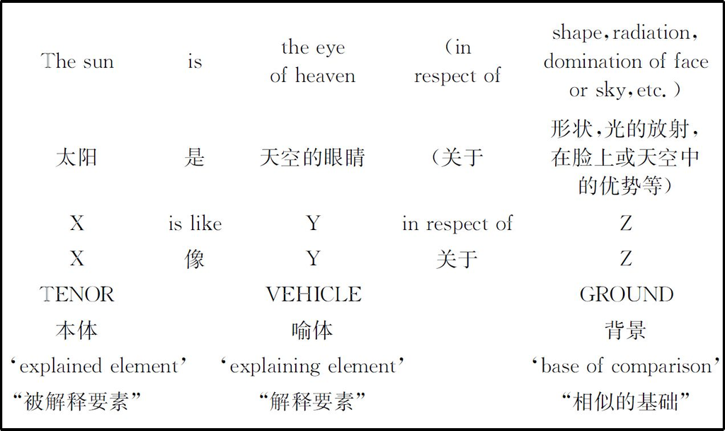

图3.2 隐喻的传统解释（按照Leech 1969，附加的说明性解释）

从这种“对比”或“替代”的隐喻观点出发，I.A．Richards（1936）和Max Black（1962，1993）提出了所谓的隐喻“互动理论”。他们坚持认为隐喻的本质在于隐喻表达方式和隐喻使用时的语境之间的互动。在我们这个例子中，互动可以描述为以隐喻方式使用的概念eye （眼睛 ）和of heaven （天空的 ）这一语境之间的语义冲突或张力，而这就使eye of heaven （天空的眼睛 ）这个表达产生了“太阳”的意义 <sup>(4)</sup> 。

### 规约化隐喻

正如图3.1中转喻表达方式的例子所示，转喻和隐喻都并不仅限于文学语言。实际上，日常语言充满了隐喻表达。在已经由eye （眼睛 ）这个例子找开的领域里，我们发现多数指称人体部位的词语都有许多隐喻引申的用法。图3.3列出了指称人上半身部位词语的例子（其中有的也包含转喻成分） <sup>(5)</sup> 。

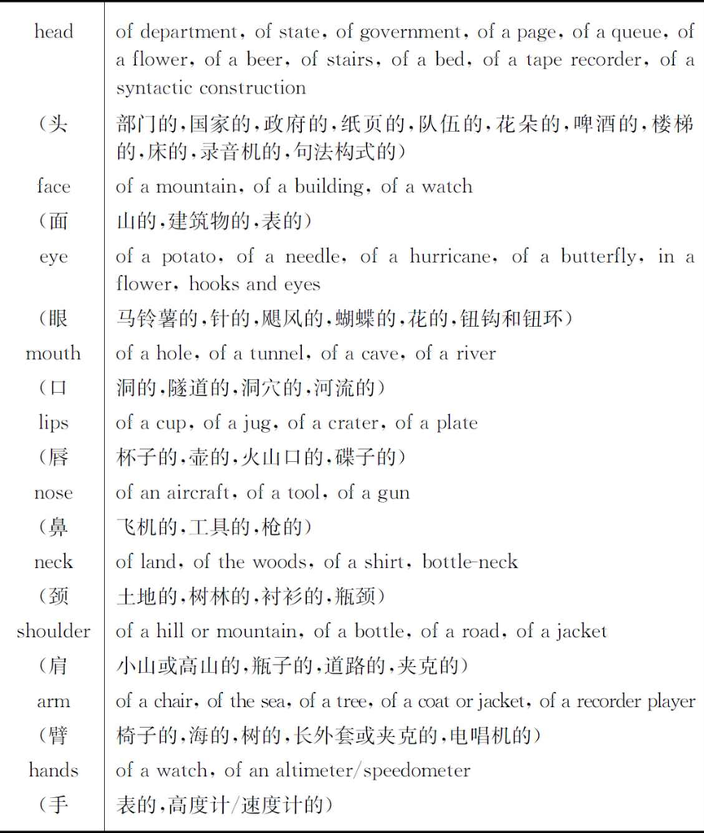

图3.3 身体部位的规约化隐喻（集自Wilkinson 1993 和《朗文当代高级英语辞典》第四版）

很多其他领域的例子也俯拾皆是，随着这一章的展开，有些我们将会进行讨论。所有这些例子所表明的是，隐喻和转喻不仅仅是文学中的言语修辞格，而且在日常语言中也很普遍。为了区分由诗人们想出来的更有创造力、表现力和出乎意料的隐喻与语言使用者通常甚至都意识不到的诸如head-of-department （系主任） 的这类隐喻，我们把后一种叫做规约化的、词汇化的或者“死”的隐喻。这些标签背后的逻辑是，通过和某一语言形式的频繁结合，一个词语的比喻意义在言语社团中变得如此确定（即规约化），以至于这个比喻意义当之无愧地作为该词的一种意义进入了词汇（即词汇化）。从认知的观点来看，这是极端的误导。用Lakoff和Turner（1989：129）的话来说：

这种错误来源于一个基本的混淆：它假设我们认知中最活跃的、最积极的事物是那些我们意识到的事物。恰恰相反，最活跃的、最根深蒂固的、有效的、有力的是那些自动到无意识而无须费劲的事物。

从认知视角得出的结论是，真正最重要的隐喻是那些通过长期建立的规约关系而无意识地进入语言的隐喻。

### 作为认知工具的隐喻

回顾隐喻和转喻从传统观念到认知观念的发展，我们现在到了一个关键时刻。正如Black在前认知语境下就已经认识到的，隐喻充当了“认知工具”（1962：37）。这意味着，隐喻不仅仅是一种利用语言手段表达思想、在风格上增加魅力的方法，而且是一种对事物进行思维的方法（a way of thingking） 。同样，Lakoff 和Johnson（1980/2003：7以次）也认为，我们不仅是在语言上利用＋TIME IS MONEY＋（＋时间就是金钱＋）这个隐喻，而且我们确实也通过MONEY（金钱） 这个源（source） 概念，对他们所说的目标（target） 概念TIME（时间） 进行思考或概念化。换句话说，当我们使用下列英语短语时，我们在两个似乎不属于同类性质的概念间建立起了联系：

| You're wasting my time． | （你在浪费 我的时间。） |
| --- | --- |
| Can you give me a few minutes. | （你能给 我几分钟吗？） |
| How do you spend your time？ | （你是怎么花 你的时间的？） |
| We are running out of time． | （我们正在用完 时间。） |
| Is that worth your time？ | （那值得你花 时间吗？） |

源概念和目标概念并非被孤立地理解，而是被认为是处于“认知模型”和“文化模型”之中（见1.3节）。这样，隐喻所转移的就不只是各个概念内在的属性，而是整个认知模型的结构、内部关系或逻辑。用一个源于制图学、后为数学家借用的隐喻来说，认知语言学家把这种转移叫做来源向目标的“映射”。意思就是，从认知视角看，隐喻是把源模型的结构映射到目标模型上。由于概念和认知模型之间的区别常常很模糊，后面我们将使用更为中立的术语“源概念”和“目标概念” <sup>[4]</sup> 。

让我们再考察另外一个例子来说明隐喻概念（Lakoff 和Turner 1989：1以次）。人的生命周期被规约地概念化为从arriving in （来到 ）这个世界开始，going through life （走过一生 ），在死的时候leaving （离去 ）或departing （离开 ）。这意味着我们用三段旅程来思考人生：当我们出生时我们经第一段旅程到达，我们整个生命是在这个世界上的第二段旅程，死的时候我们踏上了最后一段旅程。第一和第三段旅程用隐喻表达方式（metaphorical expressions） 在语言中得到了反映，例如the baby is on the way （孩子在来的路上 ），the baby has arrived （孩子已经来了 ），we bring babies into the world （我们把孩子带到这个世界上 ），he is still with us （他还跟我们在一起 ），they brought him back （他们把他带回来了 ），he is gone （他走了 ），he has departed （他离开了 ），he has passed away （他过去了 ）。然而我们真正感兴趣的是中间这段旅程，我们一生的旅程，我们可以用下面这些隐喻表达方式来描述（Lakoff 和Turner 1989：3以次），例如：She went through life with a good heart （她带着一颗善良的心走过了一生 ），He knows where he is going in life （他知道他一生要向哪儿去 ），I don't know which path to take （我不知道该选哪条路 ），He made his way in life （他获得了成功 ），He works his way around many obstacles （他努力克服人生路上的很多障碍） 。

回到隐喻的传统解释（图3.2中呈现的三要素系统）上来，我们发现，正如到此为止所表现的那样，这个认知方法把焦点集中在三要素中的两个要素：本体（或“被解释要素”）和喻体（或“解释要素”），前者现在被看成是目标概念（target concept） ，后者现在被看成是隐喻的源概念（source concept） 。为了把传统体系的第三个要素（背景或“对比的基础”）整合到认知观中，我们引入图3.4所示的映射域（mapping scope） 概念，以进一步扩展这个描写工具 <sup>(6)</sup> 。

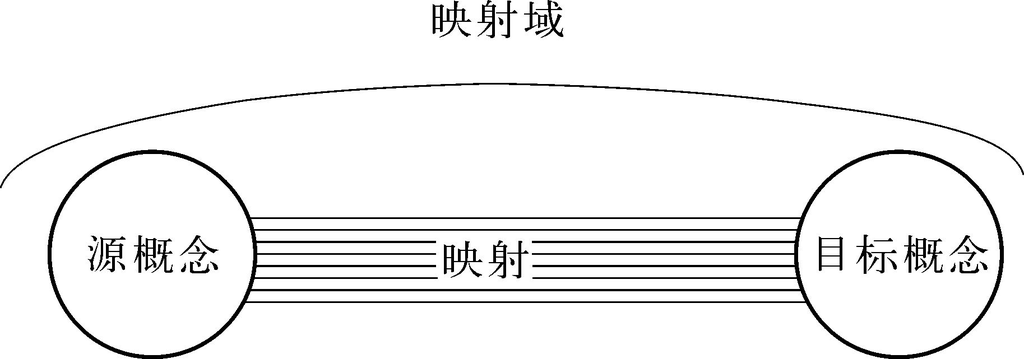

图3.4 隐喻映射的基本成分：源概念，目标概念，映射和映射域

在我们看来，隐喻的映射域最好理解为一套限制，这套限制规定哪些对应有资格从源概念映射到选定的目标概念上。这些限制不仅有助于避免将任意一种特征从源概念转移到目标概念上，而且有助于激发可能的对应范围。隐喻的映射域本质上反映出我们处置所处世界的概念经验。更具体地说，我们可以区分映射域的三个主要成分：

· 意象图式（image schemas） ，它牢固地根植于我们的身体经验中。它们包括方向图式，如“in-out”（里-外），“inside-outside”（里边-外边），“front-back”（前-后），以及“inside-outside”（内部-外部）（或“container-contained”（容器-内容））图式，“part-whole”（部分-整体）（或“whole-part”（整体-部分））和“path”（路径）图式；意象图式最有可能是全人类共享的。（又见2.5节）

· 基本相互关系（basic correlations） <sup>(7)</sup> ，对它们我们不像对意象图式那样涉身体验，但是它引导我们理解所处世界中的事件和动作。这种基本相互关系的例子是可能具有普遍意义的一些关系，如“行为/变化与运动关联”（或简写为“行为/变化＜＞运动”符号＜＞表示“和……相互关系”。），“原因＜＞结果”，“目的＜＞目标”和“出现＜＞存在”；很可能它们具有和意象图式一样的普遍地位。

· 文化依存评价（culture-dependent evaluations） ，限于某一特定文化的成员。例如，在西方文化中，文化依存的评价包括“富有”，“年轻”，“愚蠢”或“美丽”（属于人的）；“强壮”，“威严”，“好斗”或“肮脏”（属于动物的），“贵重”，“耐用”，“有用”或“易碎”（属于物体的）之类的评价性属性。

把这个概念应用于已经讨论过的隐喻，那么，＋人生是旅程＋（＋LIFE IS A JOURNEY＋）这一隐喻最适于在依靠意象图式“路径”的映射域内激活，并得到“变化＜＞运动”和“目的＜＞目标”这些相互关系的支持；相反，在以“inside-outside”（里边-外边）或“up-down”（上-下）这类意象图式或者“原因＜＞结果”这种相互关系为基础的映射域内就不那么适合。在You're wasting my time （你在浪费我的时间 ）或者We are running out of time （我们正在用完时间 ）中表达的＋时间就是金钱＋这一隐喻需要一个包含“时间是贵重商品”这种普遍评价的映射域；在这里，“金钱是邪恶的”这种道德家说的属性没那么有用。补充一个说明截然不同的文化差异的例子，猪在西方文化中特定的属性“肮脏”和“贪婪”确定John is a pig 这个隐喻短语要理解为“他不整洁”或者“他吃相不佳”，而在其他文化中，猪可能和不同的属性相联系。比如在现代中国，词位猪 具有和西方相似的内涵，但是它也用作对情人的情话，有几分简单而傻傻的可爱意味。在这种文化中，隐喻＋A PERSON IS A PIG＋（＋某人是头猪＋）就具有和西方完全不同的意思，因为诸如“肮脏”、“贪婪”这类属性不被认为是它映射域的组成部分。

这表明，为了对一个隐喻进行无须费力的概念化，映射域必须牢固地确立在特定文化的成员的头脑中。然而，对于创新的文学隐喻，例如＋WINTER IS FOOD＋（＋冬天是食物＋）这个编造的例子，一般的（西方）读者可利用的映射域的确是非常模糊的。即使是对更有名的文学隐喻，如前面引用的莎士比亚的例子＋SUN IS THE EYE OF HEAVEN＋（＋太阳是天空的眼睛＋），初学者也可能有问题，因为与诸如＋TIME IS MONEY＋（＋时间就是金钱＋）或＋LIFE IS A JOURNEY＋（＋人生是旅程＋）等固定的“日常”隐喻相比，它的映射域仍然不够牢固。换句话说，映射域的牢固程度可能存在很大的变化，从社会语用学角度看，这一点反映了一个隐喻在言语社团中已经达到的规约化 （或社会认可）程度（degree of conventionalization） 。

在初步概述了隐喻的认知语言学概念之后，似乎就有理由问一问什么是概念隐喻典型的目标概念和典型的源概念。图3.5汇集了选出的在文献中讨论过的重要的源概念和目标概念。比较图中的两栏，我们发现左栏中的概念在性质上较为抽象，而右栏里的则更为具体。这似乎证明我们依赖具体世界的概念对抽象的现象概念化。为了证明这一主张，我们将更详尽地考察抽象概念ARGUMENT（论争） 和IDEA（思想） ，二者都支配了大量的隐喻。

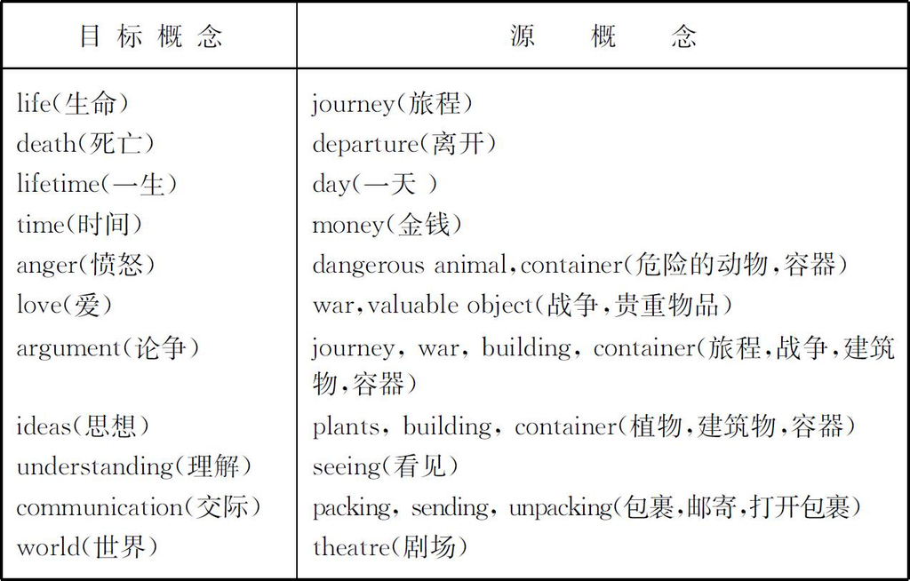

图3.5 隐喻映射主要的源概念和目标概念

### 隐喻的结构能力Ⅰ：argument（论争）

我们是怎么对ARGUMENT（论争） 这一概念进行概念化的？用传统语义学的术语来说，我们可以区分出词语argument （论争） 的三个意义。除了“思想路线”以外，论争可以是“不同意或争吵”，最后是“支持或反对某事的理由”。但是，这些释义都远未抓住我们储存的与ARGUMENT这个概念有关的大量信息：论争通常经历的阶段；参与者富有特色的交谈方式；参与者所追求的目的；所提出理由的说服力。概念的这些方面在区分argument （论争） 的不同意义时也许不是非常有用。事实上，它们显示的是这些各不相同的意义被一个共有的概念结构多么紧密地联系在一起，而认知语言学家感兴趣的也正是这个结构。根据Lakoff 和Johnson（1980/2003），我们对概念ARGUMENT的概念化建立在下面四个相关的隐喻上：

＋ AN ARGUMENT IS A JOURNEY＋（＋论争是旅程＋）

＋ AN ARGUMENT IS A BATTLE＋（＋论争是战斗＋）

＋ AN ARGUMENT IS A CONTAINER＋（＋论争是容器＋）

＋ AN ARGUMENT IS A BUILDING＋（＋论争是建筑物＋）

现在我们要详细地考察这些隐喻。

＋AN ARGUMENT IS A JOURNEY＋（＋论争是旅程＋）

第一个隐喻主要用于对论争过程进行概念化。以这个隐喻为基础的表达方式有（Lakoff 和Johnson 1980/2003：90）：

We have set out to prove that bats are birds．（我们已经开始 证明蝙蝠是鸟。）

When we get to the next point ，we shall see that philosophy is dead.（等我们到下一观点时，我们将会看到哲学死了。）

So far ，we've seen that no current theory will work．（至此，我们已看到没有一种现行理论起作用。）

This observation points the way to an elegant solution．（这项观察指出了一种精确的解决路线。）

We have arrived at a disturbing conclusion．（我们达成了一个令人不安的结论。）

正如这些例子所显示的，为了理解论争的过程，我们创造了一个与我们拥有的关于旅行过程的详尽知识的结构性类比，而这个类比本来就受到以意象图式“路径”为基础的映射域的“监控”。（STARTING）POINT（（出发）点） 、LANDMARK（地标） 、WAY（路） 、PATH（路径） 和GOAL（目标） 这类名词概念，SETTING OUT（出发） 、MOVING ON（继续前进） 、COVERING GROUND（走过一段距离） 、FOLLOWING A ROAD（走某条路） 、ARRIVING（抵达） 这类行为概念，在给JOURNEY（旅程） 这个概念提供结构的过程中起着重要的作用，这些概念都被映射到ARGUMENT（论争） 这一概念上。请对照下面的表达方式：

He strayed from the line of argument.（他偏离了 论争的路线 。）

Do you follow my argument？（你跟得上 我的论证吗？）

Now we've gone off in the wrong direction again.（现在我们又走错方向了。）

I'm lost .（我迷路 了。）

You're going around in circles .（你在兜圈子 。）

＋ AN ARGUMENT IS A BATTLE＋（＋论争是战斗＋）

第二个概念不仅对结构的序列的概念化，而且对论争的强度或力量也特别有用，这就是BATTLE（战斗） 这个概念（Lakoff和Johnson喜欢更一般的标签WAR（战争） ）。就像战斗一样，论争可以分成几个阶段，特别是对手的初始位置，随后是进攻、撤退和反击等阶段，以及最终一方的胜利或者非常少见的双方休战。图3.6显示了BATTLE（战斗） 和ARGUMENT（论争） 之间的结构类比在语言表达方式中是如何体现的。

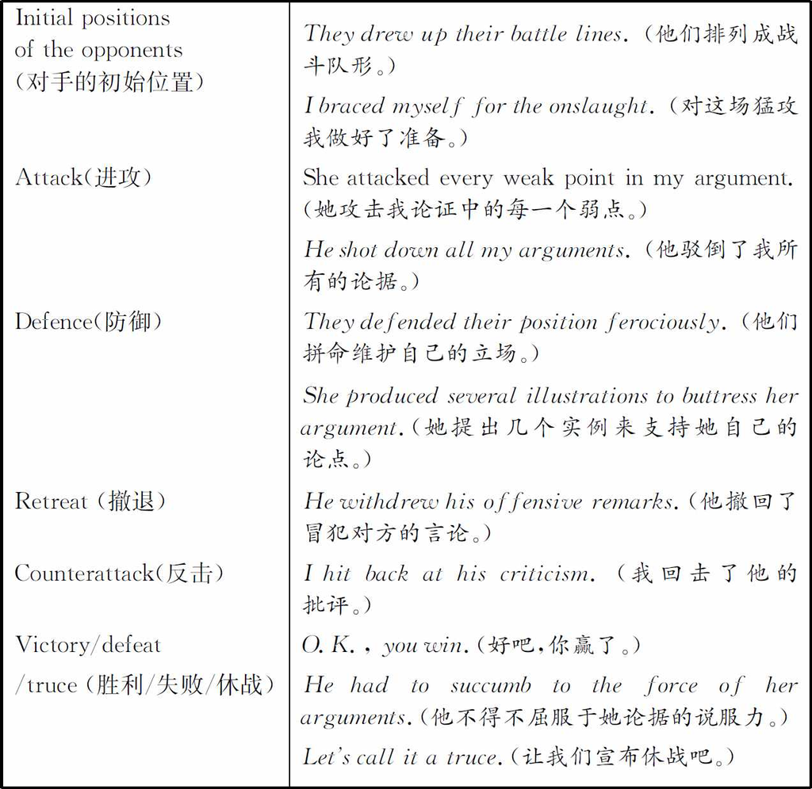

图3.6 BATTLE（战斗）和ARGUMENT（论争）这两个概念的结构类比以及语言实现（部分例子选自Lakoff和Johnson 1980/2003）

＋ AN ARGUMENT IS A BUILDING＋（＋论争是建筑物＋）

利用BUILDING（建筑物） 这一上位概念从诸如HOUSE（房屋） ，TOWN HALL（市政厅） 和 CASTLE（城堡） 等基本层次概念接收的属性，这第三个隐喻可以把论争的内容、进展和质量放在一起考虑。

We've got a framework for a solid argument.（我们有一个坚固的 论证框架 。）

If you don't support your argument with solid facts，it's whole structure will collapse .（如果你不用可靠 的事实支撑 你的观点，它的整个结构就会崩溃 。）

He is trying to buttress his argument with a lot of irrelevant facts，but it is still so shaky that it will easily fall apart under criticism.（他试图用一堆毫不相干的事实支撑 他的论点，但它还是那么不可靠 ，在别人的批评之下很容易崩溃 。）

We will show his argument to be without foundation .（我们将会证明他的论点毫无根据 。）

With the groundwork you've got，you can construct a pretty solid argument.（凭你已有的基础 ，你可以构建 一个相当牢固 的论证。）

＋ AN ARGUMENT IS A CONTAINER＋（＋论争是容器＋）

最后，在对论争的内容方面概念化时，我们利用了＋CONTAINER＋（＋容器＋）隐喻，它在以意象图式“内部-外部”为基础的映射域内起作用。从这个角度看，这个隐喻主要关注词语argument （论争 ）的最后一个意义（“支持或反对某事的理由”），论争被看作容纳物质的容器：

Your argument doesn't have much content .（你的论点没有多少内容 。）

That argument has holes in it .（那个论点有漏洞 。）

Your argument is vacuous .（你的论点很空洞 。）

I'm tired of your empty arguments.（我厌倦了你空洞 的论证。）

### 隐喻的结构能力Ⅱ：idea（思想）

Lakoff和Johnson所给的例子表明，他们并不关心给ARGUMENT（论争） 的意义下定义或提供范畴结构。相反，他们的出发点是ARGUMENT（论争） 这一概念，他们明确的目的是阐明人们是如何通过隐喻对这个概念进行概念化的。在对IDEA（思想） 这一概念的分析中（Schmid 1993：165以次；1996a：111以次），则选择了一个互补的、归纳的方法。从语料库和《牛津英语辞典》中选取词语idea 的实例，从这些实例出发，以分析概念IDEA的结构为目的，来考察隐喻表达方式。这样，就得出了下面三个主要的隐喻：

＋THE MIND IS A CONTAINER FOR IDEAS＋（＋头脑是装思想的容器＋）

＋IDEAS ARE OBJECTS＋（＋思想是物体＋）

＋IDEAS ARE ANIMATE BEINGS OR PERSONS＋（＋思想是生物或人＋）

第一个隐喻对我们理解IDEA（思想） 这一概念非常重要，它还是＋CONTAINER＋（＋容器＋）这一隐喻的变体。搜集到的材料清楚地显示，我们把我们的头脑看作容纳思想的容器。这个隐喻常常和第二个隐喻结合在一起。第二个隐喻把思想当作物体，或者更确切地说，当作货物。在很大一部分隐喻表达方式中，思想被概念化为转运的货物。我们谈论having （有 ），getting （得到 ），borrowing （借 ）甚至selling ideas （出卖思想 ）；某事或某人可以giving us ideas （给我们思想 ），我们可以put ideas （把思想放在 ）某处，比如说，into other people's heads （放进他人的头脑中 ）。

第二个隐喻，即＋IDEAS ARE OBJECTS＋（＋思想是物体＋），在空间的范围和形状，材料或物质等物体属性被表达出来时，也变得显而易见了。思想可以是：

big（大），little（小），slender（微弱），broad or sharp（宽广或尖锐）；

rigid（僵硬），strong or faint（强大或无力）；

bright（明亮），clear or hazy（清楚或模糊）；

supported（得到支持），dropped（被抛弃），thrown out（被抛出），shelved or fixed（被搁置的或被固定）

第三个隐喻在IDEAS和ANIMATE BEINGS（生物） 或PERSONS（人） 之间建立了联系。在这两个认知域的基础上，人们可以说思想impoverished （枯竭 ）或wild（ 怪异 ）；思想可以be adopted （被采纳 ），conceived （被构想 ）或killed （被扼杀 ）；可以get about （传开 ）；思想可以被概念化为offspring （子孙 ）或combatants （斗士 ）。正如在＋AN ARGUMENT IS A BATTLE＋（＋论争是战斗＋）的讨论中这一点已经很清楚那样，思想也可以被attacked （攻击 ）或surrendered （放弃 ）。

### 概念类型，丰富映射和贫乏映射

让我们重述一下对ARGUMENT（论争） 和IDEAS（思想） 这两个例子的研究所揭示出来的要点。有证据有力地证明，抽象概念确实是基于或“根据”更为具体的源概念，尤其是基本层次概念。隐喻映射可能直接发生于基本层次和目标概念之间。或者，这种联系也通过BUILDING（建筑物） 这样的上位概念来建立。再看看＋AN ARGUMENT IS A BUILDING＋（＋论争是建筑＋）这一隐喻，就很容易明白像HOUSE（房屋） 、TOWN HALL（市政厅） 和CASTLE（城堡） 等基本层次概念的突出属性是怎么用来构造ARGUMENT这种抽象概念的。相当常见的是，这类特定隐喻（specific metaphors） 的源概念是个事件概念，这个事件概念自身也是由几个其他的基本物体或基本行为概念组成的。例如，＋AN ARGUMENT IS A BATTLE＋（＋论争是战斗＋）这一隐喻的源概念BATTLE（战斗） 就是基本层次物体概念（GUN（枪） 、TANK（坦克） 、BOMB（炸弹） 等）和动作概念（FIGHT（打仗） 、ATTACK（进攻） 、SHOOT（射击） 、DRIVE（驱赶） ）的结合。

但是，也有像＋IDEAS ARE OBJECTS＋（＋思想是物体＋），＋IDEAS ARE PERSONS＋（＋思想是人＋）和＋IDEAS ARE CONTAINERS＋（＋思想是容器＋）这样的隐喻，它们的源概念不是特定的基本层次概念或其上位概念。相反，这些隐喻的源概念是我们所收集的关于在所处世界中遇到的物体、生物体和人的经验这种更为一般的概念经验的组合，这也是我们把这些隐喻叫做一般隐喻（generic metaphors） （不要与生物分类系统中的generic level （属层级 ）用法混淆起来）的原因。比如，在这些一般经验中，物体可以被得到、放弃、搁置、掉下，容器可以被倒空、装满液体并溢出，生物体可以被培育或杀死，人可以被收养、拥抱或攻击。因为这些普遍概念对我们来说极为熟悉，所以正如对IDEA（思想） 这一概念的讨论所表明的那样，它们很自然地成为向抽象目标概念隐喻映射的来源。

到目前为止，我们所勾画的是抽象目标概念通过特定隐喻和一般隐喻结合的隐喻构建。在这个过程中，大量的隐喻对应被建立起来，特别是在具体源概念和目标概念之间的隐喻对应，而一般源概念和目标概念之间的对应可能少一点。正是这种丰富映射（rich mapping） 强烈吸引了早期隐喻认知学者，以至于忽略了隐喻的其他类型。然而，正如Ruiz de Mendoza Ibañez（2000：111-113）正确指出的那样，隐喻的联系有很多，尤其是和具体目标概念（concrete target concepts） 的联系，着重于具体源概念的单一属性 <sup>(8)</sup> 。比如，这适用于John is a pig （约翰是头猪 ）这个例子。如前文所示，隐喻映射被映射域限制在几个对应上，集中于“肮脏”，而“贪吃”等方面则起着补充的但是次要的作用。其他众所周知的例子，如crane （起重机 ）作为一种建筑设备的用法中存在的动物隐喻，对应的数量比在理论论述中假设的要少得多，因为它的映射域受到相互关系“shape＜＞object”（形状＜＞物体）和“action＜＞motion”（动作＜＞运动）限制。这种贫乏映射（lean mapping） 是充分的，因为目标概念自身的属性配备充足，保证了概念化的成功，而隐喻只被用来突显（highlight） 一个或几个补充的属性（如在John is a pig （约翰是头猪 ）中约翰的无礼举止，起重机的形状和活动）。贫乏映射也可能发生在一个一般源概念（如PERSON（人） 概念）和一个具体目标概念之间。这些例子——传统上叫做拟人 （personification ）——不只是在动物和物体都像人一样思考、谈话、行动的童话故事和儿童读物中才能发现，在日常生活中，当我们谈论计算机或汽车（以及跟它们说话）时，就好像他们也是人一样。

### 隐喻映射：小结

尽管图表有过分简化问题的倾向，但是图3.7还是提供了一份认知隐喻分析基本要素的总结概述。图中显示，隐喻所做的基本上就是在源概念和目标概念之间建立概念联系。这个图表还（直观地以及以文字说明）表明，隐喻的各个方面是如何相互关联的：特定的源概念对具体的目标概念和抽象的目标概念都有影响。然而在前一种情况中（如＋A PERSON IS A PIG＋（＋某人是头猪＋）），隐喻转移基本上限于一个单一对应（“贫乏映射”），而抽象目标概念，如ARGUMENT（论争） ，IDEA（思想） 或ANGER（愤怒） 等却从具体概念，如BUILDING（建筑物） 或JOURNEY（旅程） 等获得了大量的属性。这些抽象目标概念还得到了与更一般的源概念的联系的支持，例如一般的OBJECT（物体） 概念，如在Ideas can be sold （思想可以出卖 ）（像物体一样）中，或者一般的CONTAINER（容器） 概念，如在Anger welled up in his body （他体内不断冒出怒火） （像容器中的液体一样）中；这些隐喻可能在贫乏的映射和丰富的映射之间发生变化。为了使这张图表完整，具体目标概念（如TREE（树） ，RIVER（河流） ，CAR（汽车） 这类动物概念，物体概念）可利用PERSON（人） 这个一般源概念实现拟人化；而这又是一个贫乏映射，而不是丰富映射。

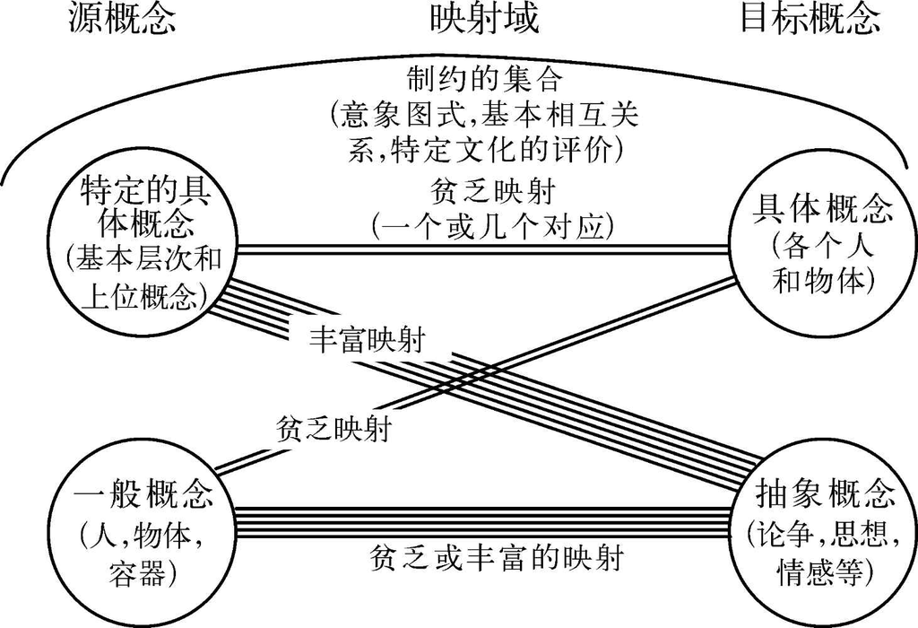

图3.7 隐喻映射：概观

不同的映射域也解释了概念隐喻为什么能实现不同的认知功能：

· 特定具体源概念和具体目标概念之间的贫乏映射主要用于突显（highlight） 目标概念的个别特征（如在John is a pig 中，John肮脏这一属性）。

· 特定的具体源概念和抽象目标概念之间的丰富映射，加上来自一般概念的补充映射，主要用于为抽象目标概念（如ARGUMENT（论争） ，IDEA（思想） ，情感概念）提供一个具体的概念结构（supply a tangible conceptual structure） 。

### 作为认知工具的转喻

当我们转到比喻语言的认知观时，不知怎么忽略了转喻在我们对世界的概念化中所起的作用。为了恢复平衡，本节我们将集中讨论，作为认知工具，转喻与隐喻有哪些相似之处，又有何种区别。

首先应强调的是，认知语言学家在对隐喻的论述中提出的两个重要看法都适用于转喻（Lakoff和 Turner1989：103）：二者本质上都是概念的，二者都可理解为映射过程。这意味着为隐喻选择的结构（源概念，目标概念，映射域）也可应用于转喻。源概念和目标概念是通过接近关系（部分-整体，整体-部分，以地方表人，以材质表物体等；见图3.1）连接起来的实体的认知对等。为了看看映射的第三个方面如何动作，必须考虑下面几组句子，来理解转喻中的映射域这一概念：

（1a）All hands on deck.（全体水手在甲板集合。）

（1b）All heads on deck.

（2a）The university needs more clever heads.（大学需要更多聪明人。）

（2b）The university needs more hands．

（3a）The White House has launched a tax-cutting campaign.（白宫发起了一场减税运动。）

（3b）The greenhouse has launched a tax-cutting campaign．

这些例子阐明了映射域是如何通过提供一个合适的解释语境来决定转喻映射的合适性的（回想一下为隐喻介绍的映射域，它是规定源概念和目标概念之间的对应的一组限制）。在前两组句子中（1a/b和2a/b）运用了身体部位与整个身体或人之间这种典型的部分-整体关系，但只有（a）句中的转喻是成功的。在句（1a）中的成功，归因于这样的事实：即由关键词deck （甲板）暗示的航行语境是全社会认可的，而且是与情景相关的。因为它包含了船上所要求的体力劳动的想法，所以“航行”为HAND（手） 和BODY/PERSON（身体/人） 之间的部分-整体联系提供了一个合适的映射域。用HAND（手） 这一概念代表体力劳动似乎是很自然的；然而，如句（1b）所示，HEAD（头） 和PERSON（人） 之间的转喻联系则并不同样适合航行这一语境。在句（2a/b）中，情况正好相反：映射域“大学”导致了（2a）中的HEAD（头） 和BODY/PERSON（身体/人） 之间的联系，这种联系关注人类的智力，而（2b）中以HAND（手） 和它的体力为基础的联系则没有太大的意义。

这个分析也可以转到其他类型的转喻上，如例（3a/b）表明的，只有（3a）能使人联想起“美国政府”作为合适的映射域。在这个还包括了减税观念的映射域中，处所概念WHITE HOUSE（白宫） 很自然地暗示着和PRESIDENT（总统） 之间的空间联系。GREENHOUSE（温室） 概念可能在园艺语境中看到，但并不真正地包括减税的观念，而这一点使人很难建立一个认可这一转喻联系的令人信服的映射域。

回顾一下提供给例（1）—（3）中句（a）表达的转喻的映射域，源概念和目标概念间的对应的数量在这里很显然不是决定性的——这种联系一律简化为接近关系，常常是部分-整体关系，或者是其他基本关系，如以地方代表机构或者以原因代表结果。更为重要同时更多变的是被语言社团作为映射域而接受的百科知识的数量 <sup>(9)</sup> 。在“航行”、“园艺”、“大学”和“美国政府”的例子中，映射域在很大程度上似乎与1.3节及本章前几小节中讨论过的概念（或认知模型）地位相当——想一想BEACH（沙滩） ，MONEY（金钱） ，JOURNEY（旅程） ，BATTLE（战斗） 或ARGUMENT（论争） 这些实例。这样一来，转喻所有的三个方面（源概念，目标概念和映射域）就都是一个认知模型的组成部分，这就解释了认知语言学家们为什么主张把原型的转喻限制在单个的认知模型内，而不像隐喻一样，是从一个模型到另一个模型映射。

然而，映射域这个概念要比这更灵活。映射域不限于单个的描写清晰的认知模型，它也可以组成一个百科信息的松散集合，而这些百科信息则是与不同却相关的认知模型相联系的。例如，在the whole table was roaring with laughter （满桌的人都呵呵大笑 ）中，当TABLE（桌子） 这一概念成为PEOPLE SEATED AROUND THE TABLE（围坐桌边的人） 这个目标概念的源概念时，映射域可以在DINNER PARTY（宴会） 这种相当具体的认知模型和SOCIAL EVENT（社交事件） 这一更为普遍的模型之间摇摆不定。理由是两个模型都提供了关于围桌而坐的人之间可能发生的宴饮交际关系的必要提示。与此相似，the house of Windsor （英国王室 ）中HOUSE（房屋） 这个源概念的转喻用法因其映射域而变得很活跃，它的映射域与很多认知模型有联系，如ROYAL FAMILY（王室） ，MONARCHY（君主制） ，甚至ENGLISH HISTORY（英国历史） 。尽管对于一心要简单划一地指派认知模型的语言学家来说，这可能令人沮丧，但是普通的语言使用者在处理这种比较模糊的映射域（可以与概念分类的“民间方法”相对照；见2.2节）时似乎没什么困难。

要圆满地结束转喻的讨论，有人可能还要提出规约化的问题。就隐喻而言，规约化限于映射域的巩固程度。确实，非规约化转喻的例子是可能存在的，如例（4）所示（两例均源自Barcelona2003：244）：

（4）We ate an excellent Mary yesterday.（昨天我们吃了一个美味的玛丽。）

（5）I have just bought a Picasso .（我刚买了一张毕加索。）

### 转喻映射：小结

包含转喻映射最终概述的图表（图3.8）是按照与隐喻映射小结（图3.7）相同的思路设计的。如图所示，转喻也理解为源概念和目标概念之间的关系。这种关系在公众认可的映射域内，而这个映射域在原型上对应于一个认知模型。

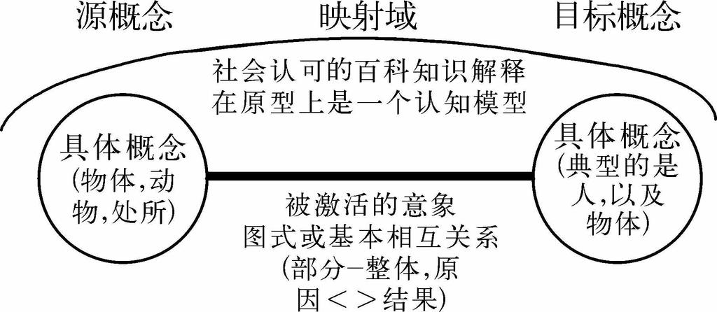

图3.8 概念转喻映射：概述

和隐喻比较，转喻中源概念和目标概念的范围通常限于具体概念。转喻的对应直接以意象图式或基本相互关系（“部分-整体”，“内部-外部”，“原因-结果”）为依据，而它们只是作为映射域的组成部分，间接参与隐喻。从这个意义上来说，转喻比隐喻更为基本。

此外，转喻也比隐喻更为直截了当：转喻的主要目的是指称一个实体，其原型就是人，这个实体被目标概念通过源概念来指称。简单的“代表”概念较贴切地表现了转喻的这种指称功能（referential function） （白宫“代表”或“使心理上达及”总统，桌子“代表”或“达及”围桌而坐的人等）。然而有的转喻，在用作表语时，其指称功能则让位于突显功能（highlighting function） ，如I'm all ears （我正洗耳恭听）（在这个转喻中，“耳朵”强调的是人的听力这种特征），而且，不难看出这类转喻非常接近于＋A PERSON IS AN ANIMAL＋（＋人是野兽＋）这类贫乏映射的隐喻。这使得有人提出，隐喻和转喻应当看作认知操作的渐变群（cline）（Ruiz de Mendoza Ibañez 2000：115）。

除了这些过渡现象，隐喻和转喻的互动还有很多其他方式 <sup>(10)</sup> 。这对将在下一节讨论的情感概念来说尤其如此。

### 练习

1．收集以下半身的身体部位（leg （腿），foot （脚），toe （脚趾）等）为源概念的规约化隐喻。指出：作为源概念，人体的哪些部位特别能产，并尝试解释为什么如此。

2．根据Quinn（1987），美国人用以对MARRIAGE（婚姻） 进行概念化的重要隐喻有：

＋MARRIAGE IS A MANUFACTURED PRODUCT＋（＋婚姻是人造制品＋）

如：we want to work hard at making our marriage strong ．（我们想努力使我们的婚姻更牢固。 ）

＋MARRIAGE IS AN ONGOING JOURNEY＋（＋婚姻是正在进行的旅程＋）

如：we went in a common direction .（我们向同一方向前进。）

＋MARRIAGE IS A DURABLE BOND BETWEEN TWO PEOPLE＋（＋婚姻是两个人之间持久的纽带＋）

如：they are tied to each other ．（他们被绑到了一起。）

找一找其他反映这些隐喻的语言表达方式。

3．找出英语和另一种你了解的语言中说明隐喻＋A WORD IS A COIN＋（＋词语是硬币＋）的语言表达方式。

4．讨论一下：在一些莎士比亚十四行诗中（如12，15，16，19，104和115），是如何通过隐喻对抽象概念TIME（时间） 概念化的。在这儿，普遍存在的源概念是什么，可以为这些隐喻设想哪些映射域？

5．试从一本词典中收集动物隐喻，如He is a real pig （他真是头猪 ）或者She is a bitch （她是条母狗 ），并用“源”和“目标概念”等观念加以解释。

6．尽可能多地收集以基本颜色概念为源概念的转喻（例如feel blue （感到悲伤） 或者green with envy （十分忌妒） ）。试找出以非基本颜色概念，如crimson （深红色） ，scarlet （鲜红色） ，turquoise （蓝绿色） ，ochre （赭色） ，olive （橄榄绿） 为源概念的转喻。为什么说调查的结果证明基本颜色词语具有基本属性？要了解更多的例子及其分类的意见，参看Niemeier（1998）。

7．Aitchison（2003：169以次）写道，当要求一个小孩描述一种非洲发型时，他说：“有很多蛇从他的头里面跑出来。”试编制几个类似的新创隐喻，并讨论涉及的源概念、目标概念及映射域。

8．看一看下面使用HOUSE这个源概念的惯用法及其意义。分析使这些说法成立的隐喻映射和转喻映射，并讨论其合理的映射域：

| to keep open house | “任何时候都宾至如归，对谁都热情好客。” |
| --- | --- |
| a rough house | “打闹，骚乱” |
| a full house | “剧院满座。” |
| a drink on the house | “喝酒，由酒吧老板付费。” |
| in the best houses | “处于上流社会。” |
| a house of cards | “没有事实根据的想法，非常不切实际的思想。” |

## 3.2 隐喻，转喻和情感范畴结构

我们都知道愤怒像什么样：人们怎么变得满脸通红，他们怎样开始发抖，他们怎样握紧拳头，怒气怎样在体内积聚直至爆发出来。若是恐惧，则完全是另一番情景：脸上失去血色，身体无法动弹，人们感到受折磨、被煎熬、不知所措。对认知语言学家来说，愤怒和恐惧的所有这些方面都在隐喻和转喻表达方式中得到了反映。

试图描写情感词语的意义远非易事。反映在词典里则是情感词语的定义往往表现出相当程度的模糊性和循环性。结果是，将anger （愤怒 ）释为强烈的或激烈的不快或敌意。Love （爱 ）用喜爱来定义而fondness （喜爱 ）又被描述为喜欢或爱。

类似的令人沮丧的状况在心理学家中普遍存在，他们多少代以来都试图解决情感难以捉摸这一难题。他们在经验主义的研究中唯一能找到的确凿的立脚点就是情感对身体的影响。当要求心理实验中的被试描述在愤怒、悲哀或快乐时他们有何感觉时，他们总是把生理体验包括进去，如体温升高，脉搏频率变化，心悸或出汗、流泪。换句话说，他们在情感和生理症状之间建立了联系，生理症状则被看作讨论中的情感的原因，或者更经常地，被看作结果 <sup>(11)</sup> 。

### 情感和生理转喻

回到3.1节引入的概念隐喻和转喻框架，我们发现情感和生理症状的联系使我们想起某些转喻映射，特别是在＋THE TONGUE STANDS FOR SPEECH＋（＋舌头代表言语＋）或者＋THE HAND STANDS FOR WRITING＋（＋手代表写＋）这样的转喻中观察到的原因-结果关系。这些相似性使得我们可以理解Kövecses和Lakoff（Lakoff 1987：382）为什么要假设一个普遍的转喻：＋THE PHISIOLOGICAL EFFECTS OF AN EMOTION STAND FOR THE EMOTION＋（＋某种情感的生理结果代表这种情感＋）。图3.9列出了对与英语语言表达方式中的情感有关的各种身体症状的认识。收集到的这些例子取自词典和上面提到的心理实验中被试的陈述。因此，它们反映了对情感的生理结果的朴素观点或“民间理论”，但不一定是客观的科学的观察。

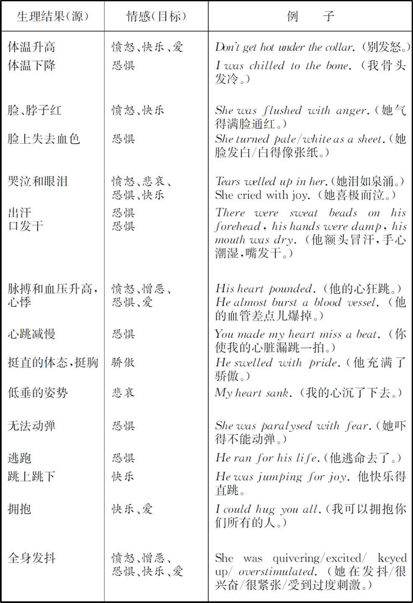

图3.9 情感的生理转喻选（据Kövecses，Davitz 1969和Shaver等1987多种出版物）

纵观图3.9，我们可以挑出其中说明生理转喻的潜力和局限性的三个方面。首先，我们发现，确实存在着一些好像对描写情感的概念结构有用的身体症状，因为它们为某种特定的情感所独具：体温下降，出汗，口干，脸上失去血色之于FEAR（恐惧） ，挺直的体态之于PRIDE（骄傲） ，低垂的姿势之于SADNESS（悲哀） ，跳上跳下之于JOY（快乐） 。很显然，这些生理现象帮助我们对讨论中的情感概念化，尤其是像挺直的姿势相对于下垂的姿势这种因对立而形成对比的时候。其他的例子还有体温下降（对应于FEAR（恐惧） ），和体温上升（对应于ANGER（愤怒） ，JOY（快乐） ，LOVE（爱） ）并列；或者脸色的苍白（又是典型的FEAR（恐惧） ），与脸、脖子部位的红甚至猩红（对应于ANGER（愤怒） ）形成对比。

### 转喻和隐喻的互动

这种互动的经典实例是以体温为基础的转喻与热隐喻之间的互动关系，是由Kövecses和Lakoff（Lakoff 1987：382以次）首次描述的 <sup>(12)</sup> ，这将在图3.10中以简化的方式加以说明。

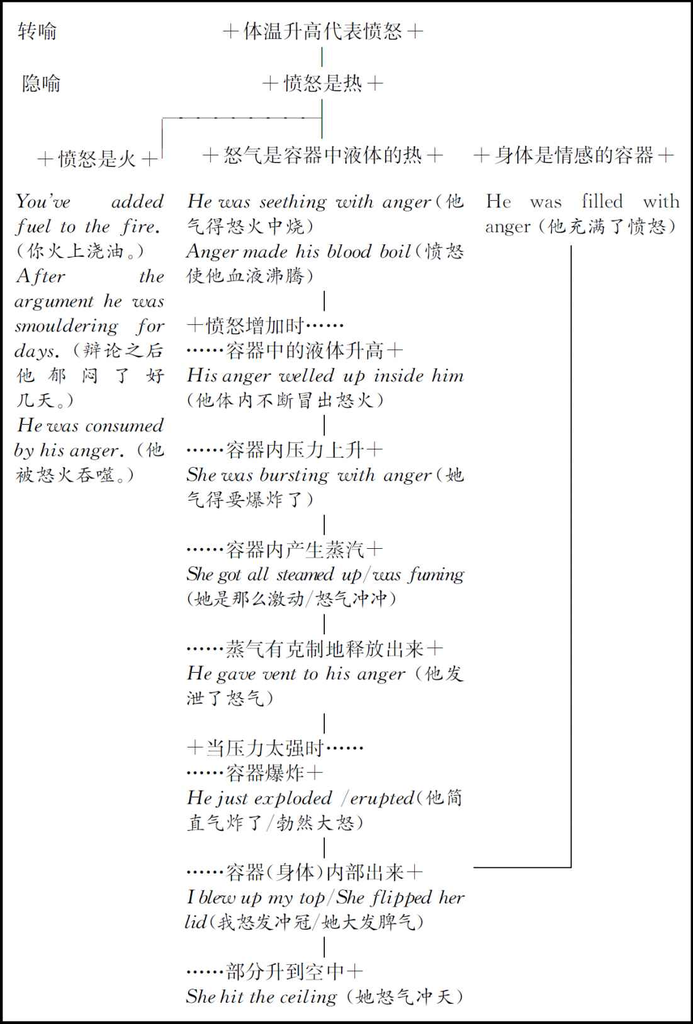

图3.10 用于ANGER（愤怒）的热转喻与热隐喻之间的联系（选自Lakoff 1987：381以次）

由生理转喻引发的基本隐喻是＋ANGER IS HEAT＋（＋怒气是热＋），如果我们想像一下以火和热液等形式所表现的热，这个相当抽象的原则将容易理解得多。图3.10看起来很清楚，这两个隐喻的应用，第一个（＋ANGER IS FIRE＋（＋怒气是火＋））不如第二个发达（＋ANGER IS THE HEAT OF A FLUID IN A CONTAINER＋（＋怒气是容器中液体的热＋））。虽然FIRE（火） 也是一个重要的、结合了许多动作和物体概念的基本层次事件概念，但是点燃、维持、熄灭等各个阶段，以及普通的火所涉及的燃料（木头、煤、油、气）似乎没有提供一个非常丰富的概念结构，以映射到ANGER（愤怒） 概念上 <sup>(13)</sup> 。

相反，第二个＋HEAT＋（＋热＋）隐喻，＋ANGER IS THE HEAT OF A FLUID IN A CONTAINER＋（＋怒气是容器中液体的热＋）有着丰富得多的概念背景。一个原因是它涉及更多的源概念，特别是像BOIL（沸腾） ，RISE（上升） ，STEAM（蒸发） ，FUME（冒烟） ，BURST（爆裂） ，EXPLODE（爆炸） 这样极富启发性的基本层次概念，多数被试都能对它们提出可观的属性清单。更重要的还是这个隐喻依靠着最重要的一般隐喻之一，即＋CONTAINER＋这一隐喻，在这里则以＋THE BODY IS A CONTAINER FOR EMOTION＋（＋身体是情感的容器＋）这种形式出现。

这种强大的隐喻潜力产生的结果就是图3.10中列出的大量的衍生隐喻。结合上一节讨论过的转喻，ANGER这一概念于是获得了非常丰富的概念结构。就ANGER（愤怒） 来说，一方面是隐喻，另一方面是转喻，它们的作用达到了相当的平衡。上文提到的生理结果因热隐喻及一系列其他隐喻而达到平衡，如：＋ANGER IS AN ACTIVE ENEMY＋（＋怒气是个活跃的敌人＋）（你跟它fight （打斗 ），struggle （搏斗 ），wrestle （摔跤 ））；＋ANGER IS A DANGEROUS AGGRESSIVE ANIMAL＋（＋怒气是一只危险而好斗的动物＋）（怒气可以是ferocious （凶猛的 ）和fierce （狂暴的 ））；最后是＋ANGER IS A NATURAL FORCE＋（＋怒气是一种自然之力＋）（怒气 overwhelms you （压倒你 ），engulfs you （吞噬你 ）和sweeps you （席卷你 ））。

然而，也有隐喻和转喻不平衡的情况。概念FEAR（恐惧） 支配着大量的转喻（它是图3.9中所列的情感中拥有最多转喻的），但似乎并没有吸引很多概念隐喻。除了刚刚提及的ANGER（愤怒） 的＋NATURAL FORCE＋（＋自然之力＋）隐喻外，Kövecses还列出了＋FEAR IS A VICIOUS OPPONENT OR TORMENTER＋（＋恐惧是邪恶的对手或克星＋）（恐惧preys （折磨你 ）和creeps up on you （沾上你 ））和＋FEAR IS A TRICKSTER＋（＋恐惧是骗子＋）（fear may deceive you （恐惧可能欺骗你 ））。

另一个极端以JOY（快乐） 为代表。几乎没有什么身体表现是专门表示JOY（快乐） 的，结果它就没有什么生理转喻，但是大量的概念隐喻弥补了这种不足。JOY（快乐） 可以作为贵重的商品（它received （被接受 ）或bought （被购 买）），作为隐藏的物体（人可以searches （寻找 ）或者strives for （争取 ）它），作为生活得很好且有着令人愉快的感觉的动物（purring with delight （高兴得发出咕噜声 ），wallowing in delight （高兴得打滚 ））来体验。JOY被比作光（you radiate with joy （你容光焕发 ）），JOY是活力（it is spry，lively，puts pep into your life （它是充满生机的，活跃的，为你的生命注入活力 ））。用更专业的术语来说，这些隐喻把广泛的包括事件、动作和物体的基本层次源概念映射到JOY（快乐） 这一抽象情感上。另外，JOY（快乐） 还利用了＋CONTAINER＋（＋容器＋）隐喻，但有一个重要差别是容器不爆炸，只溢出；容器爆炸是ANGER隐喻的典型。最后，在＋JOY IS BEING LIFTED UP＋（＋快乐是正被升起＋）这一隐喻中还利用了“up-down”（“上-下”）这一意象图式（I'm six foot off the ground，I'm on cloud nine，she's walking on air （字面意义：我离地6英尺；我在九重云上；她正在空中漫步。 皆为“高兴至极 ”之意））。

LOVE（爱） 这个概念甚至是一个更不平常的例子。转喻的数量也相对较少（当然，突出的是建立在性欲基础上的转喻），但是在概念隐喻的数量方面，LOVE（爱） 超过了所有其他的情感。其中很多隐喻和JOY（快乐） 是共同的。此外，有大量隐喻很自然是建立在与性欲的转喻关系的基础之上的（＋LOVE IS A NUTRIENT＋（＋爱是养料＋），＋LOVE IS APPTIZING FOOD＋（＋爱是开胃食物＋）），还有令人喜爱的和魔力、神的类比（＋LOVE IS MAGIC＋（＋爱是魔力＋），＋THE OBJECT OF LOVE IS A GODDESS＋（＋爱的对象就是女神＋）），这种诗意的来源还是特别明显的。和JOY（快乐） 相比，不同寻常的是LOVE（爱） 不仅仅是由“积极”隐喻构成的，而且看来也吸引了大量“消极”的概念隐喻，其中有＋LOVE IS WAR＋（＋爱是战争＋），＋LOVE IS HUNTING＋（＋爱是捕猎＋），＋LOVE IS DISEASE＋（＋爱是疾病＋）。这一点也适用于＋CONTAINER＋（＋容器＋）隐喻，LOVE（爱） 的特点不仅被认为是液体溢出容器，而且也被认为是容器的爆炸，而后者同时是ANGER概念的典型特点。尽管很容易看到在诗歌中这些消极的隐喻可能（实际上常常如此）用于渲染爱的主题，但是它们不太可能融合为一个单一概念的概念结构。问题在于LOVE这个概念是否由几个相互独立的范畴组成（如“GENTLE”ROMANTIC LOVE（“温和的”浪漫的爱） 和PASSIONATE LOVE（热烈的爱） ），我们是否应该假设只有一个（也许是原型的）概念，它有几个变体。

在关于隐喻和转喻的互动这一点上，我们可以说的是，似乎有一条补偿原则在起作用，即隐喻和转喻相互交替使用。ANGER（愤怒） 在隐喻和转喻这两种认知过程之间达到了平衡，而FEAR（恐惧） 则主要依靠转喻，JOY（快乐） 和LOVE（爱） 的概念结构更多地依靠隐喻。

然而，尽管可以存在大量的关于LOVE（爱） 和JOY（快乐） 的隐喻，这些隐喻还是不能单独为这两种情感概念的任何一个提供清晰的概念结构，因此这些隐喻并不真正补偿JOY（快乐） 和LOVE（爱） 所缺乏的转喻。隐喻和转喻可以一起给这些情感概念提供一定的概念内容，但是它们不能用来严格区别不同的情感概念，就像属性可以用来帮助区分CHAIR（椅子） 和TABLE（桌子） 这种物体概念那样。

对于到现在为止我们已经讨论过的许多其他情感概念，也必须表达类似的保留意见。当我们想到英语有大量的情感词语，而且可能有同等数量的情感范畴尚待考虑，问题就变得甚至更加棘手了。

### 情感词语和基本情感概念

Johnson-Laird和Oatley（1989）从不同的词典里收集了英语的情感词语，他们的语料不少于590项。为了对英语中丰富的情感词语有个认识，这里列出了由Wierzbicka（1986，1988）搜集、分析的和FEAR（恐惧） 有关的词项表。

fear：afraid，scared，fright，frightened，terrified，petrified，horrified，dread，alarmed，panic，anguish，anxiety，worried，concerned，apprehension，shame，

embarrassment

为了处理这一大堆情感词语及其中的情感，也许是受到反映在中世纪四情理论中的传统的启迪（Geeraerts和Grondelaers 1995），哲学家和心理学家长期以来试图区分基本的和较边缘的情感词语，以试图建立一个基本情感系统。Descartes等人提出的18世纪的看法，其基础都是哲学论证；而较近的尝试则试图从神经兴奋模式，从脸部表情，以及从我们更关心的情感词汇推导出基本情感，等等 <sup>(14)</sup> 。

Johnson-Laird和Oatley（1989）采取的是语言学方法，他们的情感词表已经提及。他们的假设是某些情感词语在意义上是基本的，不可分析的，它们不能分解成属性或其他更基本的情感（这是Langacker1989a：149也支持的观点）。意思就是，像JOY（快乐） 或ANGER（愤怒） 这样的基本情感概念通常用作描写EUPHORIA（欢快） ，EXUBERANCE（生气勃勃） ，FURY（暴怒） 或RAGE（狂怒） 这类非基本情感概念的参照点，而不是相反。因此，鉴别基本情感的一个好办法就是考察一种语言中的情感词汇，并试着以属性来描写它的情感词语。这将滤除所有可分析的情感词语，因此经过这一过程而剩下的就必须看作是不可分析的或基本的。这个程序的结果在意料之中。由此形成的基本情感集合和最近其他一些提法非常相似，包含了（它的改进版；Johnson-Laird和Oatley 1992）图3.11中汇集的所有的基本情感。

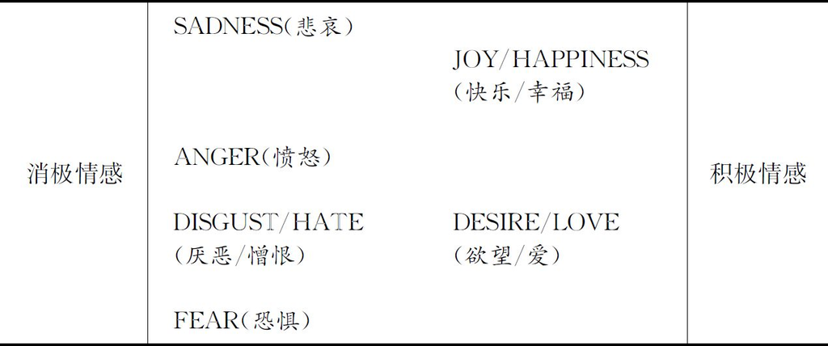

图3.11 英语基本情感词语的提法（像DISGUST/HATE这种双标记，表示基本情感可以看作短暂的状态（DISGUST）或性情（HATE），见Ungerer 1995：187）

尽管基本情感的这个表似乎有理，但Johnson-Laird和Oatley关于基本情感事实上不可分析的主张不能搁置不论。就离散的、抽象的属性而言，这个主张可能是对的，Johnson-Laird和Oatley也正是用这类属性，如强度，原因和目标-方向等来滤除非基本情感词语。然而如果我们考虑转喻和隐喻的概念潜力，我们就不能真的认为基本情感词语就是不可分析的。我们已经看到，有前面几节，几乎只涉及基本情感的例子，这些概念通过转喻跟重要的身体功能相联系，另外，也通过隐喻跟大量基本层次概念相联系。这意味着大量的身体感觉和基本层次概念被映射到基本情感概念上，或者从另一角度来看，基本情感概念通过寄生范畴化大量借用基本经验。问题是如果在认知语境中我们拒绝把概念的不可分析性当作衡量情感基本性的准绳，那么我们如何界定它们的基本地位呢？在这一点上，再次回顾出现过的那组衡量物体和生物体的基本层次范畴的标准（2.1节），可能有所帮助。如果我们不理会表示JOY（快乐） 的跳上跳下，表示ANGER（愤怒） 的爆炸或表示SADNESS（悲哀） 的低垂体态这样类似卡通的意象，那么作为标准之一的完形感知，就不得不被拒绝用于情感概念。第二个标准，大量存在的相互关联的属性集束，也不能像用于苹果或汽车这些具体物体时那样使用。理由是，正如我们已经看到的，情感可观察到的属性稀少，而且常常是模糊的。因此我们大约剩下了三个标准：样本合格性等级，基本层次词语在形态上的简单特征以及它们最先出现于我们的头脑、孩子习得时早于相关词语这一发现。

从后两个标准出发，我们很容易从图3.11得出这样的结论：大部分基本情感词语，不论是名词（anger，hate，fear，joy，love ）还是形容词（sad，happy ），都有着简单的语言形式，而非基本情感词语常常不是这样——比较一下上表中的frightened，terrified，petrified，horrified，alarmed，anxiety，apprehension 和embarrassment 。基本词语最先出现在我们头脑中，最先被孩子习得，这也是众所周知的。至于样本合格性等级，心理学实验至少间接地（因为有些实验不是针对基本情感，而是针对上位概念EMOTION（情感） ；Fehr和Russel 1984）证实了我们的直觉。结果是，基本情感的候选成员确实具有很多我们已发现的具体的基本层次概念的典型性质：它们都被看作原型的范畴成员，而其他情感，如上面列出的FEAR（恐惧） 的其他变体，则被认为是较边缘的成员。基本情感并不一定支配可观察到的属性，但它们的确吸引了大量的概念转喻和隐喻：总而言之，可以把它们当作参照点，来引导我们通过难以捉摸的情感概念域。

既然有基本情感概念，把EMOTION这个更一般的概念看作它们的上位概念似乎也就很自然了。在与具体物体的类比中前进一小步，那么，这个主张就会是：EMOTION这个概念的主要功能是选出并突显相关的基本层次概念的共有突出属性，或者，从另一角度来看，是依据这些属性来“汇集”基本层次概念。

为了证实这一主张，我们必须找出为所有主要情感所共有的特征以及那些突出到要用emotion （情感 ）这个词表达的特征。我们已经知道，情感概念现在还没有可观察到的特征清单，只有大量的转喻和概念隐喻。我们从材料中筛选出大多数情感共有的并且可被视为等同于突出属性的条目，得到了汇集在图3.12中的列表。看这张图时，对认知语言学家来说，有趣的方面之一是＋CONTAINER＋（＋容器＋）隐喻也在共有特征之列。但是只有CONTAINER（容器） 更为一般的方面（其本身就已被理解为“一般”概念；见前文）似乎是所有情感共有的。如果我们考虑在容器中实行的行为，那么，各种基本情感存在显著的差别：正如已经表明的那样，容器可以爆炸以表示ANGER（愤怒） ，它可以随JOY（快乐） 渐渐溢出，我们还可以加上：在SADNESS（悲哀） 这一情形中，容器可以被排干。所以，为了把情感是某种充满我们的东西这一非常模糊的感觉概念化，我们不得不回到某个基本情感概念上，这是寄生范畴化的又一实例，这次是在上位概念EMOTION和基本情感概念之间寄生范畴化。

从整体上考察图3.12的转喻和隐喻，我们可以说它们都和情感的发展过程有关，包括外在来源，常常不可抵挡的发作，当它出现时它对我们的控制和（更暂时地）它的终结。这表明情感所共有的是一个包括几个阶段的序列，这个发现激励着心理学家和认知语言学家一步步去展开所谓的情感情节。

| 转喻 | ＋身体的颤动代表情感＋ |
| --- | --- |
| 隐喻 | ＋情感突然由外部到来＋ |
|  | The emotion strikes，casts，hits you （情感打中，投中，击中了你 ） |
|  | ＋情感是种自然之力＋ |
|  | It overwhelms you，sweeps over you （它压倒你，席卷你 ） |
|  | ＋情感是活的生物体＋ |
|  | It grows，wilts and dies （它生长，枯萎，死亡 ） |
|  | ＋出现即情感的存在＋ |
|  | The emotion stays，goes away，comes back （情感停留，逝去，回来 ） |
|  | ＋情感是容器中的液体＋ |
|  | ＋身体/眼睛/心/其他器官是情感的容器＋ |
|  | I am full of/filled with the emotion （我充满/装满了感情 ） |

图3.12 支持概念EMOTION（情感）的主要转喻和隐喻（集自Kövecses的出版物）

### 情感情节和原型性

从本书第一章开始，不应将认知范畴看作孤立而静止的单位这种观点，我们是一直坚持的。我们发现，范畴必须放在它们的概念语境中，以更大的认知模型为背景来考察，这些认知模型很显然有时就必须包括时间顺序（见1.3节）。这种调查研究的方法也是语言学家和人工智能学者所追求的，而且在这种研究方法中，他们提出了像“框架”、“脚本”、“故事”和“情节”这类概念。这些概念我们将在第五章进行详细的讨论。我们暂时只看一些给情感提出的情节，这也将圆满结束我们对情感概念的考察。

图3.13简洁地表现了Kövecses和Lakoff为ANGER（愤怒） 和FEAR（恐惧） 提出的情感情节。该图显示，情节中的原则是把情感概念放入一个更大的序列，包括情感的（第一阶段的）起因和（第五阶段的）结果。尽管这些扩展都有心理学上的情感理论的支持，但大多数转喻和隐喻指的都是Kövecses（1991：40）所谓的情感的“本质”，即第二阶段。而（第三、第四阶段的）控制或失控和核心的第二阶段联系更紧密，并可得出一些概念隐喻，至少ANGER（愤怒） 是这样。确实，如果我们再次检查图3.10提供的ANGER（愤怒） 的隐喻列表，就会发现它们的序列简洁明了地反映了从情节的第二阶段到第三、第四阶段的发展过程：ANGER（愤怒） 加热了容器里的液体，液体升高，压力上升，产生了蒸汽（所有这些隐喻都属于第二阶段）；然后气体有控制地释放（第三阶段）；如果失败了，容器就会爆炸，碎片飞到空中（第四阶段）。总之，人们完全可以认为下边这种观点存在某种合理性：ANGER（愤怒） 这个概念可以用有先后顺序的情节方式描写，在这个情节中，核心阶段得到隐喻的充分支持 <sup>(15)</sup> 。

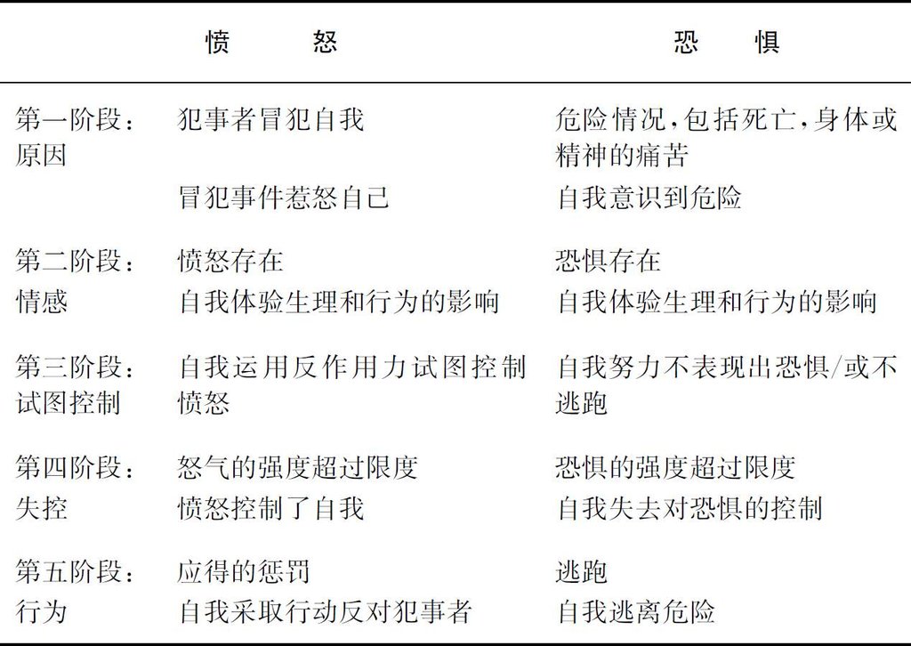

图3.13 ANGER（愤怒）和FEAR（恐惧）的情节（基于Lakoff 1987：377以次和Kövecses 1990）

不过，这个观点还有一个问题就是，只就ANGER而言，这种情节确实有说服力，对其他适用相似隐喻的消极情感，如DISGUST/HATE（憎恶/恨） ，也许也有说服力。而就FEAR来说，如果我们把注意力集中在逃跑这种作为结果的行为上，而忘记另一种可能，即因恐惧而感到不能动弹，只有在这种情况下，情节才能顺利展开。更成问题的还是像JOY（快乐） 这种积极情感概念。对此，Kövecses认为控制出自阻止我们表现JOY（快乐） 的社会约束。至于LOVE，即使Kövecses也承认，ROMANTIC LOVE（浪漫的爱） 这种他宣称的“理想模型”，也既缺乏原因，也缺乏控制方面；因为失控是瞬间的、不可解释的。为了挽救情感情节的这个蓝图，他建立了“典型模型”（LOVE LEADING TO MARRIAGE（导致婚姻的爱） ）来替代ROMANTIC LOVE（浪漫的爱） ，并声称“典型模型”包括了控制，而爱也被导向婚姻行为。这样看来，就ANGER（愤怒） 和其他消极情感而言，情节观点是一个相当有力的描写工具（尽管有局限）。然而，对JOY（快乐） 和LOVE（爱） 这样的积极情感来说，要给范畴结构赋予这样一种形式就要困难得多。Kövecses和Lakoff提出的情节还存在另一个问题，那就是他们对各种情感概念具有的隐喻和转喻全都没有作出说明。

最后，更全面地谈谈对这个问题的看法。这里对情感情节和原型性的讨论使得下面这点显而易见，即情感概念的结构远未清晰。不过，认知语言学家已经开辟了研究的新途径，这些研究途径到现在已经产生了下面的研究结果：

· 情感概念是由和生理结果的转喻联系构建的。

· 受这些转喻的触发，隐喻联系由具体的基本层次概念建立，这一点对情感的概念结构也有很重要的作用。

· 隐喻的作用对JOY（快乐） 和LOVE（爱） 等情感概念来说是本质的，它们较少得到生理转喻的支持。

· 有的情感概念，特别是消极情感概念，如ANGER（愤怒） 和FEAR（恐惧） ，可以理解为情节，这种情态包括原因、实际的情感、控制、失控和结果行为等阶段。对JOY（快乐） 和LOVE（爱） 等积极情感而言，这类认知模型不那么令人信服。

· 语言学的和经验主义心理学的证据显示，大约有六种情感概念（SADNESS（悲哀） ，ANGER（愤怒） ，DISGUST/HATE（厌恶/憎恨） ，FEAR（恐惧） ，JOY/HAPPINESS（快乐/幸福） ，和DESIRE/LOVE（欲望/爱） ）可以看成是基本的，这种基本地位和具体的基本层次概念之间存在某种平行性。

### 练习

1．本节的引言里以转喻和隐喻粗略地描述了ANGER（愤怒） 和FEAR（恐惧） 。试对SADNESS（悲哀） 和DISGUST/HATE（厌恶/憎恨） 做出类似的说明。你的描述符合图3.13中提出的情节吗？

2．在3.1节的练习1中曾要求指出身体的哪些部位容易充当隐喻和转喻的源概念。现在把注意力集中到情感上，用源概念分析图3.9中列出的转喻。试找出身体的某些部分和方面更易成为情感的源概念的原因。

3．如果你的母语不是英语，那么试找出你的语言和文化中的基本情感词语，并和这里论述的英语词语进行比较。

4．研究下面的情感概念：PRIDE（骄傲） ，ADMIRATION（钦佩） ，GRATITUDE（感激） ，PITY（同情） ，EMBARRASSMENT（尴尬） ，SHAME（羞愧） ，GUILT（内疚） 。你能发现这些概念和任何其他基本情感之间的紧密联系吗？试找出它们不够基本的原因。

5．试在几本词典中查看情感词语的定义，如anger （愤怒） ，rage （大怒） ，hate （憎恨） ，disgust （厌恶） ，fear （恐惧） ，panic （惊慌） ，love （爱） ，affection （友爱） ，并判断这些定义是否有益于描写这些情感。这些定义利用了转喻和隐喻吗？

## 3.3 作为思维方式的隐喻：来自科学和政治的例证

如果隐喻不仅是文体的修饰，而且是一种思维方式，那么就没有理由认为这种潜力只允许用于构造存在于某些抽象词语中的概念，而不能用于揭示我们处理世界上复杂的科学、政治和社会问题的方式。因此，认知语言学家和哲学家已经一起来研究概念隐喻的这些更普遍的作用。

隐喻的意义很丰富，它们不仅把两个孤立项联系起来，而且把多元范畴或多元认知模型联系起来。只拣一个我们讨论过的较简单的例子（见3.1节）：＋AN ARGUMENT IS A BUILDING＋（＋论争是建筑物＋）这一隐喻以源概念（BUILDING（建筑物） ）为基础，这个源概念提供了确实的完形和大量的属性。建筑物有地基，由墙、窗和顶构成，通常构造坚固，能提供安全保护；但是它也可能装配马虎，这样墙可能开裂，整个结构也可能倒塌。建筑物的所有这些特点都能被映射到目标概念上，可以帮助我们对抽象概念“论争”进行概念化和解释。

这第二个方面，即隐喻的解释潜力，没能逃出总在寻找解释工具的语言学家的注意。

### 隐喻和语言现象描写

隐喻如何用于语言描写，一个显著的例子是Langacker（1987a：452以次）用的＋BUILDING BLOCK＋（＋砌块＋）和＋SCAFFOLDING＋（＋脚手架＋）隐喻，二者都是他关于复合词和合成表达方式分析（这是2.3节讨论过的一个话题）的组成部分。他的出发点是对＋BUILDING BLOCK＋（＋砌块＋）隐喻给予严厉的批评。在Langacker看来，这个隐喻“把合成表达方式的意义看作是以某种合适的方式，将几个部分的意义简单地堆积在一起组成的”（1987a：452））。＋BUILDING BLOCK＋（＋砌块＋）隐喻用于像apple juice （苹果汁 ）或者wheelchair （轮椅 ）（我们2.3节中的例子）这样的复合词，就意味着我们把词语apple 和juice 或者wheel 和chair 当作建筑材料，用它们构造复合词就像我们用砖或水泥或木块建造房子（或者可能是玩具房子）一样。块儿可能大可能小，可能并排放在一起，或者一块一块地叠加起来，可能被一层灰泥或钉子或螺钉连接起来，但是不管我们偏爱哪一种办法，基本的解释信息还是这两个词语及其中的概念组成了该复合词。正如我们所见，就wheelchair （轮椅 ）来说，这完全没有说服力，因此，Langacker不愿意接受＋BUILDING BLOCK＋（＋砌块＋）隐喻作为合成构词法的可靠解释，也就可以理解了。

然而，作为一位认知语言学家，他意识到这个隐喻是个强有力的解释工具，不能只因从组合性和可分析性上提供抽象的另一种解释就毁除它，这才是Langacker的真正目的。也正因为如此，他提供了另一个隐喻，即＋SCAFFOLDING＋（＋脚手架＋）隐喻。这个隐喻表示，复合词的组成成分（如wheel 和chair ）及其概念在很大程度上只是手头的建造工作的脚手架。我们知道，WHEELCHAIR（轮椅） 这个概念从其他源概念衍生了很多属性，以致于WHEEL和CHAIR的作用变得越来越不重要。NEWSPAPER（报纸） 和AIRPLANE（飞机） 构词过程则达到了这样的阶段：脚手架已是多余的，可以撤掉。毋庸赘言，SCAFFOLDING（脚手架） 概念在细节上也很丰富，很适合用于反对和取代砌块解释。

除了构词法，Langacker还为句法过程提供了重要的隐喻，这将在4.2节讨论。这里我们将看看另一个在描述词汇范畴时至关重要的，因而称作家族相似性原则（1.2节）的隐喻解释。不难发现，这条“原则”建立在＋THE MEMBER OF A CATEGORY ARE A FAMILY＋（＋范畴的成员是一个家族＋）这一隐喻的基础上，这既解释了它的力量又解释了它的模糊性。家族相似性原则这么强大有力，是因为FAMILY（家族） 是一个非常丰富的源概念，就人的范畴化来说也是一个很突出的概念。FAMILY这一概念暗示了各种各样的相似性——那些与脸或身体的外表，相似的行为举止，相似的言语习惯等有关的相似性，但它也考虑到了家族成员个体之间或大或小的差别。这使得我们很容易把＋FAMILY＋（＋家族＋）这一隐喻看作范畴成员资格的刚性定义的柔性替代物。

家族相似性可能有一个缺点，那就是它有几种不同的意思。它可以指某些范畴的成员显然没有一个共同的属性（这是Wittgenstein的观点），或者，它也可以指包括全范畴属性的家族成员之间丰富的全面关系（这是理解Rosch和Mervis“家族相似性的标准”的基础）。如果我们想要更精确，就必须区分家族相似性的两种解释：一种是把家族相似性定义为AB BC CD类型间的关系（这里的A，B，C和D指属性），另一种是把它解释为∑属性范畴 （即范畴所有属性的总和）。

在认知语言学领域之外，我们发现很多其他的语言学方法都利用了解释性隐喻。结构主义的“分布”和“直接成分”概念都建立在（＋ELEMENTS DISTRIBUTED ARE OBJECTS SPREAD OUT＋（＋分布成分是分散的物体＋），＋IMMIDIATE CONSTTUENTS ARE OBJECTS CLOSE TOGETHER＋（＋直接成分是紧邻的物体＋））这些空间隐喻的基础之上；转换语法的隐喻概念有嵌入、套置、转换，等等；配价语法借用了先是适合于化学的隐喻，即＋THE VALENCY OF AN ELEMENT IS THE STRENGTH OF AN OBJECT＋（＋一个成分的价是一个物体的浓度＋）这一隐喻。正如我们认知语言学的例子一样，这些隐喻包含的解释还可以是另一种、通常也是更抽象的方法。

当我们转到可能被认为是源自语言描写的最强有力的隐喻，即＋PREDICATE＋（＋谓语＋）隐喻时，这一点就再也不确定了。这个隐喻将一个古老的源概念（predicate 意思是“它是对主语进行的陈述”，《牛津英语辞典》）从语法描述转移到逻辑和人工智能等相关学科。这个隐喻以最简单的方式利用了这样的事实，即在一个像Peter is working 这样的句子中，谓语is working 是对主语Peter 的陈述。PREDICATE（谓语） 和SUBJECT（主语） 这两个概念及其关系是众所周知的，当然可以把它们看成是语法的朴素民间模型的组成部分，就像在学校里教的那样。PREDICATE和SUBJECT之间为人熟知而千丝万缕的联系，使得这两个概念有可能充当源概念，来描写逻辑领域中假定存在于（逻辑）PREDICATE（谓词） 和（逻辑）ARGUMENT（主目） 这两个目标概念之间的更为抽象的关系。这时隐喻的模糊性和开放性可能非常有用，因为逻辑谓词不一定是动词，而逻辑主目不一定是名词短语，但是二者代表着一种观察语言的更为抽象的方法。

正是由于这种抽象性，事实上就可能很难给逻辑谓词及其主目之间的关系找到另一种解释，而这种解释又能和＋PREDICATE＋（＋谓语＋）这一隐喻提供的信息具有同等的解释力。因而我们达到了这样一个认识阶段，在这里，隐喻不仅仅是把一个抽象概念变得更具体，隐喻实际上似乎还构成了抽象概念。或者，像哲学家Boyd所说的，我们得出了一个观点，隐喻“构成了它所表达的理论，而不仅仅是注释性的”。（Boyd 1993：486）

### 科学中的隐喻：解释性的还是结构性的？

正如Boyd和其他人揭示的 <sup>(16)</sup> ，隐喻在科学中无处不在。其中很多主要是出于注释性（即解释性）目的而引入的。计算机科学中使用的大多数隐喻看起来尤其如此。很多人性化的程序都提供了一个显示屏，它和概念OFFICE（办公室） 建立了隐喻关系。屏幕是可以被清理干净的桌面，有文件归档用的文件夹，可以暂时保存文件的写字板，窗口可以打开和关闭，多余文件可以扔进垃圾桶。只有把程序功能的这些简单然而丰富的解释跟那些非隐喻的、常常用于专家程序里的缩写指令（例如CLS表示“clear screen”（清屏），MD表示“make directory”（建立目录），Rd表示“remove directory”（删除目录））相比较以后，＋COMPUTER WORK IS OFFICE WORK＋（＋计算机工作是办公室工作＋）这一隐喻的教学价值才变得真正明显起来。

除了建立在办公室语境基础上的隐喻，程序还利用动物和疾病隐喻。COMPUTER MOUSE（计算机鼠标） 这个概念就是一个这样的例子，该隐喻绝妙地把动物的外表和可能的活动都映射到跟踪球工具（它原先的名字）这一概念上，而实际上并没有解释它背后的抽象原理。

隐喻解释的另一领域是计算机程序故障。在这一方面最早的隐喻可能是＋BUG＋（＋臭虫＋）隐喻，当程序出错时我们很自然地就会使用这个隐喻。更为复杂，也更为骇人的是＋VIRUS＋（＋病毒＋）隐喻，它跟＋WORM＋（＋蠕虫＋）一起加入了计算机词汇。就＋VIRUS＋而言，人们把计算机出现故障与在人或动物体内引起感染的神秘的而看不见的病毒扩散联系起来。尽管普通的语言使用者对这种叫病毒的生物知之不多，但是他们对它于人或动物的可恶的影响可能有丰富（哪怕是间接的）经验，而这个源概念被映射到计算机病毒这个目标概念上。这种结果和我们遇到的＋FAMILY＋（＋家族＋）隐喻（它构成了家族相似性原则的基础）相似。隐喻解释也许终究是模糊的，但是它似乎满足了一般计算机使用者的概念需求，因此对他们来说，这些隐喻不仅仅实现了解释功能，而且对计算机故障的概念化来说还是结构性的。

当然，计算机科学家会寻找更精确的解释，而遇到外行时，也会把＋VIRUS＋（＋病毒＋）隐喻当作有用的工具。因此对他们来说，计算机领域的＋VIRUS＋（＋病毒＋）隐喻和其他隐喻是注释性的，而不是像Boyd所说是结构性的。但是正如Kuhn（1993：538）所说的，在有的自然科学领域中，隐喻似乎不仅对通俗模型，而且对科学模型而言，也是结构性的。他的例证是物理学家Bohr提出的由原子核和电子构成的原子轨道模型。通过把原子核、电子的排列与太阳、行星之间的互动进行比较，换句话说，也就是利用＋THE ATOM IS A（MINIATURE）SOLAR SYSTEM＋（＋原子是（微型的）太阳系＋）这一隐喻，起码可以很方便地解释这一模型。图3.14更详细地显示了隐喻对应。

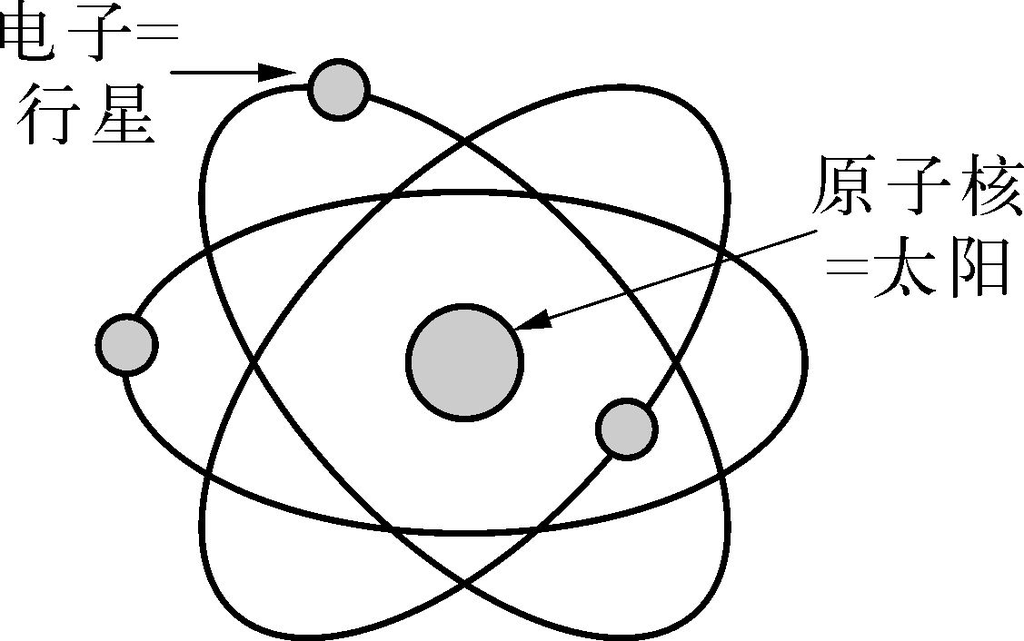

图3.14 解释为＋THE ATOM IS A（MINIATURE）SOLAR SYSTEM＋（＋原子是（微型的）太阳系＋）这一隐喻的原子结构

对外行来说，这种情况可能类似于计算机科学中的＋VIRUS＋（＋病毒＋）隐喻。

和通俗的解释相对照，Bohr对原子核和电子的科学定义借助了一些微小的带电的物质，它们被认为是在力学定律和电磁学原理之下相互作用。物理学家的任务是确定这些定律中的哪一个是适用的，并最终导致了量子理论的建立。但是，物理学家并不是非隐喻地工作；他们也利用了一个从根本上基于原子核、电子与小乒乓球或台球的类比的模型，因此这个模型看起来非常像图3.14呈现的那个模型。和外行的观点不同的是科学家不是把＋NUCLEUS AND ELECTRONS ARE PINGPONG BALLS＋（＋原子核和电子是乒乓球＋）这个质朴的隐喻用作对原子的一种解释。隐喻在这儿只是用作衡量原子核和电子特殊力学和电磁学表现的标准。就这个衡量功能而言，Kuhn的看法是，＋PINGPONG BALL＋（＋乒乓球＋）隐喻不仅是个解释的工具，而且对来个理论来说也是结构性的。根据Kuhn的说法，更近的关于复合原子和分子的数学描述仍然依靠这个整合了隐喻成分的模型。

总而言之，隐喻的解释功能和结构功能在通俗的科学理论中可能被认为理所当然，然而，还有一些证据显示概念隐喻在更具理论性的科学方法中也可能具有结构功能。我们甚至可以推测当今核心的科学问题，如宇宙起源的大爆炸理论，是否不包含隐喻成分，或者直白地说，大爆炸理论是否没有在一定程度上利用我们拥有的EXPLOSION（爆炸） 这个心智概念 <sup>(17)</sup> 。

Lakoff和Johnson（1999）是可能全心全意支持这种推测的两位认知语言学家和哲学家。在他们雄心勃勃而发人深思的著作中，他们所做的其中一件事，就是宣扬对许多传统哲学的隐喻解释，并描绘出代替这些传统哲学的“体现哲学”。对体现哲学来说，隐喻无疑是结构性的，隐喻和我们的基本经验一起，决定了我们的思维和哲学思想 <sup>(18)</sup> 。

### 政治中的概念隐喻

政治是一个我们预料到会使用隐喻表达方式的领域，比科学，甚至哲学领域用得更多。确实，政治演讲是传统修辞学认可的种类之一，隐喻是其不可缺少的一部分。当我们把Boyd关于解释性隐喻和结构性隐喻的区别从科学转移到政治时，要记住这种修辞学背景。

因为政治修辞的目的是说服，或者更直率地说，是操纵公众，所以，隐喻的解释能力常常不如隐喻的情感效果那么重要。为很多政治家所喜爱的那些隐喻确实把一个非常简单的解释和强烈的情感效果结合了起来。主要选择对象是与简单事件概念的隐喻联系，比如，WIND（风） 这种自然力概念，这反映在大量的“wind-of-change”（变革的风）演讲中。另一个受欢迎的源概念是ILLNESS（疾病） ；＋COUNTRY IS A PERSON THAT IS ILL＋（＋国家是一个病人＋）这个隐喻，自从在莎士比亚的《理查德二世》 中Gaunt的演讲里使用过以后，就成了政治家的惯用隐喻。过去数十年的例子是前劳动党领袖Neil Kinnock的演讲，他喜欢把＋ILLNESS＋（＋疾病＋）隐喻和＋PART/WHOLE＋（＋部分/整体＋）转喻结合起来，在某种程度上，这种结合奇怪地适合很多欧洲国家现在的情况：

Ailments in a country gradually stain the whole country．（国家的小毛病逐渐影响整个国家。）

If limbs are severely damaged the whole body is disabled．If regions are left to rot the whole country is weakened．（如果肢体严重损坏，整个身体就残废了。如果某些地区任其腐败，整个国家就被削弱了。）

Unemployment is a contagious disease．It doesn't stop at the borders of economic regions．It infects the whole economic body.（失业是传染病。它不会在经济区的边界上止步。它传染整个经济体。）

There is no ..．vaccine to inoculate the country against the spread of shut down.（没有……疫苗给国家接种，以阻止倒闭的扩散。）

正如收集了这些例子的Wilson（1990：128以次）所正确主张的那样，我们也许不会受到这些隐喻中的孤立的例子的特别影响，但是如果它们多次重复，我们最终会接受它们的寓意。用认知术语来说，这意味着政治受众和民众通常确实易于屈从＋ILLNESS＋（＋疾病＋）这类强有力的隐喻，过些时候，他们就会把这些隐喻当成他们概念框架中结构性的组成部分，特别是当他们面对复杂的政治、经济和社会问题的时候。换句话说，就像计算机用户一样，普通投票人常常满足于那种以丰富却相当模糊的隐喻为基础的理论。

但是“专家”，即政治家会怎么样呢？他们是否也相信他们自己的隐喻？是否像科学中的定理那样，严格区分解释性的隐喻和基于非隐喻的事实分析之上的理论？这个问题肯定不会有一个唯一的答案。如果冷冰冰的精明的宣传家并不只是一个虚构（没什么理由假设他是），那么我们必须得出这样的结论，那些为构造民众思想而设计的政治隐喻并不一定为它们的创造者所共有，在创造者的思维中也不充当结构性成分。

然而我们可以假设有很多政治家（还有行政官员和政治新闻记者）的思维事实上受到他们自己的或其他人的隐喻影响。这个问题的经典研究是Lakoff（1992）关于用来证明1991年海湾战争正当的一些隐喻的分析 <sup>(19)</sup> 。他所发现的特别有趣同时也是高度危险的是：不仅外行的想法，而且专家们的论证也是由一套他称之为“专家隐喻”的概念隐喻构建的。

这个系统的核心是最先由普鲁士将军Clausewitz创造的＋WAR IS POLITICS PURSUED BY OTHER MEANS＋（＋战争是以其他手段继续的政治＋）这一隐喻以及与此紧密联系的隐喻＋POLITICS IS BUSINESS＋（＋政治是生意＋）。只要看看这些隐喻就很清楚它们的主要作用是把概念WAR（战争）降低到两个非常正常，基本上无害的人类活动，即政治和商业的层次上。战争像政治一样，是一个阐明立场、寻找盟友、控制对手、取信于民的事；这也再次预设了兜售某人的思想、讨价还价、供货等概念以及做生意的其他方面。在更专业的层次上，＋POLITICS＋（＋政治＋）隐喻和＋BUSINESS＋（＋生意＋）隐喻熔合成＋WAR IS A COST/BENEFIT ANALYSIS＋（＋战争是成本/利润分析＋）这一隐喻，它引入了会计学和审慎的经济估算概念。这样创造出来的正常、无害和负责的印象被这些隐喻之外的很多其他隐喻进一步增强。他们的目的之一就是把强制执行经济制裁之类的问题行为转化为无罪的公平交易，把战争的风险转化为一场可由数学概率计算和博弈论控制的赌博。

依靠这些方便的隐喻，政治家和军事指挥官看不到，或者不想看到这些隐喻背后隐藏了什么：痛苦与死亡的现实，对伤者健康的长期影响，对老兵们的心理影响，环境影响，更不用提战争的道德方面了。另一个隐喻，表面上看来也是无害的，却同样很危险：即＋THE STATE IS A（SINGLE）PERSON＋（＋国家是个（单个的）人＋）这一隐喻。它展开了PERSON（人） （或HUMAN BEING（人类） ）这一内涵丰富的源概念：他健康，强壮，有家，有邻居，有朋友和敌人。这个隐喻掩盖了国家的内部差异，种族和宗教团体，政党和大企业所起的作用；换句话说，它使下面这种主张是正当的，即总是有高于一切的统一的国家利益，而对这种利益的追求常常以牺牲弱势的少数人为代价。

对于到现在还同意我们对隐喻和转喻的“构建力量”的基本积极的说明的人来说，Lakoff的看法可能是让人吃惊的。起初因对我们理解世界做出很大概念贡献而加以赞美的，现在被认为有点儿不确定，不仅产生了积极的，也产生了消极作用。就像隐喻令人愉快的积极方面一样，对隐喻的消极利用只不过是巩固了这样一种观点：隐喻是非常有力而自然的认知过程，它通过简单的、常常也是具体的概念帮助我们理解自然和社会中复杂的问题。

关于解释性和结构性隐喻的讨论，现总结为如下要点：

· 概念隐喻可以通过两种方式帮助我们思考：作为解释性的或结构性的隐喻。解释性隐喻用来使外行更容易理解复杂的科学、政治和社会问题。结构性隐喻是对这些问题作理论阐述时不可或缺的组成部分。

· 自然现象的通俗理论常依靠结构性隐喻，而科学的理论阐述则主要是非隐喻的，但也可使用一些隐喻成分。

· 在政治中，隐喻的解释功能常常服务于控制这一目的，这就意味着隐喻的选择常常首先要看它们的情感效果。

· 通俗的政治思维主要依靠结构性隐喻，这些隐喻往往是政治家和宣传家们有意创造和培养的。

· 政治的理论阐述也时常以结构性隐喻为基础，因为这些隐喻可能掩饰问题本应考虑的重要方面，因此影响可能是消极的和破坏性的。

### 练习

1．识别下列用于构词法分析和（传统的）语法描写术语中的隐喻：

clipping （截略词 ），blend （截合词 ），portmanteau word （混合词 ），question tag （疑问尾句 ），cleft sentence （分裂句 ），contact clause （直接小句 ）（用于某些类型的关系小句）。

2．收集科学中以隐喻为基础的解释，例如the heart is a pump （心脏是个水泵 ），mitochondria are the cell's power stations （线粒体是细胞的发电站 ）， the DNA is the genetic code （DNA是遗传密码 ），并讨论它们是主要用作解释性的拐杖（解释性隐喻）还是实际构成了所讨论的科学问题的基本原理（结构性隐喻）？

3．考虑一下某些隐喻如何影响我们对技术和社会问题的处理方法，例如，我们对TRAFFIC（交通） 的不同看法取决于它是否建立在下面隐喻的基础上：是＋TRAFFIC IS A RIVER＋（＋交通是河流＋），还是＋TRAFFIC LINKS PLACES＋（＋交通连接各地＋）这个隐喻，还是＋TRAFFIC IS A DANGEROUS ANIMAL＋（＋交通是危险的动物＋）。试找出其他例子来说明隐喻对我们思维方式的影响。

4．找出例子，说明政治家如何通过使用无害的隐喻来诠释一种危险的或至少是消极的状况。在报纸和电视节目中寻找这种情况，并收集这样的隐喻。

5．研究美国总统就职演说中的隐喻，也许从肯尼迪的演说开始，并明确哪些隐喻是解释性的，哪些是结构性的。

## 3.4 用转喻思维：潜力与限制

因为转喻如同隐喻一样可以理解为认知工具，或者不那么专业地说，理解为思维方式，将转喻用于解释目的这个诱惑就非常大。然而，真正的概念转喻仅限于以小部分基本经验为基础的代表这一联系，并且只在合适的映射域内才有效，这似乎限制了转喻的解释潜力。

如同隐喻一样，转喻也被认为是一种认知方法，它存在于语言现象之中并成为语言现象产生的动因。然而，隐喻过程中被映射的丰富属性能形成可用于并保留很多文本中的主题，而转喻的潜力则比较有限。如3.1节所示，只有建立支持合适的映射域的概念之间转喻联系（映射域从原型来说相当于一个认知模型；在映射域“美国政府”中以WHITE HOUSE（白宫） 代表PRESIDENT（总统） ，就是一个这样的例子），才能利用接近关系或者诸如“部分-整体”，“地方-人物或事件”，“原因-结果”，“容器-内容”等意象图式成功地产生代表关系。

当我们考察＋WHITE HOUSE＋这类传统上已经认为是转喻的词汇例子之外的现象，并考虑近来将转喻应用于来自构词法和言语行为等各种领域的所有其他语言现象的尝试时 <sup>(21)</sup> ，我们就必须记住上述这点。

### 转喻和构词法

一种似乎真的可以追溯到转喻方法的构词法是领属复合词，如skinhead （光头党 ）和paperback （平装本 ）。在这里，有一种认知方法是将这个复合过程的结果看作是在描写一组实体的一种有趣的特征（即他们的头是光的或者只用纸，而不是布做书的封面材料）。用这个特别的特征指称整个人或整个物体的原因在于＋SALIENT FEATURE FOR PERSON/OBJECT＋（＋以突出的特征表人/物体＋）这一转喻，它可以理解为对“部分-整体”意象图式的运用。然而，要使转喻正确地发挥作用，仅有属性和人/物体之间的联系是不够的：最重要的是人或物体必须是一个可识别的、为社会接受的概念成员，而这个概念充当了该转喻的映射域。* brownhead 或* brownhair 这种可能的、专用的转喻，只在特定的，而不是普遍的情境中起作用，因为不存在棕色头发的人的社会性群体（因而也没有认可的映射域）。而在另一个方面，光头党不仅因他们的光头而广为人知，而且尤为重要的是对其共同特征的社会定见（如他们有凶暴，好斗，种族主义倾向）。因此SKINHEAD（光头党） 这一概念是由一个代表某类人的突出特征激发的，因为“光头”这个属性和“人”这个概念都是以SOCIAL GROUP（社会群体） 认知模型为基础的映射域的组成部分。用PAPERBACK（平装本） 这一概念代表BOOK（书） ，是因为这两个概念都与关注印刷介质的映射域有关。 另一个常用的转喻是＋BODILY FEATURE FOR SPECIES＋（＋以身体特征表物种＋）（如REDBREAST（知更鸟） ，BLUETHROAT（蓝喉歌鸲） ，LONGHORN（长角牛） ），对于这个转喻，充当映射域的是ANIMAL（动物） 这一认知模型。

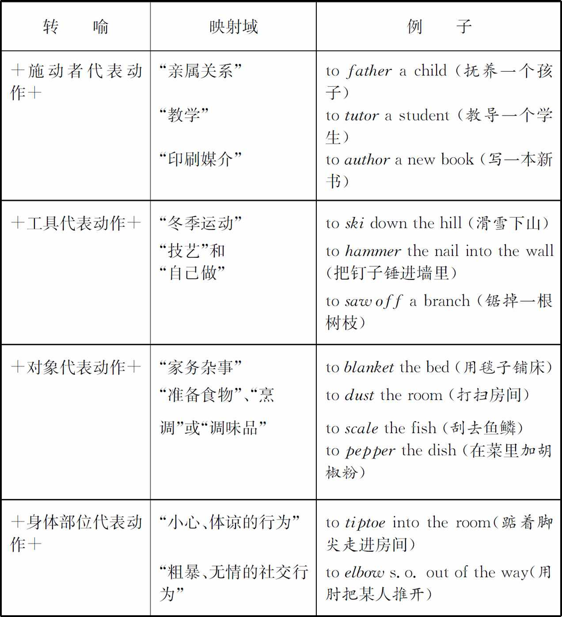

图3.15 ＋PARTICIPANTS FOR ACTION＋（＋参与者代表动作＋）这一转喻的例子，摘自Radden和kövecses（1999：37）及 Schmid（2005，第十章）

转喻还引起了另一个传统上被认为是构词法的语言方法，即类转法，即形式上同一的词出现在几个词类中，如mail （N）-mail （V）（邮件（ 名词）-邮寄（ 动词）），backup （N）-backup （V）（备份（ 名词）-做备份（ 动词） ）。其中最大的一组可能是名词-动词类转，如author（a book） （写（一本书 ）），ski（down a hill） （滑雪（下山） ），dust（the room） （打扫（房间） ）以及列于图3.15中的其他例子。正如图中所显示和Dirven（1999）首次提出的那样 <sup>(22)</sup> ，这种类转的基础似乎也是转喻的代表关系：即＋AGENT FOR ACTION＋（＋施动者代表动作＋），＋INSTRUMENT FOR ACTION＋（＋工具代表动作＋），＋OBJECT FOR ACTION＋（＋对象代表动作＋），＋BODY PART FOR ACTION＋（身体部位代表动作）。这些转喻可以归入更为普遍的转喻＋PARTICIPANTS FOR ACTION/EVENT＋（＋参与者代表动作/事件＋），它也是使用“部分-整体”关系的另一例子。它们能够很容易地发挥作用，是因为在每种情况中，激活的基本关系都创建了两个坚实地固定在熟悉的、情景相关的映射域内的概念之间的联系（见3.1节）。通过比较下面几组的合适和不合适的映射域就可表明这一点：

（1a）Julia peppered the curry．— Julia dropped pepper on the curry.（朱莉娅在咖喱上加了胡椒粉。）

（1b）？Julia peppered the table．— Julia dropped pepper on the table.（？朱莉娅在桌子上加了胡椒粉。）

（2a）Sue has authored two novels．— Sue has written two novels．（苏写了两本小说。）

（2b）？Sue has authored a computer program．— Sue has written a computer program．（？苏写了一个计算机程序。）

（3a）He fathered a baby．— He is the father of the baby.（他抚养了一个婴儿。）

（3b）？He fathered the project．— He is the father of the project．（？他制订了这个方案。）

例（1a）和（1b）表明只是把胡椒粉撒在某处不允准pepper （胡椒粉 ）这种物质有活动这种转喻意义。看来关键之处还在于，这个活动是调味品语境的组成部分，或者更宽泛地说，这个活动是“准备食物”这一映射域的组成部分。与此相似，动词author （写作 ）只是在“印刷媒介”这个映射域中（但不一定在映射域“计算机工作”或“软件工程”中）与动词write （写）同义时才适合于转喻用法。在（3a）中，亲属关系对允许father 转喻用法的映射域来说似乎是必不可少的要素，尽管（3b）中也有可能用词语baby （婴儿）隐喻地指称计划或者方案，但这自然地使人想起一个不同的映射域（使人想到父亲和商业语境的属性）。

跨几个映射域或在唯一可选的映射域内，不同认知模型的这种结合是可能的，并解释了诸如hammer the nail （锤钉子 ）之类的例子，可以在专业手艺或者业余爱好者自己动手的能力等背景下对这些例子进行解释。而像tiptoeing into the room （踮着脚尖走进房间 ）和elbowing s.o．out of the way （用肘把某人推开 ）这种例子，它们的映射域就不再牢固地限于一个特定的认知模型（3.1节已指出的一种可能性）。在这些转喻的映射域中起关键作用的是特定行为方式的动机，在图3.15中暂标为“小心、体谅的行为”或“粗暴、无情的社交行为”。像heel （脚后跟 ）（? she heeled into the room （? 她用脚后跟走进房间 ））这种例子的转喻类转不行，有一个原因是我们无法为那样的行走方式想出一个貌似合理的动机来充当合适的映射域。当然，话语语境可以提供这种允许特殊转喻的映射域，例如，如果某人说the doctor asked me to tiptoe and heel through the room because she wanted to see if my calf muscles were working properly （医生让我踮着脚尖和脚后跟走过房间，因为她想看看我的腓肠肌活动是否正常。 ）

此处作个小结：类转可以理解为得到映射域支持的转喻，而映射域或者等同于一个认知模型，或者至少和一个或几个这样的模型相联系——所有这些变体都在图3.15中进行了阐释。

### 言语行为的转喻背景

回顾一下，到目前为止讨论的构词现象的例子仍然和简单词项或专名的转喻用法的普通用例（hands on deck （甲板上的水手） ，White House （白宫 ）代表 president （总统 ））颇为相似，因为这些构词现象都限于熟悉或易得的认知模型中“局部的”转喻应用。

一个很好的例子是Thornburg和Panther对像Can you pass me the salt？ （你能把盐递给我吗？ ） <sup>(23)</sup> 这个经典例句的规约化间接言语行为的解释尝试。正如两位作者所主张的那样，这些言语行为要理解为＋ABILITY FOR ACTION＋（能力代表行为）这个转喻的实例，而这个转喻又被看作是更为一般的＋POTENTIALITY FOR ACTUALITY＋（＋可能性代表现实＋）这个转喻的具体化。毫无疑问，这个观察结果是正确的：正如Searle（1975：174）已经指出的，我们可以用一个关于实行某个动作的能力的问句（Can you pass the salt？ （你能把盐递过来吗？ ））来要求执行这个动作本身（“pass the salt”（“把盐递过来 ”））。然而还存在两个问题：第一个问题是，我们是否真的可以说＋ABILITY FOR ACTION＋（能力代表行为）这种较抽象的关系满足了原型的概念转喻的条件。要证实这种情况，我们不得不假设一个有点像“我们关于世界的经验”这种确实非常一般的映射域，可以说，它包括了行为和能力。第二个问题是，很难以转喻解释把其他言语行为的条件融合起来，其中有意向性和礼貌，而这些也都是值得考虑的。然而即使我们不知道是否要赞成言语行为的转喻解释这一影响深远的主张，但强调能力和行为之间的认知联系有助于增进对这种语用现象的理解，则是毫无疑问的。

这样，我们在本章认为，转喻看起来是语言现象中涉及的一种认知方法，在语言学的不同领域曾以不同方式加以对待。领属复合词（skinhead （光头党 ），redbreast （知更鸟 ）），名词-动词类转（to author a book （写一本书 ）），甚至规约化的言语行为，看起来也都至少可以用转喻映射来描述。这个讨论所证实的是：任何转喻的成功都有赖于获得一个认知模型或者充当语言使用者可及的映射域的其他类型的概念背景（或者通过从长期记忆中取回，或者通过在话语情境中现时激活）。

### 练习

1．下列领属复合词中涉及哪种代表关系：greybeard （老头儿 ），redskin （印第安人 ），redbreast （红胸鸟，欧鸲 ），bluebell （蓝铃花 ），lazy-bones （懒骨头 ），five-finger （海盘车 ），laptop （便携式计算机），pick-up （拾音器），hide-out （躲藏处），drop-out （退学者，逃避现实者 ）。说出这些词看起来能在其中发挥转喻功能的映射域。

2．有人认为（Ungerer2002：551-554），下列表达方式中的标为斜体的词不应只看作派生词（government “统治的行为 ”＜govern ＋-ment ，development “开发的过程 ”＜develop ＋-ment ）。除派生外，这些词还涉及转喻，例如：government “统治的行为”代表“一群从事统治的人”，（housing ）development （（住宅）开发） ：“开发的过程”代表其结果，即住宅区。分析下面的例子并说出转喻联系：management （管理） 的会议，第一detachment （分遣队） of the army （陆军的） ，US Administration （美国政府） ，一份打印的announcement （通告） ，这本书的introduction （导言） ，一批珍贵的印象派画家的collection （收藏品） 。

3．本书中类转的转喻解释限于名词-动词转换。看看将这个分析推广到动词-名词类转是否也有道理，如把名词（tennis）coach （（网球）教练） 解释为对＋ACTION FOR AGENT＋（＋行为代表施动者＋）这一转喻的应用。

除了＋ACTION FOR AGENT＋（＋行为代表施动者＋）外，再考虑＋ACTION FOR EVENT＋（＋行为代表事件＋）、＋ACTION FOR INSTRUMENT＋（＋行为代表工具＋）、＋ACTION FOR PLACE＋（＋行为代表处所＋）这些转喻，并尝试将下列名词分派给这些转喻：

cheat （骗子） 、cover （封面/盖子） 、divide （分界线） 、drive-in （“免下车”餐馆） 、hit （打击） 、laugh （笑声） 、lay-by （路侧停车带） 、retreat （撤退） 、rise （上升） 、shut-down （停业） 、stand-in （替身） 、swim （游泳） 、turn （转动） 、walk-out （退席、罢工） 、wrap （包裹） 。

### 进一步阅读的建议

3.1节

(1) 有关儿童使用隐喻表达方式的能力、倾向等有趣的问题，见Elbers（1988）和Nerlich等（2002）。

(2) 最早从语言学视角论述隐喻的，就我们所知是Ullmann（1957，第一版1951）和Leech（1969）。

(3) 在Ullmann（1962：218以次），Lakoff和Johnson（1980/2003：38以次），Lipka（1988：360以次）中可以找到按所指的邻接关系给转喻下的定义以及收集的各种类型的转喻。

(4) Gibb（1994，第六章）提供了一个有用的对隐喻主要理论的概述。互动理论的应用可以在Ullmann（1962）和Lipka（1988），特别是Leech（1969）中找到。至于文学话语处理中隐喻的作用，还可以看Steen（1994，第二章）。

(5) 要获得英语和其他语言中，更多源自身体部位的隐喻的信息，对照Steen（1994）。Kövecses（2002，第十二和十三章）以及Kövecses（2005）更为深入地研究了概念隐喻具普遍性还是文化相对性这个令人感兴趣的问题。

(6) 尽管mapping scope（映射域）是个新术语，但它接受并融合了早期隐喻研究的意见，且提供了获得更新成果的方便途径。对比Lakoff和Johnson（1980/2003：61以次，117以次）与Lakoff和Turner（1989：113以次）中对隐喻基础的讨论。相关的还有Lakoff和Johnson（1980/2003：10以次），Lakoff和Turner（1989：64以次），Croft（1993）中讨论的隐喻映射的视角变化、突显和隐藏的能力，以及Brugman（1990）和Lakoff（1990，1993）提出的恒定性假说。还可参看Croft和Cruse（2004：204-206）论一个隐喻的“身世”，Stern（1999：9以次）论隐喻映射中的语境条件。

(7) 对比Hampe（2005：55）的“经验相互关系”概念。认知语言学文献中其他与基本经验相互关系相似但在各自框架中起不同作用的概念有Grady（1997，1999，Grady和Johnson 2002）的“基本隐喻”及Fauconnier和Turner（2002）的一些“关键的关系”（见6.1节）。

(8) 对单一对应隐喻和多元对应隐喻差别的细节，见Ruiz de Mendoza Ibañez（2000）。

(9) 就对转喻的初步理解来说，使用映射域这个限定的概念比假定高度抽象的认知域（例如“产生”，“引起”，“控制”，“建立”，“行为”或者“整个实体”；Kövecses 2002：147），并以大量的一般限制（“人类支配非人类”，“具体支配抽象”，“好的完形支配差的完形”等）来监控成功的转喻产生似乎更有帮助。参看Kövecses和Radden 1998（以及这些作者较近的出版物）以及Barcelona（2000：12以次；2003：243以次）。

(10) 隐喻和转喻的互动在过去几年得到了敏锐的调查研究。关于这个题目，重要的研究都包括在Panther和Radden（1999），Barcelona（2000），Dirven和Pörings（2002）主编的几本书中。后者还包括了众所周知的较早著作的修订版，如Jakobson和Halle（1956）关于隐喻极和转喻极的论文、Goossens（1990）和Croft（1993）。简明的论述，见Croft和Cruse（2004：216-220）。

3.2节

本节主要以Kövecses（1990，1991，1995）的著作和Lakoff对ANGER（愤怒）的说明（Lakoff 1987：380以次）为基础。除了有时候有重复以外，所有这些都很值得一读。亦见Kövecses（2002，第二章）中的综述。

(11) 对各种情感理论的简述，参见Johnson-Laird和Oatley（1989）。和认知语言学关系更密切的是Fehr和Russel（1984）以及Shaver等（1987）。Kövecses（2002）和（2005）提供了更近的研究状况的介绍。

(12) 这个系统是专为英语设计的，生理结果的普遍性方面和容器隐喻的跨文化使用在Kövecses（1995；2000，第八章）中有讨论，Wierzbicka（1986，1988）也在她的文化脚本的术语中讨论了这个问题；最近对文化脚本的介绍见Goddard和Wierzbicka（2004）。

(13) 鉴于本书的介绍性质，我们不打算说明Lakoff关于ANGER（愤怒）隐喻源概念和目标概念之间本体的和认识的对应这个系统；见Lakoff（1987：386以次）。

(14) 对基本情感各种处理方法的简短（但未必批评的）综述，见Ortony等人（1988：25以次）。另见Johnson-Laird和Oatley（1989），以及Kövecses（2000，第一章）的总结。

(15) Kövecses（2000，第五和第十章）提出的情节概念最新变种是以Talmy的力量动态理论（Talmy 2000/Ⅰ，第七章）为基础的，并使用了他的术语竞争者和对抗者来描写情感隐喻的功能，它把力量叫做情感的“主隐喻”。

3.3节

(16) 见Boyd（1993），Kuhn（1993），亦见Schön（1993），他的“生成性隐喻”概念和Boyd的结构性隐喻非常相像。Gentner（1982）也考察了科学隐喻，除了其他例子，还讨论了下文描述的太阳系隐喻。另见Gibbs的“思维中的隐喻”综述章（Gibbs 1994，第四章）。

(17) 对科学历史和科学教学中隐喻的作用的讨论，见Gentner和Jeziorski（1993）及Mayer（1993）。

(18) 从语言学角度看，Lakoff和Johnson（1999）的第三章到第五章提供了用于分析中的概念工具的综述。第十章提供了一个对时间的隐喻概念详细的个案研究。第三部分哲学挑衅性最强，作者对从前苏格拉底思考者到乔姆斯基的哲学家都提出了全面的批判，并将他们自己以隐喻为基础的“体现哲学”与之并列。

(19) Lakoff（1992）的论文是一篇严谨的著作，在一篇短的网络出版物（Lakoff 2003）中他将其应用到第二次海湾战争上。Lakoff（1992）也在这个领域引发了其他调查研究，其中有Gibbs（1994，第四章）和Sandikcioglu（2000）。比较Musolff（2001）对报纸用于描写欧洲一体化进程的＋PATH＋（＋路径＋）和＋TRANSPORT＋（＋交通＋）隐喻的分析。

(20) Lakoff（2002，第一版1996）被分成了“客观的”第一块（第一到第四部分），其中第二部分包含与语言学相关的认知模型和隐喻的讨论，第二块（第五部分）中（就像他后来的著作中一样，见Lakoff 2004）他则公开支持自由派立场。

3.4节

(21) 重要的著作是Kövecses和Radden（1998）与Radden和Kövecses（1999）；Kövecses（2002，第十一章）中有总结。

(22) 因为Dirven使用这个方法阐述名词-动词类转能产性的认知解释，所以他不考虑＋AGENT FOR ACTION＋（＋施动者代表动作＋）这个转喻。更多详情，见Dirven（1999），限制性较少的方法和更多的例子，见Schmid（2005，10.2和10.4章节）。

(23) Panther 和Thornburg在几种著作中都提倡这个方法：见Panther 和Thornburg（1997），Panther和Thornburg（1999）和（2003）。另见Gibbs（1999）。

[1] 根据企鹅的评注，under 在这个语境中的意思既可以是“在……下面”（在地面上），也可以是“社会地位低”。

[2] 据梁宗岱译。

[3] 注意全书的隐喻和转喻都用两个“＋”号之间的小号大写字母表示。

[4] 认知文献里在这种语境中使用的术语“认知域”，在Langacker的《认知语法》中也被确立为专门术语，因此我们在第四章还要保留使用。

# 第四章 主体与背景

## 4.1 主体与背景，射体与界标：早期对于介词的研究

当我们看所处环境中的一个物体时，我们将它作为从背景中凸显出来的一个主体来看待。在语言结构中这种凸显原则同样起作用。例如：在“书在桌上”之类的位置关系中“书”被概念化为主体。

在1.2节中，完形被描述为物体范畴化的基础。除了作为感知原则的邻近原则、封闭原则以及连续原则以外，完形心理学家对于我们的视觉及听觉输入是如何按照不同部分的凸显而组织起来的这一点十分感兴趣。从听感领域中举一个例子：在听钢琴音乐会的时候，我们很容易意识到钢琴演奏的部分比管弦乐队的伴奏更为显著。在感知的视觉领域情况也很相似，我们观看一个人跳高时，目光跟随着跳高运动员的动作，而不是停留在横杆或地面上。本章将更细致地观察完形心理学家的研究结果是如何影响语言研究的。

### 主体/背景分离及位置关系

我们先细看一下图4.1中著名的人脸/花瓶的幻觉图画。你会注意到感知这个图的两种可能性（把它看作两张人脸或一个花瓶），但一次只能看见一种。而且，你可以在两种看图方式之间随意地转换，尤其是观看了较长时间之后。我们不能同时看见花瓶和人脸，这背后隐藏着的就是一种被称为主体/背景分离（figure/ground segregation） 的现象。这一术语首先由丹麦的心理学家Rubin在近一个世纪之前引入心理学，后来由完形心理学家将其融入更全面的感知组织框架中（参见1.2节）。

检查我们更仔细地看图4.1时的视觉经验的时候，我们会发现将之选作主体的事物应有一些特殊的属性。主体应有形状或外形，背景则无定形，而与主体共有的轮廓线也似乎是属于主体的。除了形状和轮廓之外，主体似乎还有其他的一些类物性，如结构及连贯性，而背景则是无结构、无形状、均匀的。主体似乎位于背景的前面，而背景则在其后或多或少地不断延伸。总之，主体被感知得比背景更突出，心理学研究表明主体更容易被识别和记忆，并与意义、情感及审美价值有关 <sup>(1)</sup> 。

[figure not shown]

图4.1 人脸/花瓶幻觉（根据Rubin）

虽然对于图4.1的进一步观察清楚地证实了此图感知凸显（perceptual prominence） 的存在，但并未真正解释为何有时是两张人脸、而有时又是花瓶具有类主体性质。也就是说，去了解什么因素主宰了主体的选择，会是很有意思的。因为我们视觉系统的客观输入并没有变化，这种选择完全由观察者所决定；但说这只是个人的爱好或一时的奇思妙想，又似乎不太说得过去。

要回答这个问题我们首先要知道人脸/花瓶幻觉当然是一个性质非常特殊的例子，因为它允许所谓的“主体/背景的反转”。而我们日常生活中所遇到的大多数场景是不同的，因为它们都包含了特别的主体/背景分离。因此在图4.2所描画的场景中，会被选为主体的显著实体是书，而桌子则被给予背景的地位，除非作出特殊而相当不自然的努力来把桌子看作主体。

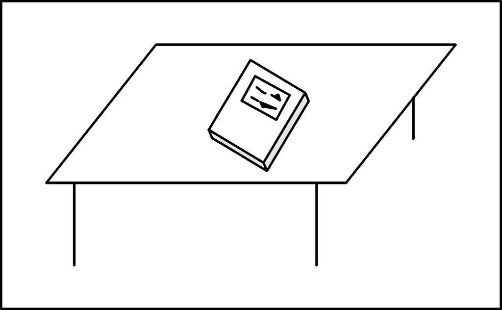

图4.2 主体和背景：书和桌子

完形心理学家认为，整体性（Prägnanz）原则——我们在1.2节已经介绍过——在给一个视觉场景中的某些部分赋予主体地位时起着主要作用。与桌子不同，图4.2中的书容易满足封闭性（它的外部轮廓是封闭的）和连续性（它是个未被打断的整体）这样一些完形原则。此外，一块相对较小的黑色区域及均衡比例吸引了我们的注意力，并使书比桌子更可能成为主体的候选对象。最后，书看起来比桌子更容易移动（例如可以拿起来），这也决定了我们对主体的自然选择 <sup>(2)</sup> 。

当我们描述一个移动中的物体如图4.3中的气球时，这最后一点甚至更为重要。看这幅图时，我们会毫不犹豫地把气球看作主体，而把房子看作背景；气球因为被认为是正在移动着的物体，它看起来比房子显著得多。从语言学的角度来看，思考一下主体/背景的选择及我们的例子中两个成分之间的关系是如何用词语表达出来的是十分有趣的。在说明图4.2所描画的情形时，我们可能会说书在 桌上（the book is on the table） ，因此也就描述了一种特定的主体和背景之间的位置关系。同样，我们也会说图4.3中的“气球是在 房子上 ”（the balloon is above the house）；或者，当我们认为气球事实上一定是在移动时，我们也许会用“气球正飞越房子上空 ”（The balloon is flying over the house ）来表述。这种气球和房子之间的关系应该将如图4.4所示的气球在不同时间的位置变化考虑在内。

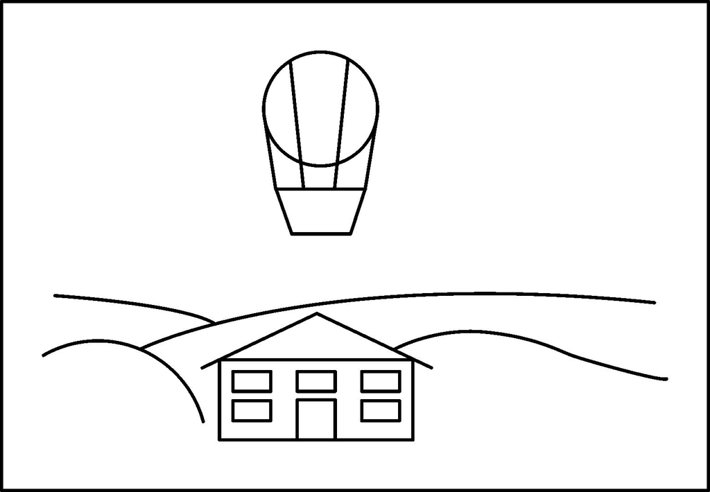

图4.3 主体和背景：气球和房子

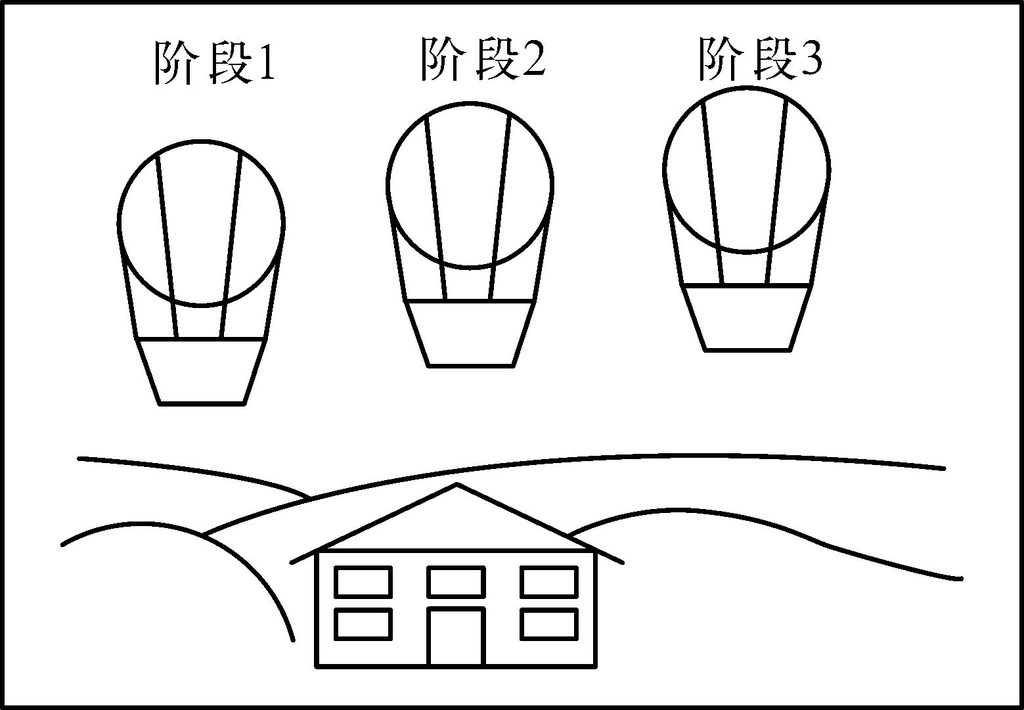

图4.4 The balloon is flying over the house. （气球正飞越房子上空）的视觉图

以上两个例子所表明的是，主体与背景之间的关系可以看作位置关系，通常由介词表达；或者从相反的角度来看，方位介词的意义可以理解为主体/背景的关系。正是第二种观点，即能用主体和背景来解释介词这样的语言形式，引起了认知语言学家的注意。

### 意象图式、射体、界标及路径：介词分析的一些基本概念

这些方位关系被描写为意象图式（image schema） ，即我们在与现实世界的身体互动中得到的简单而基本的认知结构，或者更确切地说，是我们对于周围世界的方位感。这些方位意象图式（orientational image schemas） 比起特定的基本层次物体或生命体丰富的原型范畴来说无疑没有那么具体（参见2.1节）；然而，它们也未被理解为抽象原则，而是被看作一种心理图画，由此也就很自然地适合于图画表征 <sup>(3)</sup> 。

第一个恰当的例子存在于我们的例句“气球正飞越房子上空”（The balloon is flying over the house. ）中的（图4.5）“over”（在……上）这个意象图式的图画表征。当我们对比图4.5与图4.4时，图4.5显然更为抽象。气球（在上文中被视为主体）和房子（背景）现在由象征物表示。其原因是“over”（在……上）这个意象图式当然也可用于其他除了气球和房子之外的物体（如The bird is flying over the tree （鸟正从树上飞过 ）和The kite is flying over the hill （风筝正从山上飞过 ））。代表了主体的象征物（圆圈）出现了多次以表明它所表示的是一个具有动态性质的过程。每一个圆圈代表了这一过程中的不同时间阶段。从一个阶段到另一个阶段主体的移动经过了一个路径（path） 。因为子弹或导弹的路径可以理解为弹道，主体可以叫做“射体”。背景的主要功用是作为定位的参照点，因此被叫做“界标”。这也就是说，“射体”和“界标”是更广泛运用的“主体”和“背景”概念的特殊表现。在认知语言学中，已经普遍使用“射体”和“界标”。因此射体（trajector） 代表了主体或在任何关系结构中最凸显的成分（因此用粗线表示），而界标（landmark） 则指关系中的另一个实体。

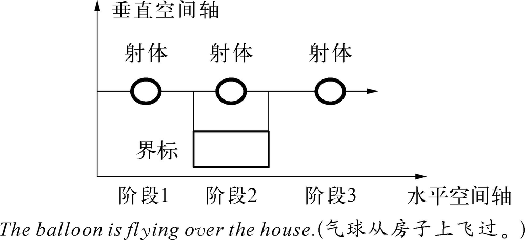

图4.5 “over”（在……上）的意象图式

综览这些图表和解释，你也许会得到这种印象：这些表征仅仅是对我们的例句或一组关系密切的例句的图示。这种观点没有考虑到：所有的有关成分都可以用不同方式改变。正如下面几节所要说明的那样，射体和界标可以在大小和形状上出现变化，射体可以同界标接触，甚至是界标的一部分。而重要的是这些变化都能从同一个射体和界标关系（如我们的例子“over”（在……上）这一关系）派生出来。也就是说，射体/界标方法有望提出一个揭示介词不同意义之间关系的介词的意义描写方法。这种对于介词不同意义的统一认知描写与早先的认为这些意义之间毫不相关的观点形成了强烈的对比。

统一的描写需要一个起点、一个核心、一个可被认为是“中心”（我们努力避免使用“原型”，因为原型包括了一个丰富的范畴结构，而这并不是意象图式的特点）的图式。接下来我们将看一下Lakoff（1987） <sup>(4)</sup> 总结的Brugman（1981）的对“over”（在……上）的分析，及Lindner（1982）对于“out”（在……外）及“up”（向上）在动词-小品词结构中的意义研究。

### Over 、out 及up ：中心图式（central schema）及一些细化/扩展

同Brugman和Lakoff一样，我们认为图4.5是“over”（在……上）的中心图式。它包含有射体：射体从界标上方的一端向另一端沿一定路径移动直至消失。如前所述，射体可能代表气球、飞机、鸟、风筝，而界标可能代表房子、墙、树、山头等等。另外有时界标也可以不确定，如在“The plane flew over （飞机从上空飞过 ）”这个句子中。这里将说话者或感知者的位置作为界标，因此“The plane flew over （飞机从上空飞过 ）”与“The plane flew over me/us （飞机从我/我们上空飞过 ）”的语义是相近的。

让我们看一下介词out （在 ……外 ）和up （向上 ）的中心图式。图4.6提供了在“She went out（of the room） （她走出（房间）外） ”中使用的“out”（在……外）的中心意象图式的图示。如图所示，第一阶段射体是包括在界标所占空间之内的，界标所代表的是房间或其他并不确定的物体，表示“她从我们所在的空间内出去”。单独地来看，这一起始阶段大体与介词in （在……里 ）所表示的状态相对应，因而可以看作是“in”（在……里）的意象图式 <sup>(5)</sup> 。“out”（在……外）这一意象图式中特殊的方面是射体由包含于界标边界范围内的一个位置移动到一个两者完全分离的位置。这由图中射体的三个位置来表示。

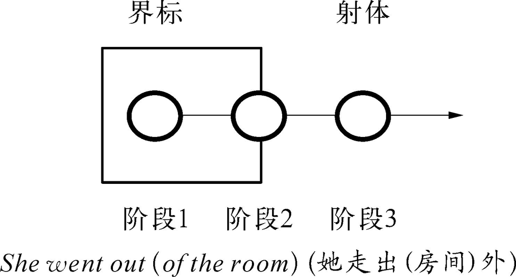

图4.6 “out”（在……外）的中心意象图式

与“over”（在……上）和“out”（在……外）相比，“up”（向上）的意象图式（见图4.7）是相对较难的例子。在这里，射体的路径有一个垂直的方向，而界标仅就其垂直的延伸而与之相关。这也就是为何界标在图中只用垂直线表示的原因，即使在特定的“The boy climbed up the wall （男孩爬上墙） ”中也是如此（毕竟在你爬墙时不会想到它的厚度，只会关心其与垂直的距离有关的垂直维度）。这种较抽象的界标概念比其他种类界标更难掌握与接受，但这使得更容易想像界标是不被确定的，就像在句子The rocket went up （卫星飞上了天 ）中一样。

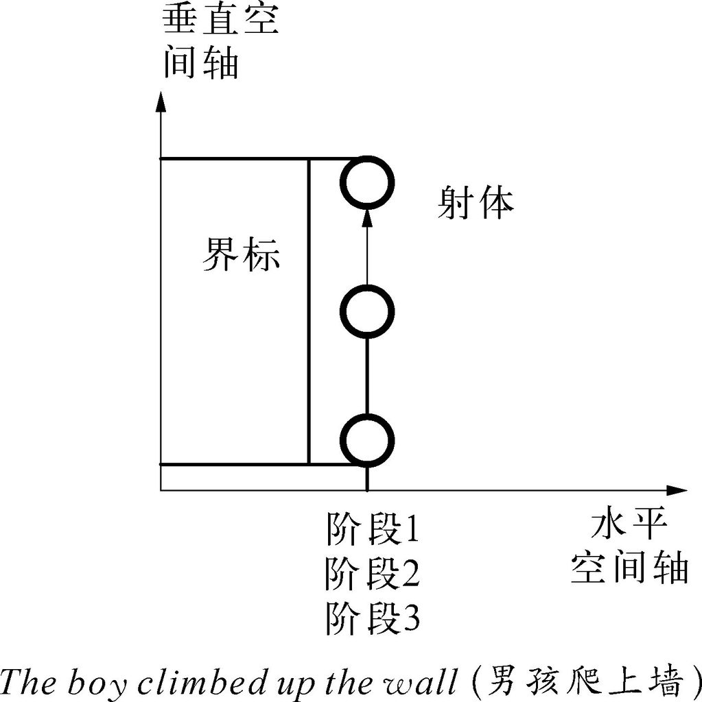

图4.7 “up”（向上）的中心图式

回过头来看，我们可以得出这样的结论：这三个中心图式都表征了由三个成分及其相互关系构成的认知结构，即：

一个射体，其运动沿着

一个路径，而且被看作与之相关的是

一个界标

这三个成分之间的关系对于粗略区分以上三个介词的意义差异来说也许足够了。为了解释更特殊的意义或用法，射体、路径及界标所可能产生的变化也必须要考虑到。这些变化只是限定了图式的一些部分，而并未偏离其一般的结构，我们因而称之为细化（elaboration） 。

图4.8说明了“over”（在……上）的意象图式的一些细化。变式（a）描述的是一种一般的情况，应用于射体和界标相接触的位移动词。变式（b）表明射体可以拥有与界标相类似的大小、形状，并且射体与界标十分接近，因而实际上是覆盖了界标。最后，变式（c）解释了一种通常认为是边缘的状态——射体同界标的融合。倾倒的篱笆（或者至少是其上端）是沿着路径运动的射体，并且同时也是作为位移参照点的界标。

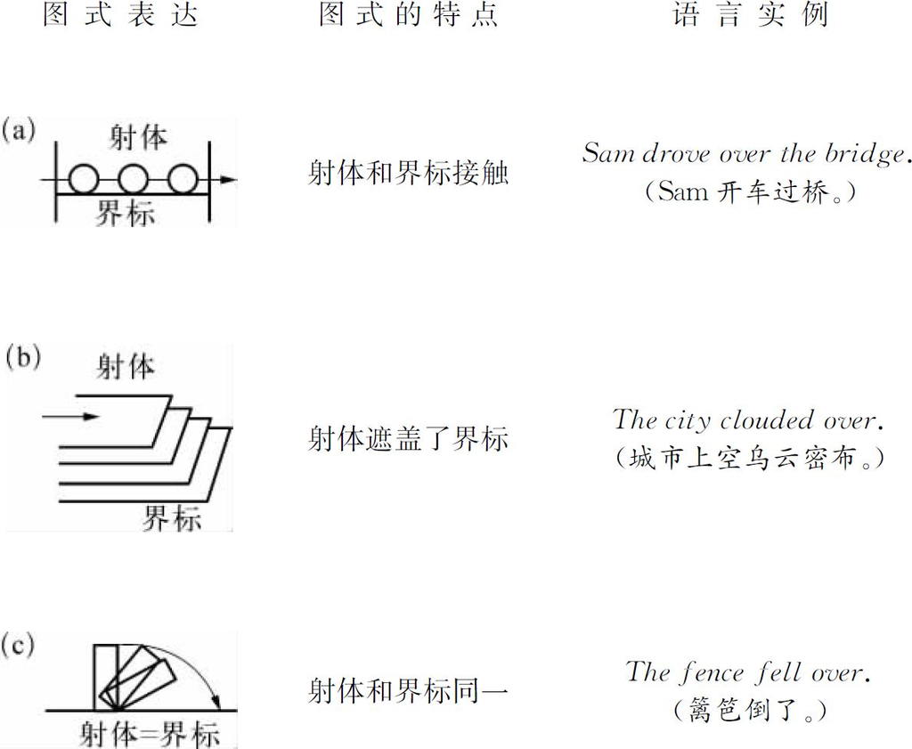

图4.8 “over”（在……上）中心图式的细化（依据Lakoff 1987：419以次）

图4.9包括了另一组细化，这次与“out”（在……外）的中心图式有关。它们的最主要共同点是变化主要与起始阶段有关，即与射体是如何被（或不被）界标并入有关。起始阶段与最后阶段相对立，因为正是在此对立中，“out”（在……外）明示了其自身含义；如果中间阶段并未添加任何重要信息的话。

将注意力集中于意象图式的选出的阶段，对“out”（在……外）的分析指出了我们理解介词使用的令人疑惑的另一面的途径：主要表示动态的介词如over （在……上 ）、out （在……外 ）、up （向上 ）被用以表达至少表面上被认为是静态的含义。

比较以下例句：

1．Hang the painting over the chimney．（把画挂在烟囱上。）

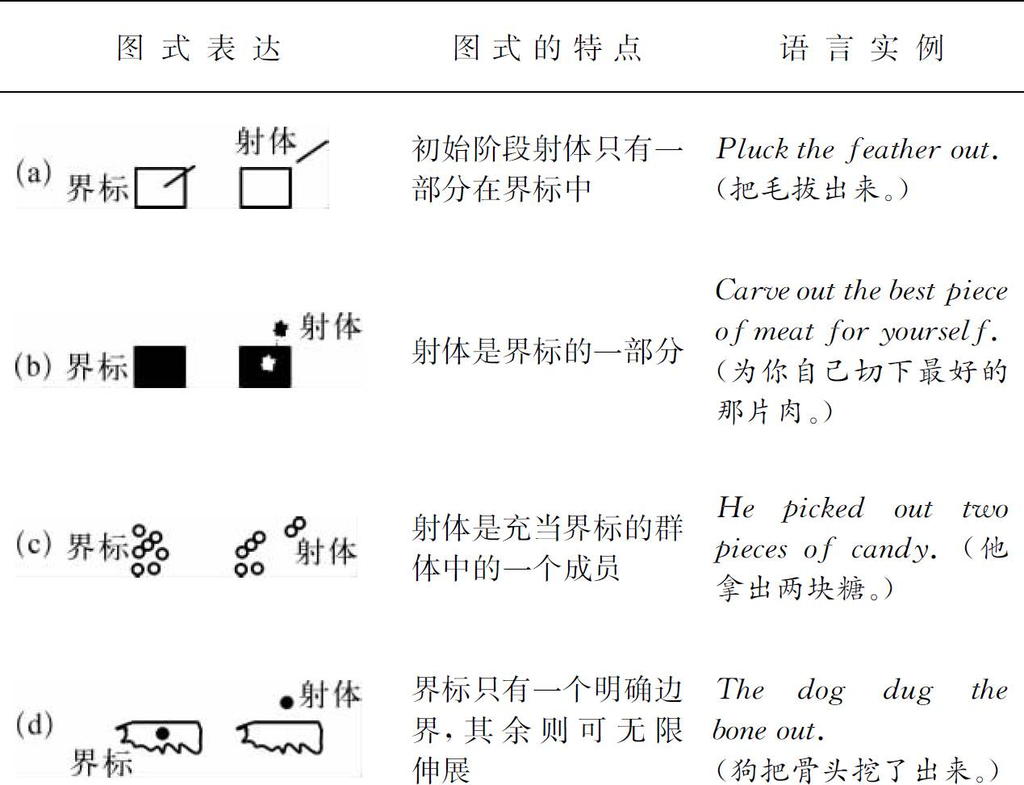

图4.9 “out”（在……外）中心图式的细化（依据Lindner 1982：86以次）

2．She stays out．（她留在外面。）

3．She lived three floors up．（她住在三层楼上。）

先分析第一个例句，句中所描述的画的位置可以很容易地被理解为将画移动到其位置上的过程的最后阶段。这一点表示为图4.10。与之相似，句（2）和句（3）可被解释为“out”（在……外）、“up”（向上）图式中路径的最后阶段。参见图4.11。

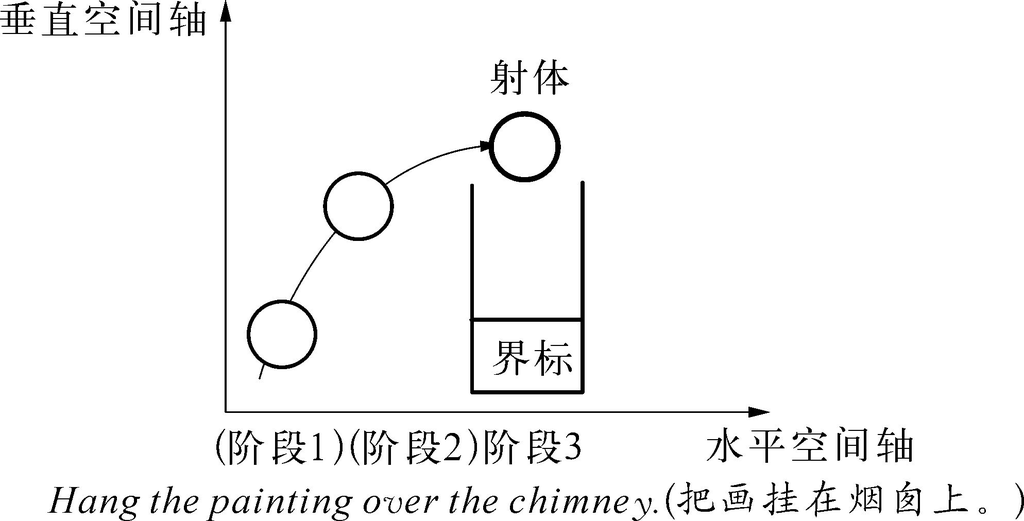

图4.10 “over”（在……上）表面静止状态的图式表现

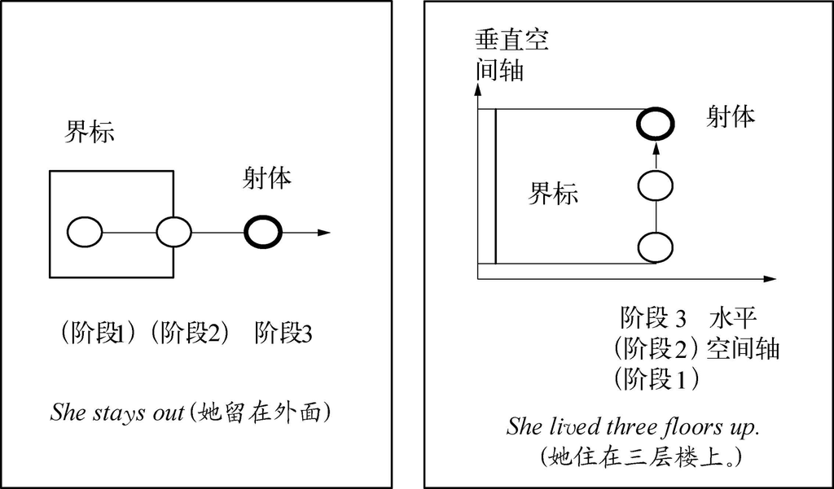

图4.11 “out”（在……外）和“up”（向上）表面静止状态的图式表现

### 隐喻引申

就如目前情况所示，位置关系的一个相当一般的图式可从细化的角度用来解释介词各种各样的用法。但是还有很多介词意义与中心图式存在很多差异，因此也无法只根据图式来解释它们；要解释它们，只能假定一个隐喻引申（metaphorical extension） 。比如，如下从Lakoff（1987）中所选的这对例句就是如此——第二个例句已略作改动 <sup>(6)</sup> 。

She has a strange power over me.（她对我有一种奇怪的力量。）

The government was overthrown.（政府被颠覆了。）

以上两个句子中的“over （在……上） ”都可以通过＋POWER RELATIONGS ARE SPATIAL RELATIONS＋（＋权利关系是空间关系＋）这一隐喻来解释。这种隐喻关联由基于“上-下”意象图式的映射域决定，这个意象图式认为，向上的运动和有权利的地位为“上”，相反则为“向下”。从一个更明确的角度来看，这个隐喻也可以理解为＋CONTROL IS UPWARD MOVEMENT / UPRIGHT POSITON＋（＋控制是向上的运动/竖立的状态＋），也正是这个映射很明白地解释了第一个例句中的“over”（在……上 ）。对于第二个例句的解释则稍微复杂一些。正如Lakoff（1987：439）所说：“在事件发生之前，政府有控制能力（隐喻上的竖立），之后失去了控制能力（从隐喻上说，它已经倒下了）。”人们也许可以把这个隐喻的另一变体也算在内，这个隐喻变体大致可描写为：＋PROPER FUNCTIONING IS UPRIGHT POSITION＋（＋正常运作是直立状态＋）。根据我们的日常经验，我们知道植物、动物、人和一些物体如书架、房子或者尖顶只能在它们处于直立状态的时候才能完满、有效地发挥各自的功用。躺倒在地，或者更糟的情况如四散开来则清楚地表明了一个生物或物体目前不能活动或严重受损，这也有助于产生由overthrow the government （颠覆政府 ）这一表达方式所激发的丰富意象。

另外的一个例子是，Harry still hasn't got over his divorce （Harry还没有从离婚中恢复过来 ）可以被看作是＋LIFE IS A JOURNEY＋（＋生活是旅行＋）隐喻的体现，正如3.1节所表明的那样，该隐喻将JOURNEY（旅行） 这一事件概念的结构投射到LIFE（生活） 这一抽象概念上，这个投射过程由以路径图式等为基础的映射域所控制。旅行的一个特性是旅行者的行程有时会被一些如河流、峡谷及山脉之类的障碍阻挡，这时旅行隐喻的更特殊的变体，即＋PROBLEMS IN LIFE ARE OBSTACLES IN A JOURNEY＋（＋生活中的问题是旅行中的障碍＋）开始起作用。如果人生的逆境、挫折及问题等被看作是生命旅行中像大山之类的垂直障碍，人们就要越过它们以继续生活下去（又如，也说He is over the hill （他越过了小山） ）。从对“over”（在……上 ）图式的补充角度来看（图4.5），这意味着Harry就是那个射体，他为了继续自己的路径（=旅行=他的生活），必须越过界标（=障碍=离婚）。

总之，本章中的讨论仅初步显示了主体/背景区分离中的凸显原则是如何在语言结构中起作用的。到目前为止，我们的讨论仅限于与介词词义领域相关的一些例子，用“射体”和“界标”、“路径”、“中心图式”和“扩展”这些术语来进行描写。虽然介词的意义还和语言的词汇方面关系密切，我们现在还是会稍微更深入地探讨凸显在语法结构中的作用。

### 练习

1．考虑一下由下面两组句子所描述的情景：

The pen is under the table.（钢笔在桌子底下。）

The table is over the pen.（桌子在钢笔上面。）

The lamppost is in front of the house.（路灯在房子前面。）

The house is behind the lamppost.（房子在路灯后面。）

如何运用主体和背景原则来解释以上两组句中只有第一句是这种情景的自然表达？

2．正如本节所讨论的一样，“out”（在……外）的意象图式第一阶段可以被看作是意象图式“in”（在……里）。使用图4.6（“out”（在……外）图式）来画出“in”（在……里）的意象图式。

看以下各句，其中哪些是描述了“in”（在……里）的中心图式，哪些表现了中心图式的细化？以图4.9为参照画出细化的图表：

The lipstick is in my handbag.（口红在我手提包里。）

The flowers are in the vase.（花在花瓶里。）

There is a hole in your shirt.（你衬衫上有一个洞。）

Find the mistake in this sentence.（从这句话中找出错误来。）

3．画出以下各句的意象图式：

I met John in the street.（我在街上遇到了John。）

Salesman spend a lot of time on the road.（推销员在路上花很多时间。）

如何运用两个图中的界标差异来解释in the street （在街上）和on the road （在路上）使用的对立？

4．以下是一些由up 和动词性成分所组成的复合名词及其在《朗文当代英语词典》（第四版）中的定义：

upbringing ：“the way that your parents care for you and teach you to behave when you are growing up”（在你成长过程中你的父母照顾你以及教育你如何行动的方式）

upkeep ：“the process of keeping something in good condition”（使某物保持良好的状态的过程）

uproar ：“a lot of noise or angry protest about something”（抗议某事的吵闹声或愤怒）

upstart ：“someone who behaves as if they were more important than they really are and shows a lack of respect towards people who are more experienced or older”（其行为表现他们得比实际更重要并缺少对更有经验或更年长的人尊重的人）

upturn ：“an increase in the level of something，especially in business activity.”（某物在层次上的增长，尤其是在商务活动中）

这些不同的意义哪些肯定是从意象图式“up”（向上）中得来的？

5．如图4.7所示，画出可被认为是与“up”（向上）相反的“down”（向下）的位置关系图。说明这个图式如何能与其他的图式合起来解释以下一些短语：up and down ，down and out （“穷困潦倒” ）和down under （“在澳大利亚”）。

## 4.2 主体，背景及两个隐喻：简单小句句型的认知解释

如果主体/背景的区分只能用来解释介词意义，那它的重要性是有限的。然而它在语言学中还可以用到其他许多方面。这一节中我们将讨论到对它的另外一种应用——小句句型的描写，这将在下一节纳入更大的认知框架中。

传统语法主张，简单小句一般应由三个关键成分组成：主语、动词性成分（或谓语）、补足语（如宾语或状语）。以下各句说明了这种标准句型（句（4）和句（8）自Langacker 1991）：

1．Susan resembles my sister.（Susan像我的姐姐。）

2．Susan is peeling a banana.（Susan正在剥香蕉。）

3．Susan loves bananas.（Susan喜欢香蕉。）

4．The hammer breaks the glasses.（锤子敲碎了玻璃。）

5．Susan has a large library.（Susan有一个大图书馆。）

6．Susan received the present.（Susan收到了礼物。）

7．Susan swam the Channel.（Susan游过英吉利海峡。）

8．The garden is swarming with bees.（花园里蜜蜂在嗡嗡地飞舞。）

9．There was a loud bang.（一声巨响。）

虽然这些句子都包含了以上所说的三个成分，但很容易看出，它们的差别实际上是很大的。主语指人、事物、地点，或者，它们是“空的”（如最后一句中的there -主语）。人、事物、地点也可以成为补足语。有一个句子（如例（1））的主语和宾语可以互换，而其他句子却不可以，而且，被动句的转换也是受到严格限制的。传统语言学家和现代的一些语言学学派注意到了这些区别，并试图用通过划分不同的动词类别或格框架（此概念将在5.1节讨论），或将其中一些作为其他类型的转换来解释（如认为She swam the Channel （她游过英吉利海峡） 是从She swam across Channel （她从英吉利海峡穿游过） 衍生而来的）。

与这些方法截然不同的是由Langacker（1990；1991，第7、8章）所建立的认知语法，这种语法认为：如果人们将这种主语—动词—补足语形式作为一种普遍的认知规则——主体/背景分离——的反映来理解，那么还是有可能为这些句法差异提供一个统一解释的。或者说得更确切一些：在一个简单的及物句中，主语对应于主体，宾语对应于背景，而动词则表示了主体和背景之间的关系。

如以下这对句子所示，主体/背景原则在解释对称结构时是最为可行的：

（a）Susan resembles my sister.（＝例（1））

（b）My sister resembles Susan.（我的姐姐像Susan。）

正如本章4.1节一开始所提到的人脸/花瓶幻觉一样，选择哪一个句子成分作为支配成分是由说话者决定的。从语言学角度来看，表示凸显办法就是把优先选定的成分放在主语位置；这就像决定把人脸/花瓶幻觉看作是两张脸还是一个花瓶一样。一旦决定用Susan（句（a））或句（b）中的my sister （我的姐姐 ），在两种变例中被选定的主语是主体，它要比其他成分（背景）更凸显。这也就意味着句（a）中的Susan是以他人为参照而被评论，而句（b）则相反。虽然第二个成分没有主体那么凸显，但是它作为参照点也是重要的。

为了解释主语及补足语之间存在的凸显程度的不同，我们将分别使用句法主体（syntactic figure） 和句法背景（syntactic ground） 这些术语。（对于这种区分Langacker最喜欢的术语是“（小句）射体”和“（小句）界标”，但有时也会用一些其他术语。）

如同人脸/花瓶幻觉中的可转换的视觉情景一样，对称结构是很特殊的。句法主体的选择通常是由一些其他的认知原则所支配和限定的。接下来我们将讨论这些附加原则以及它们与主体/背景分离之间的互动。

### 角色原型

Langacker解释小句结构所使用最著名的认知原则是角色原型（role archetypes） 。任何对现代语言学有一点儿基础的人都会知道，这一概念背后所隐藏的内容并不新鲜。因为“施事”、“受事”、“工具”、“感事”这些角色原型将让人们想到，是根据“格”（或者“行为者”、“参与者”、“语义角色”、“论元角色”）来分析句子成分的，就像近40年来大多数语言学派一直宣扬的那样 <sup>(7)</sup> 。其中的两个角色，即施事与受事，实际上来自于传统语法。所有这些用角色或格来进行句法分析的尝试都有一个共同的目的，即建立一个以语义为基础的角色清单，以达到对小句句型的非动词性成分进行适当的分类。这就产生了大量不同的角色清单，但仍未建立一个确定的列表。

对于Langacker来说，这并不奇怪。在他看来，角色不仅是一种语言构造，也是我们用以进行语言处理及非语言的心理处理的众多认知工具的组成部分。角色原型源自于我们与世界互动的经验。从这些经验中我们知道我们能够使物体或者其他人发生位移或身体的活动（对原型施事（agent） 的一种近似的定义）。相反我们也感受到了物体或生物受外部物理影响而产生状态变化或被移动到其他位置。这就是受事（patient） 的定义，在这一广义的定义中也包括了Langacker的一个单独的“移动者”角色。工具（instrument） 的角色原型则定义为施事及受事之间的媒介，感事（experiencer） 角色则指参与心理活动（包括情感活动）的人。和一般的认知范畴一样，角色原型并不是离散的范畴，而是渐变的现象。正如Langacker所说，它们“不像艺术馆中所排列的一排塑像，而类似于群山的一些最高峰”（1991：285）。

然而，从小句成分回溯到认知原型，我们会发现一个问题：我们怎么会知道哪一个角色放在主语位置，哪一个角色又放在补足语位置呢？正如对以下例句的分析所显示的一样，在一定情况下，所有角色原型都可在主语位置出现：

| Susan is peeling a banana.（＝例 （2）） | 主语＝施事 |
| --- | --- |
| Susan loves bananas.（＝例 （3）） | 主语＝感事 |
| The hammer broke the glasses.（＝例 （4）） | 主语＝工具 |
| The glass broke.（玻璃碎了 ） | 主语＝受事 |

这四种句型都是可以接受的，这是很明显的，虽然如此，但施事较之于其他的角色原型来说，更经常地被作为句法主体。问题是何以如此。Langacker又一次给出了一个以我们对于人与物之间互动的经验为基础的解释。

### 动作链、能量流及台球隐喻

现实世界中的物体和生物之间一个最基本的互动方式是物理接触。在认知语言学中，对这些接触的研究产生了几个重要的理论，特别是Talmy的动力驱动概念 <sup>(8)</sup> 和Langacker的对句子结构解释的组成部分的能量传递概念。

理论上说，最简单的实例是下面这种两个实体（物体和生物）之间的互动：一个实体充满能量，它是能量的来源；第一个实体接触了第二个；能量被传递给第二个实体并被它消耗。图4.12（a）说明了这种简单的互动，圆圈代表物体/生物，双箭头代表了实体之间的互动，曲线表示了能量被吸收的地方。

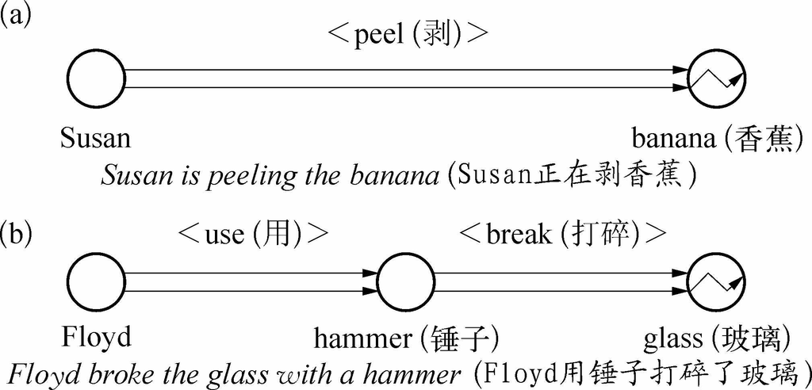

图4.12 动作链中的能量传递（部分依据Langacker 1990）

如图4.12（b）所示，包括了几个物理接触事件的更长互动是有可能的，事实上这些互动是规律（即使是一个像Susan is peeling a banana （Susan正在剥香蕉 ）这种二成分结构也可说成暗含了第三个未被表达出来的成分，即，用她的手）。这引发了Langacker讨论动作链。动作链（action chain） 的特点是：有一个能量“头”，是一个作为能量来源的物体或生物，从这一源头开始，能量向第二个实体传递，这样继续下去直到最后一个只消耗剩余的能量而不发散能量的实体，这个成分被叫做动作链的“尾”。为了强调能量流概念，Langacker利用了河流的隐喻，使用了“上游”（头）和“下游”（指动作链中的其他成分）这两个术语。

虽然能量流概念本身已经是隐喻的了，Langacker为了支持这一解释还是用了另一个甚至更为具体的隐喻，＋BILLIARD BALL＋（＋台球＋）隐喻。在被台球棒击发之后，白球被推向其他的球，如果这一物理接触有必需的力量，部分初始能量被传递到第二个球上，理论上第二个球会撞到第三个球，并将能量传递给它，如此继续下去。剩余的能量被软垫桌边冲吸收，或者，如果球击到了目标，就被台球桌的网袋所吸收。

＋ENERGY FLOW＋（＋能量流＋）和＋BILLIARD BALL＋（＋台球＋）隐喻又是如何帮助我们理解句法类型的呢？它们又是如何解释小句结构中角色原型与句法位置的配置呢？当表达出一个施事和受事的时候（如在Susan is peeling a banana （Susan在剥香蕉 ）中），施事对应于动作链的头，受事对应于尾，这似乎是相当明显的。既然施事是能量流的发起者，他或她在一定情景中就是最凸显的成分，因此被给予了句法主体即主语的地位。受事表现为句法背景或宾语。简言之，结果就是至少是在图4.12（a）中的二成分结构中，施事、动作链的头、句法主体三者相重合；受事、动作链的尾、句法背景相一致。这就以认知术语解释了为何施事多做主语，而受事多做宾语。

现在当我们转到三成分动作链时（图4.12（b）），也很容易把第一个成分看作施事，把最后一个成分看作受事。介于两者之间的表现工具的角色，充当能量传递的中间阶段。这一认知结构在语言上反映在句子Floyd broke the glass with a hammer （Floyd用锤子打碎了玻璃 ）中，施事被作为句法主体，之后是作为句法背景或宾语的受事以及工具（这里的认知顺序被倒过来了）。

然而正如Langacker所指出的，这个句子并不是这种动作链的唯一语言体现，其他视角也是可能的（参见5.1节）。比较一下图4.13，这里包括了两个不同的视角。句（a）提供了一个动作链的全面观察，句（b）和（c）只表达了某一部分，表达的部分由图（b）和（c）中的黑体部分来表示。特别的是，动作链的头没有以语言形式表达出来，也就是说句法主体或主语没有首选对象。图4.13说明了这一问题是如何解决的。主语的地位给了动作链中语言上表达出来的成分，是最远的“上游”成分。在图4.13（b）是工具（锤子），（c）中实际上则是动作链中的最后一个成分——受事（玻璃），在图中主语地位由特粗圆表示。

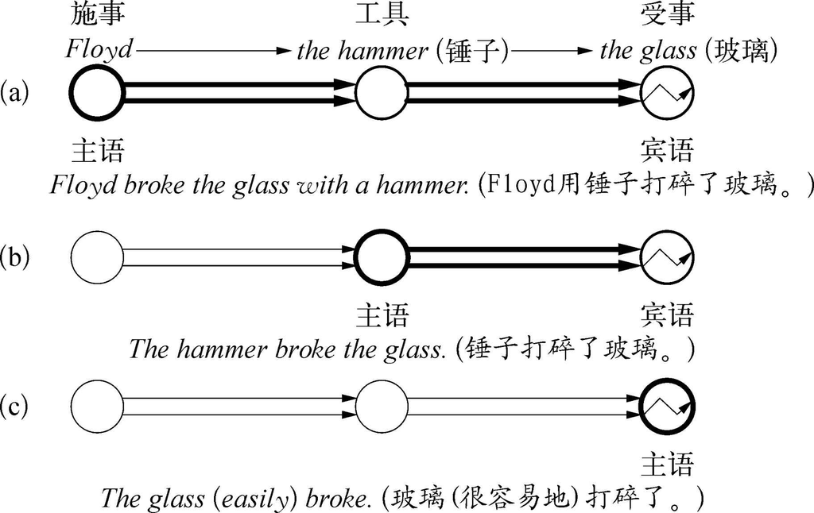

图4.13 三成分动作链的语言体现（改编自Langacker1990：221，合并了一些例子）

至于句法背景（或宾语）的选择，句（b）是没有问题的，因为像句（a）一样，受事也可在此位置出现（The hammer broke the glass （锤子打碎了玻璃 ），宾语由粗圆表示）。这与句（c）不同，因为它仅限于单成分的动作链（玻璃），并且正如我们所见，这一成分是句法主体。但同时它也代表了动作链的末尾，在这里能量被消耗，这是一个原型受事。这就意味着，没有能量继续消散，没有再与其他的物体建立物理接触，因此也无认知背景。这时不需要句法宾语，这就从认知上解释了为什么像The glass broke （玻璃打碎了） 这种句子是不及物的。

总结对于打碎-玻璃句子的分析，我们发现它产生了三个结果：证实了施事、动作链头与句法主体或主语之间的联系；从认知上解释了由Fillmore（1968：33）首先观察到的主语选择受控于“施事＞工具＞受事”层级。最后它将动词（如break （打碎 ））的不及物用法结合到了主体/背景范式中。

然而，这些发现只对描述包含物理接触的具体情景的句子有效。我们仍然不知道这种主体/背景解释对其他种类主语—动词—补足语结构是否也有效，如表达心理活动的Susan loves bananas （＝例（3））或She remembered her first bike （她记得她的第一辆自行车 ）这样的句子。

### 心理互动与小句句型

上面所引的两个例句并不表达物理接触，因而它们不能以动作链、能量传递与能量消耗来理解。相反，所发生的事件有心理的特点，并且其中的人也不产生物理能量，而是参与心理活动的一个有感觉的生物。对于这一角色原型，术语感事（experiencer） 要比施事更适当。但和心理运作与动作链差异有关的主要是第二个成分。作为动作链尾的受事接受并消耗物理能量，而且发生一些变化，或至少是移动到另一个位置。与之不同，心理活动中的第二个实体并不被这种互动真正触及或改变。为了表示这一角色原型，Langacker开始用术语“absolute”，后来用“theme”来替代。但在我们有限的讨论中，被感（（the）experienced） 会更有用一些，因为它表明了与感事之间的关系。图4.14图式化地说明了感事与被感之间的关系 <sup>(9)</sup> 。

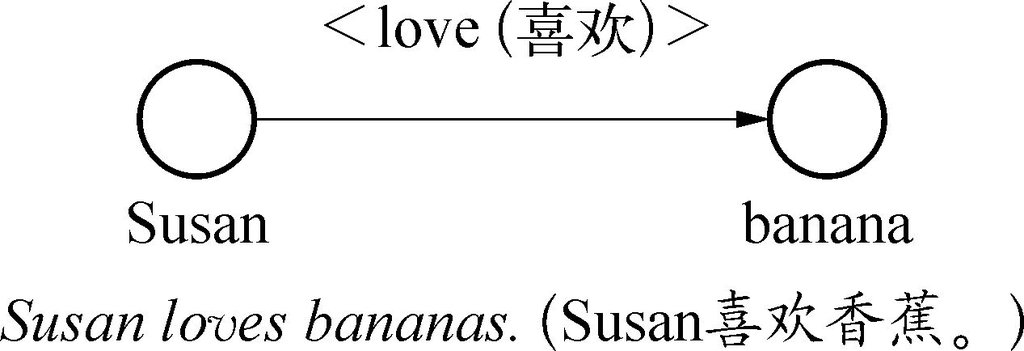

图4.14 心理互动的认知表征

在此图中，两个参与者之间的关系由一个单线箭头表示（这与表示动作链中强烈的能量联系的双线箭头不同）。这是为了表示，在某种意义上心理联系比动作链中的能量联系要“弱”，但仍很明显有方向性。它的源头是感事，因此标记为更凸显的活动发出者、这个心理互动中的主体，而被感则被标记为背景。这一主体/背景分配真实地反映在主语、宾语选择上，这就意味着主体/背景解释对于表达心理活动的Susan loves bananas （Susan喜欢香蕉 ）这种句子也同样适用。

心理活动的一个有趣的变体是表示对物体占有的情景。如以下两例：

Susan has a fairly large library.（＝例（5））

Susan received the present.（＝例（6））

第一个例子中Susan和她的书之间的领有关系第一眼看上去似乎具有很具体的、物理的性质。但是更进一步观察领有的内涵，会发现关键的是Susan和其他人知道这种领有关系，并且她也能享有领有关系的好处。既然“知道”和“享用”都是心理活动而不是物理活动，因此将感事与被感的角色描述应用于此句似乎就是合理的。

至于第二个例子，本质上解释为心理活动，第一眼看上去可能不是那么令人信服，因为它涉及物品的物理转移。动词receive （接受 ）与“给”这个观念密切相关，因此用动词give （给 ）及两个宾语组成的句子表达最自然不过了，就像Aunt Emily gave Susan the present （Emily姑姑送给Susan礼物 ）这个句子一样。虽然这与动作动词相类似，Susan received the present 中的主语仍应被看作是感事而不是施事。当我们按图4.15将give （给 ）和receive （接受 ）的认知结构进行比较就会发现确实如此。这两个图表明，give （给 ）和receive （接受 ）都包含了两个认知过程，即一个动作链和一个心理过程。先看“give ”（给 ） <sup>(10)</sup> ，动作链由施事开始（在我们的例句中是Aunt Emily （Emily姑姑 ））；施事将能量传到受事（the present （礼物 ）），使用了未说明的工具（如Emily姑姑的手）作为中介。感事（Susan ）则发起了一个与被感相关的心理互动，被感与动作链中的受事相同。结果，感事（Susan ）认识到会从给予这个动作中获益。

如果我们用主体/背景框架来评估Aunt Emily gave Susan the present （Emily姑姑送给Susan礼物 ）这个句子，我们会发现施事是主语最明显、最主要的候选项；第二个可选的是受事，这里表达为直接宾语。这一凸显性分布与只有一个宾语的动作小句的主体/背景配置是一致的。为何如此？原因在于：感事（对应于间接宾语）被认为是外部附加成分，它不影响把施事选为主语，把受事选为直接宾语。

至于receive （接受 ）（图4.15（b）），认知结构很大程度上和give （给 ）一致。虽然预设了一个相同的动作链，但并未用词语表达出来，而这就是其主要区别。用语言明确表达出来的是感事（Susan ）与被感/受事（the present （礼物 ））之间的心理互动。主体和背景分布也像其他心理互动一样：感事充当句法主体或主语，而被感（也叫受事）则充当句法背景或宾语。

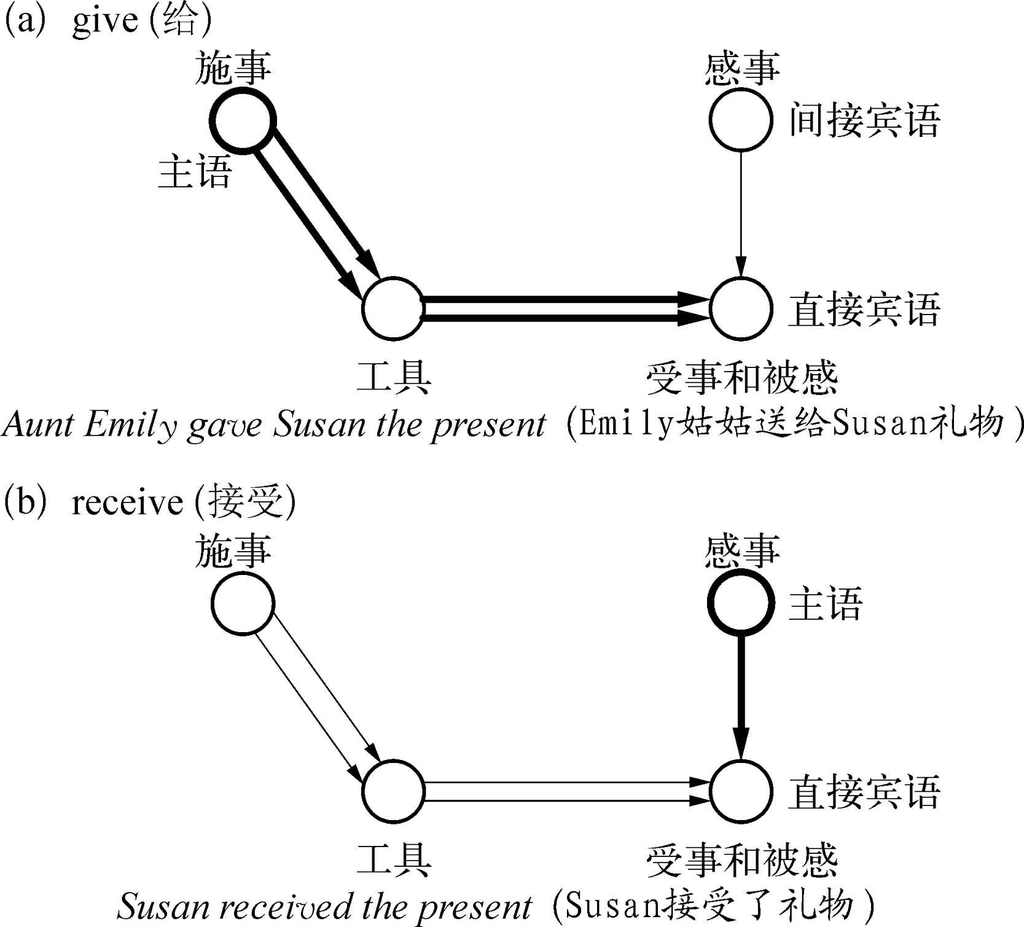

图4.15 含有give （给）和receive （接受）小句型式的认知结构（改编自Langacker1990；1991：327）

毫无疑问，Langacker对于give （给 ）和receive （接受 ）范式的认知解释引人入胜，但同时也十分激进。其中一点是它暗示了对给予这种行为的完全新的评价。它不把接受者看作是把东西从一个人向另一个人移动的物理行为的终点，而认为位移的物理方面仅限于行动者及被移动的事物，而接受者的作用则只是对这一物理行为的心理感知。如果我们要表达某物的确到达了由接受者所占据的空间位置，我们不得不使用带位置补足语的动词，如put/place the book in his hand （将书放在他手中 ）（这一结构将在下节中讨论）。

与give （给 ）相比，在Langacker看来，receive （接受 ）仅限于用来表达控制和拥有之类的心理操作，而并不涉及与被传递物体的物理接触。初看起来这个观点可能有点奇怪，但当我们考虑到下面的情况时可能会变得容易理解：接受者和被传递的物体之间的物理接触显然可以用动词take （拿 ）来表示，这个词甚至可与give （给 ）联合起来使用，就像下面的例子那样：

Aunt Emily gave Peter the present．He took it and thanked her excessively.（Emily姑姑给了Peter礼物。他拿了它 并非常感谢她。）

和give （给 ）一样，带take （拿 ）小句的基础也是一个动作链。接受者是施事，人的手是未说出的工具，交换的礼物是被移动的受事。唯一不同的只是运动的方向：用take （拿 ）时，向着而不是背着施事移动。从动作链主体/背景分离来看，give （给 ）小句和take （拿 ）小句中表达了同样的类型：施事作为句法主体或主语，而受事则是句法背景或（直接）宾语。它们不同的只是感事的角色。在give （给 ）例中，感事当然是与施事不同的另一个人，而take （拿 ）例中，施事和感事重合，尽管施事角色可能比感事角色更占优势。为了解释give （给 ）和take （拿 ）的不同，图4.16给出了take （拿 ）的认知表达式。在这个图中，与动作链相比，心理活动没有那么显著，因而用感事与被感之间的虚线箭头表示。

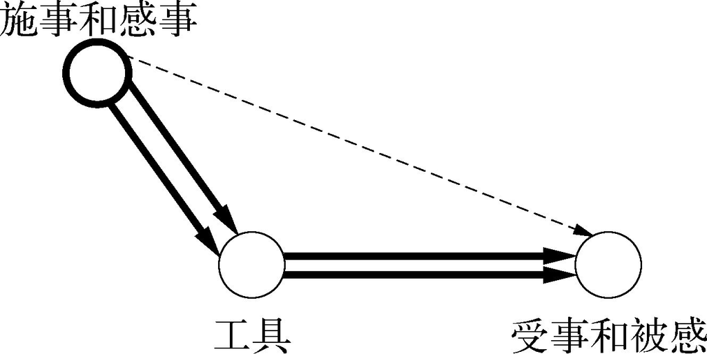

图4.16 take （拿）小句型式的认知结构